# Empirical Analysis of Corporate Disclosure Timing and Market Response in Korean Listed Firms

Abstract

This project examines whether unfavorable earnings disclosures by Korean listed firms are disproportionately released after market close and how disclosure timing is associated with subsequent market reactions. Using 7,978 core disclosure events from 530 KOSPI- and KOSDAQ-listed firms, the analysis combines minute-level DART filing timestamps, daily stock prices and trading volume, market indices, and firm-level controls. Bad-news disclosures show a higher after-hours share than good-news disclosures (46.9% versus 38.4%). A Market Model event study finds more negative average CARs for after-hours bad-news events than for intraday bad-news events, but multivariate return regressions do not support a robust independent penalty from after-hours timing itself once observable characteristics are controlled. Additional analyses decompose next-day price adjustment into opening-gap and intraday components, test firm-level persistence, and document industry heterogeneity. The results are interpreted as observational associations rather than causal evidence of deliberate strategic timing, and the final policy framework is presented as exploratory rather than prescriptive.

> **Project scope.** This project examines whether Korean listed firms strategically time unfavorable earnings disclosures after market close, how such timing is associated with market reactions, whether the behavior persists at the firm level, and how the pattern differs across industries. The empirical analysis combines DART disclosure records, minute-level disclosure timestamps, daily stock-price and trading-volume data, market indices, and firm-level controls.

> **Execution requirements.** To reproduce all results, render this file from the project repository with the `data_collection/` folder available and install the Python dependencies listed in the repository’s `requirements.txt`. A DART OpenAPI key is required only for API-dependent data-collection steps and should be supplied through the `DART_API_KEY` environment variable.

# 1 Introduction

Corporate disclosure is a central mechanism for reducing information asymmetry in capital markets and supporting investor decision-making. Earnings disclosures are especially important because they convey information about changes in profitability and firms’ future prospects, directly affecting price formation. Accordingly, not only **what** a firm discloses but also **when** the information reaches the market can matter.

Since the introduction of Korea’s electronic disclosure system (DART), the speed and accessibility of corporate information have improved substantially. Nevertheless, concerns about strategically timed disclosures—often described in Korea as *owl disclosures*—have persisted. A recurring concern is that unfavorable information may be disproportionately released after the market closes or late on Fridays, when investors have fewer opportunities to react immediately.

Prior international research has documented strategic timing of unfavorable corporate information. Patell and Wolfson (1982), Damodaran (1989), Bagnoli et al. (2006), Doyle and Magilke (2009), and DeHaan, Shevlin, and Thornock (2015) examine whether firms schedule disclosures when investor attention is lower or when immediate market reaction is constrained. Korean studies have similarly reported concentration of unfavorable announcements after market close or on Fridays across several disclosure categories.

This project extends that literature in six ways. First, it constructs **minute-level disclosure timestamps** and tests whether after-hours bad-news disclosures represent a broad structural pattern across days, markets, and years. Second, it uses an event-study framework to compare abnormal returns across disclosure types. Third, it examines determinants of after-hours timing using logistic regression, including bad-news severity, firm size, and strictly prior disclosure behavior. Fourth, it decomposes next-day returns into the opening gap and subsequent intraday return to study the price-adjustment mechanism. Fifth, it evaluates whether after-hours disclosure behavior persists at the firm level. Sixth, it compares industries using both disclosure frequency and market impact, producing an exploratory industry-level risk framework.

The analysis is observational. Therefore, the results are interpreted as empirical associations rather than definitive causal effects of disclosure timing.

# 2 Data and Study Period

| Item | Scope |
| --- | --- |
| Firms | KOSPI- and KOSDAQ-listed firms |
| Disclosure types | Earnings-related disclosures, including preliminary operating results and consolidated operating results |
| Main disclosure period | 2019 Q1–2025 Q4, with source collection extending into April 2026 where applicable |
| Stock-price data period | July 2018–April 2026 |
| Core disclosure sample | 7,978 disclosures in the main project dataset |
| Firms in the main sample | 530 |
| Unit of analysis | Firm–disclosure event |

Different downstream analyses can contain slightly different observation counts because they require different combinations of valid price history, market-index observations, financial controls, industry mappings, or return windows. Each analysis reports its own effective sample size. These are **analysis-specific samples rather than contradictory estimates of one fixed N**.

### 2.0.1 Analysis-specific sample composition

| Analysis component | Effective sample / scope | Main reason for difference |
| --- | --- | --- |
| Core project dataset | 7,978 disclosures | Main deduplicated disclosure dataset |
| Good/Bad timing histogram | 7,671 disclosures (4,119 Good; 3,552 Bad) | Requires valid Good/Bad classification used in the timing comparison |
| Friday after-hours subgroup | 7,939 disclosures | Uses the broader subgroup-analysis merge and its required CAR/control fields |
| Industry-level analysis | 8,553 Good/Bad disclosure observations | Constructed from the industry-analysis pipeline with KSIC mapping and its own valid observation requirements |

Because some analytical modules are constructed from different intermediate merges, their effective samples are not nested in a single monotonic attrition sequence. For reproducibility, the code in each section prints the corresponding observation count before estimation.

# 3 Overall Analytical Workflow

The project is organized into four broad stages.

| Stage | Analysis | Main question |
| --- | --- | --- |
| 1 | Disclosure-timing pattern tests | Are unfavorable disclosures disproportionately released after market close? |
| 2 | Event study and regression analysis | Is disclosure timing associated with market reactions, and what predicts after-hours timing? |
| 3 | Opening-gap, intraday-return, and volume analysis | Through what mechanism is after-hours bad news incorporated into prices and trading activity? |
| 4 | Firm persistence, industry analysis, and policy framework | Is after-hours bad-news disclosure repeated at the firm level, and does risk differ across industries? |

# 4 Data Collection and Construction

## 4.1 DART disclosures and minute-level timestamps

Earnings disclosures were collected from the Financial Supervisory Service’s DART system using the OpenDART API. Monthly disclosure lists were first retrieved and filtered to earnings-related announcements, including preliminary operating results and consolidated operating results. Duplicate filing identifiers (`rcept_no`) were removed.

Because the OpenDART list API does not directly provide minute-level filing times, the DART web interface was additionally scraped by date. Filing identifiers were matched to their displayed registration times, producing a minute-level `rcept_time` variable. This timestamp is central to classifying disclosures as pre-market, intraday, or after-hours.

Operating-performance figures were also collected from the filings to construct good-news/bad-news classifications and severity measures.

### 4.1.1 Core disclosure variables

| Variable | Description |
| --- | --- |
| `rcept_dt` | Filing date |
| `rcept_time` | Filing registration time (minute level) |
| `stock_code` | Stock code |
| `corp_name` | Company name |
| `report_nm` | Filing/report type |
| `corp_cls` | DART market classification |
| `market` | KOSPI/KOSDAQ classification |
| `operating_income_won` | Operating income |
| `sales_won` | Sales |
| `net_income_won` | Net income |

## 4.2 Stock-price and trading-volume data

Daily stock data were collected with FinanceDataReader for firms appearing in the disclosure sample. The data collection window begins approximately six months before the first disclosure date to provide a sufficiently long estimation window for the event study.

| Variable | Use |
| --- | --- |
| `Open` | Opening-gap return calculation |
| `Close` | Daily returns and CAR calculation |
| `Volume` | Abnormal trading-volume analysis |
| `Change` | Daily stock returns |
| `High`, `Low` | Validation and supplementary price analysis |

The event-study windows are defined as follows:

| Window | Period |
| --- | --- |
| Estimation window | $t=-120$ to $t=-21$ trading days |
| Event window | $t=-1$ to $t=+5$ trading days |

## 4.3 Market-index data

KOSPI (`KS11`) and KOSDAQ (`KQ11`) index data were collected with FinanceDataReader over the same broad period as the stock-price data. KOSPI-listed firms are matched to the KOSPI index and KOSDAQ-listed firms to the KOSDAQ index. These market returns are used in the Market Model to estimate expected returns and abnormal returns.

## 4.4 Firm characteristics and financial controls

Firm-level market characteristics were constructed from KRX/FinanceDataReader listings, including market classification, market capitalization, log market capitalization, foreign ownership, sector, and industry.

Financial controls were collected from DART annual reports using the single-account financial-statement API. Consolidated financial statements (CFS) were preferred when available; otherwise, separate financial statements (OFS) were used. Account-name variants were harmonized to construct common financial variables.

| Variable | Description |
| --- | --- |
| `total_assets` | Total assets |
| `total_liabilities` | Total liabilities |
| `total_equity` | Total equity |
| `revenue` | Revenue |
| `operating_income` | Operating income |
| `net_income` | Net income |
| `debt_ratio` | Liabilities / equity |
| `roa` | Net income / total assets |
| `operating_margin` | Operating income / revenue |
| `log_assets` | Log total assets |

# 5 Data Sources and Reliability

| Data | Source | Reliability basis |
| --- | --- | --- |
| Corporate disclosures | Financial Supervisory Service DART OpenAPI | Official statutory disclosure system |
| Filing registration time | DART web pages | Displayed filing-registration time |
| Stock prices and volume | FinanceDataReader / KRX-based data | Exchange-based market data |
| Market indices | FinanceDataReader / KRX-based data | Exchange-based index data |
| Firm financial statements | DART annual reports | Statutory corporate filings |
| Firm characteristics | KRX / FinanceDataReader | Exchange-based listing data |

The project data were programmatically collected and integrated using Python, APIs, and web scraping. Because some analyses depend on multiple data sources, observation counts are checked after each merge rather than assumed to remain constant throughout the pipeline.

# 6 Key Variable Definitions

## 6.1 Good news and bad news

Disclosures are classified using the quarter-over-quarter change in operating income.

| Classification | Criterion |
| --- | --- |
| Good News | Operating income increases by at least 10% from the previous quarter |
| Bad News | Operating income decreases by at least 10% from the previous quarter |

Changes smaller than ±10% are treated as neutral and excluded from the principal good-news/bad-news comparisons.

Bad-news severity is further divided into:

| Severity | Criterion |
| --- | --- |
| Mild | −10% to −30% |
| Moderate | −30% to −50% |
| Severe | Below −50% |

## 6.2 Disclosure timing

Disclosure timing is classified from the minute-level DART registration time into **pre-market**, **intraday**, and **after-hours** categories. Friday after-hours disclosures are additionally analyzed as a separate subgroup because the next trading opportunity is delayed until the following trading day.

## 6.3 Event-study measures

The event study uses a Market Model. For firm $i$ on trading day $t$,

$$R_{it} = \alpha_i + \beta_i R_{mt} + \epsilon_{it}$$

where $R_{it}$ is the stock return and $R_{mt}$ is the relevant KOSPI or KOSDAQ market return. Abnormal return is defined as

$$AR_{it} = R_{it} - (\hat{\alpha}_i + \hat{\beta}_iR_{mt}),$$

and cumulative abnormal return over an event window $[a,b]$ is

$$CAR_i(a,b)=\sum_{t=a}^{b} AR_{it}.$$

The main CAR measures are `CAR[-1,+1]` and `CAR[-1,+5]`.

## 6.4 Return decomposition

To examine how after-hours information is incorporated into prices on the next trading day, returns are decomposed into:

| Measure | Definition |
| --- | --- |
| Gap Return | Next-day opening price relative to the previous close |
| Intraday Return | Same-day close relative to the opening price |
| Total Return | Same-day close relative to the previous close |

## 6.5 Abnormal trading volume

Trading-volume analysis evaluates whether disclosure events are associated with unusually high trading activity relative to each stock’s recent baseline. The exact construction and statistical tests are reported in the corresponding analysis section below.

# 7 Disclosure Timing Pattern Analysis (EDA + Chi-Square Test)

```python
import sys
import os
from pathlib import Path
import numpy as np
import pandas as pd
import matplotlib.pyplot as plt
import matplotlib.ticker as mtick
import matplotlib.font_manager as fm
from scipy import stats
from itertools import combinations
import matplotlib
from matplotlib import rcParams

# ── Robust project/data path resolution
def resolve_data_dir():
    """
    Locate the project's data_collection directory.

    Resolution order:
    1. DATA_DIR environment variable, if explicitly set
    2. Current working directory and its parents
    3. Automatic search under the user's home directory
    """
    required = "dart_earnings_financials_2019_2026.csv"

    # 1) Explicit override via environment variable
    env_dir = os.getenv("DATA_DIR")
    if env_dir:
        candidate = Path(env_dir).expanduser().resolve()
        if (candidate / required).exists():
            return candidate
        else:
            print(
                f"Warning: DATA_DIR is set to {candidate}, "
                f"but {required} was not found there."
            )

    # 2) Search common locations around the render directory
    cwd = Path.cwd().resolve()
    local_candidates = []

    for base in [cwd, *cwd.parents]:
        local_candidates.append(base / "data_collection")

    local_candidates.extend([
        cwd.parent / "data_collection",
        cwd / ".." / "data_collection",
    ])

    seen = set()
    for candidate in local_candidates:
        try:
            candidate = candidate.resolve()
        except OSError:
            continue

        if candidate in seen:
            continue
        seen.add(candidate)

        if (candidate / required).exists():
            return candidate

    # 3) Fallback: search the user's home directory
    home = Path.home().resolve()
    print(
        "data_collection was not found near the QMD. "
        f"Searching under {home} ..."
    )

    skip_parts = {
        ".git", ".venv", "venv", "node_modules",
        "AppData", "__pycache__", ".cache"
    }

    matches = []
    try:
        for path in home.rglob(required):
            if any(part in skip_parts for part in path.parts):
                continue
            if path.parent.name == "data_collection":
                matches.append(path.parent.resolve())
                if len(matches) >= 5:
                    break
    except (PermissionError, OSError):
        pass

    unique_matches = list(dict.fromkeys(matches))

    if unique_matches:
        selected = unique_matches[0]
        if len(unique_matches) > 1:
            print("Additional matching data directories were found:")
            for extra in unique_matches[1:]:
                print(f"  - {extra}")
            print("Using the first match shown above.")
        return selected

    checked = "\n  - ".join(str(c) for c in seen)
    raise FileNotFoundError(
        "Could not locate the data_collection directory required to execute this report.\n"
        f"Required file: {required}\n\n"
        "Recommended options:\n"
        "1. Put this QMD inside the project's analysis folder, or\n"
        "2. Set a DATA_DIR environment variable pointing to the data_collection folder.\n\n"
        f"Local locations checked:\n  - {checked}"
    )

DATA_DIR = resolve_data_dir()

# ── Output directory
OUTPUT_DIR = Path().resolve() / "outputs"
OUTPUT_DIR.mkdir(parents=True, exist_ok=True)

# ── Font settings
matplotlib.rcParams["font.family"] = "DejaVu Sans"
matplotlib.rcParams["axes.unicode_minus"] = False
matplotlib.rcParams["figure.dpi"] = 110
matplotlib.rcParams["savefig.dpi"] = 140
matplotlib.rcParams["figure.autolayout"] = False


# ── Global style
rcParams.update({
    "figure.facecolor" : "#1B2A4A",   # Navy background
    "axes.facecolor"   : "#243558",   # Plot area
    "axes.edgecolor"   : "#4A6080",
    "axes.labelcolor"  : "#FFFFFF",   # White
    "axes.titlecolor"  : "#FFFFFF",   # White
    "xtick.color"      : "#FFFFFF",   # White
    "ytick.color"      : "#FFFFFF",   # White
    "text.color"       : "#FFFFFF",   # White
    "grid.color"       : "#4A6080",
    "grid.linestyle"   : "--",
    "grid.alpha"       : 0.5,
    "font.size"        : 10,
    "axes.titlesize"   : 12,
    "axes.titleweight" : "bold",
    "axes.labelsize"   : 10,
    "legend.framealpha": 0.6,
    "legend.edgecolor" : "#4A6080",
    "legend.facecolor" : "#1B2A4A",
})

# ── Colors
C_GOOD, C_BAD = "#1D9E75", "#C44E52"
C_BEFORE, C_DURING, C_AFTER = "#4C72B0", "#888780", "#C44E52"

# Retain Korean category values used in the source data for processing
TIMING_COLORS = {
    "장전": C_BEFORE,
    "장중": C_DURING,
    "장후": C_AFTER
}

# English labels for visualization
TIMING_LABELS = {
    "장전": "Pre-market",
    "장중": "Intraday",
    "장후": "After-hours"
}

NEWS_LABELS = {
    "호재": "Good News",
    "악재": "Bad News"
}
```

```python
DATA_DIR = resolve_data_dir()

raw_fin  = pd.read_csv(DATA_DIR / "dart_earnings_financials_2019_2026.csv", dtype=str)
raw_ctrl = pd.read_csv(DATA_DIR / "dart_financial_controls_2019_2025.csv")
raw_comp = pd.read_csv(DATA_DIR / "company_krx_fdr_controls_2019_2026.csv")
```

```python
# Filtering
remove = raw_fin["report_nm"].str.contains(
    "전망|기재정정|첨부정정|첨부추가|월별|monthly", na=False, regex=True
)
fin = raw_fin[~remove].copy()
fin["year"] = fin["rcept_dt"].str[:4].astype(int)
fin = fin[fin["year"] <= 2025].copy()

# Remove duplicates, prioritizing consolidated disclosures
fin["is_consolidated"] = fin["report_nm"].str.contains("연결", na=False)
fin = fin.sort_values(
    ["stock_code", "rcept_dt", "is_consolidated", "rcept_no"],
    ascending=[True, True, False, True]
)
fin = fin.drop_duplicates(subset=["stock_code", "rcept_dt"], keep="first")

# Classify disclosure timing
t = fin["rcept_time"].str.split(":", expand=True)
fin["_h"] = pd.to_numeric(t[0], errors="coerce")
fin["_m"] = pd.to_numeric(t[1], errors="coerce")
fin["timing"] = "Intraday"
fin.loc[fin["_h"] < 9, "timing"] = "Pre-market"
fin.loc[(fin["_h"] > 15) | ((fin["_h"] == 15) & (fin["_m"] > 30)), "timing"] = "After-hours"
fin.loc[fin["_h"].isna(), "timing"] = None
fin.drop(columns=["_h", "_m"], inplace=True)
fin["rcept_dt_dt"] = pd.to_datetime(fin["rcept_dt"], format="%Y%m%d")
fin["weekday"] = fin["rcept_dt_dt"].dt.dayofweek

# Classify good and bad news
fin["oi_won"] = pd.to_numeric(fin["operating_income_won"], errors="coerce")
fin = fin.sort_values(["stock_code", "rcept_dt_dt"])
fin["prev_oi"] = fin.groupby("stock_code")["oi_won"].shift(1)
fin["oi_chg_pct"] = np.where(
    fin["prev_oi"].notna() & (fin["prev_oi"] != 0),
    (fin["oi_won"] - fin["prev_oi"]) / fin["prev_oi"].abs(),
    np.nan
)
fin["news"] = np.select(
    [fin["oi_chg_pct"] > 0.10, fin["oi_chg_pct"] < -0.10,
     fin["oi_chg_pct"].between(-0.10, 0.10, inclusive="both")],
    ["Good News", "Bad News", "Neutral"], default="Missing"
)

df = fin.copy()
df_hb = df[df["news"].isin(["Good News", "Bad News"]) & df["timing"].notna()].copy()

print(f"Good News: {df['news'].eq('Good News').sum():,}  Bad News: {df['news'].eq('Bad News').sum():,}")
print(f"Timing: {df['timing'].value_counts().to_dict()}")
```

```
Good News: 4,534  Bad News: 4,030
Timing: {'Intraday': 6362, 'After-hours': 5118, 'Pre-market': 811}
```

### 7.0.1 Distribution of Disclosure Times

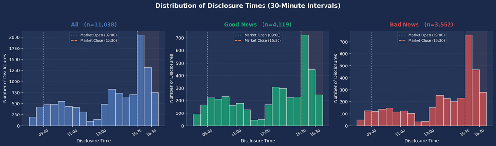

```python
def to_minutes(series):
    t = series.dropna().str.split(":", expand=True)
    h = pd.to_numeric(t[0], errors="coerce")
    m = pd.to_numeric(t[1], errors="coerce")
    total = h * 60 + m
    return total[(total >= 480) & (total <= 1020)]

BG_COLOR = "#1B2A4A"  # Navy background

bins = np.arange(480, 1021, 30)
fig, axes = plt.subplots(1, 3, figsize=(16, 4.5), sharey=False)
fig.patch.set_facecolor(BG_COLOR)
fig.suptitle("Distribution of Disclosure Times (30-Minute Intervals)", fontsize=14, fontweight="bold",
             color="#FFFFFF", y=1.03)

COLORS = {"All": "#4C72B0", "Good News": "#1D9E75", "Bad News": "#C44E52"}

datasets = [
    (df[df["timing"].notna()],               "All"),
    (df_hb[df_hb["news"] == "Good News"],    "Good News"),
    (df_hb[df_hb["news"] == "Bad News"],     "Bad News"),
]

for ax, (data, label) in zip(axes, datasets):
    mins = to_minutes(data["rcept_time"])
    color = COLORS[label]

    ax.set_facecolor("#243558")
    ax.hist(mins, bins=bins, color=color, alpha=0.85,
            edgecolor="white", linewidth=0.8, zorder=3)

    ax.axvline(540, color="#6BAED6", linestyle=":", linewidth=1.5,
               label="Market Open (09:00)", zorder=4)
    ax.axvline(930, color="#FC8D59", linestyle="--", linewidth=1.5,
               label="Market Close (15:30)", zorder=4)
    ax.axvspan(930, 1020, alpha=0.08, color="#FC8D59", zorder=2)

    ax.set_title(f"{label}   (n={len(mins):,})", fontsize=12,
                 fontweight="bold", color=color, pad=10)
    ax.set_xlabel("Disclosure Time", fontsize=10, color="#FFFFFF")
    ax.set_ylabel("Number of Disclosures", fontsize=10, color="#FFFFFF")
    ax.set_xticks([540, 660, 780, 930, 990])
    ax.set_xticklabels(["09:00", "11:00", "13:00", "15:30", "16:30"],
                       rotation=30, fontsize=8.5, color="#FFFFFF")
    ax.tick_params(colors="#FFFFFF", length=3)
    ax.spines[["top", "right"]].set_visible(False)
    ax.spines[["left", "bottom"]].set_color("#4A6080")
    ax.grid(axis="y", linestyle="--", alpha=0.3, color="#4A6080", zorder=1)
    ax.legend(fontsize=8, framealpha=0.4, edgecolor="#4A6080",
              labelcolor="#FFFFFF", facecolor="#1B2A4A")

plt.tight_layout()
plt.savefig(OUTPUT_DIR / "01_1_time_histogram.png",
            dpi=150, bbox_inches="tight", facecolor=BG_COLOR)
plt.show()
```

## 7.1 Interpretation of the Disclosure Time Distribution Histogram

Across all three histograms, disclosure frequency increases sharply immediately after the market close, particularly during the 15:30–16:00 interval. This pattern suggests that firms tend to release disclosures around or shortly after the end of regular trading hours.

Comparing the **Good News sample (n = 4,119)** with the **Bad News sample (n = 3,552)**, Bad News disclosures appear relatively more concentrated in the post-market period. However, the visual difference is not substantial, and both groups exhibit their highest disclosure frequency immediately after the market closes.

During regular trading hours (09:00–15:30), Good News disclosures appear to be distributed more evenly across time intervals.

However, these histograms display absolute disclosure counts, meaning that differences in sample size between Good News and Bad News are reflected in the visualization. Therefore, the histograms alone are insufficient to determine whether disclosure timing systematically differs by news type. A proportional comparison is required to assess these differences more appropriately.

The statistical significance of these patterns is examined in the subsequent **cross-tabulation and chi-square test analyses**.

Overall, the histograms indicate that the concentration of disclosures immediately after market close is not limited to a particular news type but is a broader feature of disclosure activity. Accordingly, the primary observation at this stage is not that Bad News is necessarily more concentrated after hours, but rather that **post-market disclosure clustering is prevalent across both Good News and Bad News disclosures**.

### 7.1.1 News Type × Disclosure Timing Cross-Tabulation

```
=== Counts ===
timing     Pre-market  Intraday  After-hours
news
Good News         330      2460         1737
Bad News          243      1894         1887

=== Percentages (%) ===
timing     Pre-market  Intraday  After-hours
news
Good News         7.3      54.3         38.4
Bad News          6.0      47.1         46.9

Bad News after-hours share: 46.9%
Good News after-hours share: 38.4%
Difference: +8.5 pp
```

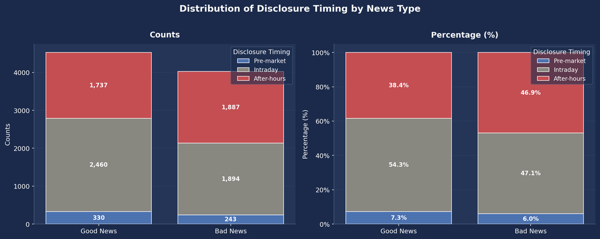

```python
ct = pd.crosstab(df_hb["news"], df_hb["timing"])
ct = ct.reindex(
    index=["Good News", "Bad News"],
    columns=["Pre-market", "Intraday", "After-hours"]
)  # Explicitly specify row and column order

ct_pct = ct.div(ct.sum(axis=1), axis=0) * 100

print("=== Counts ===")
print(ct)

print("\n=== Percentages (%) ===")
print(ct_pct.round(1))

print(f"\nBad News after-hours share: {ct_pct.loc['Bad News', 'After-hours']:.1f}%")
print(f"Good News after-hours share: {ct_pct.loc['Good News', 'After-hours']:.1f}%")
print(
    f"Difference: "
    f"{ct_pct.loc['Bad News', 'After-hours'] - ct_pct.loc['Good News', 'After-hours']:+.1f} pp"
)

BG_COLOR = "#1B2A4A"

PALETTE = {
    "Pre-market": "#4C72B0",
    "Intraday": "#888780",
    "After-hours": "#C44E52"
}

fig, axes = plt.subplots(1, 2, figsize=(13, 5))
fig.patch.set_facecolor(BG_COLOR)

fig.suptitle(
    "Distribution of Disclosure Timing by News Type",
    fontsize=14,
    fontweight="bold",
    color="#FFFFFF",
    y=1.02
)

for ax, (data, title, fmt) in zip(axes, [
    (ct,     "Counts",         lambda v: f"{int(v):,}"),
    (ct_pct, "Percentage (%)", lambda v: f"{v:.1f}%"),
]):
    ax.set_facecolor("#243558")
    bottom = np.zeros(2)

    for timing, color in PALETTE.items():
        vals = data[timing].values

        bars = ax.bar(
            ["Good News", "Bad News"],
            vals,
            bottom=bottom,  # Consistent with the specified reindex order
            label=timing,
            color=color,
            edgecolor="white",
            linewidth=0.8,
            zorder=3
        )

        for bar, val in zip(bars, vals):
            if val > (80 if title == "Counts" else 4):
                ax.text(
                    bar.get_x() + bar.get_width() / 2,
                    bar.get_y() + bar.get_height() / 2,
                    fmt(val),
                    ha="center",
                    va="center",
                    fontsize=9,
                    color="white",
                    fontweight="bold"
                )

        bottom += vals

    ax.set_title(title, fontsize=12, fontweight="bold", pad=10)
    ax.set_ylabel(title, fontsize=10)
    ax.tick_params(length=3)
    ax.spines[["top", "right"]].set_visible(False)
    ax.spines[["left", "bottom"]].set_color("#4A6080")
    ax.grid(
        axis="y",
        linestyle="--",
        alpha=0.3,
        color="#4A6080",
        zorder=1
    )

    if title == "Percentage (%)":
        ax.yaxis.set_major_formatter(mtick.PercentFormatter())

    ax.legend(title="Disclosure Timing", fontsize=9)

plt.tight_layout()

plt.savefig(
    OUTPUT_DIR / "01_2_crosstab.png",
    dpi=150,
    bbox_inches="tight",
    facecolor=BG_COLOR
)

plt.show()
```

## 7.2 Interpretation of the News Type × Disclosure Timing Cross-Tabulation

The most notable result from the cross-tabulation is that **Bad News disclosures had a higher after-hours share than Good News disclosures**.

| News Type | After-Hours Share |
| --- | --- |
| Bad News | 46.9% |
| Good News | 38.4% |

Nearly half of Bad News disclosures were released after the market closed, whereas Good News disclosures showed a relatively lower concentration in the after-hours period. The difference between the two groups was approximately **8.5 percentage points**.

In contrast, the share of Intraday disclosures was higher for Good News (**54.3%**) than for Bad News (**47.1%**), a difference of approximately **7.2 percentage points**. This pattern suggests that Good News disclosures tend to be relatively more concentrated during trading hours, while Bad News disclosures tend to be relatively more concentrated after market close.

However, two points should be considered at this stage.

First, the cross-tabulation alone does not establish whether the observed differences are **statistically significant**. This is examined in the following section using a **chi-square test of independence**.

Second, the Pre-market share was slightly higher for Good News (**7.3%**) than for Bad News (**6.0%**). Although this is consistent with Bad News being relatively less concentrated before the market opens, the difference is small and should not be overinterpreted.

Overall, the appropriate interpretation at this stage is that **Bad News disclosures show a relatively greater tendency to be released after market close**. Whether this pattern represents a statistically significant association between news type and disclosure timing is evaluated in the subsequent statistical analysis.

### 7.2.1 Chi-Square Test of Independence

```
=== Chi-Square (χ²) Test of Independence ===
Null hypothesis: News type and disclosure timing are independent

χ²=63.6274,  df=2,  p=0.000000  *** (p<0.001)

Standardized residuals (|z|>2 → meaningful contribution):
timing     Pre-market  Intraday  After-hours
news
Bad News        -1.62     -3.42         4.40
Good News        1.53      3.23        -4.15

Positive (+): Observed > Expected  /  Negative (-): Observed < Expected
```

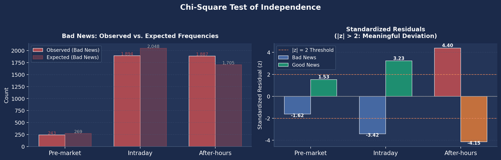

```python
ct = pd.crosstab(df_hb["news"], df_hb["timing"])
ct = ct.reindex(columns=["Pre-market", "Intraday", "After-hours"])
chi2, p, dof, expected = stats.chi2_contingency(ct)

def sig_label(p):
    if p < 0.001: return "*** (p<0.001)"
    if p < 0.01:  return "** (p<0.01)"
    if p < 0.05:  return "* (p<0.05)"
    return "(Not significant)"

print("=== Chi-Square (χ²) Test of Independence ===")
print("Null hypothesis: News type and disclosure timing are independent")
print(f"\nχ²={chi2:.4f},  df={dof},  p={p:.6f}  {sig_label(p)}")

std_resid = (ct.values - expected) / np.sqrt(expected)
sr_df = pd.DataFrame(std_resid.round(2), index=ct.index, columns=ct.columns)

print("\nStandardized residuals (|z|>2 → meaningful contribution):")
print(sr_df)
print("\nPositive (+): Observed > Expected  /  Negative (-): Observed < Expected")

BG_COLOR = "#1B2A4A"

fig, axes = plt.subplots(1, 2, figsize=(13, 4))
fig.patch.set_facecolor(BG_COLOR)
fig.suptitle(
    "Chi-Square Test of Independence",
    fontsize=14,
    fontweight="bold",
    color="#FFFFFF",
    y=1.02
)

# Left: Observed vs. expected frequencies
ax = axes[0]
ax.set_facecolor("#243558")
x = np.arange(3)
width = 0.35
labels = ["Pre-market", "Intraday", "After-hours"]

bars_actual = ax.bar(
    x - width/2,
    ct.loc["Bad News"].values,
    width,
    label="Observed (Bad News)",
    color="#C44E52",
    alpha=0.85,
    edgecolor="white",
    linewidth=0.8
)

bad_news_idx = ct.index.get_loc("Bad News")

bars_expected = ax.bar(
    x + width/2,
    expected[bad_news_idx],
    width,
    label="Expected (Bad News)",
    color="#C44E52",
    alpha=0.35,
    edgecolor="#C44E52",
    linewidth=1.2
)

ax.set_xticks(x)
ax.set_xticklabels(labels, fontsize=11)
ax.set_ylabel("Count", fontsize=10)
ax.set_title(
    "Bad News: Observed vs. Expected Frequencies",
    fontsize=11,
    fontweight="bold",
    pad=10
)
ax.spines[["top", "right"]].set_visible(False)
ax.spines[["left", "bottom"]].set_color("#4A6080")
ax.grid(axis="y", linestyle="--", alpha=0.3, color="#4A6080")
ax.legend(fontsize=9)

for bar in bars_actual:
    ax.text(
        bar.get_x() + bar.get_width()/2,
        bar.get_height() + 10,
        f"{int(bar.get_height()):,}",
        ha="center",
        fontsize=8,
        color="#C44E52"
    )

for val, bar in zip(expected[bad_news_idx], bars_expected):
    ax.text(
        bar.get_x() + bar.get_width()/2,
        val + 10,
        f"{int(val):,}",
        ha="center",
        fontsize=8,
        color="#AAAAAA"
    )

# Right: Standardized residuals
ax = axes[1]
ax.set_facecolor("#243558")

bad_news_idx = ct.index.get_loc("Bad News")
good_news_idx = ct.index.get_loc("Good News")

resid_bad = std_resid[bad_news_idx]
resid_good = std_resid[good_news_idx]

bars_bad = ax.bar(
    x - width/2,
    resid_bad,
    width,
    label="Bad News",
    color=["#C44E52" if v > 0 else "#4C72B0" for v in resid_bad],
    alpha=0.85,
    edgecolor="white",
    linewidth=0.8
)

bars_good = ax.bar(
    x + width/2,
    resid_good,
    width,
    label="Good News",
    color=["#1D9E75" if v > 0 else "#E07B39" for v in resid_good],
    alpha=0.85,
    edgecolor="white",
    linewidth=0.8
)

ax.axhline(
    y=2,
    color="#FC8D59",
    linestyle="--",
    linewidth=1.0,
    alpha=0.8,
    label="|z| = 2 Threshold"
)
ax.axhline(
    y=-2,
    color="#FC8D59",
    linestyle="--",
    linewidth=1.0,
    alpha=0.8
)
ax.axhline(y=0, color="#AAAAAA", linewidth=0.8)

ax.set_xticks(x)
ax.set_xticklabels(labels, fontsize=11)
ax.set_ylabel("Standardized Residual (z)", fontsize=10)
ax.set_title(
    "Standardized Residuals\n(|z| > 2: Meaningful Deviation)",
    fontsize=11,
    fontweight="bold",
    pad=10
)
ax.spines[["top", "right"]].set_visible(False)
ax.spines[["left", "bottom"]].set_color("#4A6080")
ax.grid(axis="y", linestyle="--", alpha=0.3, color="#4A6080")
ax.legend(fontsize=9)

for bar in bars_bad:
    v = bar.get_height()
    ax.text(
        bar.get_x() + bar.get_width()/2,
        v + 0.1 if v >= 0 else v - 0.25,
        f"{v:.2f}",
        ha="center",
        fontsize=8.5,
        fontweight="bold"
    )

for bar in bars_good:
    v = bar.get_height()
    ax.text(
        bar.get_x() + bar.get_width()/2,
        v + 0.1 if v >= 0 else v - 0.25,
        f"{v:.2f}",
        ha="center",
        fontsize=8.5,
        fontweight="bold"
    )

plt.tight_layout()

plt.savefig(
    OUTPUT_DIR / "01_3_chi2.png",
    dpi=150,
    bbox_inches="tight",
    facecolor=BG_COLOR
)

plt.show()
```

## 7.3 Interpretation of the Chi-Square Test of Independence

The chi-square test of independence indicates a **statistically significant association between news type and disclosure timing**.

```
χ² = 63.63
df = 2
p < 0.001
```

Therefore, the null hypothesis that **news type and disclosure timing are independent** is rejected. This result provides statistical evidence that the distribution of disclosure timing differs between Good News and Bad News disclosures.

The **standardized residuals** provide further insight into which timing categories contribute to this association.

In the **After-hours** category, Bad News disclosures exhibit a large positive standardized residual (**z = +4.40**), indicating that more Bad News disclosures occurred after market close than would be expected under independence. In contrast, Good News disclosures show a negative residual (**z = -4.15**), indicating fewer After-hours Good News disclosures than expected.

The opposite pattern is observed for **Intraday** disclosures. Bad News disclosures occur less frequently than expected (**z = -3.42**), whereas Good News disclosures occur more frequently than expected (**z = +3.23**).

For the **Pre-market** category, the standardized residuals for both Bad News (**z = -1.62**) and Good News (**z = +1.53**) remain within the |z| < 2 range, indicating no substantial deviation from the expected frequencies.

Overall, the results provide statistical evidence that **Bad News disclosures are relatively more concentrated After-hours, whereas Good News disclosures are relatively more concentrated Intraday**. This supports the approximately **8.5 percentage-point difference in the After-hours disclosure share** observed in the preceding cross-tabulation analysis.

However, the chi-square test establishes an **association** between news type and disclosure timing; it does not by itself demonstrate that firms strategically choose disclosure times. Whether the observed timing pattern is consistent with strategic disclosure behavior requires further examination using regression analysis and additional empirical tests.

### 7.3.1 Day of Week × Disclosure Timing Heatmap

```
=== Bad News Share by Day of Week and Disclosure Timing (%) ===
timing         Pre-market  Intraday  After-hours
weekday_label
Monday               32.7      38.8         49.0
Tuesday              44.0      44.5         52.9
Wednesday            41.6      44.2         52.4
Thursday             44.8      41.2         50.8
Friday               43.0      48.1         54.5
```

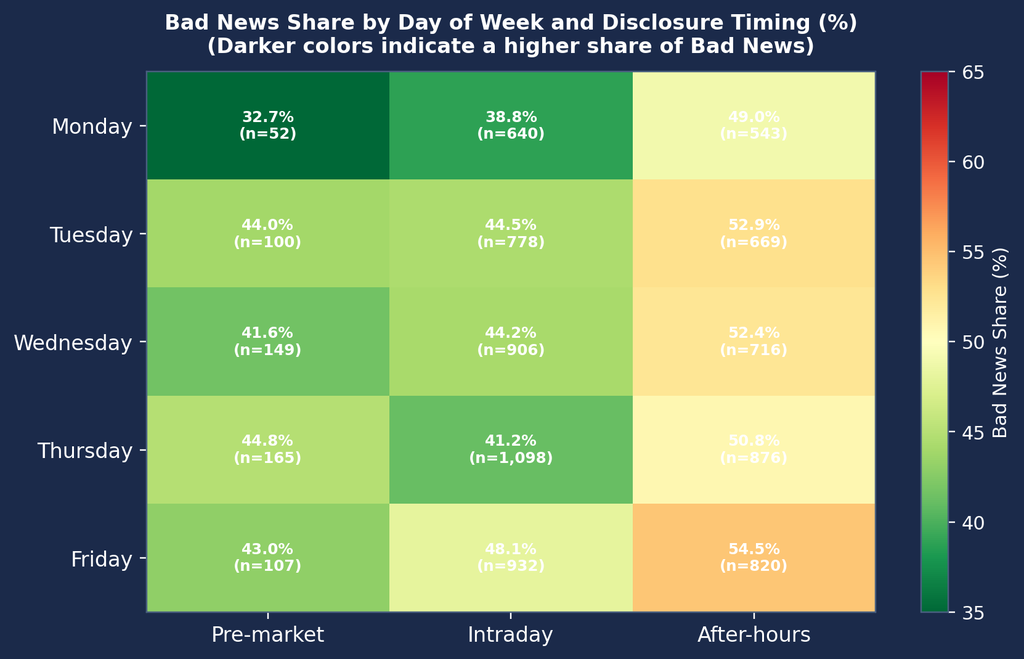

```python
BG_COLOR = "#1B2A4A"

d = df_hb.copy()

d["weekday_label"] = d["weekday"].map({
    0: "Monday",
    1: "Tuesday",
    2: "Wednesday",
    3: "Thursday",
    4: "Friday"
})

pct = d.pivot_table(
    values="news",
    index="weekday_label",
    columns="timing",
    aggfunc=lambda x: (x == "Bad News").sum() / len(x) * 100
).reindex(
    index=["Monday", "Tuesday", "Wednesday", "Thursday", "Friday"],
    columns=["Pre-market", "Intraday", "After-hours"]
)

cnt = d.pivot_table(
    values="news",
    index="weekday_label",
    columns="timing",
    aggfunc="count"
).reindex(
    index=["Monday", "Tuesday", "Wednesday", "Thursday", "Friday"],
    columns=["Pre-market", "Intraday", "After-hours"]
)

print("=== Bad News Share by Day of Week and Disclosure Timing (%) ===")
print(pct.round(1))

fig, ax = plt.subplots(figsize=(8, 5))
fig.patch.set_facecolor(BG_COLOR)
ax.set_facecolor("#243558")

im = ax.imshow(
    pct.values,
    cmap="RdYlGn_r",
    vmin=35,
    vmax=65,
    aspect="auto"
)

ax.set_xticks(range(3))
ax.set_xticklabels(
    ["Pre-market", "Intraday", "After-hours"],
    fontsize=11
)

ax.set_yticks(range(5))
ax.set_yticklabels(
    ["Monday", "Tuesday", "Wednesday", "Thursday", "Friday"],
    fontsize=11
)

ax.set_title(
    "Bad News Share by Day of Week and Disclosure Timing (%)\n"
    "(Darker colors indicate a higher share of Bad News)",
    fontsize=11,
    fontweight="bold",
    pad=10
)

for i in range(5):
    for j in range(3):
        v, c = pct.values[i, j], cnt.values[i, j]

        if not np.isnan(v):
            ax.text(
                j,
                i,
                f"{v:.1f}%\n(n={int(c):,})",
                ha="center",
                va="center",
                fontsize=8,
                color="white",
                fontweight="bold"
            )

ax.spines[["top", "right", "left", "bottom"]].set_color("#4A6080")

cbar = plt.colorbar(im, ax=ax)
cbar.ax.yaxis.set_tick_params(color="#FFFFFF")
cbar.outline.set_edgecolor("#4A6080")
plt.setp(cbar.ax.yaxis.get_ticklabels(), color="#FFFFFF")
cbar.set_label("Bad News Share (%)", color="#FFFFFF")

plt.tight_layout()

plt.savefig(
    OUTPUT_DIR / "01_4_heatmap.png",
    dpi=150,
    bbox_inches="tight",
    facecolor=BG_COLOR
)

plt.show()
```

## 7.4 Interpretation of the Day of Week × Disclosure Timing Heatmap

The heatmap analysis, which jointly considers the day of the week and disclosure timing, shows that the **share of Bad News disclosures is consistently higher After-hours than Intraday across all weekdays**. The pattern of After-hours > Intraday is maintained throughout the week, suggesting that the concentration of Bad News disclosures after market close may represent a relatively systematic pattern rather than a phenomenon confined to a particular day.

In particular, the **Friday After-hours** category recorded a Bad News share of **54.5%**, the highest among all 15 day-of-week × timing combinations. This pattern is directionally similar to the **“Friday evening clustering”** of corporate disclosures documented in prior research on the U.S. market by Michaely et al. (2016a).

In contrast, the **Monday Pre-market** category showed the lowest Bad News share at **32.7%**, indicating that Bad News disclosures were relatively less prevalent before the market opened at the beginning of the week.

However, the Pre-market categories generally contain smaller sample sizes and exhibit greater variation across weekdays. The share of Bad News in the Pre-market period ranged from **32.7% to 44.8%**, with some cells containing relatively few observations (**n = 52–165**). In particular, the Monday Pre-market category includes only approximately **52 observations**, so its estimated share should be interpreted with caution.

Overall, the heatmap provides a relatively clear visual pattern in which **Bad News disclosures are more concentrated After-hours**. However, the heatmap alone does not establish whether the day-of-week effect is independently statistically significant. This issue is examined more rigorously in the following section using the **Kruskal–Wallis test**.

### 7.4.1 Kruskal–Wallis Test

```
=== Kruskal–Wallis Test ===
Null hypothesis: The distributions of Bad News shares are identical across the three timing categories
  Pre-market: Mean 41.6%  Median 42.9%  n=55
  Intraday: Mean 50.1%  Median 47.4%  n=71
  After-hours: Mean 51.0%  Median 52.0%  n=64

H=8.1470,  p=0.017018  * (p<0.05)

Post-hoc tests (Mann–Whitney U, Bonferroni α=0.0167):
  Pre-market vs Intraday: U=1592.0,  p=0.0764,  p_adj=0.2293  (Not significant)
  Pre-market vs After-hours: U=1239.5,  p=0.0056,  p_adj=0.0167  * (p<0.05)
  Intraday vs After-hours: U=1974.5,  p=0.1904,  p_adj=0.5713  (Not significant)
```

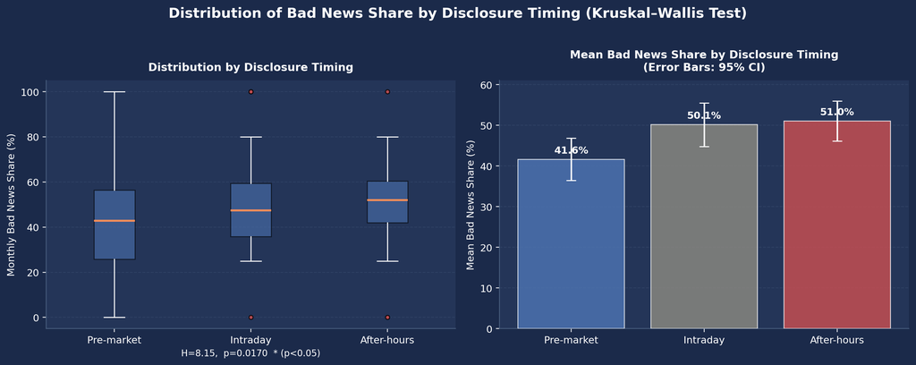

```python
BG_COLOR = "#1B2A4A"

d = df_hb.copy()
d["ym"] = d["rcept_dt"].str[:6]

ym_pct = d.groupby(["ym", "timing"])["news"].apply(
    lambda x: (x == "Bad News").sum() / len(x) * 100
).reset_index()
ym_pct.columns = ["ym", "timing", "bad_pct"]

groups = {
    t: ym_pct[ym_pct["timing"] == t]["bad_pct"].values
    for t in ["Pre-market", "Intraday", "After-hours"]
}

h_stat, p = stats.kruskal(*groups.values())

print("=== Kruskal–Wallis Test ===")
print("Null hypothesis: The distributions of Bad News shares are identical across the three timing categories")

for t, v in groups.items():
    print(f"  {t}: Mean {v.mean():.1f}%  Median {np.median(v):.1f}%  n={len(v)}")

print(f"\nH={h_stat:.4f},  p={p:.6f}  {sig_label(p)}")

pairs = list(combinations(["Pre-market", "Intraday", "After-hours"], 2))
alpha_adj = 0.05 / len(pairs)

print(f"\nPost-hoc tests (Mann–Whitney U, Bonferroni α={alpha_adj:.4f}):")

for a, b in pairs:
    u, p_mw = stats.mannwhitneyu(
        groups[a],
        groups[b],
        alternative="two-sided"
    )
    p_adj = min(p_mw * len(pairs), 1.0)

    print(
        f"  {a} vs {b}: "
        f"U={u:.1f},  p={p_mw:.4f},  p_adj={p_adj:.4f}  {sig_label(p_adj)}"
    )

# Visualization: Distribution of Bad News shares by disclosure timing
fig, axes = plt.subplots(1, 2, figsize=(13, 5))
fig.patch.set_facecolor(BG_COLOR)

fig.suptitle(
    "Distribution of Bad News Share by Disclosure Timing (Kruskal–Wallis Test)",
    fontsize=14,
    fontweight="bold",
    color="#FFFFFF",
    y=1.02
)

# Left: Boxplot
ax = axes[0]
ax.set_facecolor("#243558")

bp = ax.boxplot(
    [
        groups["Pre-market"],
        groups["Intraday"],
        groups["After-hours"]
    ],
    tick_labels=["Pre-market", "Intraday", "After-hours"],
    patch_artist=True,
    boxprops=dict(facecolor="#4C72B0", alpha=0.6),
    medianprops=dict(color="#FC8D59", linewidth=2),
    whiskerprops=dict(color="#FFFFFF", linewidth=1),
    capprops=dict(color="#FFFFFF", linewidth=1),
    flierprops=dict(
        marker="o",
        markerfacecolor="#C44E52",
        markersize=4,
        alpha=0.5
    )
)

ax.set_ylabel("Monthly Bad News Share (%)", fontsize=10)
ax.set_title(
    "Distribution by Disclosure Timing",
    fontsize=11,
    fontweight="bold",
    pad=10
)
ax.spines[["top", "right"]].set_visible(False)
ax.spines[["left", "bottom"]].set_color("#4A6080")
ax.grid(axis="y", linestyle="--", alpha=0.3, color="#4A6080")
ax.set_xlabel(
    f"H={h_stat:.2f},  p={p:.4f}  {sig_label(p)}",
    fontsize=9
)

# Right: Mean comparison with 95% confidence intervals
ax = axes[1]
ax.set_facecolor("#243558")

timings = ["Pre-market", "Intraday", "After-hours"]
means = [groups[t].mean() for t in timings]
cis = [
    1.96 * groups[t].std() / np.sqrt(len(groups[t]))
    for t in timings
]
colors = [C_BEFORE, C_DURING, C_AFTER]

bars = ax.bar(
    timings,
    means,
    color=colors,
    alpha=0.85,
    edgecolor="white",
    linewidth=0.8,
    zorder=3
)

ax.errorbar(
    timings,
    means,
    yerr=cis,
    fmt="none",
    color="#FFFFFF",
    capsize=5,
    linewidth=1.5,
    zorder=4
)

for bar, mean in zip(bars, means):
    ax.text(
        bar.get_x() + bar.get_width()/2,
        bar.get_height() + 1.5,
        f"{mean:.1f}%",
        ha="center",
        fontsize=10,
        fontweight="bold"
    )

ax.set_ylabel("Mean Bad News Share (%)", fontsize=10)
ax.set_title(
    "Mean Bad News Share by Disclosure Timing\n(Error Bars: 95% CI)",
    fontsize=11,
    fontweight="bold",
    pad=10
)
ax.spines[["top", "right"]].set_visible(False)
ax.spines[["left", "bottom"]].set_color("#4A6080")
ax.grid(axis="y", linestyle="--", alpha=0.3, color="#4A6080", zorder=1)
ax.set_ylim(0, max(means) + 10)

plt.tight_layout()

plt.savefig(
    OUTPUT_DIR / "01_5_kruskal.png",
    dpi=150,
    bbox_inches="tight",
    facecolor=BG_COLOR
)

plt.show()
```

## 7.5 Interpretation of the Kruskal–Wallis Test

The Kruskal–Wallis test indicates a **statistically significant difference in the distribution of Bad News shares across disclosure timing categories**.

```
H = 8.15
p = 0.017
```

Therefore, the null hypothesis that **the distributions of Bad News shares are identical across the three disclosure timing categories** is rejected. This provides statistical evidence that the distribution of Bad News shares varies across disclosure timing categories.

However, the **post-hoc tests** show that the statistically significant difference is limited to a specific pair of timing categories.

| Comparison | Adjusted p-value |
| --- | --- |
| Pre-market vs. After-hours | 0.017 |
| Pre-market vs. Intraday | 0.229 |
| Intraday vs. After-hours | 0.571 |

The only statistically significant pairwise difference is between the **Pre-market and After-hours** periods. The mean Bad News share was **41.6% for Pre-market disclosures** and **51.0% for After-hours disclosures**, indicating a statistically significant difference between these two categories.

In contrast, neither the **Pre-market vs. Intraday** nor the **Intraday vs. After-hours** comparison was statistically significant. In particular, the adjusted p-value for the Intraday vs. After-hours comparison was **0.571**, providing little evidence of a difference between these two timing categories.

Accordingly, the tendency for Bad News disclosures to be relatively more concentrated After-hours is supported when compared with the Pre-market period, but is **not strongly supported when After-hours disclosures are compared with Intraday disclosures**.

Overall, although the **Kruskal–Wallis test is statistically significant**, the post-hoc results indicate that the difference is driven primarily by the contrast between the Pre-market and After-hours periods. Compared with the stronger association identified by the chi-square test (**p < 0.001**), this provides more limited evidence of differences across timing categories. Taken together, the results suggest that **disclosure timing patterns exist, but the distinction between Intraday and After-hours Bad News shares is relatively limited in this monthly distribution analysis**.

### 7.5.1 KOSPI vs. KOSDAQ Comparison

```
=== KOSPI vs. KOSDAQ Comparison of After-Hours Bad News Share (Mann–Whitney U) ===
Null hypothesis: The distributions of After-hours Bad News shares are identical across the two markets

KOSPI  : Mean 20.13%  Median 18.46%  n=74
KOSDAQ : Mean 22.24%  Median 21.75%  n=62

U=2018.5,  p=0.228871  (Not significant)
```

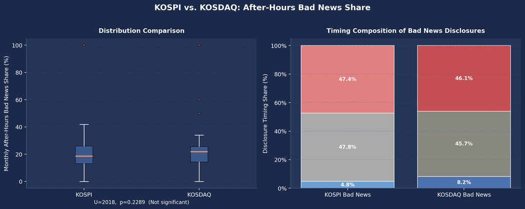

```python
BG_COLOR = "#1B2A4A"

d = df_hb.copy()
d["ym"] = d["rcept_dt"].str[:6]

bad_after = d.groupby(["market", "ym"]).apply(
    lambda g: ((g["news"] == "Bad News") & (g["timing"] == "After-hours")).sum() / max(len(g), 1) * 100
).reset_index()
bad_after.columns = ["market", "ym", "bad_after_pct"]

kospi  = bad_after[bad_after["market"] == "KOSPI"]["bad_after_pct"]
kosdaq = bad_after[bad_after["market"] == "KOSDAQ"]["bad_after_pct"]
u_stat, p = stats.mannwhitneyu(kospi, kosdaq, alternative="two-sided")

print("=== KOSPI vs. KOSDAQ Comparison of After-Hours Bad News Share (Mann–Whitney U) ===")
print("Null hypothesis: The distributions of After-hours Bad News shares are identical across the two markets")
print(f"\nKOSPI  : Mean {kospi.mean():.2f}%  Median {kospi.median():.2f}%  n={len(kospi)}")
print(f"KOSDAQ : Mean {kosdaq.mean():.2f}%  Median {kosdaq.median():.2f}%  n={len(kosdaq)}")
print(f"\nU={u_stat:.1f},  p={p:.6f}  {sig_label(p)}")

fig, axes = plt.subplots(1, 2, figsize=(13, 5))
fig.patch.set_facecolor(BG_COLOR)
fig.suptitle(
    "KOSPI vs. KOSDAQ: After-Hours Bad News Share",
    fontsize=14,
    fontweight="bold",
    color="#FFFFFF",
    y=1.02
)

# Left: Boxplot
ax = axes[0]
ax.set_facecolor("#243558")
bp = ax.boxplot(
    [kospi, kosdaq],
    tick_labels=["KOSPI", "KOSDAQ"],
    patch_artist=True,
    boxprops=dict(facecolor="#4C72B0", alpha=0.6),
    medianprops=dict(color="#FC8D59", linewidth=2),
    whiskerprops=dict(color="#FFFFFF", linewidth=1),
    capprops=dict(color="#FFFFFF", linewidth=1),
    flierprops=dict(
        marker="o",
        markerfacecolor="#C44E52",
        markersize=4,
        alpha=0.5
    )
)
ax.set_ylabel("Monthly After-Hours Bad News Share (%)", fontsize=10)
ax.set_title("Distribution Comparison", fontsize=11, fontweight="bold", pad=10)
ax.spines[["top", "right"]].set_visible(False)
ax.spines[["left", "bottom"]].set_color("#4A6080")
ax.grid(axis="y", linestyle="--", alpha=0.3, color="#4A6080")
ax.set_xlabel(f"U={u_stat:.0f},  p={p:.4f}  {sig_label(p)}", fontsize=9)

# Right: Timing composition of Bad News disclosures (stacked bar)
ax = axes[1]
ax.set_facecolor("#243558")

timing_order = ["Pre-market", "Intraday", "After-hours"]

light = {
    "Pre-market": "#6A9FD4",
    "Intraday": "#AAAAAA",
    "After-hours": "#E08080"
}

dark = {
    "Pre-market": C_BEFORE,
    "Intraday": C_DURING,
    "After-hours": C_AFTER
}

for i, (market, palette) in enumerate([
    ("KOSPI", light),
    ("KOSDAQ", dark)
]):
    sub = df_hb[df_hb["market"] == market]

    ct = sub.groupby(["news", "timing"]).size().unstack(fill_value=0)
    ct = ct.reindex(columns=timing_order, fill_value=0)
    ct_pct = ct.div(ct.sum(axis=1), axis=0) * 100

    bottom = 0

    for t in timing_order:
        val = ct_pct.loc["Bad News", t] if "Bad News" in ct_pct.index else 0

        ax.bar(
            i,
            val,
            bottom=bottom,
            color=palette[t],
            edgecolor="white",
            linewidth=0.8
        )

        if val > 3:
            ax.text(
                i,
                bottom + val / 2,
                f"{val:.1f}%",
                ha="center",
                va="center",
                fontsize=9,
                color="white",
                fontweight="bold"
            )

        bottom += val

ax.set_xticks([0, 1])
ax.set_xticklabels(["KOSPI Bad News", "KOSDAQ Bad News"])
ax.set_ylabel("Disclosure Timing Share (%)", fontsize=10)
ax.set_title(
    "Timing Composition of Bad News Disclosures",
    fontsize=11,
    fontweight="bold",
    pad=10
)
ax.spines[["top", "right"]].set_visible(False)
ax.spines[["left", "bottom"]].set_color("#4A6080")
ax.grid(axis="y", linestyle="--", alpha=0.3, color="#4A6080", zorder=1)
ax.yaxis.set_major_formatter(mtick.PercentFormatter())

plt.tight_layout()

plt.savefig(
    OUTPUT_DIR / "01_6_market_comparison.png",
    dpi=150,
    bbox_inches="tight",
    facecolor=BG_COLOR
)

plt.show()
```

## 7.6 Interpretation of the KOSPI vs. KOSDAQ Comparison

The comparison of the After-hours Bad News share between the KOSPI and KOSDAQ markets indicates that the difference between the two markets is **not statistically significant**.

```
U = 2018.5
p = 0.229
```

Therefore, the null hypothesis that **the distributions of After-hours Bad News shares are identical between KOSPI and KOSDAQ** cannot be rejected. In other words, there is insufficient statistical evidence that After-hours Bad News disclosure patterns differ systematically between the two markets.

Numerically, the mean After-hours Bad News share was **22.24% for KOSDAQ** and **20.13% for KOSPI**, representing a difference of approximately **2.1 percentage points**. However, this difference did not reach statistical significance.

The stacked bar analysis also shows that the timing composition of Bad News disclosures is broadly similar across the two markets.

| Market | After-hours Share of Bad News Disclosures |
| --- | --- |
| KOSPI | 47.4% |
| KOSDAQ | 46.1% |

Thus, in both KOSPI and KOSDAQ, approximately half of Bad News disclosures were released After-hours, indicating a similar timing pattern across the two markets.

This finding does not support the initial hypothesis that **After-hours Bad News disclosure patterns may be stronger in KOSDAQ, where retail investor participation is relatively high**. Although such a market-level difference was theoretically plausible, the empirical results show little evidence of a meaningful distinction between KOSPI and KOSDAQ in this respect.

Overall, **market classification (KOSPI vs. KOSDAQ) does not appear to be a major factor explaining After-hours Bad News disclosure patterns** in this analysis. Instead, the similarity across the two markets suggests that the observed After-hours disclosure pattern may be more broadly shared across the Korean equity market rather than being specific to one market segment.

### 7.6.1 Trend in the After-Hours Bad News Share by Year

```
=== Annual After-Hours Disclosure Share ===
 year  total  bad_after  bad_pct  good_pct
 2019  783.0      188.0     51.5      39.7
 2020 1175.0      247.0     45.5      37.8
 2021 1222.0      242.0     44.0      37.6
 2022 1270.0      284.0     46.5      37.2
 2023 1351.0      306.0     46.6      39.6
 2024 1357.0      330.0     49.5      38.8
 2025 1393.0      290.0     45.9      38.2
```

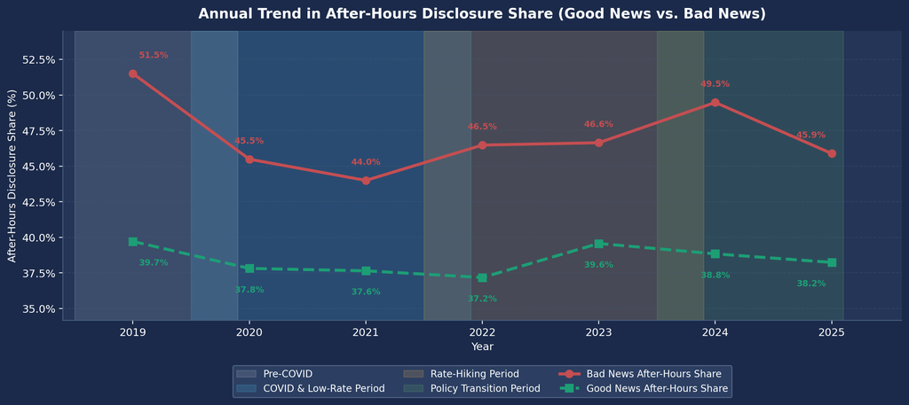

```python
BG_COLOR = "#1B2A4A"

yearly = df_hb.groupby("year").apply(lambda g: pd.Series({
    "total"     : len(g),
    "bad_after" : ((g["news"] == "Bad News") & (g["timing"] == "After-hours")).sum(),
    "good_after": ((g["news"] == "Good News") & (g["timing"] == "After-hours")).sum(),
    "bad_pct"   : ((g["news"] == "Bad News") & (g["timing"] == "After-hours")).sum()
                  / max(g["news"].eq("Bad News").sum(), 1) * 100,
    "good_pct"  : ((g["news"] == "Good News") & (g["timing"] == "After-hours")).sum()
                  / max(g["news"].eq("Good News").sum(), 1) * 100,
})).reset_index()

print("=== Annual After-Hours Disclosure Share ===")

print(
    yearly[["year", "total", "bad_after", "bad_pct", "good_pct"]]
    .round({"bad_pct": 1, "good_pct": 1})
    .to_string(index=False)
)

years = yearly["year"].values

fig, ax = plt.subplots(figsize=(12, 6))

fig.patch.set_facecolor(BG_COLOR)
ax.set_facecolor("#243558")

# ------------------------------------------------------------
# Highlight major market periods
# ------------------------------------------------------------

periods = [
    (2019, 2019.9, "#BFC5D2", "Pre-COVID"),                 # Light gray
    (2020, 2021.9, "#4FC3F7", "COVID & Low-Rate Period"),  # Light cyan
    (2022, 2023.9, "#FFB74D", "Rate-Hiking Period"),       # Orange
    (2024, 2025.1, "#66BB6A", "Policy Transition Period"), # Mint green
]

for x0, x1, color, label in periods:
    ax.axvspan(
        x0 - 0.5,
        x1,
        alpha=0.16,
        color=color,
        label=label,
        zorder=1
    )

# ------------------------------------------------------------
# Line plots
# ------------------------------------------------------------

ax.plot(
    years,
    yearly["bad_pct"],
    "o-",
    color=C_BAD,
    linewidth=2.8,
    markersize=7,
    label="Bad News After-Hours Share",
    zorder=3
)

ax.plot(
    years,
    yearly["good_pct"],
    "s--",
    color=C_GOOD,
    linewidth=2.8,
    markersize=7,
    label="Good News After-Hours Share",
    zorder=3
)

# ------------------------------------------------------------
# Data labels
# ------------------------------------------------------------

for i, row in yearly.iterrows():

    x = row["year"]
    y_bad = row["bad_pct"]
    y_good = row["good_pct"]

    # Adjust alignment for labels at both ends
    if i == 0:
        ha = "left"
        x_offset = 0.05
    elif i == len(yearly) - 1:
        ha = "right"
        x_offset = -0.05
    else:
        ha = "center"
        x_offset = 0

    # Bad News label (above)
    ax.annotate(
        f"{y_bad:.1f}%",
        xy=(x, y_bad),
        xytext=(x + x_offset, y_bad + 1.0),
        textcoords="data",
        ha=ha,
        va="bottom",
        fontsize=8,
        color=C_BAD,
        fontweight="bold",
        zorder=5
    )

    # Good News label (below)
    ax.annotate(
        f"{y_good:.1f}%",
        xy=(x, y_good),
        xytext=(x + x_offset, y_good - 1.2),
        textcoords="data",
        ha=ha,
        va="top",
        fontsize=8,
        color=C_GOOD,
        fontweight="bold",
        zorder=5
    )

# ------------------------------------------------------------
# Axis limits
# ------------------------------------------------------------

y_min = min(
    yearly["bad_pct"].min(),
    yearly["good_pct"].min()
) - 3.0

y_max = max(
    yearly["bad_pct"].max(),
    yearly["good_pct"].max()
) + 3.0

ax.set_ylim(y_min, y_max)

ax.set_xlim(
    years[0] - 0.6,
    years[-1] + 0.6
)

# ------------------------------------------------------------
# Axes and title
# ------------------------------------------------------------

ax.set_xticks(years)

ax.set_xlabel("Year", fontsize=10)

ax.set_ylabel(
    "After-Hours Disclosure Share (%)",
    fontsize=10
)

ax.set_title(
    "Annual Trend in After-Hours Disclosure Share (Good News vs. Bad News)",
    fontsize=13,
    fontweight="bold",
    pad=12
)

ax.yaxis.set_major_formatter(
    mtick.PercentFormatter()
)

# ------------------------------------------------------------
# Remove duplicate legend entries
# ------------------------------------------------------------

handles, labels = ax.get_legend_handles_labels()
unique = dict(zip(labels, handles))

legend = ax.legend(
    unique.values(),
    unique.keys(),

    # Position the legend below the chart
    loc="upper center",
    bbox_to_anchor=(0.5, -0.14),

    fontsize=9,
    ncol=3,
    framealpha=0.75
)

# Improve legend box styling
legend.get_frame().set_facecolor("#32476B")
legend.get_frame().set_edgecolor("#5D7092")

# ------------------------------------------------------------
# Style
# ------------------------------------------------------------

ax.spines[["top", "right"]].set_visible(False)

ax.spines[["left", "bottom"]].set_color("#4A6080")

ax.grid(
    axis="y",
    linestyle="--",
    alpha=0.3,
    color="#4A6080",
    zorder=1
)

# Reserve space for the legend
plt.tight_layout(rect=[0, 0.08, 1, 1])

plt.savefig(
    OUTPUT_DIR / "01_7_yearly_trend.png",
    dpi=150,
    bbox_inches="tight",
    facecolor=BG_COLOR
)

plt.show()
```

## 7.7 Interpretation of the Annual Trend in After-Hours Bad News Disclosures

The annual trend analysis shows that the **After-hours disclosure share of Bad News remained consistently higher than that of Good News throughout the entire 2019–2025 period**.

The After-hours share of Bad News disclosures ranged from approximately **44% to 52%**, whereas the corresponding share for Good News remained relatively stable at approximately **37% to 40%**. The persistent gap between the two groups over the seven-year period suggests that the tendency for Bad News disclosures to occur After-hours may represent a recurring pattern rather than a short-term phenomenon.

Among individual years, **2019 recorded the highest After-hours Bad News share at 51.5%**. However, the 2019 sample contained **783 disclosures**, fewer than in the other years (**1,175–1,393 disclosures**), so the estimate for that year should be interpreted with some caution.

During the **COVID-19 and low-interest-rate period of 2020–2021**, the After-hours Bad News share declined to approximately **44%–46%**. It subsequently increased during and after the **2022–2023 rate-hiking period**, reaching **49.5% in 2024**, the second-highest level observed during the study period. In 2025, the share declined again to **45.9%**.

In contrast, the After-hours share of Good News disclosures remained comparatively stable within the **37%–40% range** throughout the study period. Compared with Bad News disclosures, Good News disclosures exhibited less year-to-year variation. While this pattern could suggest that the timing of Good News disclosures is less sensitive to changing market conditions, the descriptive evidence alone is insufficient to establish such a relationship.

However, the figure alone cannot determine whether the annual variation is attributable to **market volatility, changes in disclosure volume, macroeconomic conditions, or other firm- and market-level factors**. Accordingly, the year-specific patterns should be interpreted descriptively, with potential explanatory factors examined more rigorously through subsequent regression analyses and additional controls.

## 7.8 Analysis ① Summary of Results

## 7.9 Q1. Do Korean Firms Disclose Bad News More Frequently After Market Close?

The results indicate that **Bad News disclosures are relatively more concentrated After-hours**, although the difference between Intraday and After-hours disclosures is limited.

| Test | Result | Conclusion |
| --- | --- | --- |
| Chi-square test | χ² = 63.63, p < 0.001 | Significant association between news type and disclosure timing |
| Kruskal–Wallis test | H = 8.15, p = 0.017 | Significant difference in the distribution of Bad News shares across timing categories |
| Post-hoc test (Pre-market vs. After-hours) | p_adj = 0.017 | Significant difference |
| Post-hoc test (Intraday vs. After-hours) | p_adj = 0.571 | No significant difference |

Most notably, **46.9% of Bad News disclosures occurred After-hours**, compared with **38.4% of Good News disclosures**, representing a difference of approximately **8.5 percentage points**.

The standardized residual analysis from the chi-square test further showed that the **Bad News × After-hours** combination had the largest positive residual (**z = +4.40**), indicating that Bad News disclosures occurred After-hours more frequently than expected under the assumption of independence.

However, the Kruskal–Wallis post-hoc analysis found no statistically significant difference between the Intraday and After-hours categories (**p_adj = 0.571**). Therefore, the results should not be interpreted as showing that Bad News disclosures are overwhelmingly concentrated After-hours. A more appropriate interpretation is that **Bad News disclosures are relatively more prevalent After-hours than Pre-market, while the difference between Intraday and After-hours is not statistically strong in the monthly distribution analysis**.

## 7.10 Hypothesis Testing Results

### 7.10.1 Hypothesis 1. Bad News Disclosures Are Significantly Concentrated After Market Close

> **Partially supported.**

> The chi-square test identified a statistically significant association between Bad News and After-hours disclosure timing. However, the Kruskal–Wallis post-hoc analysis did not identify a statistically significant difference between the Intraday and After-hours categories.

### 7.10.2 Hypothesis 3. The Pattern Is Stronger in KOSDAQ Than in KOSPI

> **Not supported.**

> The Mann–Whitney U test found no statistically significant difference in the After-hours Bad News share between KOSPI and KOSDAQ (**p = 0.229**).

> This suggests that the After-hours Bad News disclosure pattern is not specific to one market segment and appears broadly similar across both markets.

## 7.11 Additional Findings from Exploratory Data Analysis

First, the **Friday After-hours** category recorded a Bad News share of **54.5%**, the highest among all day-of-week × timing combinations. This pattern is directionally similar to the **“Friday evening clustering”** documented in prior research on the U.S. market by Michaely et al. (2016a).

## 7.12 Limitations

First, the classification of Good News and Bad News is based on a **±10% quarter-over-quarter change in operating income**. Therefore, the classification does not incorporate market expectations or analyst consensus measures such as earnings surprises.

Second, DART disclosure timestamps represent the **time at which disclosures were registered in the system**, rather than the time at which the underlying information was generated or the disclosure decision was made. Consequently, the analysis cannot directly establish whether firms strategically delayed or selected their disclosure timing.

Third, the difference between Intraday and After-hours disclosures was statistically weak in some tests. Therefore, disclosure-frequency analysis alone is insufficient to determine whether disclosure timing produces economically meaningful differences in market reactions. The subsequent **Event Study and regression analyses** examine whether disclosure timing is associated with differences in actual stock-market responses.

# 8 Event Study — CAR Calculation

```python
import sys
from pathlib import Path
import numpy as np
import pandas as pd
import matplotlib.pyplot as plt
import matplotlib.ticker as mtick
import matplotlib.font_manager as fm
from scipy import stats
from itertools import combinations
import matplotlib
from matplotlib import rcParams

# ── Output directory
OUTPUT_DIR = Path().resolve() / "outputs"
OUTPUT_DIR.mkdir(parents=True, exist_ok=True)

# ── Font settings
matplotlib.rcParams["font.family"] = "DejaVu Sans"
matplotlib.rcParams["axes.unicode_minus"] = False

# ── Global style
rcParams.update({
    "figure.facecolor" : "#1B2A4A",   # Navy background
    "axes.facecolor"   : "#243558",   # Plot area
    "axes.edgecolor"   : "#4A6080",
    "axes.labelcolor"  : "#FFFFFF",   # White
    "axes.titlecolor"  : "#FFFFFF",   # White
    "xtick.color"      : "#FFFFFF",   # White
    "ytick.color"      : "#FFFFFF",   # White
    "text.color"       : "#FFFFFF",   # White
    "grid.color"       : "#4A6080",
    "grid.linestyle"   : "--",
    "grid.alpha"       : 0.5,
    "font.size"        : 10,
    "axes.titlesize"   : 12,
    "axes.titleweight" : "bold",
    "axes.labelsize"   : 10,
    "legend.framealpha": 0.6,
    "legend.edgecolor" : "#4A6080",
    "legend.facecolor" : "#1B2A4A",
})

# ── Colors
C_GOOD, C_BAD = "#1D9E75", "#C44E52"
C_BEFORE, C_DURING, C_AFTER = "#4C72B0", "#888780", "#C44E52"

# Retain Korean category values used in the source data for processing
TIMING_COLORS = {
    "장전": C_BEFORE,
    "장중": C_DURING,
    "장후": C_AFTER
}

# English labels for visualization
TIMING_LABELS = {
    "장전": "Pre-market",
    "장중": "Intraday",
    "장후": "After-hours"
}

NEWS_LABELS = {
    "호재": "Good News",
    "악재": "Bad News"
}
```

```python
DATA_DIR = resolve_data_dir()

raw_fin  = pd.read_csv(DATA_DIR / "dart_earnings_financials_2019_2026.csv", dtype=str)
raw_ctrl = pd.read_csv(DATA_DIR / "dart_financial_controls_2019_2025.csv")
raw_comp = pd.read_csv(DATA_DIR / "company_krx_fdr_controls_2019_2026.csv")
```

```python
# Filtering
remove = raw_fin["report_nm"].str.contains(
    "전망|기재정정|첨부정정|첨부추가|월별|monthly", na=False, regex=True
)
fin = raw_fin[~remove].copy()
fin["year"] = fin["rcept_dt"].str[:4].astype(int)
fin = fin[fin["year"] <= 2025].copy()

# Remove duplicates, prioritizing consolidated disclosures
fin["is_consolidated"] = fin["report_nm"].str.contains("연결", na=False)
fin = fin.sort_values(
    ["stock_code", "rcept_dt", "is_consolidated", "rcept_no"],
    ascending=[True, True, False, True]
)
fin = fin.drop_duplicates(subset=["stock_code", "rcept_dt"], keep="first")

# Classify disclosure timing
t = fin["rcept_time"].str.split(":", expand=True)
fin["_h"] = pd.to_numeric(t[0], errors="coerce")
fin["_m"] = pd.to_numeric(t[1], errors="coerce")
fin["timing"] = "Intraday"
fin.loc[fin["_h"] < 9, "timing"] = "Pre-market"
fin.loc[(fin["_h"] > 15) | ((fin["_h"] == 15) & (fin["_m"] > 30)), "timing"] = "After-hours"
fin.loc[fin["_h"].isna(), "timing"] = None
fin.drop(columns=["_h", "_m"], inplace=True)
fin["rcept_dt_dt"] = pd.to_datetime(fin["rcept_dt"], format="%Y%m%d")
fin["weekday"] = fin["rcept_dt_dt"].dt.dayofweek

# Classify good and bad news
fin["oi_won"] = pd.to_numeric(fin["operating_income_won"], errors="coerce")
fin = fin.sort_values(["stock_code", "rcept_dt_dt"])
fin["prev_oi"] = fin.groupby("stock_code")["oi_won"].shift(1)
fin["oi_chg_pct"] = np.where(
    fin["prev_oi"].notna() & (fin["prev_oi"] != 0),
    (fin["oi_won"] - fin["prev_oi"]) / fin["prev_oi"].abs(),
    np.nan
)
fin["news"] = np.select(
    [fin["oi_chg_pct"] > 0.10, fin["oi_chg_pct"] < -0.10,
     fin["oi_chg_pct"].between(-0.10, 0.10, inclusive="both")],
    ["Good News", "Bad News", "Neutral"], default="Missing"
)

df = fin.copy()
df_hb = df[df["news"].isin(["Good News", "Bad News"]) & df["timing"].notna()].copy()

print(f"Good News: {df['news'].eq('Good News').sum():,}  Bad News: {df['news'].eq('Bad News').sum():,}")
print(f"Timing: {df['timing'].value_counts().to_dict()}")
```

```
Good News: 4,534  Bad News: 4,030
Timing: {'Intraday': 6362, 'After-hours': 5118, 'Pre-market': 811}
```

### 8.0.1 Preliminary Setup (Trading Calendar + t=0 Date Assignment)

```python
# ════════════════════════════════════════════════════════════════
# Analysis ②: Event Study
# ════════════════════════════════════════════════════════════════
# Estimation window : t = -120 ~ -21 (100 trading days)
# Event window      : t = -1   ~ +5  (7 trading days)
# t=0 definition    : Intraday disclosure   → Disclosure date
# After-hours disclosure → Next trading day
# ════════════════════════════════════════════════════════════════

BG_COLOR = "#1B2A4A"

# ── Load stock price and market index data ─────────────────────
print("Loading stock price data... (this may take some time)")
sp_raw = pd.read_csv(DATA_DIR / "stock_price_2018_2026.csv", low_memory=False)
sp_raw["date"] = pd.to_datetime(sp_raw["date"])
sp_raw["stock_code"] = sp_raw["stock_code"].astype(str).str.zfill(6)

mkt_raw = pd.read_csv(DATA_DIR / "market_index_2018_2026.csv")
mkt_raw["date"] = pd.to_datetime(mkt_raw["date"])

# Separate KOSPI and KOSDAQ indices
kospi_idx = (
    mkt_raw[mkt_raw["index_type"] == "KOSPI"][["date", "change"]]
    .rename(columns={"change": "mkt_ret_kospi"})
)

kosdaq_idx = (
    mkt_raw[mkt_raw["index_type"] == "KOSDAQ"][["date", "change"]]
    .rename(columns={"change": "mkt_ret_kosdaq"})
)

# ── Trading calendar ────────────────────────────────────────────
trading_days = sorted(
    mkt_raw[mkt_raw["index_type"] == "KOSPI"]["date"].unique()
)

td_series = pd.Series(
    range(len(trading_days)),
    index=trading_days
)  # Date → index

print(
    f"Number of trading days: {len(trading_days)} "
    f"({trading_days[0].date()} ~ {trading_days[-1].date()})"
)

def next_trading_day(date):
    """Return the first trading day after the given date."""
    future = [d for d in trading_days if d > date]
    return future[0] if future else None

def get_trading_day_offset(base_date, offset):
    """Return the trading date at the specified offset from base_date."""
    if base_date not in td_series.index:
        return None

    idx = td_series[base_date]
    target_idx = idx + offset

    if 0 <= target_idx < len(trading_days):
        return trading_days[target_idx]

    return None

# ── Assign t=0 event dates ──────────────────────────────────────
# Intraday disclosure    → Disclosure date
# After-hours disclosure → Next trading day
ev = df_hb.copy()
ev["rcept_dt_dt"] = pd.to_datetime(
    ev["rcept_dt"],
    format="%Y%m%d"
)

def set_event_date(row):
    if row["timing"] == "After-hours":
        return next_trading_day(row["rcept_dt_dt"])
    else:
        # Intraday/Pre-market:
        # Use the disclosure date if it is a trading day;
        # otherwise, use the next trading day.
        if row["rcept_dt_dt"] in td_series.index:
            return row["rcept_dt_dt"]

        return next_trading_day(row["rcept_dt_dt"])

ev["event_date"] = ev.apply(set_event_date, axis=1)
ev = ev[ev["event_date"].notna()].copy()

print(f"\nt=0 assignment completed: {len(ev):,} disclosures")
print(
    f"Intraday disclosures with t=0 on the disclosure date: "
    f"{(ev['timing'] == 'Intraday').sum():,}"
)
print(
    f"After-hours disclosures with t=0 on the next trading day: "
    f"{(ev['timing'] == 'After-hours').sum():,}"
)
```

```
Loading stock price data... (this may take some time)
Number of trading days: 1923 (2018-07-02 ~ 2026-04-30)

t=0 assignment completed: 8,551 disclosures
Intraday disclosures with t=0 on the disclosure date: 4,354
After-hours disclosures with t=0 on the next trading day: 3,624
```

### 8.0.2 Market Model Estimation and CAR Calculation

```python
# ── Stock Return Pivot ─────────────────────────────────────────
print("Creating stock return pivot table...")
sp_pivot = sp_raw.pivot(
    index="date",
    columns="stock_code",
    values="change"
)


# ── CAR Calculation Settings ───────────────────────────────────
EST_START = -120   # Estimation window start
EST_END   = -21    # Estimation window end
EVT_START = -1     # Event window start
EVT_END   = +5     # Event window end


# ── CAR Calculation Function ───────────────────────────────────
def calc_car(stock_code, event_date, market):
    """
    Estimate alpha and beta using the Market Model (OLS)
    and return CAR(-1, +5).

    Returns None if the calculation cannot be completed.
    """
    try:
        # Estimation window dates
        est_dates = [
            get_trading_day_offset(event_date, t)
            for t in range(EST_START, EST_END + 1)
        ]
        est_dates = [d for d in est_dates if d is not None]

        # Event window dates
        evt_dates = [
            get_trading_day_offset(event_date, t)
            for t in range(EVT_START, EVT_END + 1)
        ]
        evt_dates = [d for d in evt_dates if d is not None]

        # Require sufficient trading days
        if len(est_dates) < 60 or len(evt_dates) < 5:
            return None

        # Select market index
        if market == "KOSPI":
            mkt_col = "mkt_ret_kospi"
            mkt_idx = kospi_idx.set_index("date")[mkt_col]

        elif market == "KOSDAQ":
            mkt_col = "mkt_ret_kosdaq"
            mkt_idx = kosdaq_idx.set_index("date")[mkt_col]

        else:
            return None

        # Check whether the stock exists in the return pivot table
        if stock_code not in sp_pivot.columns:
            return None

        stock_ret = sp_pivot[stock_code]

        # ── Estimation Window ───────────────────────────────────
        est_stock = stock_ret.reindex(est_dates)
        est_mkt = mkt_idx.reindex(est_dates)

        # Keep dates where both stock and market returns are available
        est_data = pd.concat(
            [est_stock.rename("stock_ret"),
             est_mkt.rename("market_ret")],
            axis=1
        ).dropna()

        if len(est_data) < 60:
            return None

        # Market Model:
        # stock_ret = alpha + beta * market_ret + error
        X = np.column_stack([
            np.ones(len(est_data)),
            est_data["market_ret"].values
        ])

        y = est_data["stock_ret"].values

        coefficients, *_ = np.linalg.lstsq(
            X,
            y,
            rcond=None
        )

        alpha = coefficients[0]
        beta = coefficients[1]

        # ── Event Window ────────────────────────────────────────
        evt_stock = stock_ret.reindex(evt_dates)
        evt_mkt = mkt_idx.reindex(evt_dates)

        evt_data = pd.concat(
            [evt_stock.rename("stock_ret"),
             evt_mkt.rename("market_ret")],
            axis=1
        )

        # Expected return based on the estimated Market Model
        expected_ret = (
            alpha
            + beta * evt_data["market_ret"]
        )

        # Abnormal Return (AR)
        evt_data["AR"] = (
            evt_data["stock_ret"]
            - expected_ret
        )

        # Require at least 5 valid observations in the event window
        valid_ar = evt_data["AR"].dropna()

        if len(valid_ar) < 5:
            return None

        # Cumulative Abnormal Return (CAR)
        car = valid_ar.sum()

        if np.isnan(car):
            return None

        return car

    except Exception:
        return None


# ── Calculate CAR for All Events ───────────────────────────────
print("Calculating CAR... (may take several minutes)")

cars = []
total = len(ev)

for i, (_, row) in enumerate(ev.iterrows()):

    if i % 500 == 0:
        print(
            f"  Progress: {i:,}/{total:,} "
            f"({i / total * 100:.1f}%)"
        )

    car = calc_car(
        stock_code=str(row["stock_code"]).zfill(6),
        event_date=row["event_date"],
        market=row["market"]
    )

    cars.append(car)


# ── Store CAR Results ───────────────────────────────────────────
ev["CAR"] = cars

ev_clean = (
    ev[ev["CAR"].notna()]
    .copy()
)


# ── Check Category Values ──────────────────────────────────────
print("\nNews categories:")
print(ev_clean["news"].value_counts(dropna=False))

print("\nTiming categories:")
print(ev_clean["timing"].value_counts(dropna=False))


# ── CAR Sample Counts ──────────────────────────────────────────
print(
    f"\nCAR calculation complete: "
    f"{len(ev_clean):,} observations / "
    f"{len(ev):,} total"
)


# Count observations by news type and disclosure timing
group_counts = (
    ev_clean
    .groupby(["news", "timing"])
    .size()
)


# Main four groups used in the analysis
groups = [
    ("Good News", "Intraday"),
    ("Good News", "After-hours"),
    ("Bad News", "Intraday"),
    ("Bad News", "After-hours")
]


for news, timing in groups:
    count = group_counts.get(
        (news, timing),
        0
    )

    print(
        f"  {news} - {timing}: "
        f"{count:,}"
    )


# ── Four-Group Analysis Sample ─────────────────────────────────
analysis_sample = ev_clean[
    ev_clean["news"].isin([
        "Good News",
        "Bad News"
    ])
    &
    ev_clean["timing"].isin([
        "Intraday",
        "After-hours"
    ])
].copy()


print(
    f"\nFour-group analysis sample: "
    f"{len(analysis_sample):,} observations"
)

print(
    f"Excluded from the four-group comparison: "
    f"{len(ev_clean) - len(analysis_sample):,} observations"
)
```

```
Creating stock return pivot table...
Calculating CAR... (may take several minutes)
  Progress: 0/8,551 (0.0%)
  Progress: 500/8,551 (5.8%)
  Progress: 1,000/8,551 (11.7%)
  Progress: 1,500/8,551 (17.5%)
  Progress: 2,000/8,551 (23.4%)
  Progress: 2,500/8,551 (29.2%)
  Progress: 3,000/8,551 (35.1%)
  Progress: 3,500/8,551 (40.9%)
  Progress: 4,000/8,551 (46.8%)
  Progress: 4,500/8,551 (52.6%)
  Progress: 5,000/8,551 (58.5%)
  Progress: 5,500/8,551 (64.3%)
  Progress: 6,000/8,551 (70.2%)
  Progress: 6,500/8,551 (76.0%)
  Progress: 7,000/8,551 (81.9%)
  Progress: 7,500/8,551 (87.7%)
  Progress: 8,000/8,551 (93.6%)
  Progress: 8,500/8,551 (99.4%)

News categories:
news
Good News    4517
Bad News     4022
Name: count, dtype: int64

Timing categories:
timing
Intraday       4346
After-hours    3621
Pre-market      572
Name: count, dtype: int64

CAR calculation complete: 8,539 observations / 8,551 total
  Good News - Intraday: 2,454
  Good News - After-hours: 1,734
  Bad News - Intraday: 1,892
  Bad News - After-hours: 1,887

Four-group analysis sample: 7,967 observations
Excluded from the four-group comparison: 572 observations
```

### 8.0.3 CAR Distribution Visualization and Statistical Tests

```
=== CAR Summary Statistics by Group ===
Good News - Intraday     : Mean 1.78%  Median 0.97%  n=2,454  t=9.43  p=0.0000  *** (p<0.001)
Good News - After-hours  : Mean 1.17%  Median 0.51%  n=1,734  t=5.54  p=0.0000  *** (p<0.001)
Bad News - Intraday      : Mean -1.24%  Median -1.35%  n=1,892  t=-6.67  p=0.0000  *** (p<0.001)
Bad News - After-hours   : Mean -1.75%  Median -1.71%  n=1,887  t=-9.61  p=0.0000  *** (p<0.001)

Bad News - Intraday vs Bad News - After-hours (Mann-Whitney U test)
U=1853130.0,  p=0.042506  * (p<0.05)
```

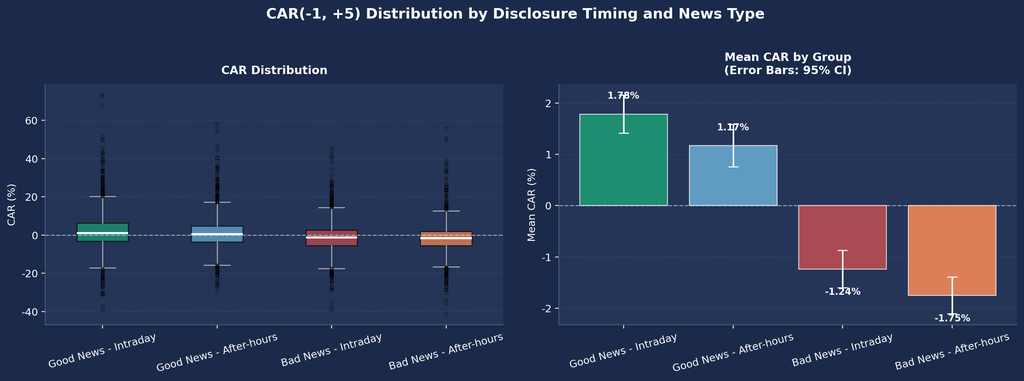

```python
# ── Significance Label Function ────────────────────────────────
def sig_label(p):
    if p < 0.001:
        return "*** (p<0.001)"
    elif p < 0.01:
        return "** (p<0.01)"
    elif p < 0.05:
        return "* (p<0.05)"
    else:
        return "n.s."


# ── Visualization Settings ─────────────────────────────────────
BG_COLOR = "#1B2A4A"


# ── Define Four Groups ─────────────────────────────────────────
conditions = {
    "Good News - Intraday": ev_clean[
        (ev_clean["news"] == "Good News") &
        (ev_clean["timing"] == "Intraday")
    ]["CAR"],

    "Good News - After-hours": ev_clean[
        (ev_clean["news"] == "Good News") &
        (ev_clean["timing"] == "After-hours")
    ]["CAR"],

    "Bad News - Intraday": ev_clean[
        (ev_clean["news"] == "Bad News") &
        (ev_clean["timing"] == "Intraday")
    ]["CAR"],

    "Bad News - After-hours": ev_clean[
        (ev_clean["news"] == "Bad News") &
        (ev_clean["timing"] == "After-hours")
    ]["CAR"],
}


# ── Summary Statistics ─────────────────────────────────────────
print("=== CAR Summary Statistics by Group ===")

for label, car in conditions.items():
    car_clean = car.dropna()

    t_stat, p_val = stats.ttest_1samp(
        car_clean,
        0
    )

    print(
        f"{label:25s}: "
        f"Mean {car_clean.mean() * 100:.2f}%  "
        f"Median {car_clean.median() * 100:.2f}%  "
        f"n={len(car_clean):,}  "
        f"t={t_stat:.2f}  "
        f"p={p_val:.4f}  "
        f"{sig_label(p_val)}"
    )


# ── Main Comparison: Bad News Intraday vs After-hours ─────────
u_stat, p_mw = stats.mannwhitneyu(
    conditions["Bad News - Intraday"].dropna(),
    conditions["Bad News - After-hours"].dropna(),
    alternative="two-sided"
)

print(
    "\nBad News - Intraday vs Bad News - After-hours "
    "(Mann-Whitney U test)"
)

print(
    f"U={u_stat:.1f},  "
    f"p={p_mw:.6f}  "
    f"{sig_label(p_mw)}"
)


# ── Visualization ──────────────────────────────────────────────
fig, axes = plt.subplots(
    1,
    2,
    figsize=(14, 5)
)

fig.patch.set_facecolor(BG_COLOR)

fig.suptitle(
    "CAR(-1, +5) Distribution by Disclosure Timing and News Type",
    fontsize=14,
    fontweight="bold",
    color="#FFFFFF",
    y=1.02
)


# ── Group Colors ───────────────────────────────────────────────
COND_COLORS = {
    "Good News - Intraday": "#1D9E75",
    "Good News - After-hours": "#6BAED6",
    "Bad News - Intraday": "#C44E52",
    "Bad News - After-hours": "#FC8D59",
}


# ── Left Panel: Box Plot ───────────────────────────────────────
ax = axes[0]
ax.set_facecolor("#243558")

bp = ax.boxplot(
    [
        c.dropna() * 100
        for c in conditions.values()
    ],
    tick_labels=list(conditions.keys()),
    patch_artist=True,
    medianprops=dict(
        color="#FFFFFF",
        linewidth=2
    ),
    whiskerprops=dict(
        color="#AAAAAA",
        linewidth=1
    ),
    capprops=dict(
        color="#AAAAAA",
        linewidth=1
    ),
    flierprops=dict(
        marker="o",
        markersize=3,
        alpha=0.3
    )
)

for patch, color in zip(
    bp["boxes"],
    COND_COLORS.values()
):
    patch.set_facecolor(color)
    patch.set_alpha(0.7)


ax.axhline(
    y=0,
    color="#FFFFFF",
    linewidth=1,
    linestyle="--",
    alpha=0.5
)

ax.set_ylabel(
    "CAR (%)",
    fontsize=10
)

ax.set_title(
    "CAR Distribution",
    fontsize=11,
    fontweight="bold",
    pad=10
)

ax.spines[["top", "right"]].set_visible(False)

ax.spines[
    ["left", "bottom"]
].set_color("#4A6080")

ax.grid(
    axis="y",
    linestyle="--",
    alpha=0.3,
    color="#4A6080"
)

ax.tick_params(
    axis="x",
    rotation=15
)


# ── Right Panel: Mean CAR Bar Chart ────────────────────────────
ax = axes[1]
ax.set_facecolor("#243558")

labels = list(
    conditions.keys()
)

means = [
    c.dropna().mean() * 100
    for c in conditions.values()
]

colors = [
    COND_COLORS[label]
    for label in labels
]

cis = [
    1.96
    * c.dropna().std()
    / np.sqrt(len(c.dropna()))
    * 100
    for c in conditions.values()
]


bars = ax.bar(
    labels,
    means,
    color=colors,
    alpha=0.85,
    edgecolor="white",
    linewidth=0.8,
    zorder=3
)


ax.errorbar(
    labels,
    means,
    yerr=cis,
    fmt="none",
    color="#FFFFFF",
    capsize=5,
    linewidth=1.5,
    zorder=4
)


for bar, mean in zip(
    bars,
    means
):
    offset = (
        0.3
        if mean >= 0
        else -0.5
    )

    ax.text(
        bar.get_x()
        + bar.get_width() / 2,
        mean + offset,
        f"{mean:.2f}%",
        ha="center",
        fontsize=9,
        fontweight="bold"
    )


ax.axhline(
    y=0,
    color="#FFFFFF",
    linewidth=1,
    linestyle="--",
    alpha=0.5
)

ax.set_ylabel(
    "Mean CAR (%)",
    fontsize=10
)

ax.set_title(
    "Mean CAR by Group\n"
    "(Error Bars: 95% CI)",
    fontsize=11,
    fontweight="bold",
    pad=10
)

ax.spines[["top", "right"]].set_visible(False)

ax.spines[
    ["left", "bottom"]
].set_color("#4A6080")

ax.grid(
    axis="y",
    linestyle="--",
    alpha=0.3,
    color="#4A6080",
    zorder=1
)

ax.tick_params(
    axis="x",
    rotation=15
)


# ── Save Figure ────────────────────────────────────────────────
plt.tight_layout()

output_path = (
    OUTPUT_DIR
    / "02_1_car_distribution.png"
)

plt.savefig(
    output_path,
    dpi=150,
    bbox_inches="tight",
    facecolor=BG_COLOR
)

plt.show()
```

## 8.1 Interpretation of CAR Distribution Comparisons

The analysis shows that the mean CAR was statistically significant across all four disclosure categories (p < 0.001). Overall, good-news disclosures exhibited positive CARs, whereas bad-news disclosures exhibited negative CARs, indicating that the market model used in the event study produced results consistent with the direction of the disclosed information.

| Condition | Mean CAR | Significance |
| --- | --- | --- |
| Good News – Intraday | +1.78% | *** |
| Good News – After-hours | +1.17% | *** |
| Bad News – Intraday | -1.24% | *** |
| Bad News – After-hours | -1.75% | *** |

The key result is the comparison between intraday and after-hours bad-news disclosures.

The mean CAR for after-hours bad-news disclosures was **-1.75%**, approximately **0.51 percentage points lower** than the **-1.24%** observed for intraday bad-news disclosures. The difference between the two groups was also statistically significant (**p = 0.043**).

In other words, bad news disclosed after market hours was associated, on average, with a larger negative market reaction than bad news disclosed during trading hours.

This result is somewhat contrary to the intuition that after-hours disclosure may mitigate short-term stock-price shocks. Instead, after-hours bad-news disclosures were associated with more negative CARs. Two possible explanations can be considered.

First, there may be **selection bias**. Bad news disclosed after hours may contain more severe negative information than bad news disclosed during trading hours. In this case, the observed difference in CARs may be attributable to the severity of the negative information rather than to the timing of disclosure itself.

Second, a **price concentration effect** may exist. Because information released after market close cannot be immediately incorporated into prices through regular trading, the market response may become concentrated at the next trading day’s opening or during the early trading session. Under this mechanism, after-hours disclosure could be associated with greater short-term price movements rather than mitigating them.

Regardless of which explanation is more appropriate, the results provide **no evidence that after-hours disclosure serves to mitigate short-term stock-price shocks**.

However, several caveats should be considered when interpreting these findings.

First, the p-value for the difference between intraday and after-hours bad-news disclosures was **0.043**, which is relatively close to the conventional 5% significance threshold. Therefore, the result should be interpreted as **statistically significant but relatively marginal**, rather than as evidence of a strong or highly robust effect.

Second, the current analysis does not control for the **severity of bad news**, measured by the decline in operating profit. Consequently, the comparison may be subject to selection bias. Subsequent regression analysis should therefore re-examine the association between after-hours disclosure and abnormal returns while controlling for bad-news severity and firm-specific characteristics.

### 8.1.1 Cumulative CAR Trend (t = -1 to +5)

```
Current values in ev_clean:
news   : <StringArray>
['Good News', 'Bad News']
Length: 2, dtype: str
timing : <StringArray>
['Intraday', 'After-hours', 'Pre-market']
Length: 3, dtype: str

Normalized values:
news   : _news_norm
good    4517
bad     4022
Name: count, dtype: int64
timing : _timing_norm
intraday      4346
afterhours    3621
NaN            572
Name: count, dtype: int64

Calculating daily AR series...

Number of valid AR series:
Good News - Intraday     : n = 2,454
Good News - After-hours  : n = 1,734
Bad News - Intraday      : n = 1,892
Bad News - After-hours   : n = 1,887
```

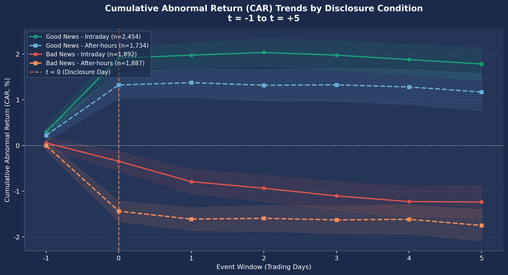

```python
BG_COLOR = "#1B2A4A"

# ============================================================
# Recalculate AR for each event-window day
# ============================================================
def calc_ar_series(stock_code, event_date, market):
    """Return daily AR series over the event window (EVT_START ~ EVT_END)."""
    try:
        est_dates = [
            get_trading_day_offset(event_date, t)
            for t in range(EST_START, EST_END + 1)
        ]
        est_dates = [d for d in est_dates if d is not None]

        evt_dates = [
            get_trading_day_offset(event_date, t)
            for t in range(EVT_START, EVT_END + 1)
        ]
        evt_dates = [d for d in evt_dates if d is not None]

        if len(est_dates) < 60 or len(evt_dates) < 5:
            return None

        mkt_col = (
            "mkt_ret_kospi"
            if market == "KOSPI"
            else "mkt_ret_kosdaq"
        )

        mkt_idx = (
            kospi_idx if market == "KOSPI" else kosdaq_idx
        ).set_index("date")[mkt_col]

        if stock_code not in sp_pivot.columns:
            return None

        stock_ret = sp_pivot[stock_code]

        # Estimation window
        est_stock = stock_ret.reindex(est_dates).dropna()
        est_mkt = mkt_idx.reindex(est_stock.index).dropna()
        est_stock = est_stock.reindex(est_mkt.index)

        if len(est_stock) < 60:
            return None

        # Market Model
        X = np.column_stack([
            np.ones(len(est_mkt)),
            est_mkt.values
        ])

        beta, *_ = np.linalg.lstsq(
            X,
            est_stock.values,
            rcond=None
        )

        alpha, b = beta[0], beta[1]

        # Event-window returns
        evt_stock = stock_ret.reindex(evt_dates).values
        evt_mkt = mkt_idx.reindex(evt_dates).values

        # Abnormal Return
        ar = evt_stock - (alpha + b * evt_mkt)

        return ar

    except Exception:
        return None


# ============================================================
# Event window
# ============================================================
t_range = list(range(EVT_START, EVT_END + 1))


# ============================================================
# Check actual values in the current dataset
# ============================================================
print("Current values in ev_clean:")
print("news   :", ev_clean["news"].dropna().unique())
print("timing :", ev_clean["timing"].dropna().unique())


# ============================================================
# Normalize Korean / English labels
# ============================================================
NEWS_MAP = {
    "호재": "good",
    "Good News": "good",
    "good": "good",
    "GOOD": "good",

    "악재": "bad",
    "Bad News": "bad",
    "bad": "bad",
    "BAD": "bad",
}

TIMING_MAP = {
    "장중": "intraday",
    "Intraday": "intraday",
    "intraday": "intraday",

    "장후": "afterhours",
    "장후 ": "afterhours",
    "After-hours": "afterhours",
    "After Hours": "afterhours",
    "After-hours ": "afterhours",
    "after-hours": "afterhours",
    "afterhours": "afterhours",
}


def normalize_news(value):
    if pd.isna(value):
        return None

    value = str(value).strip()

    return NEWS_MAP.get(value)


def normalize_timing(value):
    if pd.isna(value):
        return None

    value = str(value).strip()

    return TIMING_MAP.get(value)


# Temporary normalized columns
ev_clean = ev_clean.copy()

ev_clean["_news_norm"] = ev_clean["news"].apply(normalize_news)
ev_clean["_timing_norm"] = ev_clean["timing"].apply(normalize_timing)


print("\nNormalized values:")
print("news   :", ev_clean["_news_norm"].value_counts(dropna=False))
print("timing :", ev_clean["_timing_norm"].value_counts(dropna=False))


# ============================================================
# Disclosure conditions
# ============================================================
cond_map = {
    "good_intraday": ("good", "intraday"),
    "good_afterhours": ("good", "afterhours"),
    "bad_intraday": ("bad", "intraday"),
    "bad_afterhours": ("bad", "afterhours"),
}


# ============================================================
# English display labels
# ============================================================
LABEL_EN = {
    "good_intraday": "Good News - Intraday",
    "good_afterhours": "Good News - After-hours",
    "bad_intraday": "Bad News - Intraday",
    "bad_afterhours": "Bad News - After-hours",
}


# ============================================================
# Plot colors
# Use the established chart color structure
# ============================================================
PLOT_COLORS = {
    "good_intraday": "#1B9E77",
    "good_afterhours": "#6BAED6",
    "bad_intraday": "#D9534F",
    "bad_afterhours": "#FC8D59",
}


# ============================================================
# Calculate daily AR series by condition
# ============================================================
print("\nCalculating daily AR series...")

cond_ar = {key: [] for key in cond_map}


for _, row in ev_clean.iterrows():

    news_norm = row["_news_norm"]
    timing_norm = row["_timing_norm"]

    for label, (news, timing) in cond_map.items():

        if news_norm == news and timing_norm == timing:

            ar_series = calc_ar_series(
                str(row["stock_code"]).zfill(6),
                row["event_date"],
                row["market"]
            )

            if (
                ar_series is not None
                and len(ar_series) == len(t_range)
            ):
                cond_ar[label].append(ar_series)


# ============================================================
# Check sample sizes
# ============================================================
print("\nNumber of valid AR series:")

for label in cond_map:
    print(
        f"{LABEL_EN[label]:25s}: "
        f"n = {len(cond_ar[label]):,}"
    )


# ============================================================
# Plot CAR trends
# ============================================================
fig, ax = plt.subplots(figsize=(11, 6))

fig.patch.set_facecolor(BG_COLOR)
ax.set_facecolor("#243558")


for label in cond_map:

    arr = np.array(cond_ar[label])

    if len(arr) == 0:
        print(f"Warning: No observations for {LABEL_EN[label]}")
        continue

    color = PLOT_COLORS[label]

    # Mean daily AR
    mean_ar = np.nanmean(arr, axis=0)

    # Cumulative abnormal return
    cum_ar = np.cumsum(mean_ar) * 100

    # Standard error
    se = (
        np.nanstd(arr, axis=0)
        / np.sqrt(len(arr))
        * 100
    )

    # Approximate cumulative standard error
    cum_se = np.sqrt(np.cumsum(se ** 2))

    # Intraday = solid line + circle
    # After-hours = dashed line + square
    style = "-o" if "intraday" in label else "--s"

    ax.plot(
        t_range,
        cum_ar,
        style,
        color=color,
        linewidth=2,
        markersize=5,
        label=f"{LABEL_EN[label]} (n={len(arr):,})",
        zorder=3
    )

    ax.fill_between(
        t_range,
        cum_ar - 1.96 * cum_se,
        cum_ar + 1.96 * cum_se,
        color=color,
        alpha=0.12,
        zorder=2
    )


# ============================================================
# Reference lines
# ============================================================
ax.axhline(
    y=0,
    color="#FFFFFF",
    linewidth=1,
    linestyle="--",
    alpha=0.4
)

ax.axvline(
    x=0,
    color="#FC8D59",
    linewidth=1.5,
    linestyle="--",
    alpha=0.8,
    label="t = 0 (Disclosure Day)"
)


# ============================================================
# English labels
# ============================================================
ax.set_xlabel(
    "Event Window (Trading Days)",
    fontsize=10
)

ax.set_ylabel(
    "Cumulative Abnormal Return (CAR, %)",
    fontsize=10
)

ax.set_title(
    "Cumulative Abnormal Return (CAR) Trends by Disclosure Condition\n"
    "t = -1 to t = +5",
    fontsize=13,
    fontweight="bold",
    pad=12
)


# ============================================================
# Formatting
# ============================================================
ax.set_xticks(t_range)

ax.legend(
    fontsize=9,
    loc="upper left"
)

ax.spines[["top", "right"]].set_visible(False)
ax.spines[["left", "bottom"]].set_color("#4A6080")

ax.grid(
    axis="y",
    linestyle="--",
    alpha=0.3,
    color="#4A6080",
    zorder=1
)


# ============================================================
# Save and display
# ============================================================
plt.tight_layout()

plt.savefig(
    OUTPUT_DIR / "02_2_car_trend.png",
    dpi=150,
    bbox_inches="tight",
    facecolor=BG_COLOR
)

plt.show()
```

## 8.2 Interpretation of Cumulative CAR Trends

### 8.2.1 Good-News Disclosure Patterns

Good-news disclosures generally exhibited positive CAR trends.

Good News - Intraday showed the largest increase around t=0. The CAR remained positive throughout the subsequent t=+1 to t=+5 period, ultimately remaining at approximately +2%.

Good News - After-hours also exhibited a positive market reaction, but the magnitude was smaller than that of intraday disclosures. The CAR increased to approximately +1.3% around t=0 and remained relatively stable thereafter.

### 8.2.2 Bad-News Disclosure Patterns

Bad-news disclosures generally exhibited negative CAR trends.

Bad News - Intraday began to decline around t=0, followed by a gradual additional decrease over the t=+1 to t=+5 period. By the end of the event window, the CAR reached approximately -1.2%.

In contrast, Bad News - After-hours exhibited the strongest negative reaction. The CAR fell sharply to approximately -1.4% around t=0 and declined further over the subsequent event window, ultimately reaching approximately -1.75%.

### 8.2.3 Key Observations

The most notable pattern is the sharp and concentrated price reaction to after-hours bad-news disclosures around t=0.

This pattern is consistent with a mechanism in which investors process information released after market close during non-trading hours, with the resulting price adjustment concentrated at the opening or early trading period of the next trading day. Thus, rather than delaying the incorporation of information into prices, after-hours disclosure may be associated with a more concentrated price adjustment.

In contrast, Bad News - Intraday exhibited a more gradual decline following the initial reaction, with additional decreases continuing through approximately t=+1 to t=+3. This pattern suggests that the processing and incorporation of information released during trading hours may be relatively more dispersed over time.

### 8.2.4 Overall Interpretation

Overall, after-hours disclosure was associated with a pattern in which price reactions were concentrated around t=0 rather than with an attenuation of short-term stock-price shocks.

### 8.2.5 Limitations

Several limitations should be considered when interpreting these results.

First, the confidence bands around the cumulative CAR trends are relatively wide, indicating substantial variation across individual disclosure events. Therefore, the average CAR patterns should not be interpreted as applying uniformly to all events.

Second, the current analysis does not control for the severity of bad news, measured by the decline in operating profit. Consequently, it is difficult to distinguish the effect associated with after-hours disclosure itself from differences in the severity of the disclosed information.

Subsequent regression analysis should therefore re-examine the relationship between after-hours disclosure and abnormal returns while controlling for bad-news severity and firm-specific characteristics.

# 9 Regression Analysis: Disclosure Timing Choice and Stock-Price Effects

```python
import sys
from pathlib import Path
import numpy as np
import pandas as pd
import matplotlib.pyplot as plt
import matplotlib.ticker as mtick
import matplotlib.font_manager as fm
from scipy import stats
from itertools import combinations
import matplotlib
from matplotlib import rcParams

# ── Output directory
OUTPUT_DIR = Path().resolve() / "outputs"
OUTPUT_DIR.mkdir(parents=True, exist_ok=True)

# ── Font settings
matplotlib.rcParams["font.family"] = "DejaVu Sans"
matplotlib.rcParams["axes.unicode_minus"] = False

# ── Global style
rcParams.update({
    "figure.facecolor" : "#1B2A4A",   # Navy background
    "axes.facecolor"   : "#243558",   # Plot area
    "axes.edgecolor"   : "#4A6080",
    "axes.labelcolor"  : "#FFFFFF",   # White
    "axes.titlecolor"  : "#FFFFFF",   # White
    "xtick.color"      : "#FFFFFF",   # White
    "ytick.color"      : "#FFFFFF",   # White
    "text.color"       : "#FFFFFF",   # White
    "grid.color"       : "#4A6080",
    "grid.linestyle"   : "--",
    "grid.alpha"       : 0.5,
    "font.size"        : 10,
    "axes.titlesize"   : 12,
    "axes.titleweight" : "bold",
    "axes.labelsize"   : 10,
    "legend.framealpha": 0.6,
    "legend.edgecolor" : "#4A6080",
    "legend.facecolor" : "#1B2A4A",
})

# ── Colors
C_GOOD, C_BAD = "#1D9E75", "#C44E52"
C_BEFORE, C_DURING, C_AFTER = "#4C72B0", "#888780", "#C44E52"

# Retain Korean category values used in the source data for processing
TIMING_COLORS = {
    "장전": C_BEFORE,
    "장중": C_DURING,
    "장후": C_AFTER
}

# English labels for visualization
TIMING_LABELS = {
    "장전": "Pre-market",
    "장중": "Intraday",
    "장후": "After-hours"
}

NEWS_LABELS = {
    "호재": "Good News",
    "악재": "Bad News"
}
```

```python
DATA_DIR = resolve_data_dir()

raw_fin  = pd.read_csv(DATA_DIR / "dart_earnings_financials_2019_2026.csv", dtype=str)
raw_ctrl = pd.read_csv(DATA_DIR / "dart_financial_controls_2019_2025.csv")
raw_comp = pd.read_csv(DATA_DIR / "company_krx_fdr_controls_2019_2026.csv")
```

```python
# Filtering
remove = raw_fin["report_nm"].str.contains(
    "전망|기재정정|첨부정정|첨부추가|월별|monthly", na=False, regex=True
)
fin = raw_fin[~remove].copy()
fin["year"] = fin["rcept_dt"].str[:4].astype(int)
fin = fin[fin["year"] <= 2025].copy()

# Remove duplicates, prioritizing consolidated disclosures
fin["is_consolidated"] = fin["report_nm"].str.contains("연결", na=False)
fin = fin.sort_values(
    ["stock_code", "rcept_dt", "is_consolidated", "rcept_no"],
    ascending=[True, True, False, True]
)
fin = fin.drop_duplicates(subset=["stock_code", "rcept_dt"], keep="first")

# Classify disclosure timing
t = fin["rcept_time"].str.split(":", expand=True)
fin["_h"] = pd.to_numeric(t[0], errors="coerce")
fin["_m"] = pd.to_numeric(t[1], errors="coerce")
fin["timing"] = "Intraday"
fin.loc[fin["_h"] < 9, "timing"] = "Pre-market"
fin.loc[(fin["_h"] > 15) | ((fin["_h"] == 15) & (fin["_m"] > 30)), "timing"] = "After-hours"
fin.loc[fin["_h"].isna(), "timing"] = None
fin.drop(columns=["_h", "_m"], inplace=True)
fin["rcept_dt_dt"] = pd.to_datetime(fin["rcept_dt"], format="%Y%m%d")
fin["weekday"] = fin["rcept_dt_dt"].dt.dayofweek

# Classify good and bad news
fin["oi_won"] = pd.to_numeric(fin["operating_income_won"], errors="coerce")
fin = fin.sort_values(["stock_code", "rcept_dt_dt"])
fin["prev_oi"] = fin.groupby("stock_code")["oi_won"].shift(1)
fin["oi_chg_pct"] = np.where(
    fin["prev_oi"].notna() & (fin["prev_oi"] != 0),
    (fin["oi_won"] - fin["prev_oi"]) / fin["prev_oi"].abs(),
    np.nan
)
fin["news"] = np.select(
    [fin["oi_chg_pct"] > 0.10, fin["oi_chg_pct"] < -0.10,
     fin["oi_chg_pct"].between(-0.10, 0.10, inclusive="both")],
    ["Good News", "Bad News", "Neutral"], default="Missing"
)

df = fin.copy()
df_hb = df[df["news"].isin(["Good News", "Bad News"]) & df["timing"].notna()].copy()

print(f"Good News: {df['news'].eq('Good News').sum():,}  Bad News: {df['news'].eq('Bad News').sum():,}")
print(f"Timing: {df['timing'].value_counts().to_dict()}")
```

```
Good News: 4,534  Bad News: 4,030
Timing: {'Intraday': 6362, 'After-hours': 5118, 'Pre-market': 811}
```

### 9.0.1 Two-Stage Regression Analysis: Stage 1 Logistic Regression (Timing Choice Model) + Stage 2 OLS Regression

```python
# ============================================================
# Two-Stage Regression Analysis
# - Stage 1: Logistic Regression for After-Hours Disclosure Choice
# - CAR Calculation: Market Model
# - Stage 2: OLS Regression for CAR
# ============================================================

import numpy as np
import pandas as pd
import matplotlib.pyplot as plt

from sklearn.preprocessing import StandardScaler
from sklearn.linear_model import LogisticRegression
import statsmodels.api as sm
import statsmodels.formula.api as smf


# ------------------------------------------------------------
# Load Price and Market Data
# ------------------------------------------------------------

price_df = pd.read_csv(
    DATA_DIR / "stock_price_2018_2026.csv",
    low_memory=False
)

market_df = pd.read_csv(
    DATA_DIR / "market_index_2018_2026.csv"
)

price_df["date"] = pd.to_datetime(price_df["date"])
market_df["date"] = pd.to_datetime(market_df["date"])

price_df["stock_code"] = (
    price_df["stock_code"]
    .astype(str)
    .str.zfill(6)
)


# ------------------------------------------------------------
# Construct Regression Dataset
# ------------------------------------------------------------

# Keep only Intraday and After-hours disclosures
reg_df = df_hb[
    df_hb["timing"].isin(["Intraday", "After-hours"])
].copy()

reg_df["stock_code"] = (
    reg_df["stock_code"]
    .astype(str)
    .str.zfill(6)
)

reg_df["rcept_dt"] = reg_df["rcept_dt"].astype(str)

reg_df["rcept_dt_dt"] = pd.to_datetime(
    reg_df["rcept_dt"],
    format="%Y%m%d"
)

# Binary variables
reg_df["after_dummy"] = (
    reg_df["timing"] == "After-hours"
).astype(int)

reg_df["bad_dummy"] = (
    reg_df["news"] == "Bad News"
).astype(int)

# Severity of bad news
reg_df["bad_severity"] = np.where(
    reg_df["oi_chg_pct"] < -0.10,
    reg_df["oi_chg_pct"].abs(),
    0
)

# Friday dummy
reg_df["fri_dummy"] = (
    reg_df["weekday"] == 4
).astype(int)


print("=== Regression Sample Check ===")
print(f"Observations: {len(reg_df):,}")
print("\nTiming distribution:")
print(reg_df["timing"].value_counts())
print("\nNews distribution:")
print(reg_df["news"].value_counts())


# ------------------------------------------------------------
# Merge KRX Control Variables
# ------------------------------------------------------------

raw_comp2 = raw_comp.copy()

raw_comp2["stock_code"] = (
    raw_comp2["stock_code"]
    .astype(str)
    .str.zfill(6)
)

# KOSDAQ dummy
if "is_kosdaq" not in raw_comp2.columns:
    raw_comp2["is_kosdaq"] = (
        raw_comp2["market"]
        .astype(str)
        .str.upper()
        .str.contains("KOSDAQ|코스닥", na=False)
        .astype(int)
    )

# Log market capitalization
if "log_marcap" not in raw_comp2.columns:

    raw_comp2["marcap"] = pd.to_numeric(
        raw_comp2["marcap"],
        errors="coerce"
    )

    raw_comp2["log_marcap"] = np.log(
        raw_comp2["marcap"]
    )


reg_df = reg_df.merge(
    raw_comp2[
        [
            "stock_code",
            "is_kosdaq",
            "log_marcap"
        ]
    ].drop_duplicates("stock_code"),
    on="stock_code",
    how="left"
)


# ------------------------------------------------------------
# Merge Financial Control Variables
# ------------------------------------------------------------

raw_ctrl2 = raw_ctrl.copy()

raw_ctrl2["stock_code"] = (
    raw_ctrl2["stock_code"]
    .astype(str)
    .str.zfill(6)
)

raw_ctrl2["year"] = pd.to_numeric(
    raw_ctrl2["year"],
    errors="coerce"
)

reg_df["year"] = pd.to_numeric(
    reg_df["year"],
    errors="coerce"
)


reg_df = reg_df.merge(
    raw_ctrl2[
        [
            "stock_code",
            "year",
            "roa",
            "debt_ratio"
        ]
    ].drop_duplicates(
        ["stock_code", "year"]
    ),
    on=["stock_code", "year"],
    how="left"
)


# Convert control variables to numeric
numeric_cols = [
    "is_kosdaq",
    "log_marcap",
    "roa",
    "debt_ratio",
    "bad_severity"
]

for c in numeric_cols:
    reg_df[c] = pd.to_numeric(
        reg_df[c],
        errors="coerce"
    )


# Handle missing values
reg_df["is_kosdaq"] = (
    reg_df["is_kosdaq"]
    .fillna(0)
)

reg_df["log_marcap"] = (
    reg_df["log_marcap"]
    .fillna(
        reg_df["log_marcap"].median()
    )
)

reg_df["roa"] = (
    reg_df["roa"]
    .fillna(
        reg_df["roa"].median()
    )
)

reg_df["debt_ratio"] = (
    reg_df["debt_ratio"]
    .fillna(
        reg_df["debt_ratio"].median()
    )
)

reg_df["bad_severity"] = (
    reg_df["bad_severity"]
    .fillna(0)
)


# ------------------------------------------------------------
# Historical After-Hours Disclosure Ratio (strictly prior events only)
# ------------------------------------------------------------
# IMPORTANT:
# The predictor must use only information available before each disclosure.
# A leave-one-out full-sample firm ratio would leak future disclosure behavior
# into earlier observations. We therefore sort events chronologically within
# each firm and compute the cumulative ratio using strictly preceding events.

sort_cols = ["stock_code", "rcept_dt_dt"]
if "rcept_time" in reg_df.columns:
    sort_cols.append("rcept_time")
if "rcept_no" in reg_df.columns:
    sort_cols.append("rcept_no")

reg_df = reg_df.sort_values(sort_cols, kind="mergesort").copy()

prior_after_count = (
    reg_df.groupby("stock_code")["after_dummy"].cumsum()
    - reg_df["after_dummy"]
)
prior_event_count = reg_df.groupby("stock_code").cumcount()

reg_df["past_after_ratio"] = np.where(
    prior_event_count > 0,
    prior_after_count / prior_event_count,
    0.0
)


# ------------------------------------------------------------
# Stage 1 Logistic Regression
# Determinants of After-Hours Disclosure Choice
# ------------------------------------------------------------

feature_cols = [
    "bad_dummy",
    "bad_severity",
    "is_kosdaq",
    "log_marcap",
    "fri_dummy",
    "past_after_ratio"
]


model_df = reg_df[
    feature_cols + ["after_dummy"]
].dropna().copy()
```

```python
print("\n=== Stage 1 Data Check ===")
print(
    f"After-hours observations: "
    f"{model_df['after_dummy'].sum():,}"
)
print(
    f"Intraday observations: "
    f"{(model_df['after_dummy'] == 0).sum():,}"
)


if len(model_df) == 0:
    raise ValueError(
        "Stage 1 regression sample is empty. "
        "Check timing/news category values and merged variables."
    )


X = model_df[feature_cols].values
y = model_df["after_dummy"].values


# Standardize explanatory variables so coefficients and odds ratios
# are comparable across predictors with different units.
scaler = StandardScaler()
X_scaled = scaler.fit_transform(X)
X_scaled_df = pd.DataFrame(
    X_scaled,
    columns=feature_cols,
    index=model_df.index
)

# Inferential logistic regression with heteroskedasticity-robust covariance.
# Odds ratios therefore correspond to a one-standard-deviation increase in
# each standardized predictor (binary indicators are standardized as well).
X_logit = sm.add_constant(X_scaled_df, has_constant="add")
logit_model = sm.Logit(y, X_logit).fit(
    disp=False,
    cov_type="HC3"
)

# Predicted probability of after-hours disclosure
# Recomputed from the corrected, strictly historical Stage 1 specification.
reg_df.loc[
    model_df.index,
    "p_after_hat"
] = logit_model.predict(X_logit)

# Coefficient / effect-size table
conf = logit_model.conf_int()
coef_df = pd.DataFrame({
    "Variable": feature_cols,
    "Coefficient": [logit_model.params[v] for v in feature_cols],
    "Odds Ratio": [np.exp(logit_model.params[v]) for v in feature_cols],
    "OR 95% CI Low": [np.exp(conf.loc[v, 0]) for v in feature_cols],
    "OR 95% CI High": [np.exp(conf.loc[v, 1]) for v in feature_cols],
    "p-value": [logit_model.pvalues[v] for v in feature_cols]
})

coef_df = coef_df.round({
    "Coefficient": 4,
    "Odds Ratio": 3,
    "OR 95% CI Low": 3,
    "OR 95% CI High": 3,
    "p-value": 4
})

pred_class = (logit_model.predict(X_logit) >= 0.5).astype(int)
accuracy = (pred_class == y).mean()

print(
    "\n=== 3-1. Stage 1: "
    "After-Hours Disclosure Choice Logistic Regression ==="
)
print(
    f"After-hours disclosure share: "
    f"{model_df['after_dummy'].mean() * 100:.1f}%"
)
print(f"In-sample classification accuracy (0.5 threshold): {accuracy * 100:.1f}%")
print("Robust covariance: HC3")
print("Odds ratios are based on standardized predictors.")
print(coef_df.to_string(index=False))


# ------------------------------------------------------------
# Calculate CAR Based on the Market Model
# ------------------------------------------------------------

price_df = (
    price_df
    .sort_values(
        ["stock_code", "date"]
    )
    .copy()
)


price_df["ret"] = pd.to_numeric(
    price_df["change"],
    errors="coerce"
)

market_df["market_ret"] = pd.to_numeric(
    market_df["change"],
    errors="coerce"
)


market_ret = market_df[
    [
        "date",
        "index_type",
        "market_ret"
    ]
].copy()


# Merge market classification by stock
price_df = price_df.merge(
    raw_comp2[
        [
            "stock_code",
            "market"
        ]
    ].drop_duplicates(
        "stock_code"
    ),
    on="stock_code",
    how="left"
)


# Match each stock with KOSPI or KOSDAQ index
price_df["index_type"] = np.where(
    price_df["market"]
    .astype(str)
    .str.upper()
    .str.contains(
        "KOSDAQ",
        na=False
    ),
    "KOSDAQ",
    "KOSPI"
)


price_df = price_df.merge(
    market_ret,
    on=[
        "date",
        "index_type"
    ],
    how="left"
)


price_df = price_df.dropna(
    subset=[
        "ret",
        "market_ret"
    ]
).copy()


# Create stock-level price data dictionary
price_by_stock = {
    code: g.reset_index(
        drop=True
    )
    for code, g
    in price_df.groupby(
        "stock_code"
    )
}


# ------------------------------------------------------------
# Identify Event Trading Day
# ------------------------------------------------------------

def get_event_trading_index(
    stock_data,
    disclosure_date,
    after_dummy
):

    dates = stock_data[
        "date"
    ].values

    # For after-hours disclosures,
    # the next trading day is defined as t = 0
    if after_dummy == 1:

        idx = np.searchsorted(
            dates,
            np.datetime64(
                disclosure_date
            ),
            side="right"
        )

    # For intraday disclosures,
    # the disclosure date is defined as t = 0
    else:

        idx = np.searchsorted(
            dates,
            np.datetime64(
                disclosure_date
            ),
            side="left"
        )


    if idx >= len(
        stock_data
    ):
        return None

    return idx


# ------------------------------------------------------------
# Market Model CAR Function
# ------------------------------------------------------------

def calc_market_model_car(
    stock_code,
    disclosure_date,
    after_dummy,
    est_start=-120,
    est_end=-21,
    event_start=-1,
    event_end=1,
    min_est_obs=30
):

    stock_data = (
        price_by_stock.get(
            stock_code
        )
    )


    if (
        stock_data is None
        or len(stock_data) == 0
    ):
        return np.nan


    event_idx = (
        get_event_trading_index(
            stock_data,
            disclosure_date,
            after_dummy
        )
    )


    if event_idx is None:
        return np.nan


    # Estimation window
    est_s = (
        event_idx
        + est_start
    )

    est_e = (
        event_idx
        + est_end
    )


    # Event window
    ev_s = (
        event_idx
        + event_start
    )

    ev_e = (
        event_idx
        + event_end
    )


    if (
        est_s < 0
        or ev_s < 0
        or ev_e >= len(
            stock_data
        )
    ):
        return np.nan


    est = (
        stock_data
        .iloc[
            est_s:
            est_e + 1
        ]
        .dropna(
            subset=[
                "ret",
                "market_ret"
            ]
        )
    )
```

```python
    ev = (
        stock_data
        .iloc[
            ev_s:
            ev_e + 1
        ]
        .dropna(
            subset=[
                "ret",
                "market_ret"
            ]
        )
    )


    if (
        len(est) < min_est_obs
        or len(ev) == 0
    ):
        return np.nan


    # Estimate Market Model
    x = est[
        "market_ret"
    ].values

    y = est[
        "ret"
    ].values


    beta, alpha = np.polyfit(
        x,
        y,
        1
    )


    # Expected return
    ev_expected = (
        alpha
        + beta
        * ev["market_ret"]
    )


    # Abnormal return
    abnormal_ret = (
        ev["ret"]
        - ev_expected
    )


    # Cumulative Abnormal Return
    return abnormal_ret.sum()


# ------------------------------------------------------------
# Calculate CAR[-1,+1]
# ------------------------------------------------------------

print(
    "\nCalculating "
    "Market Model CAR..."
)


reg_df[
    "CAR_m1_p1"
] = reg_df.apply(

    lambda x:
    calc_market_model_car(

        stock_code=
        x["stock_code"],

        disclosure_date=
        x["rcept_dt_dt"],

        after_dummy=
        x["after_dummy"],

        est_start=-120,

        est_end=-21,

        event_start=-1,

        event_end=1,

        min_est_obs=30
    ),

    axis=1
)


print(
    "CAR calculation completed."
)


print(
    "\n=== CAR[-1,+1] "
    "Descriptive Statistics ==="
)

print(
    reg_df[
        "CAR_m1_p1"
    ].describe()
)


print(
    f"CAR missing rate: "
    f"{reg_df['CAR_m1_p1'].isna().mean() * 100:.1f}%"
)


# ------------------------------------------------------------
# Stage 2 OLS Regression
# Effect of After-Hours × Bad News on CAR
# ------------------------------------------------------------

reg_df[
    "interaction"
] = (
    reg_df[
        "after_dummy"
    ]
    *
    reg_df[
        "bad_dummy"
    ]
)


CAR_COL = (
    "CAR_m1_p1"
)


feature_cols2 = [
    "after_dummy",
    "bad_dummy",
    "interaction",
    "bad_severity",
    "is_kosdaq",
    "log_marcap",
    "fri_dummy",
    "p_after_hat",
    "roa",
    "debt_ratio"
]


model2_df = reg_df[
    feature_cols2
    + [CAR_COL]
].dropna().copy()


print(
    "\n=== 3-2. Stage 2: "
    "OLS Regression for CAR Determinants ==="
)



if len(model2_df) == 0:
    raise ValueError(
        "Stage 2 regression sample is empty. "
        "Check CAR calculation and control variables."
    )


# OLS specification
formula = (
    f"{CAR_COL} ~ "
    "after_dummy "
    "+ bad_dummy "
    "+ interaction "
    "+ bad_severity "
    "+ is_kosdaq "
    "+ log_marcap "
    "+ fri_dummy "
    "+ p_after_hat "
    "+ roa "
    "+ debt_ratio"
)


# HC3 heteroskedasticity-robust standard errors
ols_model = smf.ols(
    formula,
    data=model2_df
).fit(
    cov_type="HC3"
)


print(
    ols_model.summary()
)


# ------------------------------------------------------------
# Stage 2 Coefficient Summary
# ------------------------------------------------------------

coef2_df = pd.DataFrame({

    "Variable":
        ols_model.params.index,

    "Coefficient":
        ols_model.params.values,

    "p-value":
        ols_model.pvalues.values
})


coef2_df = coef2_df[
    coef2_df[
        "Variable"
    ] != "Intercept"
].copy()


coef2_df[
    "Coefficient"
] = (
    coef2_df[
        "Coefficient"
    ]
    .round(6)
)


coef2_df[
    "p-value"
] = (
    coef2_df[
        "p-value"
    ]
    .round(4)
)


print(
    "\n=== Stage 2 "
    "Coefficient Summary ==="
)

print(
    coef2_df.to_string(
        index=False
    )
)


# ------------------------------------------------------------
# Key Interaction Effect
# ------------------------------------------------------------

beta = (
    ols_model.params.get(
        "interaction",
        np.nan
    )
)

pval = (
    ols_model.pvalues.get(
        "interaction",
        np.nan
    )
)


print(
    "\n=== Key Coefficient of Interest: "
    "After-Hours × Bad News ==="
)

print(
    f"Coefficient: "
    f"{beta:.6f}"
)

print(
    f"p-value: "
    f"{pval:.4f}"
)


if pval < 0.01:

    print(
        "Interpretation: "
        "The incremental CAR effect of "
        "after-hours bad-news disclosures "
        "is statistically significant "
        "at the 1% level."
    )

elif pval < 0.05:

    print(
        "Interpretation: "
        "The incremental CAR effect of "
        "after-hours bad-news disclosures "
        "is statistically significant "
        "at the 5% level."
    )

elif pval < 0.10:

    print(
        "Interpretation: "
        "The incremental CAR effect of "
        "after-hours bad-news disclosures "
        "is marginally significant "
        "at the 10% level."
    )

else:

    print(
        "Interpretation: "
        "The incremental CAR effect of "
        "after-hours bad-news disclosures "
        "is not statistically significant."
    )


# ------------------------------------------------------------
# Visualization
# ------------------------------------------------------------

# Stage 1 Logistic Regression Coefficients
fig, ax = plt.subplots(
    figsize=(10, 5)
)


colors = [
    C_BAD
    if c > 0
    else C_BEFORE
    for c
    in coef_df[
        "Coefficient"
    ]
]


ax.barh(
    coef_df[
        "Variable"
    ],
    coef_df[
        "Coefficient"
    ],
    color=colors,
    alpha=0.85,
    edgecolor="white",
    linewidth=0.8
)


ax.axvline(
    0,
    color="white",
    linestyle="--",
    linewidth=1
)


ax.set_xlabel(
    "Standardized Coefficient"
)

ax.set_title(
    "Stage 1: Determinants of "
    "After-Hours Disclosure Choice"
)

ax.grid(
    axis="x",
    linestyle="--",
    alpha=0.3
)


plt.tight_layout()


plt.savefig(
    OUTPUT_DIR
    / "03_1_logit_market_model.png",
    dpi=150,
    bbox_inches="tight",
    facecolor="#1B2A4A"
)


plt.show()


# ------------------------------------------------------------
# Stage 2 OLS Coefficients
# ------------------------------------------------------------
```

```
=== Regression Sample Check ===
Observations: 7,978

Timing distribution:
timing
Intraday       4354
After-hours    3624
Name: count, dtype: int64

News distribution:
news
Good News    4197
Bad News     3781
Name: count, dtype: int64

=== Stage 1 Data Check ===
After-hours observations: 3,624
Intraday observations: 4,354

=== 3-1. Stage 1: After-Hours Disclosure Choice Logistic Regression ===
After-hours disclosure share: 45.4%
In-sample classification accuracy (0.5 threshold): 75.0%
Robust covariance: HC3
Odds ratios are based on standardized predictors.
        Variable  Coefficient  Odds Ratio  OR 95% CI Low  OR 95% CI High  p-value
       bad_dummy       0.2402       1.272          1.205           1.342   0.0000
    bad_severity       0.1330       1.142          0.978           1.334   0.0926
       is_kosdaq      -0.0376       0.963          0.908           1.021   0.2067
      log_marcap      -0.1732       0.841          0.794           0.891   0.0000
       fri_dummy      -0.0255       0.975          0.926           1.027   0.3337
past_after_ratio       1.2433       3.467          3.275           3.670   0.0000

Calculating Market Model CAR...
CAR calculation completed.

=== CAR[-1,+1] Descriptive Statistics ===
count    7939.000000
mean        0.003423
std         0.065522
min        -0.421512
```

[output cut: 45 more lines]

```
 after_dummy    -0.008340   0.0003
   bad_dummy    -0.027563   0.0000
 interaction    -0.001782   0.5336
bad_severity    -0.000181   0.2155
   is_kosdaq     0.000656   0.7134
  log_marcap     0.000589   0.1585
   fri_dummy    -0.007604   0.0000
 p_after_hat     0.009758   0.0020
         roa     0.033174   0.0110
  debt_ratio     0.000202   0.4034

=== Key Coefficient of Interest: After-Hours × Bad News ===
Coefficient: -0.001782
p-value: 0.5336
Interpretation: The incremental CAR effect of after-hours bad-news disclosures is not statistically significant.
```

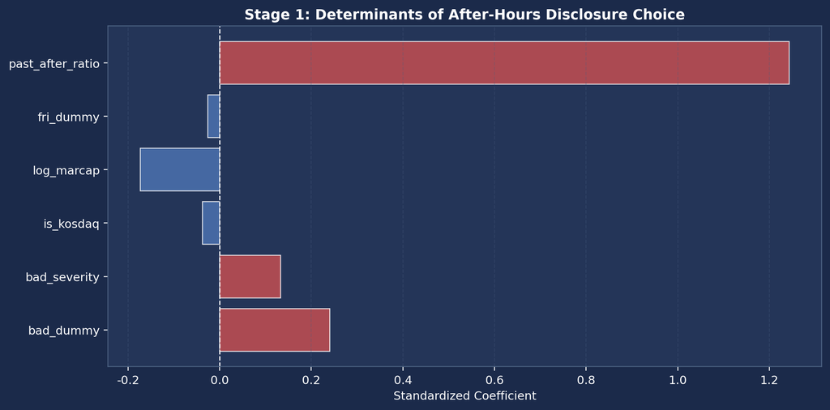

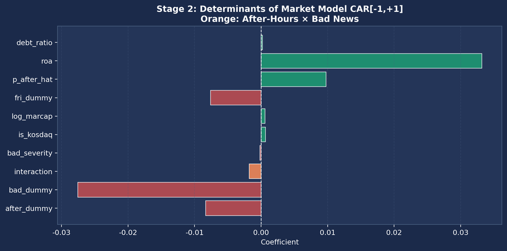

```python
plot_df = (
    coef2_df.copy()
)


fig, ax = plt.subplots(
    figsize=(10, 5)
)


colors = [

    "#FC8D59"
    if v == "interaction"

    else C_BAD
    if c < 0

    else C_GOOD

    for v, c
    in zip(
        plot_df[
            "Variable"
        ],
        plot_df[
            "Coefficient"
        ]
    )
]


ax.barh(
    plot_df[
        "Variable"
    ],
    plot_df[
        "Coefficient"
    ],
    color=colors,
    alpha=0.85,
    edgecolor="white",
    linewidth=0.8
)


ax.axvline(
    0,
    color="white",
    linestyle="--",
    linewidth=1
)


ax.set_xlabel(
    "Coefficient"
)

ax.set_title(
    "Stage 2: Determinants of "
    "Market Model CAR[-1,+1]\n"
    "Orange: After-Hours × Bad News"
)


ax.grid(
    axis="x",
    linestyle="--",
    alpha=0.3
)


plt.tight_layout()


plt.savefig(
    OUTPUT_DIR
    / "03_2_ols_market_model.png",
    dpi=150,
    bbox_inches="tight",
    facecolor="#1B2A4A"
)


plt.show()


# ------------------------------------------------------------
# Save Regression Analysis Dataset
# ------------------------------------------------------------

save_cols = [
    "stock_code",
    "rcept_dt",
    "timing",
    "weekday",
    "news",
    "after_dummy",
    "bad_dummy",
    "bad_severity",
    "fri_dummy",
    "is_kosdaq",
    "log_marcap",
    "roa",
    "debt_ratio",
    "past_after_ratio",
    "p_after_hat",
    "CAR_m1_p1"
]


save_df = (
    reg_df[
        save_cols
    ]
    .copy()
)


save_path = (
    OUTPUT_DIR
    / "regression_analysis_dataset.csv"
)


save_df.to_csv(
    save_path,
    index=False,
    encoding="utf-8-sig"
)
```

## 9.1 Empirical Analysis Results

## 9.2 Stage 1 Logistic Regression: Determinants of After-Hours Disclosure Choice

The first-stage logistic regression examines variables associated with the probability that a firm releases an earnings disclosure after market hours. The dependent variable is the after-hours disclosure indicator (`after_dummy`), and the explanatory variables include the bad-news indicator (`bad_dummy`), bad-news severity (`bad_severity`), KOSDAQ status, market capitalization (`log_marcap`), Friday indicator (`fri_dummy`), and the firm’s historical after-hours disclosure ratio (`past_after_ratio`).

Importantly, `past_after_ratio` is constructed **chronologically using only disclosures that occurred before the focal event**. Events are sorted within firm by disclosure date and, where available, disclosure time and receipt number. The historical ratio is then calculated from strictly preceding observations only, preventing future disclosure behavior from leaking into earlier observations. For a firm’s first observed disclosure, the historical ratio is set to zero because no prior event is available.

Stage 1 is estimated using a logistic regression with **HC3-robust covariance**. Predictors are standardized before estimation, so the reported coefficients and odds ratios correspond to a one-standard-deviation increase in each predictor.

| Variable | Standardized coefficient | Odds ratio | p-value | Interpretation |
| --- | --- | --- | --- | --- |
| `bad_dummy` | 0.2402 | 1.272 | < 0.001 | Bad-news disclosures are more likely to occur after hours. |
| `bad_severity` | 0.1330 | 1.142 | 0.0926 | Positive but only marginal evidence; not significant at the 5% level. |
| `is_kosdaq` | -0.0376 | 0.963 | 0.2067 | No statistically significant independent association. |
| `log_marcap` | -0.1732 | 0.841 | < 0.001 | Larger firms are less likely to disclose after hours. |
| `fri_dummy` | -0.0255 | 0.975 | 0.3337 | No statistically significant independent Friday effect in Stage 1. |
| `past_after_ratio` | **1.2433** | **3.467** | **< 0.001** | Strong persistence in firm-level disclosure timing. |

The most pronounced Stage 1 result is the historical timing variable. The standardized coefficient on `past_after_ratio` is **1.2433**, with an odds ratio of **3.467** and a 95% confidence interval of **[3.275, 3.670]** (**p < 0.001**). Thus, even after correcting the variable to use only information available before each focal disclosure, prior firm-level after-hours behavior remains strongly associated with subsequent after-hours disclosure choice.

Bad-news status is also positively and significantly associated with after-hours disclosure choice. By contrast, `bad_severity` is positive but does not meet the conventional 5% significance threshold (**p = 0.0926**). It should therefore be described as **marginal evidence** rather than as a statistically significant determinant.

Overall, Stage 1 supports a robust association between prior firm-level timing behavior and subsequent disclosure timing, while also showing that bad-news status matters independently. Because the analysis is observational, these results should not be interpreted as establishing deliberate strategic intent.

## 9.3 Stage 2 OLS Regression: Association Between After-Hours Disclosure and CAR

In the second stage, Market Model-based CAR[-1,+1] is used as the dependent variable to examine conditional associations between disclosure timing and market reactions. The specification includes the after-hours indicator (`after_dummy`), the bad-news indicator (`bad_dummy`), their interaction (`after_dummy × bad_dummy`), bad-news severity, market and firm controls, the Friday indicator, and the Stage 1 predicted probability of after-hours disclosure (`p_after_hat`).

Because `p_after_hat` is generated from the corrected Stage 1 model, Stage 2 is re-estimated after the temporal-leakage correction.

The bad-news coefficient remains negative and highly statistically significant:

```
bad_dummy = -0.02756, p < 0.001
```

The after-hours indicator is also negative and statistically significant in the controlled model:

```
after_dummy = -0.00834, p = 0.0003
```

This coefficient represents the conditional association of after-hours disclosure with CAR for the reference news category, holding the remaining covariates constant. It should not be interpreted as the incremental effect of releasing bad news after hours.

The key incremental term is the interaction between after-hours timing and bad news. Its coefficient remains statistically insignificant:

```
after_dummy × bad_dummy = -0.001782, p = 0.5336
```

Thus, the controlled regression does **not** provide evidence that bad news experiences an additional abnormal-return penalty specifically because it is disclosed after market hours. The Friday indicator is also negative and statistically significant in this specification:

```
fri_dummy = -0.00760, p < 0.001
```

These coefficients describe conditional associations within the observational specification and should not be interpreted as causal effects.

## 9.4 Overall Interpretation

The updated regression results lead to four main conclusions.

- `past_after_ratio` remains a strong and highly significant predictor after eliminating temporal leakage, supporting persistent firm-level disclosure-timing behavior.
- Bad-news status is independently associated with a higher probability of after-hours disclosure.
- Bad-news severity is positive but only marginally associated with after-hours disclosure in Stage 1 (**p = 0.0926**), so it should not be described as significant at the 5% level.
- The `after_dummy × bad_dummy` interaction remains statistically insignificant in Stage 2 (**coefficient = -0.001782, p = 0.5336**).

This controlled result is important when read together with the preceding event-study comparison. The unadjusted event study found a statistically significant difference between after-hours and intraday bad-news CARs (**-1.75% versus -1.24%, p = 0.043**), whereas the incremental after-hours bad-news interaction is not statistically significant after observable controls are introduced in Stage 2 (**p = 0.5336**). These findings are not contradictory. The raw group difference can reflect compositional or selection differences across disclosure events rather than an independent incremental effect of after-hours timing on bad-news CAR.

Accordingly, the combined evidence is more consistent with **selection/composition effects and persistent firm-level timing behavior** than with a robust causal market penalty or protection attributable specifically to releasing bad news after hours. The analysis remains observational, so all regression coefficients should be interpreted as conditional associations rather than causal effects.

# 10 Friday After-Hours Subgroup Analysis

```python
import sys
from pathlib import Path
import numpy as np
import pandas as pd
import matplotlib.pyplot as plt
import matplotlib.ticker as mtick
import matplotlib.font_manager as fm
from scipy import stats
from itertools import combinations
import matplotlib
from matplotlib import rcParams

# ── Output directory
OUTPUT_DIR = Path().resolve() / "outputs"
OUTPUT_DIR.mkdir(parents=True, exist_ok=True)

# ── Font settings
matplotlib.rcParams["font.family"] = "DejaVu Sans"
matplotlib.rcParams["axes.unicode_minus"] = False

# ── Global style
rcParams.update({
    "figure.facecolor" : "#1B2A4A",   # Navy background
    "axes.facecolor"   : "#243558",   # Plot area
    "axes.edgecolor"   : "#4A6080",
    "axes.labelcolor"  : "#FFFFFF",   # White
    "axes.titlecolor"  : "#FFFFFF",   # White
    "xtick.color"      : "#FFFFFF",   # White
    "ytick.color"      : "#FFFFFF",   # White
    "text.color"       : "#FFFFFF",   # White
    "grid.color"       : "#4A6080",
    "grid.linestyle"   : "--",
    "grid.alpha"       : 0.5,
    "font.size"        : 10,
    "axes.titlesize"   : 12,
    "axes.titleweight" : "bold",
    "axes.labelsize"   : 10,
    "legend.framealpha": 0.6,
    "legend.edgecolor" : "#4A6080",
    "legend.facecolor" : "#1B2A4A",
})

# ── Colors
C_GOOD, C_BAD = "#1D9E75", "#C44E52"
C_BEFORE, C_DURING, C_AFTER = "#4C72B0", "#888780", "#C44E52"

# Retain Korean category values used in the source data for processing
TIMING_COLORS = {
    "장전": C_BEFORE,
    "장중": C_DURING,
    "장후": C_AFTER
}

# English labels for visualization
TIMING_LABELS = {
    "장전": "Pre-market",
    "장중": "Intraday",
    "장후": "After-hours"
}

NEWS_LABELS = {
    "호재": "Good News",
    "악재": "Bad News"
}
```

```python
DATA_DIR = resolve_data_dir()

raw_fin  = pd.read_csv(DATA_DIR / "dart_earnings_financials_2019_2026.csv", dtype=str)
raw_ctrl = pd.read_csv(DATA_DIR / "dart_financial_controls_2019_2025.csv")
raw_comp = pd.read_csv(DATA_DIR / "company_krx_fdr_controls_2019_2026.csv")
```

```python
# Filtering
remove = raw_fin["report_nm"].str.contains(
    "전망|기재정정|첨부정정|첨부추가|월별|monthly", na=False, regex=True
)
fin = raw_fin[~remove].copy()
fin["year"] = fin["rcept_dt"].str[:4].astype(int)
fin = fin[fin["year"] <= 2025].copy()

# Remove duplicates, prioritizing consolidated disclosures
fin["is_consolidated"] = fin["report_nm"].str.contains("연결", na=False)
fin = fin.sort_values(
    ["stock_code", "rcept_dt", "is_consolidated", "rcept_no"],
    ascending=[True, True, False, True]
)
fin = fin.drop_duplicates(subset=["stock_code", "rcept_dt"], keep="first")

# Classify disclosure timing
t = fin["rcept_time"].str.split(":", expand=True)
fin["_h"] = pd.to_numeric(t[0], errors="coerce")
fin["_m"] = pd.to_numeric(t[1], errors="coerce")
fin["timing"] = "Intraday"
fin.loc[fin["_h"] < 9, "timing"] = "Pre-market"
fin.loc[(fin["_h"] > 15) | ((fin["_h"] == 15) & (fin["_m"] > 30)), "timing"] = "After-hours"
fin.loc[fin["_h"].isna(), "timing"] = None
fin.drop(columns=["_h", "_m"], inplace=True)
fin["rcept_dt_dt"] = pd.to_datetime(fin["rcept_dt"], format="%Y%m%d")
fin["weekday"] = fin["rcept_dt_dt"].dt.dayofweek

# Classify good and bad news
fin["oi_won"] = pd.to_numeric(fin["operating_income_won"], errors="coerce")
fin = fin.sort_values(["stock_code", "rcept_dt_dt"])
fin["prev_oi"] = fin.groupby("stock_code")["oi_won"].shift(1)
fin["oi_chg_pct"] = np.where(
    fin["prev_oi"].notna() & (fin["prev_oi"] != 0),
    (fin["oi_won"] - fin["prev_oi"]) / fin["prev_oi"].abs(),
    np.nan
)
fin["news"] = np.select(
    [fin["oi_chg_pct"] > 0.10, fin["oi_chg_pct"] < -0.10,
     fin["oi_chg_pct"].between(-0.10, 0.10, inclusive="both")],
    ["Good News", "Bad News", "Neutral"], default="Missing"
)

df = fin.copy()
df_hb = df[df["news"].isin(["Good News", "Bad News"]) & df["timing"].notna()].copy()

print(f"Good News: {df['news'].eq('Good News').sum():,}  Bad News: {df['news'].eq('Bad News').sum():,}")
print(f"Timing: {df['timing'].value_counts().to_dict()}")
```

```
Good News: 4,534  Bad News: 4,030
Timing: {'Intraday': 6362, 'After-hours': 5118, 'Pre-market': 811}
```

```python
# ============================================================
# Load Data for Stage 4
# ============================================================

from pathlib import Path
import numpy as np
import pandas as pd
import matplotlib.pyplot as plt
import statsmodels.formula.api as smf
from scipy import stats

OUTPUT_DIR = Path().resolve() / "outputs"

reg_df = pd.read_csv(
    OUTPUT_DIR / "regression_analysis_dataset.csv"
)


CAR_COL = "CAR_m1_p1"
BG_COLOR = "#1B2A4A"
```

### 10.0.1 Friday After-Hours Subgroup Analysis

##### 10.0.1.0.1 - Run after completing data preprocessing and CAR calculation in Stages 1–3

```python
# ============================================================
# Friday After-Hours Subgroup Analysis
# - Friday after-hours disclosure = proxy for the weekend effect
# - Based on Market Model CAR[-1,+1]
# - Adjusted to prevent overlapping visualization labels
# ============================================================

from pathlib import Path
import numpy as np
import pandas as pd
import matplotlib.pyplot as plt
from scipy import stats
import statsmodels.formula.api as smf


# ------------------------------------------------------------
# Settings and Data Loading
# ------------------------------------------------------------

OUTPUT_DIR = Path().resolve() / "outputs"
OUTPUT_DIR.mkdir(parents=True, exist_ok=True)

BG_COLOR = "#1B2A4A"
CAR_COL = "CAR_m1_p1"

reg_df = pd.read_csv(
    OUTPUT_DIR / "regression_analysis_dataset.csv"
)



# ------------------------------------------------------------
# Check Analysis Data
# ------------------------------------------------------------

need_cols = [
    "timing",
    "weekday",
    "after_dummy",
    "bad_dummy",
    "bad_severity",
    "is_kosdaq",
    "log_marcap",
    "fri_dummy",
    "p_after_hat",
    "roa",
    "debt_ratio",
    CAR_COL
]

missing = [
    c for c in need_cols
    if c not in reg_df.columns
]

if missing:
    raise ValueError(
        f"Required columns are missing from reg_df: {missing}"
    )

weekend_df = reg_df.copy()


# ------------------------------------------------------------
# Create Friday After-Hours Dummy
# ------------------------------------------------------------

weekend_df["friday_after"] = (
    (weekend_df["weekday"] == 4)
    & (weekend_df["timing"] == "After-hours")
).astype(int)


# Friday After-Hours × Bad News
weekend_df["friday_after_bad"] = (
    weekend_df["friday_after"]
    * weekend_df["bad_dummy"]
)


# After-Hours × Bad News
weekend_df["after_bad"] = (
    weekend_df["after_dummy"]
    * weekend_df["bad_dummy"]
)


# Create timing groups
weekend_df["timing_group"] = np.select(
    [
        (
            (weekend_df["weekday"] == 4)
            & (weekend_df["timing"] == "After-hours")
        ),
        (
            (weekend_df["weekday"] == 4)
            & (weekend_df["timing"] == "Intraday")
        ),
        (
            (weekend_df["weekday"] != 4)
            & (weekend_df["timing"] == "After-hours")
        ),
        (
            (weekend_df["weekday"] != 4)
            & (weekend_df["timing"] == "Intraday")
        ),
    ],
    [
        "Friday After-hours",
        "Friday Intraday",
        "Weekday After-hours",
        "Weekday Intraday",
    ],
    default="Other"
)


# ------------------------------------------------------------
# Descriptive Statistics
# ------------------------------------------------------------

sub_df = weekend_df[
    weekend_df["timing"].isin(
        ["Intraday", "After-hours"]
    )
].dropna(
    subset=[CAR_COL]
).copy()


print(
    "\n=== 4. Friday After-Hours Subgroup Analysis ==="
)

print(
    f"Total analysis sample: {len(sub_df):,}"
)

print(
    f"Friday after-hours disclosures: "
    f"{sub_df['friday_after'].sum():,}"
)

print(
    f"Friday after-hours share: "
    f"{sub_df['friday_after'].mean() * 100:.1f}%"
)


group_summary = (
    sub_df
    .groupby("timing_group")
    .agg(
        n=(CAR_COL, "size"),
        mean_car=(CAR_COL, "mean"),
        median_car=(CAR_COL, "median"),
        std_car=(CAR_COL, "std"),
        bad_ratio=("bad_dummy", "mean")
    )
    .reset_index()
)


group_summary["mean_car_pct"] = (
    group_summary["mean_car"] * 100
)

group_summary["median_car_pct"] = (
    group_summary["median_car"] * 100
)

group_summary["bad_ratio_pct"] = (
    group_summary["bad_ratio"] * 100
)


print(
    "\n=== CAR Descriptive Statistics by Group ==="
)

print(
    group_summary[
        [
            "timing_group",
            "n",
            "mean_car_pct",
            "median_car_pct",
            "std_car",
            "bad_ratio_pct"
        ]
    ].to_string(index=False)
)


# ------------------------------------------------------------
# Mean Difference Test:
# Friday After-Hours vs. Others
# ------------------------------------------------------------

fri_after_car = sub_df.loc[
    sub_df["friday_after"] == 1,
    CAR_COL
]

other_car = sub_df.loc[
    sub_df["friday_after"] == 0,
    CAR_COL
]


t_stat, p_val = stats.ttest_ind(
    fri_after_car,
    other_car,
    equal_var=False,
    nan_policy="omit"
)


print(
    "\n=== Mean Difference Test: "
    "Friday After-Hours vs. Others ==="
)

print(
    f"Mean CAR for Friday after-hours: "
    f"{fri_after_car.mean() * 100:.3f}%"
)

print(
    f"Mean CAR for others: "
    f"{other_car.mean() * 100:.3f}%"
)

print(
    f"Difference: "
    f"{(fri_after_car.mean() - other_car.mean()) * 100:.3f}%p"
)

print(
    f"t-stat: {t_stat:.3f}"
)

print(
    f"p-value: {p_val:.4f}"
)


# ------------------------------------------------------------
# Bad-News Sample:
# Friday After-Hours vs. Others
# ------------------------------------------------------------

bad_sub = sub_df[
    sub_df["bad_dummy"] == 1
].copy()


bad_fri_after = bad_sub.loc[
    bad_sub["friday_after"] == 1,
    CAR_COL
]

bad_other = bad_sub.loc[
    bad_sub["friday_after"] == 0,
    CAR_COL
]


bad_t, bad_p = stats.ttest_ind(
    bad_fri_after,
    bad_other,
    equal_var=False,
    nan_policy="omit"
)


print(
    "\n=== Bad-News Sample: "
    "Friday After-Hours vs. Others ==="
)


print(
    f"Friday after-hours observations "
    f"within bad-news sample: "
    f"{bad_sub['friday_after'].sum():,}"
)

print(
    f"Mean CAR for Friday after-hours bad news: "
    f"{bad_fri_after.mean() * 100:.3f}%"
)

print(
    f"Mean CAR for other bad news: "
    f"{bad_other.mean() * 100:.3f}%"
)

print(
    f"Difference: "
    f"{(bad_fri_after.mean() - bad_other.mean()) * 100:.3f}%p"
)

print(
    f"t-stat: {bad_t:.3f}"
)

print(
    f"p-value: {bad_p:.4f}"
)


# ------------------------------------------------------------
# Regression Model 1:
# Effect of Friday After-Hours Disclosure
# ------------------------------------------------------------
```

```python
reg_weekend1 = sub_df[
    [
        CAR_COL,
        "friday_after",
        "bad_dummy",
        "bad_severity",
        "is_kosdaq",
        "log_marcap",
        "p_after_hat",
        "roa",
        "debt_ratio",
    ]
].dropna().copy()


formula1 = (
    f"{CAR_COL} ~ friday_after + bad_dummy + bad_severity "
    "+ is_kosdaq + log_marcap + p_after_hat "
    "+ roa + debt_ratio"
)


model_weekend1 = smf.ols(
    formula1,
    data=reg_weekend1
).fit(
    cov_type="HC3"
)


print(
    "\n=== Regression Model 1: "
    "Effect of Friday After-Hours Disclosure ==="
)

print(
    model_weekend1.summary()
)


# ------------------------------------------------------------
# Regression Model 2:
# Friday After-Hours × Bad News Effect
# ------------------------------------------------------------

reg_weekend2 = sub_df[
    [
        CAR_COL,
        "friday_after",
        "bad_dummy",
        "friday_after_bad",
        "bad_severity",
        "is_kosdaq",
        "log_marcap",
        "p_after_hat",
        "roa",
        "debt_ratio",
    ]
].dropna().copy()


formula2 = (
    f"{CAR_COL} ~ friday_after + bad_dummy "
    "+ friday_after_bad + bad_severity "
    "+ is_kosdaq + log_marcap "
    "+ p_after_hat + roa + debt_ratio"
)


model_weekend2 = smf.ols(
    formula2,
    data=reg_weekend2
).fit(
    cov_type="HC3"
)


print(
    "\n=== Regression Model 2: "
    "Friday After-Hours × Bad News Effect ==="
)

print(
    model_weekend2.summary()
)


# ------------------------------------------------------------
# Summary of Key Results
# ------------------------------------------------------------

coef_summary = pd.DataFrame({
    "Model": [
        "Friday After-Hours Effect",
        "Friday After-Hours × Bad News Effect"
    ],
    "Variable": [
        "friday_after",
        "friday_after_bad"
    ],
    "Coefficient": [
        model_weekend1.params.get(
            "friday_after",
            np.nan
        ),
        model_weekend2.params.get(
            "friday_after_bad",
            np.nan
        ),
    ],
    "p-value": [
        model_weekend1.pvalues.get(
            "friday_after",
            np.nan
        ),
        model_weekend2.pvalues.get(
            "friday_after_bad",
            np.nan
        ),
    ]
})


coef_summary["Coefficient_pct"] = (
    coef_summary["Coefficient"] * 100
)

coef_summary["Coefficient"] = (
    coef_summary["Coefficient"].round(6)
)

coef_summary["Coefficient_pct"] = (
    coef_summary["Coefficient_pct"].round(3)
)

coef_summary["p-value"] = (
    coef_summary["p-value"].round(4)
)


print(
    "\n=== Summary of Key Results ==="
)

print(
    coef_summary.to_string(index=False)
)


# ------------------------------------------------------------
# Visualization 1:
# Mean CAR by Timing Group
# ------------------------------------------------------------

plot_order = [
    "Weekday Intraday",
    "Weekday After-hours",
    "Friday Intraday",
    "Friday After-hours"
]


plot_df = (
    group_summary
    .set_index("timing_group")
    .reindex(plot_order)
    .reset_index()
    .dropna(subset=["mean_car_pct"])
)


fig, ax = plt.subplots(
    figsize=(10, 5)
)

fig.patch.set_facecolor(
    BG_COLOR
)

ax.set_facecolor(
    "#243558"
)


colors = [
    "#4C72B0",
    "#888780",
    "#55A868",
    "#C44E52"
][:len(plot_df)]


bars = ax.bar(
    plot_df["timing_group"],
    plot_df["mean_car_pct"],
    color=colors,
    alpha=0.85,
    edgecolor="white",
    linewidth=0.8
)


for bar, val, n in zip(
    bars,
    plot_df["mean_car_pct"],
    plot_df["n"]
):

    if val >= 0:
        y_pos = val + 0.08
        va = "bottom"

    else:
        y_pos = val - 0.08
        va = "top"

    ax.text(
        bar.get_x()
        + bar.get_width() / 2,
        y_pos,
        f"{val:.2f}%\n(n={int(n):,})",
        ha="center",
        va=va,
        fontsize=9,
        fontweight="bold",
        color="white"
    )


ax.axhline(
    0,
    color="white",
    linestyle="--",
    linewidth=1,
    alpha=0.6
)


# Add y-axis margin to prevent label overlap
y_min = min(
    plot_df["mean_car_pct"].min() - 0.25,
    -0.8
)

y_max = max(
    plot_df["mean_car_pct"].max() + 0.25,
    1.2
)

ax.set_ylim(
    y_min,
    y_max
)


ax.set_ylabel(
    "Mean CAR[-1,+1] (%)"
)

ax.set_title(
    "Mean CAR by Friday After-Hours Subgroup",
    fontsize=12,
    fontweight="bold"
)


ax.spines[
    ["top", "right"]
].set_visible(False)

ax.spines[
    ["left", "bottom"]
].set_color("#4A6080")


ax.grid(
    axis="y",
    linestyle="--",
    alpha=0.3,
    color="#4A6080"
)


plt.tight_layout()


plt.savefig(
    OUTPUT_DIR
    / "04_friday_after_group_car.png",
    dpi=150,
    bbox_inches="tight",
    facecolor=BG_COLOR
)


plt.show()


# ------------------------------------------------------------
# Visualization 2:
# Key Regression Coefficients
# ------------------------------------------------------------

fig, ax = plt.subplots(
    figsize=(9, 4.5)
)

fig.patch.set_facecolor(
    BG_COLOR
)

ax.set_facecolor(
    "#243558"
)


coef_plot = (
    coef_summary.copy()
)


colors = [
    "#C44E52"
    if v < 0
    else "#1D9E75"
    for v in coef_plot[
        "Coefficient_pct"
    ]
]


bars = ax.barh(
    coef_plot["Model"],
    coef_plot["Coefficient_pct"],
    color=colors,
    alpha=0.85,
    edgecolor="white",
    linewidth=0.8
)


for bar, val, p in zip(
    bars,
    coef_plot["Coefficient_pct"],
    coef_plot["p-value"]
):

    if val >= 0:
        x_pos = val + 0.08
        ha = "left"

    else:
        x_pos = val - 0.08
        ha = "right"

    ax.text(
        x_pos,
        bar.get_y()
        + bar.get_height() / 2,
        f"{val:.3f}%p\np={p:.3f}",
        va="center",
        ha=ha,
        fontsize=9,
        fontweight="bold",
        color="white"
    )


ax.axvline(
    0,
    color="white",
    linestyle="--",
    linewidth=1,
    alpha=0.6
)


# Add x-axis margin to prevent label overlap
x_min = min(
    coef_plot["Coefficient_pct"].min() - 0.25,
    -1.2
)
```

```
=== 4. Friday After-Hours Subgroup Analysis ===
Total analysis sample: 7,939
Friday after-hours disclosures: 819
Friday after-hours share: 10.3%

=== CAR Descriptive Statistics by Group ===
       timing_group    n  mean_car_pct  median_car_pct  std_car  bad_ratio_pct
 Friday After-hours  819     -0.661326       -0.961102 0.064914      54.578755
    Friday Intraday  925     -0.101002       -0.278936 0.059454      48.324324
Weekday After-hours 2790     -0.030342       -0.251897 0.064891      51.326165
   Weekday Intraday 3405      1.009485        0.459999 0.067109      42.290749

=== Mean Difference Test: Friday After-Hours vs. Others ===
Mean CAR for Friday after-hours: -0.661%
Mean CAR for others: 0.458%
Difference: -1.119%p
t-stat: -4.668
p-value: 0.0000

=== Bad-News Sample: Friday After-Hours vs. Others ===
Friday after-hours observations within bad-news sample: 447
Mean CAR for Friday after-hours bad news: -1.863%
Mean CAR for other bad news: -1.101%
Difference: -0.762%p
t-stat: -2.507
p-value: 0.0125

=== Regression Model 1: Effect of Friday After-Hours Disclosure ===
                            OLS Regression Results
==============================================================================
Dep. Variable:              CAR_m1_p1   R-squared:                       0.053
Model:                            OLS   Adj. R-squared:                  0.052
Method:                 Least Squares   F-statistic:                     54.86
Date:                Sun, 30 Aug 2026   Prob (F-statistic):           2.63e-87
Time:                        19:22:02   Log-Likelihood:                 10590.
No. Observations:                7939   AIC:                        -2.116e+04
Df Residuals:                    7930   BIC:                        -2.110e+04
Df Model:                           8
Covariance Type:                  HC3
================================================================================
```

[output cut: 45 more lines]

```
debt_ratio           0.0002      0.000      0.689      0.491      -0.000       0.001
==============================================================================
Omnibus:                     1826.069   Durbin-Watson:                   2.086
Prob(Omnibus):                  0.000   Jarque-Bera (JB):            14627.523
Skew:                           0.880   Prob(JB):                         0.00
Kurtosis:                       9.412   Cond. No.                         484.
==============================================================================

Notes:
[1] Standard Errors are heteroscedasticity robust (HC3)

=== Summary of Key Results ===
                               Model         Variable  Coefficient  p-value  Coefficient_pct
           Friday After-Hours Effect     friday_after    -0.009106   0.0001           -0.911
Friday After-Hours × Bad News Effect friday_after_bad     0.002682   0.5710            0.268
```

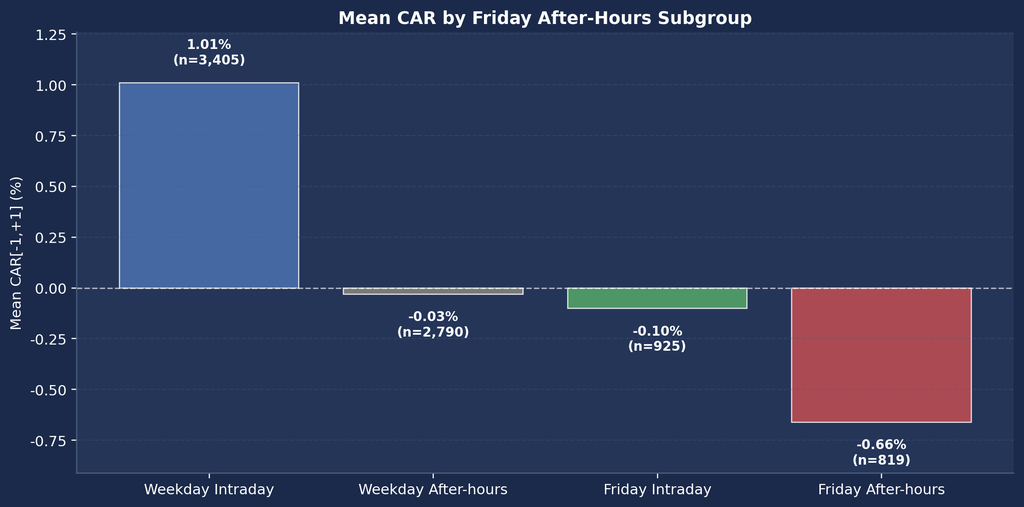

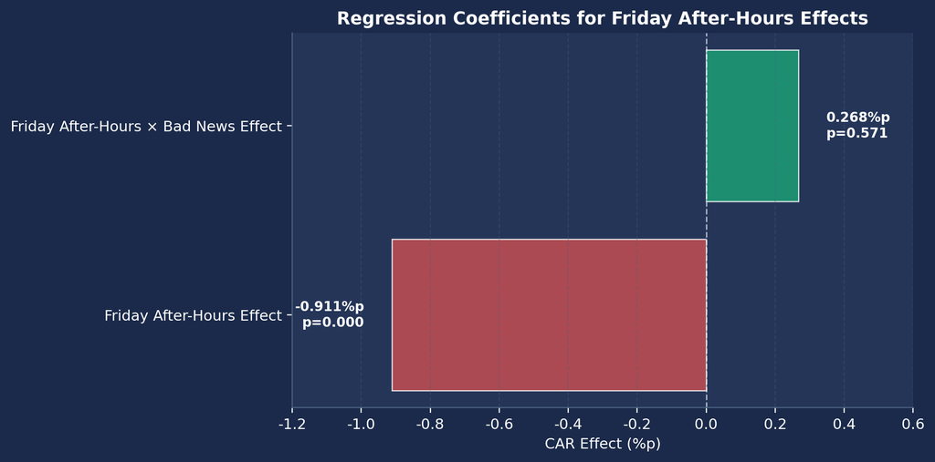

```python
x_max = max(
    coef_plot["Coefficient_pct"].max() + 0.25,
    0.6
)

ax.set_xlim(
    x_min,
    x_max
)


ax.set_xlabel(
    "CAR Effect (%p)"
)

ax.set_title(
    "Regression Coefficients for Friday After-Hours Effects",
    fontsize=12,
    fontweight="bold"
)


ax.spines[
    ["top", "right"]
].set_visible(False)

ax.spines[
    ["left", "bottom"]
].set_color("#4A6080")


ax.grid(
    axis="x",
    linestyle="--",
    alpha=0.3,
    color="#4A6080"
)


plt.tight_layout()


plt.savefig(
    OUTPUT_DIR
    / "04_friday_after_regression_coef.png",
    dpi=150,
    bbox_inches="tight",
    facecolor=BG_COLOR
)


plt.show()


# ------------------------------------------------------------
# Saved Files
# ------------------------------------------------------------
```

## 10.1 Analysis Objective

Friday after-hours disclosures have a structure in which information is effectively incorporated into the market over the weekend, making them directly comparable to the “Friday After-Hours Disclosure” or “Weekend Effect” discussed in prior international studies.

In particular, Friday after-hours disclosures provide more than two days for information to be absorbed before the next trading day. Therefore, they may exhibit effects that differ from ordinary after-hours disclosures in terms of investor attention, the speed of information diffusion, and market reactions.

Accordingly, this section treats Friday after-hours disclosures as a separate subgroup and analyzes their CAR[-1,+1] reactions.

## 10.2 Descriptive Statistics of CAR by Group

The results show that, among the full sample of 7,939 disclosures, 819 were released after market hours on Fridays, accounting for approximately 10.3% of the total sample.

The mean CAR[-1,+1] for each group is as follows.

| Group | Mean CAR |
| --- | --- |
| Weekday Intraday | +1.01% |
| Weekday After-hours | -0.03% |
| Friday Intraday | -0.10% |
| Friday After-hours | -0.66% |

In particular, Friday after-hours disclosures recorded the lowest mean CAR among all groups.

In addition, the proportion of bad-news disclosures in the Friday after-hours group was approximately 54.6%, which was relatively higher than in the other groups. This suggests that firms tend to concentrate negative information in Friday after-hours disclosures.

## 10.3 Mean Difference Test

A comparison between Friday after-hours disclosures and other disclosures shows that the mean CAR for Friday after-hours disclosures was -0.661%, whereas the mean CAR for other disclosures was +0.458%. The difference between the two groups was approximately -1.119 percentage points and was statistically significant.

```
t-stat = -4.668
p < 0.001
```

Thus, Friday after-hours disclosures were associated with more negative market reactions on average.

Additionally, when the analysis was restricted to bad-news disclosures, the mean CAR for Friday after-hours bad-news disclosures was -1.863%, compared with -1.101% for other bad-news disclosures. The difference was approximately -0.762 percentage points and was statistically significant.

```
t-stat = -2.507
p = 0.0125
```

This suggests that, even among bad-news disclosures, Friday after-hours disclosures may be associated with relatively more negative short-term market reactions.

## 10.4 Regression Analysis Results

The regression analysis separately tests the effect of Friday after-hours disclosure (`friday_after`) and the effect of Friday after-hours bad-news disclosure (`friday_after_bad`).

First, Friday after-hours disclosure is statistically significantly associated with lower CAR.

```
friday_after = -0.0091
p < 0.001
```

The coefficient corresponds to an approximately 0.91-percentage-point lower CAR on average, conditional on the included covariates.

In contrast, the key interaction term, Friday After-Hours × Bad News (`friday_after_bad`), is not statistically significant.

[output not shown]

In other words, although Friday after-hours disclosures are associated with lower CAR, there is no evidence of an additional negative association specifically for bad news disclosed after market hours on Friday.

## 10.5 Overall Interpretation

The results show that firms tend to release a relatively higher proportion of bad-news disclosures after market hours on Fridays, and Friday after-hours disclosures exhibit the lowest average CAR.

However, the key interaction term is not statistically significant in the regression analysis. Therefore, the market does not appear to impose an additional penalty specifically because bad news is disclosed after market hours on Friday.

This suggests that investors may respond more strongly to the underlying information contained in the disclosure than to the disclosure timing itself.

Although Friday after-hours disclosure could theoretically delay immediate market reaction, the results provide no evidence that this timing is associated with an additional mitigating effect on market reactions.

# 11 Changes in Disclosure Patterns Over Time

```python
import sys
from pathlib import Path
import numpy as np
import pandas as pd
import matplotlib.pyplot as plt
import matplotlib.ticker as mtick
import matplotlib.font_manager as fm
from scipy import stats
from itertools import combinations
import matplotlib
from matplotlib import rcParams

# ── Output directory
OUTPUT_DIR = Path().resolve() / "outputs"
OUTPUT_DIR.mkdir(parents=True, exist_ok=True)

# ── Font settings
matplotlib.rcParams["font.family"] = "DejaVu Sans"
matplotlib.rcParams["axes.unicode_minus"] = False

# ── Global style
rcParams.update({
    "figure.facecolor" : "#1B2A4A",   # Navy background
    "axes.facecolor"   : "#243558",   # Plot area
    "axes.edgecolor"   : "#4A6080",
    "axes.labelcolor"  : "#FFFFFF",   # White
    "axes.titlecolor"  : "#FFFFFF",   # White
    "xtick.color"      : "#FFFFFF",   # White
    "ytick.color"      : "#FFFFFF",   # White
    "text.color"       : "#FFFFFF",   # White
    "grid.color"       : "#4A6080",
    "grid.linestyle"   : "--",
    "grid.alpha"       : 0.5,
    "font.size"        : 10,
    "axes.titlesize"   : 12,
    "axes.titleweight" : "bold",
    "axes.labelsize"   : 10,
    "legend.framealpha": 0.6,
    "legend.edgecolor" : "#4A6080",
    "legend.facecolor" : "#1B2A4A",
})

# ── Colors
C_GOOD, C_BAD = "#1D9E75", "#C44E52"
C_BEFORE, C_DURING, C_AFTER = "#4C72B0", "#888780", "#C44E52"

# Retain Korean category values used in the source data for processing
TIMING_COLORS = {
    "장전": C_BEFORE,
    "장중": C_DURING,
    "장후": C_AFTER
}

# English labels for visualization
TIMING_LABELS = {
    "장전": "Pre-market",
    "장중": "Intraday",
    "장후": "After-hours"
}

NEWS_LABELS = {
    "호재": "Good News",
    "악재": "Bad News"
}
```

```python
DATA_DIR = resolve_data_dir()

raw_fin  = pd.read_csv(DATA_DIR / "dart_earnings_financials_2019_2026.csv", dtype=str)
raw_ctrl = pd.read_csv(DATA_DIR / "dart_financial_controls_2019_2025.csv")
raw_comp = pd.read_csv(DATA_DIR / "company_krx_fdr_controls_2019_2026.csv")
```

```python
# Filtering
remove = raw_fin["report_nm"].str.contains(
    "전망|기재정정|첨부정정|첨부추가|월별|monthly", na=False, regex=True
)
fin = raw_fin[~remove].copy()
fin["year"] = fin["rcept_dt"].str[:4].astype(int)
fin = fin[fin["year"] <= 2025].copy()

# Remove duplicates, prioritizing consolidated disclosures
fin["is_consolidated"] = fin["report_nm"].str.contains("연결", na=False)
fin = fin.sort_values(
    ["stock_code", "rcept_dt", "is_consolidated", "rcept_no"],
    ascending=[True, True, False, True]
)
fin = fin.drop_duplicates(subset=["stock_code", "rcept_dt"], keep="first")

# Classify disclosure timing
t = fin["rcept_time"].str.split(":", expand=True)
fin["_h"] = pd.to_numeric(t[0], errors="coerce")
fin["_m"] = pd.to_numeric(t[1], errors="coerce")
fin["timing"] = "Intraday"
fin.loc[fin["_h"] < 9, "timing"] = "Pre-market"
fin.loc[(fin["_h"] > 15) | ((fin["_h"] == 15) & (fin["_m"] > 30)), "timing"] = "After-hours"
fin.loc[fin["_h"].isna(), "timing"] = None
fin.drop(columns=["_h", "_m"], inplace=True)
fin["rcept_dt_dt"] = pd.to_datetime(fin["rcept_dt"], format="%Y%m%d")
fin["weekday"] = fin["rcept_dt_dt"].dt.dayofweek

# Classify good and bad news
fin["oi_won"] = pd.to_numeric(fin["operating_income_won"], errors="coerce")
fin = fin.sort_values(["stock_code", "rcept_dt_dt"])
fin["prev_oi"] = fin.groupby("stock_code")["oi_won"].shift(1)
fin["oi_chg_pct"] = np.where(
    fin["prev_oi"].notna() & (fin["prev_oi"] != 0),
    (fin["oi_won"] - fin["prev_oi"]) / fin["prev_oi"].abs(),
    np.nan
)
fin["news"] = np.select(
    [fin["oi_chg_pct"] > 0.10, fin["oi_chg_pct"] < -0.10,
     fin["oi_chg_pct"].between(-0.10, 0.10, inclusive="both")],
    ["Good News", "Bad News", "Neutral"], default="Missing"
)

df = fin.copy()
df_hb = df[df["news"].isin(["Good News", "Bad News"]) & df["timing"].notna()].copy()

print(f"Good News: {df['news'].eq('Good News').sum():,}  Bad News: {df['news'].eq('Bad News').sum():,}")
print(f"Timing: {df['timing'].value_counts().to_dict()}")
```

```
Good News: 4,534  Bad News: 4,030
Timing: {'Intraday': 6362, 'After-hours': 5118, 'Pre-market': 811}
```

### 11.0.1 Analysis of Changes in Patterns Over Time: Annual Trends

```
=== Annual Share of After-Hours Bad-News Disclosures ===
 year                           period  total  bad_total  bad_after  bad_after_pct
 2019                        Pre-COVID    783        365        188           51.5
 2020 COVID & Low-Interest-Rate Period   1175        543        247           45.5
 2021 COVID & Low-Interest-Rate Period   1222        550        242           44.0
 2022                 Rate-Hike Period   1270        611        284           46.5
 2023                 Rate-Hike Period   1351        656        306           46.6
 2024             Policy-Change Period   1357        667        330           49.5
 2025             Policy-Change Period   1393        632        290           45.9

=== Share of After-Hours Bad-News Disclosures by Period ===
                          period  total  bad_total  bad_after  bad_after_pct
                       Pre-COVID    783        365        188           51.5
COVID & Low-Interest-Rate Period   2397       1093        489           44.7
                Rate-Hike Period   2621       1267        590           46.6
            Policy-Change Period   2750       1299        620           47.7

=== Annual Linear Trend Test ===
Slope: -0.223%p / year
R²: 0.0354
p-value: 0.6863

=== Logistic Regression: Differences in After-Hours Disclosure Choice for Bad News Across Periods ===
                           Logit Regression Results
==============================================================================
Dep. Variable:            after_dummy   No. Observations:                 4024
Model:                          Logit   Df Residuals:                     4020
Method:                           MLE   Df Model:                            3
Date:                Sun, 30 Aug 2026   Pseudo R-squ.:                0.001001
Time:                        19:22:03   Log-Likelihood:                -2778.7
converged:                       True   LL-Null:                       -2781.5
Covariance Type:            nonrobust   LLR p-value:                    0.1344
=================================================================================================================
                                                    coef    std err          z      P>|z|      [0.025      0.975]
-----------------------------------------------------------------------------------------------------------------
Intercept                                         0.0603      0.105      0.576      0.565      -0.145       0.266
C(period)[T.COVID & Low-Interest-Rate Period]    -0.2715      0.121     -2.242      0.025      -0.509      -0.034
C(period)[T.Rate-Hike Period]                    -0.1978      0.119     -1.664      0.096      -0.431       0.035
C(period)[T.Policy-Change Period]                -0.1512      0.119     -1.275      0.202      -0.384       0.081
=================================================================================================================
```

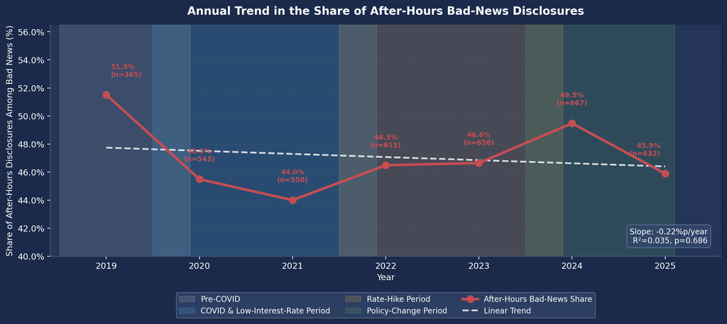

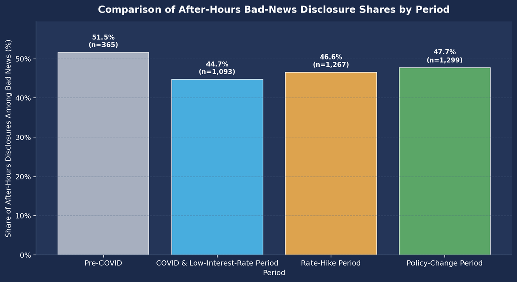

```python
# ============================================================
# Analysis of Changes in Patterns Over Time: Annual Trends
# - Annual share of after-hours bad-news disclosures, 2019–2025
# - Four periods: Pre-COVID / COVID & Low-Interest-Rate Period /
# Rate-Hike Period / Policy-Change Period
# ============================================================

import numpy as np
import pandas as pd
import matplotlib.pyplot as plt
import matplotlib.ticker as mtick
from scipy import stats
import statsmodels.formula.api as smf

BG_COLOR = "#1B2A4A"


# ------------------------------------------------------------
# Construct Analysis Dataset
# ------------------------------------------------------------

trend_df = df_hb.copy()

trend_df = trend_df[
    trend_df["year"].between(2019, 2025)
    & trend_df["timing"].isin(
        ["Pre-market", "Intraday", "After-hours"]
    )
    & trend_df["news"].isin(
        ["Good News", "Bad News"]
    )
].copy()


trend_df["after_dummy"] = (
    trend_df["timing"] == "After-hours"
).astype(int)

trend_df["bad_dummy"] = (
    trend_df["news"] == "Bad News"
).astype(int)


# Indicator for after-hours bad-news disclosure
trend_df["bad_after"] = (
    (trend_df["bad_dummy"] == 1)
    & (trend_df["after_dummy"] == 1)
).astype(int)


# ------------------------------------------------------------
# Create Period Classification Variable
# ------------------------------------------------------------

def assign_period(year):

    if year == 2019:
        return "Pre-COVID"

    elif year in [2020, 2021]:
        return "COVID & Low-Interest-Rate Period"

    elif year in [2022, 2023]:
        return "Rate-Hike Period"

    elif year in [2024, 2025]:
        return "Policy-Change Period"

    else:
        return "Other"


trend_df["period"] = (
    trend_df["year"]
    .apply(assign_period)
)


period_order = [
    "Pre-COVID",
    "COVID & Low-Interest-Rate Period",
    "Rate-Hike Period",
    "Policy-Change Period",
]


# ------------------------------------------------------------
# Calculate Annual Share of After-Hours Bad-News Disclosures
# ------------------------------------------------------------

yearly_bad = (
    trend_df[
        trend_df["bad_dummy"] == 1
    ]
    .groupby("year")
    .agg(
        bad_total=("bad_dummy", "size"),
        bad_after=("after_dummy", "sum"),
    )
    .reset_index()
)


yearly_bad["bad_after_pct"] = (
    yearly_bad["bad_after"]
    / yearly_bad["bad_total"]
    * 100
)


# Total sample size by year
yearly_total = (
    trend_df
    .groupby("year")
    .agg(
        total=("news", "size"),
        bad_n=("bad_dummy", "sum"),
        good_n=(
            "bad_dummy",
            lambda x: (x == 0).sum()
        ),
    )
    .reset_index()
)


yearly_bad = yearly_bad.merge(
    yearly_total,
    on="year",
    how="left"
)


yearly_bad["period"] = (
    yearly_bad["year"]
    .apply(assign_period)
)


print(
    "\n=== Annual Share of "
    "After-Hours Bad-News Disclosures ==="
)

print(
    yearly_bad[
        [
            "year",
            "period",
            "total",
            "bad_total",
            "bad_after",
            "bad_after_pct"
        ]
    ]
    .round({
        "bad_after_pct": 1
    })
    .to_string(index=False)
)


# ------------------------------------------------------------
# Calculate Share of After-Hours Bad-News Disclosures
# by Period
# ------------------------------------------------------------

period_bad = (
    trend_df[
        trend_df["bad_dummy"] == 1
    ]
    .groupby("period")
    .agg(
        bad_total=("bad_dummy", "size"),
        bad_after=("after_dummy", "sum"),
    )
    .reindex(period_order)
    .reset_index()
)


period_bad["bad_after_pct"] = (
    period_bad["bad_after"]
    / period_bad["bad_total"]
    * 100
)


period_total = (
    trend_df
    .groupby("period")
    .agg(
        total=("news", "size"),
        bad_n=("bad_dummy", "sum"),
        good_n=(
            "bad_dummy",
            lambda x: (x == 0).sum()
        ),
    )
    .reindex(period_order)
    .reset_index()
)


period_bad = period_bad.merge(
    period_total,
    on="period",
    how="left"
)


print(
    "\n=== Share of After-Hours "
    "Bad-News Disclosures by Period ==="
)

print(
    period_bad[
        [
            "period",
            "total",
            "bad_total",
            "bad_after",
            "bad_after_pct"
        ]
    ]
    .round({
        "bad_after_pct": 1
    })
    .to_string(index=False)
)


# ------------------------------------------------------------
# Annual Trend Test: Linear Trend
# ------------------------------------------------------------

slope, intercept, r_value, p_value, std_err = (
    stats.linregress(
        yearly_bad["year"],
        yearly_bad["bad_after_pct"]
    )
)


print(
    "\n=== Annual Linear Trend Test ==="
)

print(
    f"Slope: {slope:.3f}%p / year"
)

print(
    f"R²: {r_value ** 2:.4f}"
)

print(
    f"p-value: {p_value:.4f}"
)


# ------------------------------------------------------------
# Disclosure-Level Logistic Regression:
# Changes in the Probability of After-Hours Bad-News
# Disclosure Across Periods
# ------------------------------------------------------------

bad_only = trend_df[
    trend_df["bad_dummy"] == 1
].copy()


bad_only["period"] = pd.Categorical(
    bad_only["period"],
    categories=period_order,
    ordered=True
)


logit_period = smf.logit(
    "after_dummy ~ C(period)",
    data=bad_only
).fit(
    disp=False
)


print(
    "\n=== Logistic Regression: "
    "Differences in After-Hours Disclosure Choice "
    "for Bad News Across Periods ==="
)

print(
    logit_period.summary()
)


# ------------------------------------------------------------
# Visualization 1:
# Annual Trend in the Share of After-Hours
# Bad-News Disclosures
# ------------------------------------------------------------

years = yearly_bad[
    "year"
].values

bad_pct = yearly_bad[
    "bad_after_pct"
].values


fig, ax = plt.subplots(
    figsize=(12, 6)
)

fig.patch.set_facecolor(
    BG_COLOR
)

ax.set_facecolor(
    "#243558"
)


# Background shading for each period
periods = [
    (
        2019,
        2019.9,
        "#BFC5D2",
        "Pre-COVID"
    ),
    (
        2020,
        2021.9,
        "#4FC3F7",
        "COVID & Low-Interest-Rate Period"
    ),
    (
        2022,
        2023.9,
        "#FFB74D",
        "Rate-Hike Period"
    ),
    (
        2024,
        2025.1,
        "#66BB6A",
        "Policy-Change Period"
    ),
]


for x0, x1, color, label in periods:

    ax.axvspan(
        x0 - 0.5,
        x1,
        alpha=0.16,
        color=color,
        label=label,
        zorder=1
    )


# Actual annual shares
ax.plot(
    years,
    bad_pct,
    "o-",
    color=C_BAD,
    linewidth=3,
    markersize=8,
    label="After-Hours Bad-News Share",
    zorder=4
)


# Linear trend line
trend_line = (
    intercept
    + slope * years
)


ax.plot(
    years,
    trend_line,
    "--",
    color="#FFFFFF",
    linewidth=2,
    alpha=0.8,
    label="Linear Trend",
    zorder=3
)


# Data labels
for i, row in yearly_bad.iterrows():

    x = row["year"]
    y = row["bad_after_pct"]
    n = int(row["bad_total"])

    if i == 0:

        ha = "left"
        x_offset = 0.05

    elif i == len(yearly_bad) - 1:

        ha = "right"
        x_offset = -0.05

    else:

        ha = "center"
        x_offset = 0


    ax.annotate(
        f"{y:.1f}%\n(n={n:,})",
        xy=(x, y),
        xytext=(
            x + x_offset,
            y + 1.2
        ),
        textcoords="data",
        ha=ha,
        va="bottom",
        fontsize=8,
        color=C_BAD,
        fontweight="bold",
        zorder=5
    )


# Trend information box
trend_text = (
    f"Slope: {slope:.2f}%p/year\n"
    f"R²={r_value ** 2:.3f}, "
    f"p={p_value:.3f}"
)


ax.text(
    0.98,
    0.05,
    trend_text,
    transform=ax.transAxes,
    ha="right",
    va="bottom",
    fontsize=9,
    color="white",
    bbox=dict(
        boxstyle="round,pad=0.4",
        facecolor="#32476B",
        edgecolor="#5D7092",
        alpha=0.85
    )
)


# Axis settings
y_min = (
    bad_pct.min() - 4
)

y_max = (
    bad_pct.max() + 5
)


ax.set_ylim(
    y_min,
    y_max
)

ax.set_xlim(
    years[0] - 0.6,
    years[-1] + 0.6
)


ax.set_xticks(
    years
)

ax.set_xlabel(
    "Year",
    fontsize=10
)

ax.set_ylabel(
    "Share of After-Hours Disclosures "
    "Among Bad News (%)",
    fontsize=10
)


ax.set_title(
    "Annual Trend in the Share of "
    "After-Hours Bad-News Disclosures",
    fontsize=13,
    fontweight="bold",
    pad=12
)


ax.yaxis.set_major_formatter(
    mtick.PercentFormatter()
)


# Remove duplicate legend entries and place legend below
handles, labels = (
    ax.get_legend_handles_labels()
)

unique = dict(
    zip(
        labels,
        handles
    )
)


legend = ax.legend(
    unique.values(),
    unique.keys(),
    loc="upper center",
    bbox_to_anchor=(
        0.5,
        -0.14
    ),
    fontsize=9,
    ncol=3,
    framealpha=0.75
)


legend.get_frame().set_facecolor(
    "#32476B"
)

legend.get_frame().set_edgecolor(
    "#5D7092"
)


ax.spines[
    ["top", "right"]
].set_visible(False)

ax.spines[
    ["left", "bottom"]
].set_color("#4A6080")


ax.grid(
    axis="y",
    linestyle="--",
    alpha=0.3,
    color="#4A6080",
    zorder=1
)


plt.tight_layout(
    rect=[
        0,
        0.08,
        1,
        1
    ]
)


plt.savefig(
    OUTPUT_DIR
    / "05_yearly_bad_after_trend.png",
    dpi=150,
    bbox_inches="tight",
    facecolor=BG_COLOR
)


plt.show()


# ------------------------------------------------------------
# Visualization 2:
# Share of After-Hours Bad-News Disclosures by Period
# ------------------------------------------------------------

fig, ax = plt.subplots(
    figsize=(10, 5.5)
)

fig.patch.set_facecolor(
    BG_COLOR
)

ax.set_facecolor(
    "#243558"
)


period_colors = [
    "#BFC5D2",
    "#4FC3F7",
    "#FFB74D",
    "#66BB6A"
]


bars = ax.bar(
    period_bad["period"],
    period_bad["bad_after_pct"],
    color=period_colors,
    alpha=0.85,
    edgecolor="white",
    linewidth=0.8
)


for bar, pct, n in zip(
    bars,
    period_bad["bad_after_pct"],
    period_bad["bad_total"]
):

    ax.text(
        bar.get_x()
        + bar.get_width() / 2,
        pct + 1.0,
        f"{pct:.1f}%\n"
        f"(n={int(n):,})",
        ha="center",
        va="bottom",
        fontsize=9,
        fontweight="bold",
        color="white"
    )


ax.set_ylim(
    0,
    period_bad[
        "bad_after_pct"
    ].max() + 8
)


ax.set_xlabel(
    "Period",
    fontsize=10
)

ax.set_ylabel(
    "Share of After-Hours Disclosures "
    "Among Bad News (%)",
    fontsize=10
)


ax.set_title(
    "Comparison of After-Hours "
    "Bad-News Disclosure Shares by Period",
    fontsize=13,
    fontweight="bold",
    pad=12
)


ax.yaxis.set_major_formatter(
    mtick.PercentFormatter()
)


ax.spines[
    ["top", "right"]
].set_visible(False)

ax.spines[
    ["left", "bottom"]
].set_color("#4A6080")


ax.grid(
    axis="y",
    linestyle="--",
    alpha=0.3,
    color="#4A6080",
    zorder=1
)


plt.tight_layout()


plt.savefig(
    OUTPUT_DIR
    / "05_period_bad_after_comparison.png",
    dpi=150,
    bbox_inches="tight",
    facecolor=BG_COLOR
)


plt.show()


# ------------------------------------------------------------
# Save Results
# ------------------------------------------------------------

yearly_bad.to_csv(
    OUTPUT_DIR
    / "05_yearly_bad_after_trend.csv",
    index=False,
    encoding="utf-8-sig"
)


period_bad.to_csv(
    OUTPUT_DIR
    / "05_period_bad_after_comparison.csv",
    index=False,
    encoding="utf-8-sig"
)
```

## 11.1 Analysis Objective

This section examines how the proportion of after-hours bad-news disclosures changed over the 2019–2025 period.

In particular, the analysis divides the sample into the following four macroeconomic periods.

| Period | Classification |
| --- | --- |
| 2019 | Pre-COVID |
| 2020–2021 | COVID & Low-Interest-Rate Period |
| 2022–2023 | Rate-Hike Period |
| 2024–2025 | Policy-Change Period |

This classification is used to test whether firms’ disclosure-timing strategies vary with changes in the macroeconomic environment.

## 11.2 Annual Trend in the Share of After-Hours Bad-News Disclosures

The annual analysis shows that the proportion of after-hours disclosures among bad-news announcements fluctuated between 44.0% and 51.5%.

In 2019, the share of after-hours bad-news disclosures was the highest at 51.5%. During the COVID and low-interest-rate period, it declined to 45.5% in 2020 and 44.0% in 2021.

The proportion subsequently increased to approximately 46% during the rate-hike period (2022–2023) and reached 49.5% in 2024.

However, the annual linear trend test indicates that there was no statistically significant long-term increasing or decreasing trend.

```
Slope = -0.223%p/year
R² = 0.035
p = 0.686
```

Thus, although the proportion of after-hours bad-news disclosures varied from year to year, there is no evidence of a persistent structural increase or decrease over the sample period.

## 11.3 Comparison of After-Hours Bad-News Disclosure Shares by Period

The proportion of after-hours bad-news disclosures across the four periods was as follows.

| Period | After-Hours Bad-News Share |
| --- | --- |
| Pre-COVID | 51.5% |
| COVID & Low-Interest-Rate Period | 44.7% |
| Rate-Hike Period | 46.6% |
| Policy-Change Period | 47.7% |

The share of after-hours bad-news disclosures was lowest during the COVID and low-interest-rate period and subsequently increased during the rate-hike and policy-change periods.

This may suggest that firms made relatively less use of disclosure-timing strategies during the period characterized by exceptionally low interest rates and abundant liquidity.

In contrast, the use of after-hours disclosures showed an increasing tendency after market uncertainty and interest-rate pressures intensified.

## 11.4 Logistic Regression Results

A logistic regression restricted to bad-news disclosures was conducted to examine changes in the probability of choosing after-hours disclosure across periods. The coefficient for the COVID and low-interest-rate period was negative and statistically significant.

```
C(period)[T.COVID & Low-Interest-Rate Period] = -0.272
p = 0.025
```

This indicates that firms were significantly less likely to choose after-hours disclosure during the COVID and low-interest-rate period than during the pre-COVID period.

In contrast, the coefficients for the rate-hike and policy-change periods were negative but not statistically significant.

In addition, the likelihood ratio test for the overall model was not statistically significant (`p = 0.134`), and the model’s explanatory power (Pseudo R²) was also very low.

Therefore, period-level differences alone do not appear to provide sufficient explanatory power for firms’ choices of after-hours disclosure timing.

## 11.5 Overall Interpretation

Overall, the proportion of after-hours bad-news disclosures varied to some extent across different macroeconomic environments.

In particular, the share of after-hours bad-news disclosures declined during the COVID and low-interest-rate period and subsequently showed an increasing tendency as market uncertainty intensified.

However, the long-term trend analysis does not identify a statistically significant increasing or decreasing trend.

These findings suggest that firms’ disclosure-timing strategies may be partially influenced by specific macroeconomic conditions, but there is insufficient evidence to conclude that such strategies have undergone a persistent structural change over time.

# 12 Disclosure Timing by Market-Capitalization Group

```python
import sys
from pathlib import Path
import numpy as np
import pandas as pd
import matplotlib.pyplot as plt
import matplotlib.ticker as mtick
import matplotlib.font_manager as fm
from scipy import stats
from itertools import combinations
import matplotlib
from matplotlib import rcParams

# ── Output directory
OUTPUT_DIR = Path().resolve() / "outputs"
OUTPUT_DIR.mkdir(parents=True, exist_ok=True)

# ── Font settings
matplotlib.rcParams["font.family"] = "DejaVu Sans"
matplotlib.rcParams["axes.unicode_minus"] = False

# ── Global style
rcParams.update({
    "figure.facecolor" : "#1B2A4A",   # Navy background
    "axes.facecolor"   : "#243558",   # Plot area
    "axes.edgecolor"   : "#4A6080",
    "axes.labelcolor"  : "#FFFFFF",   # White
    "axes.titlecolor"  : "#FFFFFF",   # White
    "xtick.color"      : "#FFFFFF",   # White
    "ytick.color"      : "#FFFFFF",   # White
    "text.color"       : "#FFFFFF",   # White
    "grid.color"       : "#4A6080",
    "grid.linestyle"   : "--",
    "grid.alpha"       : 0.5,
    "font.size"        : 10,
    "axes.titlesize"   : 12,
    "axes.titleweight" : "bold",
    "axes.labelsize"   : 10,
    "legend.framealpha": 0.6,
    "legend.edgecolor" : "#4A6080",
    "legend.facecolor" : "#1B2A4A",
})

# ── Colors
C_GOOD, C_BAD = "#1D9E75", "#C44E52"
C_BEFORE, C_DURING, C_AFTER = "#4C72B0", "#888780", "#C44E52"

# Retain Korean category values used in the source data for processing
TIMING_COLORS = {
    "장전": C_BEFORE,
    "장중": C_DURING,
    "장후": C_AFTER
}

# English labels for visualization
TIMING_LABELS = {
    "장전": "Pre-market",
    "장중": "Intraday",
    "장후": "After-hours"
}

NEWS_LABELS = {
    "호재": "Good News",
    "악재": "Bad News"
}
```

```python
DATA_DIR = resolve_data_dir()

raw_fin  = pd.read_csv(DATA_DIR / "dart_earnings_financials_2019_2026.csv", dtype=str)
raw_ctrl = pd.read_csv(DATA_DIR / "dart_financial_controls_2019_2025.csv")
raw_comp = pd.read_csv(DATA_DIR / "company_krx_fdr_controls_2019_2026.csv")
```

```python
# Filtering
remove = raw_fin["report_nm"].str.contains(
    "전망|기재정정|첨부정정|첨부추가|월별|monthly", na=False, regex=True
)
fin = raw_fin[~remove].copy()
fin["year"] = fin["rcept_dt"].str[:4].astype(int)
fin = fin[fin["year"] <= 2025].copy()

# Remove duplicates, prioritizing consolidated disclosures
fin["is_consolidated"] = fin["report_nm"].str.contains("연결", na=False)
fin = fin.sort_values(
    ["stock_code", "rcept_dt", "is_consolidated", "rcept_no"],
    ascending=[True, True, False, True]
)
fin = fin.drop_duplicates(subset=["stock_code", "rcept_dt"], keep="first")

# Classify disclosure timing
t = fin["rcept_time"].str.split(":", expand=True)
fin["_h"] = pd.to_numeric(t[0], errors="coerce")
fin["_m"] = pd.to_numeric(t[1], errors="coerce")
fin["timing"] = "Intraday"
fin.loc[fin["_h"] < 9, "timing"] = "Pre-market"
fin.loc[(fin["_h"] > 15) | ((fin["_h"] == 15) & (fin["_m"] > 30)), "timing"] = "After-hours"
fin.loc[fin["_h"].isna(), "timing"] = None
fin.drop(columns=["_h", "_m"], inplace=True)
fin["rcept_dt_dt"] = pd.to_datetime(fin["rcept_dt"], format="%Y%m%d")
fin["weekday"] = fin["rcept_dt_dt"].dt.dayofweek

# Classify good and bad news
fin["oi_won"] = pd.to_numeric(fin["operating_income_won"], errors="coerce")
fin = fin.sort_values(["stock_code", "rcept_dt_dt"])
fin["prev_oi"] = fin.groupby("stock_code")["oi_won"].shift(1)
fin["oi_chg_pct"] = np.where(
    fin["prev_oi"].notna() & (fin["prev_oi"] != 0),
    (fin["oi_won"] - fin["prev_oi"]) / fin["prev_oi"].abs(),
    np.nan
)
fin["news"] = np.select(
    [fin["oi_chg_pct"] > 0.10, fin["oi_chg_pct"] < -0.10,
     fin["oi_chg_pct"].between(-0.10, 0.10, inclusive="both")],
    ["Good News", "Bad News", "Neutral"], default="Missing"
)

df = fin.copy()
df_hb = df[df["news"].isin(["Good News", "Bad News"]) & df["timing"].notna()].copy()

print(f"Good News: {df['news'].eq('Good News').sum():,}  Bad News: {df['news'].eq('Bad News').sum():,}")
print(f"Timing: {df['timing'].value_counts().to_dict()}")
```

```
Good News: 4,534  Bad News: 4,030
Timing: {'Intraday': 6362, 'After-hours': 5118, 'Pre-market': 811}
```

### 12.0.1 Comparison of Disclosure Timing Patterns by Market Capitalization Group

```python
# ============================================================
# Comparison of Disclosure Timing Patterns by Market Capitalization Group
# - Classify firms into Small / Mid / Large terciles based on log_marcap
# - Compare the share of after-hours bad-news disclosures across size groups
# - Bubble + Trend Line visualization
# ============================================================

import numpy as np
import pandas as pd
import matplotlib.pyplot as plt
import matplotlib.ticker as mtick
from scipy import stats
import statsmodels.formula.api as smf

BG_COLOR = "#1B2A4A"


# ------------------------------------------------------------
# Construct Analysis Dataset
# ------------------------------------------------------------

size_df = df_hb.copy()

size_df = size_df[
    size_df["news"].isin(["Good News", "Bad News"])
    & size_df["timing"].isin(
        ["Pre-market", "Intraday", "After-hours"]
    )
].copy()

size_df["stock_code"] = (
    size_df["stock_code"]
    .astype(str)
    .str.zfill(6)
)


# ------------------------------------------------------------
# Merge Market Capitalization and KOSDAQ Variables
# ------------------------------------------------------------

raw_comp2 = raw_comp.copy()

raw_comp2["stock_code"] = (
    raw_comp2["stock_code"]
    .astype(str)
    .str.zfill(6)
)


if "is_kosdaq" not in raw_comp2.columns:

    raw_comp2["is_kosdaq"] = (
        raw_comp2["market"]
        .astype(str)
        .str.upper()
        .str.contains(
            "KOSDAQ|코스닥",
            na=False
        )
        .astype(int)
    )


if "log_marcap" not in raw_comp2.columns:

    raw_comp2["marcap"] = pd.to_numeric(
        raw_comp2["marcap"],
        errors="coerce"
    )

    raw_comp2["log_marcap"] = np.log(
        raw_comp2["marcap"]
    )


size_df = size_df.merge(
    raw_comp2[
        [
            "stock_code",
            "market",
            "is_kosdaq",
            "log_marcap"
        ]
    ].drop_duplicates(
        "stock_code"
    ),
    on="stock_code",
    how="left"
)


size_df["log_marcap"] = pd.to_numeric(
    size_df["log_marcap"],
    errors="coerce"
)

size_df = size_df.dropna(
    subset=["log_marcap"]
).copy()


# ------------------------------------------------------------
# Create Market Capitalization Terciles
# ------------------------------------------------------------

size_df["size_group"] = pd.qcut(
    size_df["log_marcap"],
    q=3,
    labels=[
        "Small",
        "Mid",
        "Large"
    ]
)


size_df["size_group"] = pd.Categorical(
    size_df["size_group"],
    categories=[
        "Small",
        "Mid",
        "Large"
    ],
    ordered=True
)


size_df["after_dummy"] = (
    size_df["timing"] == "After-hours"
).astype(int)


size_df["bad_dummy"] = (
    size_df["news"] == "Bad News"
).astype(int)


size_df["bad_after"] = (
    (size_df["bad_dummy"] == 1)
    & (size_df["after_dummy"] == 1)
).astype(int)


# ------------------------------------------------------------
# Descriptive Statistics by Market Capitalization Group
# ------------------------------------------------------------

size_summary = (
    size_df
    .groupby(
        "size_group",
        observed=False
    )
    .agg(
        total=("news", "size"),
        bad_total=("bad_dummy", "sum"),
        after_total=("after_dummy", "sum"),
        bad_after=("bad_after", "sum"),
        mean_log_marcap=("log_marcap", "mean"),
        kosdaq_ratio=("is_kosdaq", "mean")
    )
    .reset_index()
)


size_summary["after_pct"] = (
    size_summary["after_total"]
    / size_summary["total"]
    * 100
)


size_summary["bad_ratio_pct"] = (
    size_summary["bad_total"]
    / size_summary["total"]
    * 100
)


size_summary["bad_after_pct"] = (
    size_summary["bad_after"]
    / size_summary["bad_total"]
    * 100
)


size_summary["kosdaq_ratio_pct"] = (
    size_summary["kosdaq_ratio"]
    * 100
)


print(
    "\n=== Share of After-Hours Bad-News Disclosures "
    "by Market Capitalization Group ==="
)


print(
    size_summary[
        [
            "size_group",
            "total",
            "bad_total",
            "bad_after",
            "bad_after_pct",
            "after_pct",
            "bad_ratio_pct",
            "kosdaq_ratio_pct",
            "mean_log_marcap"
        ]
    ]
    .round({
        "bad_after_pct": 1,
        "after_pct": 1,
        "bad_ratio_pct": 1,
        "kosdaq_ratio_pct": 1,
        "mean_log_marcap": 2
    })
    .to_string(
        index=False
    )
)


# ------------------------------------------------------------
# Test for Differences Across Size Groups
# within the Bad-News Sample
# ------------------------------------------------------------

bad_only = size_df[
    size_df["bad_dummy"] == 1
].copy()


contingency = pd.crosstab(
    bad_only["size_group"],
    bad_only["after_dummy"]
)


chi2, p_chi, dof, expected = (
    stats.chi2_contingency(
        contingency
    )
)


print(
    "\n=== Chi-Square Test: "
    "Market Capitalization Group × "
    "After-Hours Bad-News Disclosure ==="
)

print(
    contingency
)

print(
    f"chi2 = {chi2:.3f}"
)

print(
    f"p-value = {p_chi:.4f}"
)


# ------------------------------------------------------------
# Logistic Regression:
# Probability of Choosing After-Hours Disclosure for Bad News
# ------------------------------------------------------------

bad_only["size_group"] = pd.Categorical(
    bad_only["size_group"],
    categories=[
        "Small",
        "Mid",
        "Large"
    ],
    ordered=True
)


logit_size = smf.logit(
    "after_dummy ~ C(size_group) + is_kosdaq + log_marcap",
    data=bad_only
).fit(
    disp=False
)


print(
    "\n=== Logistic Regression: "
    "Probability of After-Hours Bad-News Disclosure "
    "by Market Capitalization Group ==="
)

print(
    logit_size.summary()
)


# ------------------------------------------------------------
# Calculate Predicted Probabilities
# ------------------------------------------------------------

pred_df = bad_only.copy()
```

```python
pred_df["pred_after_prob"] = (
    logit_size.predict(
        pred_df
    )
)


pred_summary = (
    pred_df
    .groupby(
        "size_group",
        observed=False
    )
    .agg(
        n=("after_dummy", "size"),
        observed_after_pct=(
            "after_dummy",
            "mean"
        ),
        predicted_after_pct=(
            "pred_after_prob",
            "mean"
        )
    )
    .reset_index()
)


pred_summary["observed_after_pct"] *= 100
pred_summary["predicted_after_pct"] *= 100


print(
    "\n=== Observed vs. Predicted Share of "
    "After-Hours Bad-News Disclosures by Size Group ==="
)


print(
    pred_summary
    .round({
        "observed_after_pct": 1,
        "predicted_after_pct": 1
    })
    .to_string(
        index=False
    )
)


# ------------------------------------------------------------
# Visualization 1:
# Bubble Plot + Trend Line
# ------------------------------------------------------------

fig, ax = plt.subplots(
    figsize=(10, 6)
)

fig.patch.set_facecolor(
    BG_COLOR
)

ax.set_facecolor(
    "#243558"
)


x = size_summary[
    "mean_log_marcap"
]

y = size_summary[
    "bad_after_pct"
]


bubble_sizes = (
    size_summary["bad_total"]
    * 0.65
)


group_colors = [
    "#4FC3F7",
    "#FFB74D",
    "#66BB6A"
]


ax.scatter(
    x,
    y,
    s=bubble_sizes,
    c=group_colors,
    alpha=0.85,
    edgecolors="white",
    linewidth=1.2,
    zorder=3
)


# Linear trend line
coef = np.polyfit(
    x,
    y,
    1
)

trend_fn = np.poly1d(
    coef
)

x_line = np.linspace(
    x.min() - 0.25,
    x.max() + 0.25,
    100
)


ax.plot(
    x_line,
    trend_fn(x_line),
    "--",
    color="#FFFFFF",
    linewidth=2.2,
    alpha=0.85,
    label="Linear Trend",
    zorder=2
)


# Data labels
for _, row in size_summary.iterrows():

    ax.text(
        row["mean_log_marcap"],
        row["bad_after_pct"] + 1.4,
        f"{row['size_group']}\n"
        f"{row['bad_after_pct']:.1f}%\n"
        f"(n={int(row['bad_total']):,})",
        ha="center",
        va="bottom",
        fontsize=10,
        fontweight="bold",
        color="white",
        zorder=5
    )


# Highlight relationship between firm size and after-hours bad news
ax.annotate(
    "Larger Firm Size\n"
    "→ Lower After-Hours Bad-News Share",
    xy=(
        size_summary.loc[
            size_summary["size_group"] == "Large",
            "mean_log_marcap"
        ].iloc[0],
        size_summary.loc[
            size_summary["size_group"] == "Large",
            "bad_after_pct"
        ].iloc[0]
    ),
    xytext=(
        size_summary[
            "mean_log_marcap"
        ].mean(),
        size_summary[
            "bad_after_pct"
        ].max() + 4.2
    ),
    arrowprops=dict(
        arrowstyle="->",
        color="#FFFFFF",
        lw=1.8
    ),
    fontsize=10,
    color="white",
    fontweight="bold",
    ha="center",
    bbox=dict(
        boxstyle="round,pad=0.4",
        facecolor="#32476B",
        edgecolor="#5D7092",
        alpha=0.85
    ),
    zorder=6
)


ax.set_xlim(
    x.min() - 0.8,
    x.max() + 0.8
)

ax.set_ylim(
    y.min() - 5,
    y.max() + 8
)


ax.set_xlabel(
    "Mean log(Market Capitalization)",
    fontsize=11
)

ax.set_ylabel(
    "After-Hours Share Among Bad-News Disclosures (%)",
    fontsize=11
)


ax.set_title(
    "Relationship Between Firm Size and "
    "After-Hours Bad-News Disclosure Share",
    fontsize=14,
    fontweight="bold",
    pad=14
)


ax.yaxis.set_major_formatter(
    mtick.PercentFormatter()
)


legend = ax.legend(
    loc="lower left",
    fontsize=9,
    framealpha=0.75
)


legend.get_frame().set_facecolor(
    "#32476B"
)

legend.get_frame().set_edgecolor(
    "#5D7092"
)


ax.spines[
    ["top", "right"]
].set_visible(False)

ax.spines[
    ["left", "bottom"]
].set_color("#4A6080")


ax.grid(
    linestyle="--",
    alpha=0.25,
    color="#4A6080"
)


plt.tight_layout()


plt.savefig(
    OUTPUT_DIR
    / "06_size_group_bubble_trend.png",
    dpi=150,
    bbox_inches="tight",
    facecolor=BG_COLOR
)


plt.show()


# ------------------------------------------------------------
# Visualization 2:
# Highlighting the Small-Large Firm Gap
# ------------------------------------------------------------

fig, ax = plt.subplots(
    figsize=(10, 5.5)
)

fig.patch.set_facecolor(
    BG_COLOR
)

ax.set_facecolor(
    "#243558"
)


x_pos = np.arange(
    len(size_summary)
)


ax.plot(
    x_pos,
    size_summary[
        "bad_after_pct"
    ],
    "o-",
    color="#FFFFFF",
    linewidth=2.8,
    markersize=9,
    zorder=3
)


ax.fill_between(
    x_pos,
    size_summary[
        "bad_after_pct"
    ],
    size_summary[
        "bad_after_pct"
    ].min() - 3,
    color="#4FC3F7",
    alpha=0.12,
    zorder=1
)


for i, row in size_summary.iterrows():

    ax.scatter(
        i,
        row["bad_after_pct"],
        s=350,
        color=group_colors[i],
        edgecolor="white",
        linewidth=1.2,
        zorder=4
    )


    ax.text(
        i,
        row["bad_after_pct"] + 1.4,
        f"{row['bad_after_pct']:.1f}%\n"
        f"(n={int(row['bad_total']):,})",
        ha="center",
        va="bottom",
        fontsize=10,
        fontweight="bold",
        color="white",
        zorder=5
    )


small_pct = size_summary.loc[
    size_summary["size_group"] == "Small",
    "bad_after_pct"
].iloc[0]


large_pct = size_summary.loc[
    size_summary["size_group"] == "Large",
    "bad_after_pct"
].iloc[0]


gap = (
    small_pct
    - large_pct
)


ax.annotate(
    f"Small-Large Gap\n"
    f"{gap:.1f}%p",
    xy=(
        1.0,
        (
            small_pct
            + large_pct
        ) / 2
    ),
    xytext=(
        1.0,
        size_summary[
            "bad_after_pct"
        ].max() + 5.2
    ),
    ha="center",
    va="center",
    fontsize=11,
    color="white",
    fontweight="bold",
    arrowprops=dict(
        arrowstyle="<->",
        color="#FFFFFF",
        lw=1.8
    ),
    bbox=dict(
        boxstyle="round,pad=0.4",
        facecolor="#32476B",
        edgecolor="#5D7092",
        alpha=0.85
    )
)
```

```
=== Share of After-Hours Bad-News Disclosures by Market Capitalization Group ===
size_group  total  bad_total  bad_after  bad_after_pct  after_pct  bad_ratio_pct  kosdaq_ratio_pct  mean_log_marcap
     Small   2857       1364        707           51.8       45.7           47.7              61.1            25.58
       Mid   2845       1334        639           47.9       43.2           46.9              36.8            27.38
     Large   2849       1326        541           40.8       38.2           46.5              11.1            29.86

=== Chi-Square Test: Market Capitalization Group × After-Hours Bad-News Disclosure ===
after_dummy    0    1
size_group
Small        657  707
Mid          695  639
Large        785  541
chi2 = 33.681
p-value = 0.0000

=== Logistic Regression: Probability of After-Hours Bad-News Disclosure by Market Capitalization Group ===
                           Logit Regression Results
==============================================================================
Dep. Variable:            after_dummy   No. Observations:                 4024
Model:                          Logit   Df Residuals:                     4019
Method:                           MLE   Df Model:                            4
Date:                Sun, 30 Aug 2026   Pseudo R-squ.:                0.009055
Time:                        19:22:05   Log-Likelihood:                -2756.3
converged:                       True   LL-Null:                       -2781.5
Covariance Type:            nonrobust   LLR p-value:                 3.017e-10
==========================================================================================
                             coef    std err          z      P>|z|      [0.025      0.975]
------------------------------------------------------------------------------------------
Intercept                  2.3029      1.066      2.160      0.031       0.213       4.393
C(size_group)[T.Mid]      -0.0834      0.106     -0.786      0.432      -0.291       0.125
C(size_group)[T.Large]    -0.2470      0.190     -1.302      0.193      -0.619       0.125
is_kosdaq                 -0.2863      0.075     -3.842      0.000      -0.432      -0.140
log_marcap                -0.0804      0.041     -1.948      0.051      -0.161       0.001
==========================================================================================

=== Observed vs. Predicted Share of After-Hours Bad-News Disclosures by Size Group ===
size_group    n  observed_after_pct  predicted_after_pct
     Small 1364                51.8                 51.8
       Mid 1334                47.9                 47.9
     Large 1326                40.8                 40.8
```

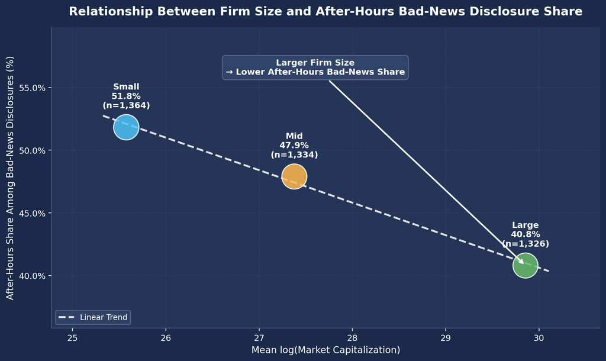

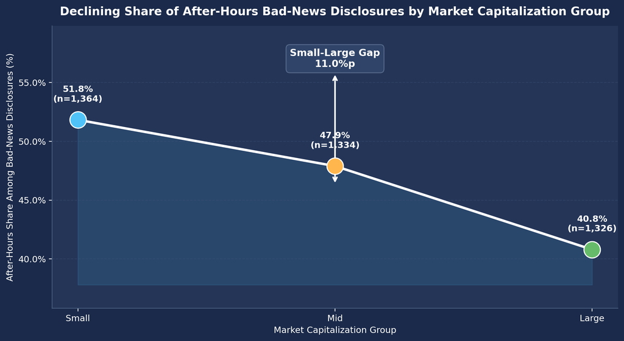

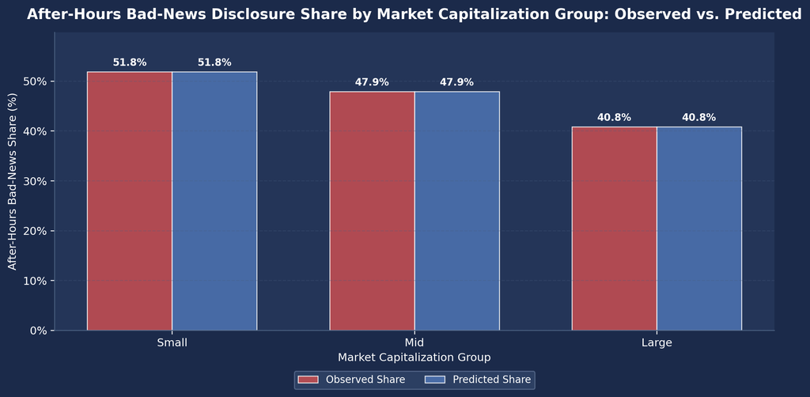

```python
ax.set_xticks(
    x_pos
)

ax.set_xticklabels(
    size_summary[
        "size_group"
    ].astype(str)
)


ax.set_ylim(
    size_summary[
        "bad_after_pct"
    ].min() - 5,
    size_summary[
        "bad_after_pct"
    ].max() + 8
)


ax.set_xlabel(
    "Market Capitalization Group",
    fontsize=10
)

ax.set_ylabel(
    "After-Hours Share Among Bad-News Disclosures (%)",
    fontsize=10
)


ax.set_title(
    "Declining Share of After-Hours Bad-News Disclosures "
    "by Market Capitalization Group",
    fontsize=13,
    fontweight="bold",
    pad=12
)


ax.yaxis.set_major_formatter(
    mtick.PercentFormatter()
)


ax.spines[
    ["top", "right"]
].set_visible(False)

ax.spines[
    ["left", "bottom"]
].set_color("#4A6080")


ax.grid(
    axis="y",
    linestyle="--",
    alpha=0.3,
    color="#4A6080",
    zorder=1
)


plt.tight_layout()


plt.savefig(
    OUTPUT_DIR
    / "06_size_group_gap_focus.png",
    dpi=150,
    bbox_inches="tight",
    facecolor=BG_COLOR
)


plt.show()


# ------------------------------------------------------------
# Visualization 3:
# Observed vs. Logistic Predicted Shares
# ------------------------------------------------------------

fig, ax = plt.subplots(
    figsize=(10, 5.5)
)

fig.patch.set_facecolor(
    BG_COLOR
)

ax.set_facecolor(
    "#243558"
)


x = np.arange(
    len(pred_summary)
)

width = 0.35


bars1 = ax.bar(
    x - width / 2,
    pred_summary[
        "observed_after_pct"
    ],
    width,
    label="Observed Share",
    color="#C44E52",
    alpha=0.88,
    edgecolor="white",
    linewidth=0.8
)


bars2 = ax.bar(
    x + width / 2,
    pred_summary[
        "predicted_after_pct"
    ],
    width,
    label="Predicted Share",
    color="#4C72B0",
    alpha=0.88,
    edgecolor="white",
    linewidth=0.8
)


for bars in [
    bars1,
    bars2
]:

    for bar in bars:

        val = bar.get_height()

        ax.text(
            bar.get_x()
            + bar.get_width() / 2,
            val + 0.8,
            f"{val:.1f}%",
            ha="center",
            va="bottom",
            fontsize=9,
            fontweight="bold",
            color="white"
        )


ax.set_xticks(
    x
)

ax.set_xticklabels(
    pred_summary[
        "size_group"
    ].astype(str)
)


ax.set_ylim(
    0,
    max(
        pred_summary[
            "observed_after_pct"
        ].max(),
        pred_summary[
            "predicted_after_pct"
        ].max()
    ) + 8
)


ax.set_xlabel(
    "Market Capitalization Group",
    fontsize=10
)

ax.set_ylabel(
    "After-Hours Bad-News Share (%)",
    fontsize=10
)


ax.set_title(
    "After-Hours Bad-News Disclosure Share by "
    "Market Capitalization Group: Observed vs. Predicted",
    fontsize=13,
    fontweight="bold",
    pad=12
)


ax.yaxis.set_major_formatter(
    mtick.PercentFormatter()
)


legend = ax.legend(
    loc="upper center",
    bbox_to_anchor=(
        0.5,
        -0.12
    ),
    ncol=2,
    fontsize=9,
    framealpha=0.75
)


legend.get_frame().set_facecolor(
    "#32476B"
)

legend.get_frame().set_edgecolor(
    "#5D7092"
)


ax.spines[
    ["top", "right"]
].set_visible(False)

ax.spines[
    ["left", "bottom"]
].set_color("#4A6080")


ax.grid(
    axis="y",
    linestyle="--",
    alpha=0.3,
    color="#4A6080",
    zorder=1
)


plt.tight_layout(
    rect=[
        0,
        0.06,
        1,
        1
    ]
)


plt.savefig(
    OUTPUT_DIR
    / "06_size_group_observed_predicted.png",
    dpi=150,
    bbox_inches="tight",
    facecolor=BG_COLOR
)


plt.show()


# ------------------------------------------------------------
# Saved Results
# ------------------------------------------------------------
```

## 12.1 Analysis Objective

This section examines whether the proportion of after-hours bad-news disclosures differs according to firm size.

Given the limited availability of institutional ownership data, this study uses market capitalization as a proxy for information accessibility and the level of market monitoring.

In general, larger firms tend to have greater institutional ownership and analyst coverage and lower information asymmetry, whereas smaller firms may have relatively limited information accessibility and lower levels of market monitoring.

Accordingly, this analysis tests whether the use of disclosure-timing strategies differs across firm-size groups.

## 12.2 Market Capitalization Group Classification

Firms were classified into three market capitalization terciles based on `log_marcap`.

| Group | Mean log_marcap |
| --- | --- |
| Small | 25.58 |
| Mid | 27.38 |
| Large | 29.86 |

The proportion of KOSDAQ-listed firms was also highest among small firms.

| Group | KOSDAQ Share |
| --- | --- |
| Small | 61.1% |
| Mid | 36.8% |
| Large | 11.1% |

## 12.3 Share of After-Hours Bad-News Disclosures by Market Capitalization Group

The results show that smaller firms had a higher proportion of bad-news disclosures released after market hours.

| Group | After-Hours Bad-News Share |
| --- | --- |
| Small | 51.8% |
| Mid | 47.9% |
| Large | 40.8% |

In particular, more than half of bad-news disclosures by small firms were released after market hours, whereas the corresponding proportion for large firms was approximately 40%.

This suggests that smaller firms may make relatively greater use of after-hours disclosure strategies.

## 12.4 Chi-Square Test Results

A chi-square test of the relationship between market capitalization group and after-hours disclosure among bad-news announcements revealed a statistically significant difference.

```
chi2 = 33.681
p < 0.001
```

This indicates that firm size and after-hours bad-news disclosure patterns are not independent, suggesting that disclosure-timing choices differ across firm-size groups.

## 12.5 Logistic Regression Results

A logistic regression restricted to bad-news disclosures was conducted to examine the probability of choosing after-hours disclosure. The market capitalization variable (`log_marcap`) had a negative coefficient.

```
log_marcap = -0.080
p = 0.051
```

This indicates that the likelihood of choosing after-hours disclosure tends to decrease as firm size increases.

The KOSDAQ dummy variable also had a statistically significant negative coefficient.

```
is_kosdaq = -0.286
p < 0.001
```

In contrast, the firm-size group dummies themselves were not statistically significant.

This suggests that the continuous market capitalization variable (`log_marcap`) may capture the firm-size effect more effectively than the categorical size-group indicators.

## 12.6 Overall Interpretation

Overall, smaller firms exhibited a stronger tendency to release bad-news disclosures after market hours.

In particular, the share of after-hours bad-news disclosures among small firms was approximately 11 percentage points higher than among large firms, and the overall differences across size groups were statistically significant.

This pattern may reflect differences in the information environment across firm sizes, including variation in information asymmetry and market monitoring.

Larger firms generally receive greater institutional investor and analyst attention, which may also be associated with differences in disclosure-timing patterns.

Therefore, these results suggest that firm size is associated with systematic differences in disclosure timing and the surrounding information environment.

# 13 Disclosure Timing by Bad-News Severity

```python
import sys
from pathlib import Path
import numpy as np
import pandas as pd
import matplotlib.pyplot as plt
import matplotlib.ticker as mtick
import matplotlib.font_manager as fm
from scipy import stats
from itertools import combinations
import matplotlib
from matplotlib import rcParams

# ── Output directory
OUTPUT_DIR = Path().resolve() / "outputs"
OUTPUT_DIR.mkdir(parents=True, exist_ok=True)

# ── Font settings
matplotlib.rcParams["font.family"] = "DejaVu Sans"
matplotlib.rcParams["axes.unicode_minus"] = False

# ── Global style
rcParams.update({
    "figure.facecolor" : "#1B2A4A",   # Navy background
    "axes.facecolor"   : "#243558",   # Plot area
    "axes.edgecolor"   : "#4A6080",
    "axes.labelcolor"  : "#FFFFFF",   # White
    "axes.titlecolor"  : "#FFFFFF",   # White
    "xtick.color"      : "#FFFFFF",   # White
    "ytick.color"      : "#FFFFFF",   # White
    "text.color"       : "#FFFFFF",   # White
    "grid.color"       : "#4A6080",
    "grid.linestyle"   : "--",
    "grid.alpha"       : 0.5,
    "font.size"        : 10,
    "axes.titlesize"   : 12,
    "axes.titleweight" : "bold",
    "axes.labelsize"   : 10,
    "legend.framealpha": 0.6,
    "legend.edgecolor" : "#4A6080",
    "legend.facecolor" : "#1B2A4A",
})

# ── Colors
C_GOOD, C_BAD = "#1D9E75", "#C44E52"
C_BEFORE, C_DURING, C_AFTER = "#4C72B0", "#888780", "#C44E52"

# Retain Korean category values used in the source data for processing
TIMING_COLORS = {
    "장전": C_BEFORE,
    "장중": C_DURING,
    "장후": C_AFTER
}

# English labels for visualization
TIMING_LABELS = {
    "장전": "Pre-market",
    "장중": "Intraday",
    "장후": "After-hours"
}

NEWS_LABELS = {
    "호재": "Good News",
    "악재": "Bad News"
}
```

```python
DATA_DIR = resolve_data_dir()

raw_fin  = pd.read_csv(DATA_DIR / "dart_earnings_financials_2019_2026.csv", dtype=str)
raw_ctrl = pd.read_csv(DATA_DIR / "dart_financial_controls_2019_2025.csv")
raw_comp = pd.read_csv(DATA_DIR / "company_krx_fdr_controls_2019_2026.csv")
```

```python
# Filtering
remove = raw_fin["report_nm"].str.contains(
    "전망|기재정정|첨부정정|첨부추가|월별|monthly", na=False, regex=True
)
fin = raw_fin[~remove].copy()
fin["year"] = fin["rcept_dt"].str[:4].astype(int)
fin = fin[fin["year"] <= 2025].copy()

# Remove duplicates, prioritizing consolidated disclosures
fin["is_consolidated"] = fin["report_nm"].str.contains("연결", na=False)
fin = fin.sort_values(
    ["stock_code", "rcept_dt", "is_consolidated", "rcept_no"],
    ascending=[True, True, False, True]
)
fin = fin.drop_duplicates(subset=["stock_code", "rcept_dt"], keep="first")

# Classify disclosure timing
t = fin["rcept_time"].str.split(":", expand=True)
fin["_h"] = pd.to_numeric(t[0], errors="coerce")
fin["_m"] = pd.to_numeric(t[1], errors="coerce")
fin["timing"] = "Intraday"
fin.loc[fin["_h"] < 9, "timing"] = "Pre-market"
fin.loc[(fin["_h"] > 15) | ((fin["_h"] == 15) & (fin["_m"] > 30)), "timing"] = "After-hours"
fin.loc[fin["_h"].isna(), "timing"] = None
fin.drop(columns=["_h", "_m"], inplace=True)
fin["rcept_dt_dt"] = pd.to_datetime(fin["rcept_dt"], format="%Y%m%d")
fin["weekday"] = fin["rcept_dt_dt"].dt.dayofweek

# Classify good and bad news
fin["oi_won"] = pd.to_numeric(fin["operating_income_won"], errors="coerce")
fin = fin.sort_values(["stock_code", "rcept_dt_dt"])
fin["prev_oi"] = fin.groupby("stock_code")["oi_won"].shift(1)
fin["oi_chg_pct"] = np.where(
    fin["prev_oi"].notna() & (fin["prev_oi"] != 0),
    (fin["oi_won"] - fin["prev_oi"]) / fin["prev_oi"].abs(),
    np.nan
)
fin["news"] = np.select(
    [fin["oi_chg_pct"] > 0.10, fin["oi_chg_pct"] < -0.10,
     fin["oi_chg_pct"].between(-0.10, 0.10, inclusive="both")],
    ["Good News", "Bad News", "Neutral"], default="Missing"
)

df = fin.copy()
df_hb = df[df["news"].isin(["Good News", "Bad News"]) & df["timing"].notna()].copy()

print(f"Good News: {df['news'].eq('Good News').sum():,}  Bad News: {df['news'].eq('Bad News').sum():,}")
print(f"Timing: {df['timing'].value_counts().to_dict()}")
```

```
Good News: 4,534  Bad News: 4,030
Timing: {'Intraday': 6362, 'After-hours': 5118, 'Pre-market': 811}
```

### 13.0.1 Analysis of Disclosure Timing Patterns by Bad-News Severity

```
=== Share of After-Hours Disclosures by Bad-News Severity ===
severity_group  total  after_n  mean_decline  after_pct
  -10% to -30%   1306      518          19.5       39.7
  -30% to -50%    901      410          39.8       45.5
    Below -50%   1817      959         233.1       52.8

=== Chi-Square Test: Bad-News Severity × After-Hours Disclosure ===
after_dummy       0    1
severity_group
-10% to -30%    788  518
-30% to -50%    491  410
Below -50%      858  959

chi2 = 53.390
p-value = 0.0000

=== Logistic Regression Results ===
                           Logit Regression Results
==============================================================================
Dep. Variable:            after_dummy   No. Observations:                 4024
Model:                          Logit   Df Residuals:                     4021
Method:                           MLE   Df Model:                            2
Date:                Sun, 30 Aug 2026   Pseudo R-squ.:                0.009634
Time:                        19:22:07   Log-Likelihood:                -2754.7
converged:                       True   LL-Null:                       -2781.5
Covariance Type:            nonrobust   LLR p-value:                 2.306e-12
=====================================================================================================
                                        coef    std err          z      P>|z|      [0.025      0.975]
-----------------------------------------------------------------------------------------------------
Intercept                            -0.4195      0.057     -7.417      0.000      -0.530      -0.309
C(severity_group)[T.-30% to -50%]     0.2392      0.088      2.731      0.006       0.068       0.411
C(severity_group)[T.Below -50%]       0.5308      0.074      7.218      0.000       0.387       0.675
=====================================================================================================

=== Linear Trend Test by Bad-News Severity ===
Slope: 6.558%p / severity level
R²: 0.9960
p-value: 0.0401
```

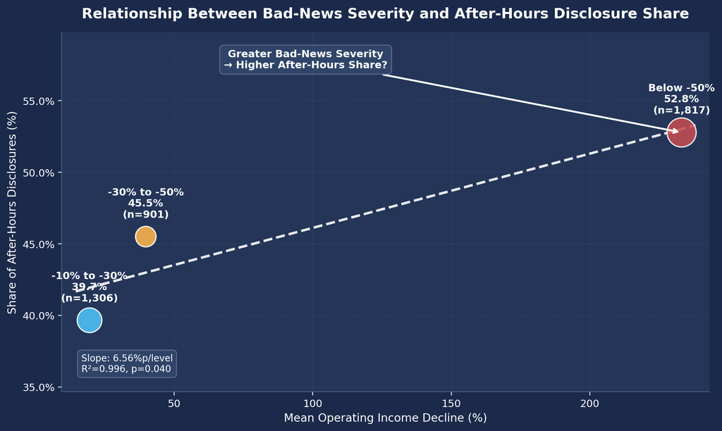

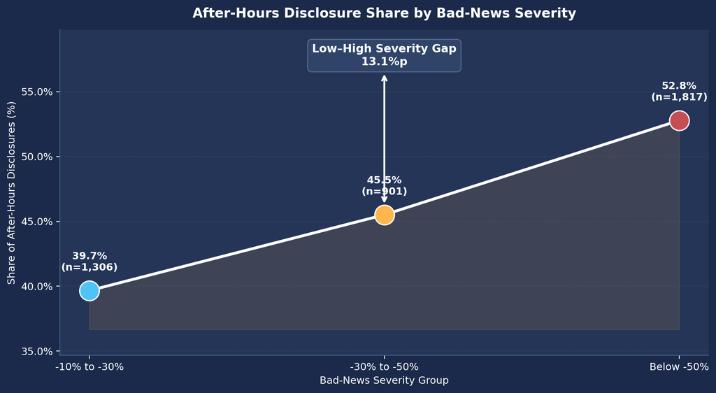

```python
# ============================================================
# Analysis of Disclosure Timing Patterns by Bad-News Severity
# - Classify observations by operating income decline
# - Test whether more severe bad news is associated with
# a higher share of after-hours disclosures
# - Improved visualization version
# ============================================================

import numpy as np
import pandas as pd
import matplotlib.pyplot as plt
import matplotlib.ticker as mtick
from scipy import stats
import statsmodels.formula.api as smf

BG_COLOR = "#1B2A4A"


# ------------------------------------------------------------
# Construct Analysis Dataset
# ------------------------------------------------------------

sev_df = df_hb.copy()

sev_df = sev_df[
    sev_df["news"] == "Bad News"
].copy()

sev_df["after_dummy"] = (
    sev_df["timing"] == "After-hours"
).astype(int)


# ------------------------------------------------------------
# Calculate Bad-News Severity
# ------------------------------------------------------------

sev_df["decline_pct"] = (
    sev_df["oi_chg_pct"].abs() * 100
)


sev_df["severity_group"] = pd.cut(
    sev_df["decline_pct"],
    bins=[10, 30, 50, np.inf],
    labels=[
        "-10% to -30%",
        "-30% to -50%",
        "Below -50%"
    ],
    right=False
)


sev_df = sev_df.dropna(
    subset=["severity_group"]
).copy()


sev_df["severity_group"] = pd.Categorical(
    sev_df["severity_group"],
    categories=[
        "-10% to -30%",
        "-30% to -50%",
        "Below -50%"
    ],
    ordered=True
)


# ------------------------------------------------------------
# Descriptive Statistics
# ------------------------------------------------------------

severity_summary = (
    sev_df
    .groupby(
        "severity_group",
        observed=False
    )
    .agg(
        total=("after_dummy", "size"),
        after_n=("after_dummy", "sum"),
        mean_decline=("decline_pct", "mean")
    )
    .reset_index()
)


severity_summary["after_pct"] = (
    severity_summary["after_n"]
    / severity_summary["total"]
    * 100
)


print(
    "\n=== Share of After-Hours Disclosures "
    "by Bad-News Severity ==="
)


print(
    severity_summary
    .round({
        "mean_decline": 1,
        "after_pct": 1
    })
    .to_string(index=False)
)


# ------------------------------------------------------------
# Chi-Square Test
# ------------------------------------------------------------

contingency = pd.crosstab(
    sev_df["severity_group"],
    sev_df["after_dummy"]
)


chi2, p_chi, dof, expected = stats.chi2_contingency(
    contingency
)


print(
    "\n=== Chi-Square Test: "
    "Bad-News Severity × After-Hours Disclosure ==="
)

print(
    contingency
)


print(
    f"\nchi2 = {chi2:.3f}"
)

print(
    f"p-value = {p_chi:.4f}"
)


# ------------------------------------------------------------
# Logistic Regression
# ------------------------------------------------------------

logit_sev = smf.logit(
    "after_dummy ~ C(severity_group)",
    data=sev_df
).fit(
    disp=False
)


print(
    "\n=== Logistic Regression Results ==="
)

print(
    logit_sev.summary()
)


# ------------------------------------------------------------
# Linear Trend Test
# ------------------------------------------------------------

severity_summary["group_order"] = [
    1,
    2,
    3
]


slope, intercept, r_value, p_value, std_err = stats.linregress(
    severity_summary["group_order"],
    severity_summary["after_pct"]
)


print(
    "\n=== Linear Trend Test by Bad-News Severity ==="
)


print(
    f"Slope: {slope:.3f}%p / severity level"
)

print(
    f"R²: {r_value ** 2:.4f}"
)

print(
    f"p-value: {p_value:.4f}"
)


# ============================================================
# Visualization 1: Bubble Plot + Trend Line
# ============================================================

fig, ax = plt.subplots(
    figsize=(10, 6)
)


fig.patch.set_facecolor(
    BG_COLOR
)

ax.set_facecolor(
    "#243558"
)


x = severity_summary[
    "mean_decline"
]

y = severity_summary[
    "after_pct"
]


bubble_sizes = (
    severity_summary["total"]
    * 0.45
)


colors = [
    "#4FC3F7",
    "#FFB74D",
    "#C44E52"
]


# ------------------------------------------------------------
# Bubble Plot
# ------------------------------------------------------------

ax.scatter(
    x,
    y,
    s=bubble_sizes,
    c=colors,
    alpha=0.88,
    edgecolors="white",
    linewidth=1.2,
    zorder=3
)


# ------------------------------------------------------------
# Trend Line
# ------------------------------------------------------------

coef = np.polyfit(
    x,
    y,
    1
)


trend_fn = np.poly1d(
    coef
)


x_line = np.linspace(
    x.min() - 5,
    x.max() + 5,
    100
)


ax.plot(
    x_line,
    trend_fn(x_line),
    "--",
    color="#FFFFFF",
    linewidth=2.4,
    alpha=0.9,
    zorder=2
)


# ------------------------------------------------------------
# Data Labels
# ------------------------------------------------------------

for _, row in severity_summary.iterrows():

    ax.text(
        row["mean_decline"],
        row["after_pct"] + 1.2,

        f"{row['severity_group']}\n"
        f"{row['after_pct']:.1f}%\n"
        f"(n={int(row['total']):,})",

        ha="center",
        va="bottom",

        fontsize=10,
        fontweight="bold",
        color="white",

        zorder=5
    )


# ------------------------------------------------------------
# Arrow Annotation
# ------------------------------------------------------------

ax.annotate(
    "Greater Bad-News Severity\n"
    "→ Higher After-Hours Share?",

    xy=(
        severity_summary[
            "mean_decline"
        ].iloc[-1],

        severity_summary[
            "after_pct"
        ].iloc[-1]
    ),

    xytext=(
        severity_summary[
            "mean_decline"
        ].mean(),

        severity_summary[
            "after_pct"
        ].max() + 4.5
    ),

    arrowprops=dict(
        arrowstyle="->",
        color="#FFFFFF",
        lw=1.8
    ),

    fontsize=10,
    color="white",
    fontweight="bold",

    ha="center",

    bbox=dict(
        boxstyle="round,pad=0.4",
        facecolor="#32476B",
        edgecolor="#5D7092",
        alpha=0.85
    )
)


# ------------------------------------------------------------
# Trend Statistics Box
# ------------------------------------------------------------

trend_text = (
    f"Slope: {slope:.2f}%p/level\n"
    f"R²={r_value ** 2:.3f}, "
    f"p={p_value:.3f}"
)


ax.text(
    0.03,
    0.05,

    trend_text,

    transform=ax.transAxes,

    ha="left",
    va="bottom",

    fontsize=9,
    color="white",

    bbox=dict(
        boxstyle="round,pad=0.4",
        facecolor="#32476B",
        edgecolor="#5D7092",
        alpha=0.85
    )
)


# ------------------------------------------------------------
# Axis Settings
# ------------------------------------------------------------

ax.set_xlim(
    x.min() - 10,
    x.max() + 10
)


ax.set_ylim(
    y.min() - 5,
    y.max() + 7
)


ax.set_xlabel(
    "Mean Operating Income Decline (%)",
    fontsize=11
)


ax.set_ylabel(
    "Share of After-Hours Disclosures (%)",
    fontsize=11
)


ax.set_title(
    "Relationship Between Bad-News Severity "
    "and After-Hours Disclosure Share",
    fontsize=14,
    fontweight="bold",
    pad=14
)


ax.yaxis.set_major_formatter(
    mtick.PercentFormatter()
)


# ------------------------------------------------------------
# Style
# ------------------------------------------------------------

ax.spines[
    ["top", "right"]
].set_visible(False)


ax.spines[
    ["left", "bottom"]
].set_color(
    "#4A6080"
)


ax.grid(
    linestyle="--",
    alpha=0.25,
    color="#4A6080"
)


plt.tight_layout()


plt.savefig(
    OUTPUT_DIR
    / "07_severity_bubble_trend.png",
    dpi=150,
    bbox_inches="tight",
    facecolor=BG_COLOR
)


plt.show()


# ============================================================
# Visualization 2: Pattern Across Severity Levels
# ============================================================

fig, ax = plt.subplots(
    figsize=(10, 5.5)
)


fig.patch.set_facecolor(
    BG_COLOR
)

ax.set_facecolor(
    "#243558"
)


x_pos = np.arange(
    len(severity_summary)
)


# ------------------------------------------------------------
# Line
# ------------------------------------------------------------

ax.plot(
    x_pos,
    severity_summary["after_pct"],
    "o-",
    color="#FFFFFF",
    linewidth=2.8,
    markersize=9,
    zorder=3
)


# ------------------------------------------------------------
# Highlight Area
# ------------------------------------------------------------

ax.fill_between(
    x_pos,
    severity_summary["after_pct"],
    severity_summary["after_pct"].min() - 3,
    color="#FFB74D",
    alpha=0.12,
    zorder=1
)


# ------------------------------------------------------------
# Points and Labels
# ------------------------------------------------------------

for i, row in severity_summary.iterrows():

    ax.scatter(
        i,
        row["after_pct"],

        s=380,

        color=colors[i],

        edgecolor="white",
        linewidth=1.2,

        zorder=4
    )


    ax.text(
        i,
        row["after_pct"] + 1.4,

        f"{row['after_pct']:.1f}%\n"
        f"(n={int(row['total']):,})",

        ha="center",
        va="bottom",

        fontsize=10,
        fontweight="bold",
        color="white",

        zorder=5
    )


# ------------------------------------------------------------
# Highlight Difference Between Low and High Severity
# ------------------------------------------------------------

low_pct = (
    severity_summary[
        "after_pct"
    ].iloc[0]
)


high_pct = (
    severity_summary[
        "after_pct"
    ].iloc[-1]
)


gap = (
    high_pct
    - low_pct
)


ax.annotate(
    f"Low–High Severity Gap\n"
    f"{gap:.1f}%p",

    xy=(
        1.0,
        (
            low_pct
            + high_pct
        ) / 2
    ),

    xytext=(
        1.0,
        severity_summary[
            "after_pct"
        ].max() + 5
    ),

    ha="center",
    va="center",

    fontsize=11,
    color="white",
    fontweight="bold",

    arrowprops=dict(
        arrowstyle="<->",
        color="#FFFFFF",
        lw=1.8
    ),

    bbox=dict(
        boxstyle="round,pad=0.4",
        facecolor="#32476B",
        edgecolor="#5D7092",
        alpha=0.85
    )
)


# ------------------------------------------------------------
# Axis Settings
# ------------------------------------------------------------

ax.set_xticks(
    x_pos
)


ax.set_xticklabels(
    severity_summary[
        "severity_group"
    ]
)


ax.set_ylim(
    severity_summary[
        "after_pct"
    ].min() - 5,

    severity_summary[
        "after_pct"
    ].max() + 7
)


ax.set_xlabel(
    "Bad-News Severity Group",
    fontsize=10
)


ax.set_ylabel(
    "Share of After-Hours Disclosures (%)",
    fontsize=10
)


ax.set_title(
    "After-Hours Disclosure Share "
    "by Bad-News Severity",
    fontsize=13,
    fontweight="bold",
    pad=12
)


ax.yaxis.set_major_formatter(
    mtick.PercentFormatter()
)


# ------------------------------------------------------------
# Style
# ------------------------------------------------------------

ax.spines[
    ["top", "right"]
].set_visible(False)


ax.spines[
    ["left", "bottom"]
].set_color(
    "#4A6080"
)


ax.grid(
    axis="y",
    linestyle="--",
    alpha=0.3,
    color="#4A6080",
    zorder=1
)


plt.tight_layout()


plt.savefig(
    OUTPUT_DIR
    / "07_severity_gap_focus.png",
    dpi=150,
    bbox_inches="tight",
    facecolor=BG_COLOR
)


plt.show()


# ============================================================
# Saved Files
# ============================================================
```

## 13.1 Analysis Objective

This section examines whether firms’ disclosure-timing choices vary according to the severity of bad news.

In particular, bad-news severity was classified based on the percentage decline in operating income as follows.

| Severity Group | Criterion |
| --- | --- |
| Mild Bad News | -10% to -30% |
| Moderate Bad News | -30% to -50% |
| Severe Bad News | Below -50% |

This classification allows for a direct test of whether firms become more likely to choose after-hours disclosure as the information being disclosed becomes more negative.

## 13.2 Share of After-Hours Disclosures by Bad-News Severity

The results show a clear increase in the share of after-hours disclosures as bad-news severity increases.

| Bad-News Severity | After-Hours Disclosure Share |
| --- | --- |
| -10% to -30% | 39.7% |
| -30% to -50% | 45.5% |
| Below -50% | 52.8% |

In particular, when operating income declined by more than 50%, more than half of the disclosures were released after market hours.

This suggests that after-hours disclosure becomes more prevalent as the negative information being disclosed becomes more severe.

## 13.3 Chi-Square Test Results

A chi-square test examining the relationship between bad-news severity and after-hours disclosure revealed a highly statistically significant difference.

```
chi2 = 53.390
p < 0.001
```

This indicates that bad-news severity and disclosure-timing choice are not independent, with the probability of after-hours disclosure tending to increase as the severity of bad news increases.

## 13.4 Logistic Regression Results

The logistic regression results also show that the likelihood of choosing after-hours disclosure increases with bad-news severity.

Relative to the reference group (-10% to -30%):

```
-30% to -50% : coef = 0.239, p = 0.006
Below -50%   : coef = 0.531, p < 0.001
```

In particular, the most severe bad-news group (below -50%) has the largest coefficient and is highly statistically significant.

This result indicates a stronger association between the severity of negative information and the likelihood of after-hours disclosure.

## 13.5 Linear Trend Test

A linear trend test was conducted to examine changes in the share of after-hours disclosures across increasing levels of bad-news severity.

```
Slope = +6.56%p / severity level
R² = 0.996
p = 0.040
```

Across the three descriptive severity categories, the fitted line corresponds to an increase of approximately 6.6 percentage points in the after-hours share per one-level increase in severity.

However, this auxiliary linear-trend regression is based on only **three aggregated category-level observations (degrees of freedom = 1)**. Consequently, the reported **R² = 0.996** should not be interpreted as 99.6% explanatory power in an event-level model, and the associated **p = 0.040** is highly sensitive to the three-point aggregation. The chi-square test and event-level logistic regression provide the more informative inferential evidence; the three-point linear trend is retained only as a descriptive visualization of direction.

## 13.6 Overall Interpretation

Overall, firms appear to adjust their disclosure timing not only according to whether the information is bad news, but also according to the severity of that bad news.

In particular, the share of after-hours disclosures systematically increases as the decline in operating income becomes larger, with more than half of the most severe bad-news disclosures being released after market hours.

This pattern is consistent with a systematic association between the magnitude of negative earnings information and disclosure timing. It does **not** establish that firms intentionally choose after-hours disclosure to manage investor reactions or mitigate an information shock.

Therefore, the severity results are interpreted as evidence that disclosure-timing choices are associated with the magnitude of negative information, while the underlying managerial mechanism remains unidentified.

# 14 Disclosure Timing by Financial-Statement Type

```python
import sys
from pathlib import Path
import numpy as np
import pandas as pd
import matplotlib.pyplot as plt
import matplotlib.ticker as mtick
import matplotlib.font_manager as fm
from scipy import stats
from itertools import combinations
import matplotlib
from matplotlib import rcParams

# ── Output directory
OUTPUT_DIR = Path().resolve() / "outputs"
OUTPUT_DIR.mkdir(parents=True, exist_ok=True)

# ── Font settings
matplotlib.rcParams["font.family"] = "DejaVu Sans"
matplotlib.rcParams["axes.unicode_minus"] = False

# ── Global style
rcParams.update({
    "figure.facecolor" : "#1B2A4A",   # Navy background
    "axes.facecolor"   : "#243558",   # Plot area
    "axes.edgecolor"   : "#4A6080",
    "axes.labelcolor"  : "#FFFFFF",   # White
    "axes.titlecolor"  : "#FFFFFF",   # White
    "xtick.color"      : "#FFFFFF",   # White
    "ytick.color"      : "#FFFFFF",   # White
    "text.color"       : "#FFFFFF",   # White
    "grid.color"       : "#4A6080",
    "grid.linestyle"   : "--",
    "grid.alpha"       : 0.5,
    "font.size"        : 10,
    "axes.titlesize"   : 12,
    "axes.titleweight" : "bold",
    "axes.labelsize"   : 10,
    "legend.framealpha": 0.6,
    "legend.edgecolor" : "#4A6080",
    "legend.facecolor" : "#1B2A4A",
})

# ── Colors
C_GOOD, C_BAD = "#1D9E75", "#C44E52"
C_BEFORE, C_DURING, C_AFTER = "#4C72B0", "#888780", "#C44E52"

# Retain Korean category values used in the source data for processing
TIMING_COLORS = {
    "장전": C_BEFORE,
    "장중": C_DURING,
    "장후": C_AFTER
}

# English labels for visualization
TIMING_LABELS = {
    "장전": "Pre-market",
    "장중": "Intraday",
    "장후": "After-hours"
}

NEWS_LABELS = {
    "호재": "Good News",
    "악재": "Bad News"
}
```

```python
DATA_DIR = resolve_data_dir()

raw_fin  = pd.read_csv(DATA_DIR / "dart_earnings_financials_2019_2026.csv", dtype=str)
raw_ctrl = pd.read_csv(DATA_DIR / "dart_financial_controls_2019_2025.csv")
raw_comp = pd.read_csv(DATA_DIR / "company_krx_fdr_controls_2019_2026.csv")
```

```python
# Filtering
remove = raw_fin["report_nm"].str.contains(
    "전망|기재정정|첨부정정|첨부추가|월별|monthly", na=False, regex=True
)
fin = raw_fin[~remove].copy()
fin["year"] = fin["rcept_dt"].str[:4].astype(int)
fin = fin[fin["year"] <= 2025].copy()

# Remove duplicates, prioritizing consolidated disclosures
fin["is_consolidated"] = fin["report_nm"].str.contains("연결", na=False)
fin = fin.sort_values(
    ["stock_code", "rcept_dt", "is_consolidated", "rcept_no"],
    ascending=[True, True, False, True]
)
fin = fin.drop_duplicates(subset=["stock_code", "rcept_dt"], keep="first")

# Classify disclosure timing
t = fin["rcept_time"].str.split(":", expand=True)
fin["_h"] = pd.to_numeric(t[0], errors="coerce")
fin["_m"] = pd.to_numeric(t[1], errors="coerce")
fin["timing"] = "Intraday"
fin.loc[fin["_h"] < 9, "timing"] = "Pre-market"
fin.loc[(fin["_h"] > 15) | ((fin["_h"] == 15) & (fin["_m"] > 30)), "timing"] = "After-hours"
fin.loc[fin["_h"].isna(), "timing"] = None
fin.drop(columns=["_h", "_m"], inplace=True)
fin["rcept_dt_dt"] = pd.to_datetime(fin["rcept_dt"], format="%Y%m%d")
fin["weekday"] = fin["rcept_dt_dt"].dt.dayofweek

# Classify good and bad news
fin["oi_won"] = pd.to_numeric(fin["operating_income_won"], errors="coerce")
fin = fin.sort_values(["stock_code", "rcept_dt_dt"])
fin["prev_oi"] = fin.groupby("stock_code")["oi_won"].shift(1)
fin["oi_chg_pct"] = np.where(
    fin["prev_oi"].notna() & (fin["prev_oi"] != 0),
    (fin["oi_won"] - fin["prev_oi"]) / fin["prev_oi"].abs(),
    np.nan
)
fin["news"] = np.select(
    [fin["oi_chg_pct"] > 0.10, fin["oi_chg_pct"] < -0.10,
     fin["oi_chg_pct"].between(-0.10, 0.10, inclusive="both")],
    ["Good News", "Bad News", "Neutral"], default="Missing"
)

df = fin.copy()
df_hb = df[df["news"].isin(["Good News", "Bad News"]) & df["timing"].notna()].copy()

print(f"Good News: {df['news'].eq('Good News').sum():,}  Bad News: {df['news'].eq('Bad News').sum():,}")
print(f"Timing: {df['timing'].value_counts().to_dict()}")
```

```
Good News: 4,534  Bad News: 4,030
Timing: {'Intraday': 6362, 'After-hours': 5118, 'Pre-market': 811}
```

### 14.0.1 Differences in Disclosure Timing Patterns by Consolidated vs. Separate Financial Statements

```python
# ============================================================
# Differences in Disclosure Timing Patterns by Financial Statement Type
# - Consolidated vs. separate financial statements
# - Test differences in after-hours disclosure rates and
# after-hours bad-news disclosure rates by financial statement type
# ============================================================

import numpy as np
import pandas as pd
import matplotlib.pyplot as plt
import matplotlib.ticker as mtick
from scipy import stats
import statsmodels.formula.api as smf

BG_COLOR = "#1B2A4A"


# ------------------------------------------------------------
# Prepare analysis data
# ------------------------------------------------------------

fs_df = df_hb.copy()

# Standardize news labels
news_map = {
    "호재": "Good News",
    "악재": "Bad News",
    "Good News": "Good News",
    "Bad News": "Bad News",
    "good": "Good News",
    "bad": "Bad News"
}

fs_df["news_std"] = (
    fs_df["news"]
    .astype(str)
    .str.strip()
    .replace(news_map)
)


# Standardize disclosure timing labels
timing_map = {
    "장전": "Pre-market",
    "장중": "Intraday",
    "장후": "After-hours",
    "Pre-market": "Pre-market",
    "Pre-Market": "Pre-market",
    "Intraday": "Intraday",
    "After-hours": "After-hours",
    "After-Hours": "After-hours"
}

fs_df["timing_std"] = (
    fs_df["timing"]
    .astype(str)
    .str.strip()
    .replace(timing_map)
)


# Keep only valid news and timing observations
fs_df = fs_df[
    fs_df["news_std"].isin(["Good News", "Bad News"]) &
    fs_df["timing_std"].isin(
        ["Pre-market", "Intraday", "After-hours"]
    )
].copy()


if len(fs_df) == 0:
    raise ValueError(
        "No valid observations remain after filtering. "
        "Check the unique values in the 'news' and 'timing' columns."
    )


# Classify consolidated vs. separate financial statements
if "is_consolidated" not in fs_df.columns:

    # Detect both Korean and English report-name conventions
    fs_df["is_consolidated"] = (
        fs_df["report_nm"]
        .astype(str)
        .str.contains(
            "연결|consolidated",
            case=False,
            na=False,
            regex=True
        )
        .astype(int)
    )

else:
    fs_df["is_consolidated"] = pd.to_numeric(
        fs_df["is_consolidated"],
        errors="coerce"
    ).fillna(0).astype(int)


fs_df["fs_type"] = np.where(
    fs_df["is_consolidated"] == 1,
    "Consolidated",
    "Separate"
)

fs_df["fs_type"] = pd.Categorical(
    fs_df["fs_type"],
    categories=["Separate", "Consolidated"],
    ordered=True
)


# Create binary variables
fs_df["after_dummy"] = (
    fs_df["timing_std"] == "After-hours"
).astype(int)

fs_df["bad_dummy"] = (
    fs_df["news_std"] == "Bad News"
).astype(int)

fs_df["bad_after"] = (
    (fs_df["bad_dummy"] == 1) &
    (fs_df["after_dummy"] == 1)
).astype(int)


# ------------------------------------------------------------
# Descriptive statistics
# ------------------------------------------------------------

fs_summary = (
    fs_df
    .groupby("fs_type", observed=False)
    .agg(
        total=("news_std", "size"),
        after_total=("after_dummy", "sum"),
        bad_total=("bad_dummy", "sum"),
        bad_after=("bad_after", "sum"),
        bad_ratio=("bad_dummy", "mean")
    )
    .reset_index()
)


fs_summary["after_pct"] = (
    fs_summary["after_total"]
    / fs_summary["total"]
    * 100
)

fs_summary["bad_after_pct"] = np.where(
    fs_summary["bad_total"] > 0,
    fs_summary["bad_after"]
    / fs_summary["bad_total"]
    * 100,
    np.nan
)

fs_summary["bad_ratio_pct"] = (
    fs_summary["bad_ratio"] * 100
)


print(
    "\n=== Disclosure Timing Patterns "
    "by Financial Statement Type ==="
)

print(
    fs_summary[
        [
            "fs_type",
            "total",
            "after_total",
            "after_pct",
            "bad_total",
            "bad_after",
            "bad_after_pct",
            "bad_ratio_pct"
        ]
    ]
    .round({
        "after_pct": 1,
        "bad_after_pct": 1,
        "bad_ratio_pct": 1
    })
    .to_string(index=False)
)


# ------------------------------------------------------------
# Chi-square test 1:
# Financial statement type × after-hours disclosure
# ------------------------------------------------------------

cont_after = pd.crosstab(
    fs_df["fs_type"],
    fs_df["after_dummy"]
)

print(
    "\n=== Contingency Table: "
    "Financial Statement Type × After-hours Disclosure ==="
)

print(cont_after)


# Verify that the contingency table is valid
if cont_after.shape[0] < 2 or cont_after.shape[1] < 2:

    print(
        "\nChi-square Test 1 could not be performed "
        "because the contingency table does not contain "
        "at least two categories in both dimensions."
    )

    chi2_after = np.nan
    p_after = np.nan
    dof_after = np.nan
    expected_after = None

else:

    chi2_after, p_after, dof_after, expected_after = (
        stats.chi2_contingency(cont_after)
    )

    print(
        "\n=== Chi-square Test 1: "
        "Financial Statement Type × After-hours Disclosure ==="
    )

    print(f"chi2 = {chi2_after:.3f}")
    print(f"p-value = {p_after:.4f}")


# ------------------------------------------------------------
# Chi-square test 2:
# Financial statement type × after-hours disclosure
# within bad-news observations
# ------------------------------------------------------------

bad_fs = fs_df[
    fs_df["bad_dummy"] == 1
].copy()

cont_bad_after = pd.crosstab(
    bad_fs["fs_type"],
    bad_fs["after_dummy"]
)

print(
    "\n=== Contingency Table: "
    "Financial Statement Type × After-hours Disclosure "
    "(Bad News Only) ==="
)

print(cont_bad_after)


if (
    cont_bad_after.shape[0] < 2
    or cont_bad_after.shape[1] < 2
):

    print(
        "\nChi-square Test 2 could not be performed "
        "because the contingency table does not contain "
        "at least two categories in both dimensions."
    )

    chi2_bad = np.nan
    p_bad = np.nan
    dof_bad = np.nan
    expected_bad = None
```

```python
else:

    chi2_bad, p_bad, dof_bad, expected_bad = (
        stats.chi2_contingency(cont_bad_after)
    )

    print(
        "\n=== Chi-square Test 2: "
        "Financial Statement Type × "
        "After-hours Disclosure (Bad News Only) ==="
    )

    print(f"chi2 = {chi2_bad:.3f}")
    print(f"p-value = {p_bad:.4f}")


# ------------------------------------------------------------
# Difference-in-means tests
# ------------------------------------------------------------

sep_after = fs_df.loc[
    fs_df["fs_type"] == "Separate",
    "after_dummy"
]

con_after = fs_df.loc[
    fs_df["fs_type"] == "Consolidated",
    "after_dummy"
]


if len(sep_after) > 1 and len(con_after) > 1:

    t_after, p_t_after = stats.ttest_ind(
        sep_after,
        con_after,
        equal_var=False,
        nan_policy="omit"
    )

else:
    t_after = np.nan
    p_t_after = np.nan


sep_bad_after = bad_fs.loc[
    bad_fs["fs_type"] == "Separate",
    "after_dummy"
]

con_bad_after = bad_fs.loc[
    bad_fs["fs_type"] == "Consolidated",
    "after_dummy"
]


if len(sep_bad_after) > 1 and len(con_bad_after) > 1:

    t_bad_after, p_t_bad_after = stats.ttest_ind(
        sep_bad_after,
        con_bad_after,
        equal_var=False,
        nan_policy="omit"
    )

else:
    t_bad_after = np.nan
    p_t_bad_after = np.nan


print("\n=== Difference-in-Means Tests ===")

print(
    f"Full sample: difference in after-hours disclosure rate, "
    f"t-stat = {t_after:.3f}, "
    f"p-value = {p_t_after:.4f}"
)

print(
    f"Bad-news sample: difference in after-hours disclosure rate, "
    f"t-stat = {t_bad_after:.3f}, "
    f"p-value = {p_t_bad_after:.4f}"
)


# ------------------------------------------------------------
# Merge control variables:
# market capitalization and KOSDAQ status
# ------------------------------------------------------------

fs_reg = fs_df.copy()

fs_reg["stock_code"] = (
    fs_reg["stock_code"]
    .astype(str)
    .str.zfill(6)
)


raw_comp2 = raw_comp.copy()

raw_comp2["stock_code"] = (
    raw_comp2["stock_code"]
    .astype(str)
    .str.zfill(6)
)


if "is_kosdaq" not in raw_comp2.columns:

    raw_comp2["is_kosdaq"] = (
        raw_comp2["market"]
        .astype(str)
        .str.upper()
        .str.contains(
            "KOSDAQ|코스닥",
            na=False
        )
        .astype(int)
    )


if "log_marcap" not in raw_comp2.columns:

    raw_comp2["marcap"] = pd.to_numeric(
        raw_comp2["marcap"],
        errors="coerce"
    )

    raw_comp2["log_marcap"] = np.log(
        raw_comp2["marcap"]
    )


fs_reg = fs_reg.merge(
    raw_comp2[
        [
            "stock_code",
            "is_kosdaq",
            "log_marcap"
        ]
    ]
    .drop_duplicates("stock_code"),
    on="stock_code",
    how="left"
)


fs_reg["log_marcap"] = pd.to_numeric(
    fs_reg["log_marcap"],
    errors="coerce"
)

fs_reg["is_kosdaq"] = pd.to_numeric(
    fs_reg["is_kosdaq"],
    errors="coerce"
)


fs_reg["log_marcap"] = (
    fs_reg["log_marcap"]
    .fillna(
        fs_reg["log_marcap"].median()
    )
)

fs_reg["is_kosdaq"] = (
    fs_reg["is_kosdaq"]
    .fillna(0)
)


fs_reg["fri_dummy"] = (
    fs_reg["weekday"] == 4
).astype(int)


# ------------------------------------------------------------
# Logistic regression 1:
# After-hours disclosure choice in the full sample
# ------------------------------------------------------------

reg_all = fs_reg[
    [
        "after_dummy",
        "is_consolidated",
        "bad_dummy",
        "is_kosdaq",
        "log_marcap",
        "fri_dummy"
    ]
].dropna().copy()


logit_fs_all = smf.logit(
    "after_dummy ~ "
    "is_consolidated + "
    "bad_dummy + "
    "is_kosdaq + "
    "log_marcap + "
    "fri_dummy",
    data=reg_all
).fit(disp=False)


print(
    "\n=== Logistic Regression 1: "
    "After-hours Disclosure Choice "
    "(Full Sample) ==="
)

print(logit_fs_all.summary())


# ------------------------------------------------------------
# Logistic regression 2:
# After-hours disclosure choice in the bad-news sample
# ------------------------------------------------------------

reg_bad = fs_reg[
    fs_reg["bad_dummy"] == 1
][
    [
        "after_dummy",
        "is_consolidated",
        "is_kosdaq",
        "log_marcap",
        "fri_dummy"
    ]
].dropna().copy()


logit_fs_bad = smf.logit(
    "after_dummy ~ "
    "is_consolidated + "
    "is_kosdaq + "
    "log_marcap + "
    "fri_dummy",
    data=reg_bad
).fit(disp=False)


print(
    "\n=== Logistic Regression 2: "
    "After-hours Disclosure Choice "
    "(Bad-News Sample) ==="
)

print(logit_fs_bad.summary())


# ------------------------------------------------------------
# Summary of key coefficients
# ------------------------------------------------------------

coef_summary = pd.DataFrame({

    "Model": [
        "Full Sample",
        "Bad-News Sample"
    ],

    "Variable": [
        "is_consolidated",
        "is_consolidated"
    ],

    "Coefficient": [
        logit_fs_all.params.get(
            "is_consolidated",
            np.nan
        ),
        logit_fs_bad.params.get(
            "is_consolidated",
            np.nan
        )
    ],

    "p_value": [
        logit_fs_all.pvalues.get(
            "is_consolidated",
            np.nan
        ),
        logit_fs_bad.pvalues.get(
            "is_consolidated",
            np.nan
        )
    ],

    "Odds_Ratio": [
        np.exp(
            logit_fs_all.params.get(
                "is_consolidated",
                np.nan
            )
        ),
        np.exp(
            logit_fs_bad.params.get(
                "is_consolidated",
                np.nan
            )
        )
    ]
})


coef_summary["Coefficient"] = (
    coef_summary["Coefficient"]
    .round(4)
)

coef_summary["p_value"] = (
    coef_summary["p_value"]
    .round(4)
)

coef_summary["Odds_Ratio"] = (
    coef_summary["Odds_Ratio"]
    .round(4)
)


print(
    "\n=== Summary of the Consolidated "
    "Financial Statement Effect ==="
)
```

```
=== Disclosure Timing Patterns by Financial Statement Type ===
     fs_type  total  after_total  after_pct  bad_total  bad_after  bad_after_pct  bad_ratio_pct
    Separate   1392          598       43.0        661        319           48.3           47.5
Consolidated   7159         3026       42.3       3363       1568           46.6           47.0

=== Contingency Table: Financial Statement Type × After-hours Disclosure ===
after_dummy      0     1
fs_type
Separate       794   598
Consolidated  4133  3026

=== Chi-square Test 1: Financial Statement Type × After-hours Disclosure ===
chi2 = 0.201
p-value = 0.6542

=== Contingency Table: Financial Statement Type × After-hours Disclosure (Bad News Only) ===
after_dummy      0     1
fs_type
Separate       342   319
Consolidated  1795  1568

=== Chi-square Test 2: Financial Statement Type × After-hours Disclosure (Bad News Only) ===
chi2 = 0.529
p-value = 0.4669

=== Difference-in-Means Tests ===
Full sample: difference in after-hours disclosure rate, t-stat = 0.477, p-value = 0.6336
Bad-news sample: difference in after-hours disclosure rate, t-stat = 0.769, p-value = 0.4422

=== Logistic Regression 1: After-hours Disclosure Choice (Full Sample) ===
                           Logit Regression Results
==============================================================================
Dep. Variable:            after_dummy   No. Observations:                 8551
Model:                          Logit   Df Residuals:                     8545
Method:                           MLE   Df Model:                            5
Date:                Sun, 30 Aug 2026   Pseudo R-squ.:                 0.01273
Time:                        19:22:08   Log-Likelihood:                -5753.3
converged:                       True   LL-Null:                       -5827.4
Covariance Type:            nonrobust   LLR p-value:                 3.032e-30
===================================================================================
```

[output cut: 19 more lines]

```
Covariance Type:            nonrobust   LLR p-value:                 5.505e-10
===================================================================================
                      coef    std err          z      P>|z|      [0.025      0.975]
-----------------------------------------------------------------------------------
Intercept           3.5506      0.534      6.655      0.000       2.505       4.596
is_consolidated     0.0624      0.088      0.712      0.476      -0.109       0.234
is_kosdaq          -0.2888      0.075     -3.855      0.000      -0.436      -0.142
log_marcap         -0.1317      0.019     -6.850      0.000      -0.169      -0.094
fri_dummy           0.0184      0.075      0.244      0.807      -0.129       0.166
===================================================================================

=== Summary of the Consolidated Financial Statement Effect ===
          Model        Variable  Coefficient  p_value  Odds_Ratio
    Full Sample is_consolidated       0.0934   0.1276      1.0979
Bad-News Sample is_consolidated       0.0624   0.4763      1.0644
```

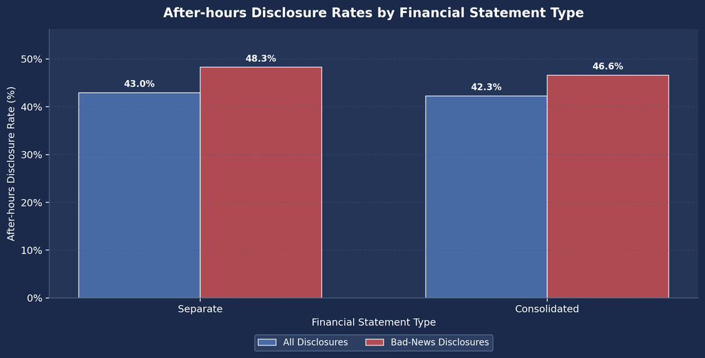

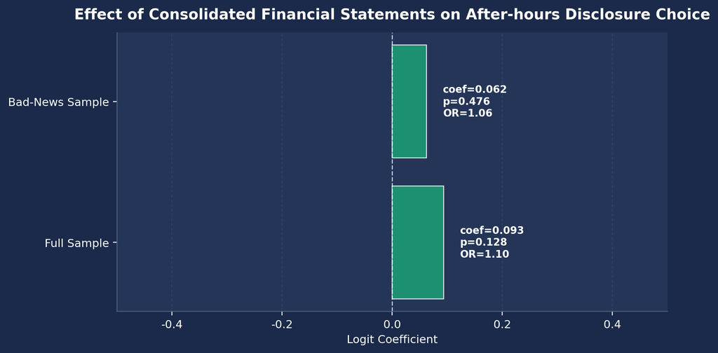

```python
print(
    coef_summary.to_string(
        index=False
    )
)


# ------------------------------------------------------------
# Visualization 1:
# After-hours disclosure rates
# by financial statement type
# ------------------------------------------------------------

fig, ax = plt.subplots(
    figsize=(10, 5.5)
)

fig.patch.set_facecolor(BG_COLOR)
ax.set_facecolor("#243558")


x = np.arange(
    len(fs_summary)
)

width = 0.35


bars1 = ax.bar(
    x - width / 2,
    fs_summary["after_pct"],
    width,
    label="All Disclosures",
    color="#4C72B0",
    alpha=0.88,
    edgecolor="white",
    linewidth=0.8
)


bars2 = ax.bar(
    x + width / 2,
    fs_summary["bad_after_pct"],
    width,
    label="Bad-News Disclosures",
    color="#C44E52",
    alpha=0.88,
    edgecolor="white",
    linewidth=0.8
)


for bars in [bars1, bars2]:

    for bar in bars:

        val = bar.get_height()

        if pd.notna(val):

            ax.text(
                bar.get_x()
                + bar.get_width() / 2,
                val + 0.8,
                f"{val:.1f}%",
                ha="center",
                va="bottom",
                fontsize=9,
                fontweight="bold",
                color="white"
            )


ax.set_xticks(x)

ax.set_xticklabels(
    fs_summary[
        "fs_type"
    ].astype(str)
)


max_y = np.nanmax(
    [
        fs_summary["after_pct"].max(),
        fs_summary["bad_after_pct"].max()
    ]
)


ax.set_ylim(
    0,
    max_y + 8
)


ax.set_xlabel(
    "Financial Statement Type",
    fontsize=10
)

ax.set_ylabel(
    "After-hours Disclosure Rate (%)",
    fontsize=10
)


ax.set_title(
    "After-hours Disclosure Rates "
    "by Financial Statement Type",
    fontsize=13,
    fontweight="bold",
    pad=12
)


ax.yaxis.set_major_formatter(
    mtick.PercentFormatter()
)


legend = ax.legend(
    loc="upper center",
    bbox_to_anchor=(0.5, -0.12),
    ncol=2,
    fontsize=9,
    framealpha=0.75
)


legend.get_frame().set_facecolor(
    "#32476B"
)

legend.get_frame().set_edgecolor(
    "#5D7092"
)


ax.spines[
    ["top", "right"]
].set_visible(False)

ax.spines[
    ["left", "bottom"]
].set_color("#4A6080")


ax.grid(
    axis="y",
    linestyle="--",
    alpha=0.3,
    color="#4A6080",
    zorder=1
)


plt.tight_layout(
    rect=[0, 0.06, 1, 1]
)


plt.savefig(
    OUTPUT_DIR /
    "08_fs_type_after_ratio.png",
    dpi=150,
    bbox_inches="tight",
    facecolor=BG_COLOR
)


plt.show()


# ------------------------------------------------------------
# Visualization 2:
# Logistic regression coefficient
# for consolidated financial statements
# ------------------------------------------------------------

fig, ax = plt.subplots(
    figsize=(8.5, 4.5)
)

fig.patch.set_facecolor(
    BG_COLOR
)

ax.set_facecolor(
    "#243558"
)


coef_plot = (
    coef_summary.copy()
)

coef_plot[
    "Coefficient_num"
] = (
    coef_plot["Coefficient"]
    .astype(float)
)


colors = [
    "#1D9E75"
    if v > 0
    else "#C44E52"
    for v
    in coef_plot[
        "Coefficient_num"
    ]
]


bars = ax.barh(
    coef_plot["Model"],
    coef_plot[
        "Coefficient_num"
    ],
    color=colors,
    alpha=0.88,
    edgecolor="white",
    linewidth=0.8
)


for bar, coef, p, odds in zip(
    bars,
    coef_plot["Coefficient_num"],
    coef_plot["p_value"],
    coef_plot["Odds_Ratio"]
):

    offset = (
        0.03
        if coef >= 0
        else -0.03
    )

    ax.text(
        coef + offset,
        bar.get_y()
        + bar.get_height() / 2,
        f"coef={coef:.3f}\n"
        f"p={p:.3f}\n"
        f"OR={odds:.2f}",
        ha=(
            "left"
            if coef >= 0
            else "right"
        ),
        va="center",
        fontsize=9,
        fontweight="bold",
        color="white"
    )


x_min = min(
    coef_plot[
        "Coefficient_num"
    ].min() - 0.25,
    -0.5
)

x_max = max(
    coef_plot[
        "Coefficient_num"
    ].max() + 0.25,
    0.5
)


ax.set_xlim(
    x_min,
    x_max
)


ax.axvline(
    0,
    color="white",
    linestyle="--",
    linewidth=1,
    alpha=0.7
)


ax.set_xlabel(
    "Logit Coefficient",
    fontsize=10
)


ax.set_title(
    "Effect of Consolidated Financial Statements "
    "on After-hours Disclosure Choice",
    fontsize=13,
    fontweight="bold",
    pad=12
)


ax.spines[
    ["top", "right"]
].set_visible(False)

ax.spines[
    ["left", "bottom"]
].set_color(
    "#4A6080"
)


ax.grid(
    axis="x",
    linestyle="--",
    alpha=0.3,
    color="#4A6080",
    zorder=1
)


plt.tight_layout()


plt.savefig(
    OUTPUT_DIR /
    "08_fs_type_logit_coef.png",
    dpi=150,
    bbox_inches="tight",
    facecolor=BG_COLOR
)


plt.show()
```

## 14.1 Objective

This section examines whether disclosure timing patterns differ between consolidated and separate financial statements.

Because consolidated financial statements generally involve greater reporting complexity and contain a larger volume of information, firms may be more likely to release consolidated financial statements after market hours.

Accordingly, this analysis tests whether the use of consolidated financial statements is associated with the likelihood of choosing an after-hours disclosure.

## 14.2 Descriptive Statistics

The descriptive results show only a small difference in after-hours disclosure rates between separate and consolidated financial statements.

| Financial Statement Type | Overall After-hours Disclosure Rate | After-hours Disclosure Rate for Bad News |
| --- | --- | --- |
| Separate | 43.0% | 48.3% |
| Consolidated | 42.3% | 46.6% |

These results do not indicate that firms systematically use after-hours disclosures more frequently for consolidated financial statements than for separate financial statements.

## 14.3 Chi-square Test Results

Chi-square tests indicate that the relationship between financial statement type and after-hours disclosure choice is not statistically significant.

**Full sample:**

```
chi2 = 0.201
p = 0.654
```

**Bad-news sample:**

```
chi2 = 0.529
p = 0.467
```

Thus, the results provide no evidence of a statistically significant association between consolidated financial statement status and after-hours disclosure choice.

## 14.4 Logistic Regression Results

The logistic regression results, controlling for market capitalization, KOSDAQ listing status, and Friday disclosures, similarly show that consolidated financial statement status does not have a statistically significant effect on the likelihood of after-hours disclosure.

**Full sample:**

```
is_consolidated = 0.093
p = 0.128
```

**Bad-news sample:**

```
is_consolidated = 0.062
p = 0.476
```

Therefore, there is no statistically significant evidence that disclosures based on consolidated financial statements are more likely to be released after market hours.

By contrast, the bad-news indicator remains a statistically significant positive predictor of after-hours disclosure.

```
bad_dummy = 0.341
p < 0.001
```

Market capitalization also has a statistically significant negative coefficient, indicating that larger firms are less likely to choose after-hours disclosure.

```
log_marcap = -0.113
p < 0.001
```

## 14.5 Overall Interpretation

Overall, the results suggest that disclosure timing decisions are more closely associated with the negative nature of the disclosed information than with whether the disclosure is based on consolidated or separate financial statements.

In other words, firms do not appear to choose after-hours disclosure simply because the financial statements are consolidated. Instead, the presence of bad news appears to be a more important factor associated with the likelihood of after-hours disclosure.

These findings therefore suggest that disclosure timing is more strongly associated with the informational content of the disclosure—particularly its negative nature—than with differences in the technical complexity of the underlying financial statement format.

# 15 Abnormal Trading Volume Analysis

```python
import sys
from pathlib import Path
import numpy as np
import pandas as pd
import matplotlib.pyplot as plt
import matplotlib.ticker as mtick
import matplotlib.font_manager as fm
from scipy import stats
from itertools import combinations
import matplotlib
from matplotlib import rcParams

# ── Output directory
OUTPUT_DIR = Path().resolve() / "outputs"
OUTPUT_DIR.mkdir(parents=True, exist_ok=True)

# ── Font settings
matplotlib.rcParams["font.family"] = "DejaVu Sans"
matplotlib.rcParams["axes.unicode_minus"] = False

# ── Global style
rcParams.update({
    "figure.facecolor" : "#1B2A4A",   # Navy background
    "axes.facecolor"   : "#243558",   # Plot area
    "axes.edgecolor"   : "#4A6080",
    "axes.labelcolor"  : "#FFFFFF",   # White
    "axes.titlecolor"  : "#FFFFFF",   # White
    "xtick.color"      : "#FFFFFF",   # White
    "ytick.color"      : "#FFFFFF",   # White
    "text.color"       : "#FFFFFF",   # White
    "grid.color"       : "#4A6080",
    "grid.linestyle"   : "--",
    "grid.alpha"       : 0.5,
    "font.size"        : 10,
    "axes.titlesize"   : 12,
    "axes.titleweight" : "bold",
    "axes.labelsize"   : 10,
    "legend.framealpha": 0.6,
    "legend.edgecolor" : "#4A6080",
    "legend.facecolor" : "#1B2A4A",
})

# ── Colors
C_GOOD, C_BAD = "#1D9E75", "#C44E52"
C_BEFORE, C_DURING, C_AFTER = "#4C72B0", "#888780", "#C44E52"

# Retain Korean category values used in the source data for processing
TIMING_COLORS = {
    "장전": C_BEFORE,
    "장중": C_DURING,
    "장후": C_AFTER
}

# English labels for visualization
TIMING_LABELS = {
    "장전": "Pre-market",
    "장중": "Intraday",
    "장후": "After-hours"
}

NEWS_LABELS = {
    "호재": "Good News",
    "악재": "Bad News"
}
```

```python
DATA_DIR = resolve_data_dir()

raw_fin  = pd.read_csv(DATA_DIR / "dart_earnings_financials_2019_2026.csv", dtype=str)
raw_ctrl = pd.read_csv(DATA_DIR / "dart_financial_controls_2019_2025.csv")
raw_comp = pd.read_csv(DATA_DIR / "company_krx_fdr_controls_2019_2026.csv")
```

```python
# Filtering
remove = raw_fin["report_nm"].str.contains(
    "전망|기재정정|첨부정정|첨부추가|월별|monthly", na=False, regex=True
)
fin = raw_fin[~remove].copy()
fin["year"] = fin["rcept_dt"].str[:4].astype(int)
fin = fin[fin["year"] <= 2025].copy()

# Remove duplicates, prioritizing consolidated disclosures
fin["is_consolidated"] = fin["report_nm"].str.contains("연결", na=False)
fin = fin.sort_values(
    ["stock_code", "rcept_dt", "is_consolidated", "rcept_no"],
    ascending=[True, True, False, True]
)
fin = fin.drop_duplicates(subset=["stock_code", "rcept_dt"], keep="first")

# Classify disclosure timing
t = fin["rcept_time"].str.split(":", expand=True)
fin["_h"] = pd.to_numeric(t[0], errors="coerce")
fin["_m"] = pd.to_numeric(t[1], errors="coerce")
fin["timing"] = "Intraday"
fin.loc[fin["_h"] < 9, "timing"] = "Pre-market"
fin.loc[(fin["_h"] > 15) | ((fin["_h"] == 15) & (fin["_m"] > 30)), "timing"] = "After-hours"
fin.loc[fin["_h"].isna(), "timing"] = None
fin.drop(columns=["_h", "_m"], inplace=True)
fin["rcept_dt_dt"] = pd.to_datetime(fin["rcept_dt"], format="%Y%m%d")
fin["weekday"] = fin["rcept_dt_dt"].dt.dayofweek

# Classify good and bad news
fin["oi_won"] = pd.to_numeric(fin["operating_income_won"], errors="coerce")
fin = fin.sort_values(["stock_code", "rcept_dt_dt"])
fin["prev_oi"] = fin.groupby("stock_code")["oi_won"].shift(1)
fin["oi_chg_pct"] = np.where(
    fin["prev_oi"].notna() & (fin["prev_oi"] != 0),
    (fin["oi_won"] - fin["prev_oi"]) / fin["prev_oi"].abs(),
    np.nan
)
fin["news"] = np.select(
    [fin["oi_chg_pct"] > 0.10, fin["oi_chg_pct"] < -0.10,
     fin["oi_chg_pct"].between(-0.10, 0.10, inclusive="both")],
    ["Good News", "Bad News", "Neutral"], default="Missing"
)

df = fin.copy()
df_hb = df[df["news"].isin(["Good News", "Bad News"]) & df["timing"].notna()].copy()

print(f"Good News: {df['news'].eq('Good News').sum():,}  Bad News: {df['news'].eq('Bad News').sum():,}")
print(f"Timing: {df['timing'].value_counts().to_dict()}")
```

```
Good News: 4,534  Bad News: 4,030
Timing: {'Intraday': 6362, 'After-hours': 5118, 'Pre-market': 811}
```

### 15.0.1 Abnormal Trading Volume Analysis

```python
# ============================================================
# Abnormal Trading Volume Analysis
# - Detect abnormal increases in trading volume around disclosures
# - Benchmark: Average trading volume from 60 to 11 trading days
# before the disclosure
# - Event window: [-1, +1] relative to the disclosure date
# ============================================================

import numpy as np
import pandas as pd
import matplotlib.pyplot as plt
import matplotlib.ticker as mtick
from scipy import stats
import statsmodels.formula.api as smf

BG_COLOR = "#1B2A4A"

# ------------------------------------------------------------
# Load stock price and trading volume data
# ------------------------------------------------------------

price_df = pd.read_csv(
    DATA_DIR / "stock_price_2018_2026.csv",
    dtype={"stock_code": str},
    low_memory=False
)

price_df["stock_code"] = (
    price_df["stock_code"]
    .astype(str)
    .str.zfill(6)
)

price_df["date"] = pd.to_datetime(
    price_df["date"],
    errors="coerce"
)

# Automatically detect the trading volume column
volume_candidates = [
    "volume",
    "Volume",
    "거래량",
    "vol"
]

volume_col = None

for c in volume_candidates:
    if c in price_df.columns:
        volume_col = c
        break

if volume_col is None:
    print("Available columns:")
    print(price_df.columns.tolist())

    raise ValueError(
        "Trading volume column could not be found."
    )

price_df[volume_col] = pd.to_numeric(
    price_df[volume_col],
    errors="coerce"
)

price_df = (
    price_df
    .dropna(
        subset=[
            "stock_code",
            "date",
            volume_col
        ]
    )
    .copy()
)

price_df = (
    price_df
    .sort_values(
        ["stock_code", "date"]
    )
    .reset_index(drop=True)
)

print(
    f"Detected trading volume column: {volume_col}"
)

print(
    f"Stock price observations: {len(price_df):,}"
)

# ------------------------------------------------------------
# Prepare event data
# ------------------------------------------------------------

vol_df = df_hb.copy()

# Standardize news-type labels so that both
# Korean and English source values can be handled
news_map = {
    "호재": "Good News",
    "악재": "Bad News",
    "Good News": "Good News",
    "Bad News": "Bad News",
    "good": "Good News",
    "bad": "Bad News",
    "GOOD": "Good News",
    "BAD": "Bad News"
}

# Standardize disclosure-timing labels
timing_map = {
    "장전": "Pre-market",
    "장중": "Intraday",
    "장후": "After-hours",

    "Pre-market": "Pre-market",
    "Premarket": "Pre-market",
    "Pre-Market": "Pre-market",
    "Pre Market": "Pre-market",

    "Intraday": "Intraday",
    "Intra-day": "Intraday",

    "After-hours": "After-hours",
    "After Hours": "After-hours",
    "After-hours Disclosure": "After-hours",
    "After Market": "After-hours"
}

vol_df["news_std"] = (
    vol_df["news"]
    .astype(str)
    .str.strip()
    .map(news_map)
)

vol_df["timing_std"] = (
    vol_df["timing"]
    .astype(str)
    .str.strip()
    .map(timing_map)
)

# Keep only observations used in this analysis
vol_df = vol_df[
    vol_df["news_std"].isin(
        ["Good News", "Bad News"]
    )
    &
    vol_df["timing_std"].isin(
        [
            "Pre-market",
            "Intraday",
            "After-hours"
        ]
    )
].copy()


if len(vol_df) == 0:

    print(
        "\nUnique values in df_hb['news']:"
    )
    print(
        df_hb["news"]
        .dropna()
        .unique()
    )

    print(
        "\nUnique values in df_hb['timing']:"
    )
    print(
        df_hb["timing"]
        .dropna()
        .unique()
    )

    raise ValueError(
        "No observations remain after "
        "standardizing news and timing labels."
    )

vol_df["stock_code"] = (
    vol_df["stock_code"]
    .astype(str)
    .str.zfill(6)
)

# Robustly convert disclosure dates
if pd.api.types.is_datetime64_any_dtype(
    vol_df["rcept_dt"]
):

    vol_df["rcept_dt_dt"] = pd.to_datetime(
        vol_df["rcept_dt"],
        errors="coerce"
    )

else:

    vol_df["rcept_dt_dt"] = pd.to_datetime(
        vol_df["rcept_dt"]
        .astype(str)
        .str.replace(
            r"\.0$",
            "",
            regex=True
        ),
        format="%Y%m%d",
        errors="coerce"
    )

vol_df["after_dummy"] = (
    vol_df["timing_std"]
    == "After-hours"
).astype(int)

vol_df["bad_dummy"] = (
    vol_df["news_std"]
    == "Bad News"
).astype(int)

print(
    "\nNews type distribution:"
)

print(
    vol_df["news_std"]
    .value_counts()
)

print(
    "\nDisclosure timing distribution:"
)

print(
    vol_df["timing_std"]
    .value_counts()
)

print(
    "\nMissing disclosure dates: "
    f"{vol_df['rcept_dt_dt'].isna().sum():,}"
)

# Remove observations without a valid disclosure date
vol_df = (
    vol_df
    .dropna(
        subset=["rcept_dt_dt"]
    )
    .copy()
)

# ------------------------------------------------------------
# Create a stock-level price data dictionary
# ------------------------------------------------------------

price_by_stock = {
    code: g.reset_index(drop=True)
    for code, g
    in price_df.groupby("stock_code")
}


def get_event_index(
    stock_data,
    event_date,
    after_dummy
):
    """
    Identify the trading-day index corresponding
    to the disclosure event.

    For an after-hours disclosure, the next
    trading day is treated as the primary
    market-reaction date.
    """

    dates = (
        stock_data["date"]
        .values
        .astype("datetime64[ns]")
    )

    event_date = np.datetime64(
        pd.Timestamp(event_date)
    )

    # After-hours disclosures:
    # use the next trading day
    if after_dummy == 1:

        idx = np.searchsorted(
            dates,
            event_date,
            side="right"
        )

    # Pre-market / intraday disclosures:
    # use the event date or the next available
    # trading day
    else:

        idx = np.searchsorted(
            dates,
            event_date,
            side="left"
        )
```

```python
    if idx >= len(stock_data):
        return None

    return idx


def calc_volume_abnormality(
    stock_code,
    event_date,
    after_dummy,
    base_start=-60,
    base_end=-11,
    event_start=-1,
    event_end=1,
    min_base_obs=20
):
    """
    Calculate abnormal trading volume around
    a disclosure event.

    Baseline volume:
        Mean trading volume from t=-60 to t=-11.

    Event volume:
        Mean trading volume from t=-1 to t=+1.

    Volume ratio:
        Event-period average volume divided by
        baseline average volume.

    Volume spike:
        Equals 1 when event-period average
        trading volume is at least twice the
        baseline average.
    """

    stock_data = price_by_stock.get(
        stock_code
    )

    if (
        stock_data is None
        or len(stock_data) == 0
    ):

        return pd.Series({
            "base_volume": np.nan,
            "event_volume": np.nan,
            "volume_ratio": np.nan,
            "log_volume_ratio": np.nan,
            "volume_spike": np.nan
        })

    event_idx = get_event_index(
        stock_data=stock_data,
        event_date=event_date,
        after_dummy=after_dummy
    )

    if event_idx is None:

        return pd.Series({
            "base_volume": np.nan,
            "event_volume": np.nan,
            "volume_ratio": np.nan,
            "log_volume_ratio": np.nan,
            "volume_spike": np.nan
        })

    base_s = event_idx + base_start
    base_e = event_idx + base_end

    ev_s = event_idx + event_start
    ev_e = event_idx + event_end

    # Ensure that the full windows are available
    if (
        base_s < 0
        or base_e < 0
        or ev_s < 0
        or ev_e >= len(stock_data)
    ):

        return pd.Series({
            "base_volume": np.nan,
            "event_volume": np.nan,
            "volume_ratio": np.nan,
            "log_volume_ratio": np.nan,
            "volume_spike": np.nan
        })

    base = (
        stock_data
        .iloc[
            base_s:base_e + 1
        ][volume_col]
        .dropna()
    )

    event = (
        stock_data
        .iloc[
            ev_s:ev_e + 1
        ][volume_col]
        .dropna()
    )

    if (
        len(base) < min_base_obs
        or len(event) == 0
    ):

        return pd.Series({
            "base_volume": np.nan,
            "event_volume": np.nan,
            "volume_ratio": np.nan,
            "log_volume_ratio": np.nan,
            "volume_spike": np.nan
        })

    base_volume = base.mean()
    event_volume = event.mean()

    if (
        pd.isna(base_volume)
        or base_volume <= 0
    ):

        volume_ratio = np.nan

    else:

        volume_ratio = (
            event_volume
            / base_volume
        )

    if (
        pd.notna(volume_ratio)
        and volume_ratio > 0
    ):

        log_volume_ratio = np.log(
            volume_ratio
        )

    else:

        log_volume_ratio = np.nan

    # A volume spike is defined as event-period
    # volume at least twice the baseline level
    if pd.notna(volume_ratio):

        volume_spike = int(
            volume_ratio >= 2
        )

    else:

        volume_spike = np.nan

    return pd.Series({
        "base_volume": base_volume,
        "event_volume": event_volume,
        "volume_ratio": volume_ratio,
        "log_volume_ratio": log_volume_ratio,
        "volume_spike": volume_spike
    })


# ------------------------------------------------------------
# Calculate abnormal trading volume
# ------------------------------------------------------------

print(
    "\nCalculating abnormal trading volume..."
)

vol_features = vol_df.apply(
    lambda x: calc_volume_abnormality(
        stock_code=x["stock_code"],
        event_date=x["rcept_dt_dt"],
        after_dummy=x["after_dummy"]
    ),
    axis=1
)

# Explicitly define output columns to avoid errors
# when the input sample is unexpectedly empty
expected_feature_cols = [
    "base_volume",
    "event_volume",
    "volume_ratio",
    "log_volume_ratio",
    "volume_spike"
]

if len(vol_features) == 0:

    vol_features = pd.DataFrame(
        columns=expected_feature_cols
    )

elif isinstance(
    vol_features,
    pd.Series
):

    vol_features = pd.DataFrame(
        vol_features.tolist(),
        index=vol_df.index
    )

# Ensure all expected columns exist
for col in expected_feature_cols:

    if col not in vol_features.columns:
        vol_features[col] = np.nan

vol_features = (
    vol_features[
        expected_feature_cols
    ]
    .reset_index(drop=True)
)

vol_df = pd.concat(
    [
        vol_df.reset_index(drop=True),
        vol_features
    ],
    axis=1
)

print(
    "Calculation complete."
)

print(
    f"Valid volume-ratio observations: "
    f"{vol_df['volume_ratio'].notna().sum():,}"
)

if (
    vol_df["volume_ratio"]
    .notna()
    .sum()
    == 0
):

    raise ValueError(
        "No valid abnormal-volume observations "
        "were generated. Check whether stock codes, "
        "disclosure dates, and stock-price dates match."
    )

print(
    "\n=== Descriptive Statistics: "
    "Abnormal Trading Volume ==="
)

print(
    vol_df[
        [
            "volume_ratio",
            "log_volume_ratio",
            "volume_spike"
        ]
    ]
    .describe()
)

print(
    "\nMissing rate for volume ratio: "
    f"{vol_df['volume_ratio'].isna().mean() * 100:.1f}%"
)

print(
    "Share of observations with volume spikes "
    "(≥ 2× baseline): "
    f"{vol_df['volume_spike'].mean() * 100:.1f}%"
)

# ------------------------------------------------------------
# Volume spike rates by news type and disclosure timing
# ------------------------------------------------------------

group_summary = (
    vol_df
    .dropna(
        subset=["volume_spike"]
    )
    .groupby(
        [
            "news_std",
            "timing_std"
        ],
        observed=True
    )
    .agg(
        n=(
            "volume_spike",
            "size"
        ),
        spike_pct=(
            "volume_spike",
            "mean"
        ),
        mean_volume_ratio=(
            "volume_ratio",
            "mean"
        ),
        median_volume_ratio=(
            "volume_ratio",
            "median"
        )
    )
    .reset_index()
)
```

```python
group_summary[
    "spike_pct"
] *= 100

print(
    "\n=== Volume Spike Rates by "
    "News Type and Disclosure Timing ==="
)

print(
    group_summary
    .round({
        "spike_pct": 1,
        "mean_volume_ratio": 2,
        "median_volume_ratio": 2
    })
    .to_string(
        index=False
    )
)

# ------------------------------------------------------------
# Compare bad-news after-hours disclosures
# with other disclosures
# ------------------------------------------------------------

vol_df["bad_after"] = (
    (
        vol_df["bad_dummy"] == 1
    )
    &
    (
        vol_df["after_dummy"] == 1
    )
).astype(int)

test_df = (
    vol_df
    .dropna(
        subset=[
            "volume_spike",
            "log_volume_ratio"
        ]
    )
    .copy()
)

bad_after_vol = (
    test_df
    .loc[
        test_df["bad_after"] == 1,
        "log_volume_ratio"
    ]
)

other_vol = (
    test_df
    .loc[
        test_df["bad_after"] == 0,
        "log_volume_ratio"
    ]
)

print(
    "\n=== Bad-News After-Hours vs. "
    "Other Disclosures: "
    "Difference in Trading Volume Growth ==="
)

print(
    f"Bad News - After-hours: "
    f"n={len(bad_after_vol):,}"
)

print(
    f"Other Disclosures: "
    f"n={len(other_vol):,}"
)

if (
    len(bad_after_vol) >= 2
    and len(other_vol) >= 2
):

    t_stat, p_val = stats.ttest_ind(
        bad_after_vol,
        other_vol,
        equal_var=False,
        nan_policy="omit"
    )

    print(
        "Mean log volume ratio "
        "(Bad News - After-hours): "
        f"{bad_after_vol.mean():.3f}"
    )

    print(
        "Mean log volume ratio "
        "(Other Disclosures): "
        f"{other_vol.mean():.3f}"
    )

    print(
        "Difference: "
        f"{bad_after_vol.mean() - other_vol.mean():.3f}"
    )

    print(
        f"t-stat: {t_stat:.3f}"
    )

    print(
        f"p-value: {p_val:.4f}"
    )

else:

    print(
        "Insufficient observations "
        "for the Welch two-sample t-test."
    )

# ------------------------------------------------------------
# Logistic regression:
# Probability of an abnormal volume spike
# ------------------------------------------------------------

# Create Friday dummy robustly
if "weekday" in test_df.columns:

    if pd.api.types.is_numeric_dtype(
        test_df["weekday"]
    ):

        test_df["fri_dummy"] = (
            test_df["weekday"] == 4
        ).astype(int)

    else:

        weekday_text = (
            test_df["weekday"]
            .astype(str)
            .str.strip()
            .str.lower()
        )

        test_df["fri_dummy"] = (
            weekday_text.isin(
                [
                    "4",
                    "friday",
                    "fri",
                    "금요일"
                ]
            )
        ).astype(int)

else:

    test_df["fri_dummy"] = (
        pd.to_datetime(
            test_df["rcept_dt_dt"]
        )
        .dt.weekday
        .eq(4)
        .astype(int)
    )

reg_vol = test_df[
    [
        "volume_spike",
        "after_dummy",
        "bad_dummy",
        "bad_after",
        "fri_dummy"
    ]
].dropna().copy()

print(
    "\n=== Logistic Regression: "
    "Probability of an Abnormal Volume Spike ==="
)

if (
    len(reg_vol) == 0
    or reg_vol["volume_spike"].nunique() < 2
):

    print(
        "Logistic regression could not be estimated "
        "because the dependent variable has "
        "insufficient variation."
    )

    logit_vol = None

else:

    try:

        logit_vol = smf.logit(
            "volume_spike ~ "
            "after_dummy + "
            "bad_dummy + "
            "bad_after + "
            "fri_dummy",
            data=reg_vol
        ).fit(
            disp=False
        )

        print(
            logit_vol.summary()
        )

    except Exception as e:

        logit_vol = None

        print(
            "Logistic regression could not be estimated:"
        )

        print(
            str(e)
        )

# ------------------------------------------------------------
# Visualization 1:
# Volume spike rates by news type
# and disclosure timing
# ------------------------------------------------------------

plot_df = group_summary.copy()

if len(plot_df) > 0:

    # Set a consistent category order
    news_order = [
        "Good News",
        "Bad News"
    ]

    timing_order = [
        "Pre-market",
        "Intraday",
        "After-hours"
    ]

    plot_df["news_order"] = (
        plot_df["news_std"]
        .map({
            v: i
            for i, v
            in enumerate(news_order)
        })
    )

    plot_df["timing_order"] = (
        plot_df["timing_std"]
        .map({
            v: i
            for i, v
            in enumerate(timing_order)
        })
    )

    plot_df = (
        plot_df
        .sort_values(
            [
                "news_order",
                "timing_order"
            ]
        )
        .reset_index(drop=True)
    )

    plot_df["group"] = (
        plot_df["news_std"]
        + " · "
        + plot_df["timing_std"]
    )

    fig, ax = plt.subplots(
        figsize=(11, 5.5)
    )

    fig.patch.set_facecolor(
        BG_COLOR
    )

    ax.set_facecolor(
        "#243558"
    )

    colors = [
        "#1D9E75"
        if news == "Good News"
        else "#C44E52"
        for news
        in plot_df["news_std"]
    ]

    bars = ax.bar(
        plot_df["group"],
        plot_df["spike_pct"],
        color=colors,
        alpha=0.85,
        edgecolor="white",
        linewidth=0.8
    )

    for (
        bar,
        pct,
        n
    ) in zip(
        bars,
        plot_df["spike_pct"],
        plot_df["n"]
    ):

        ax.text(
            bar.get_x()
            + bar.get_width() / 2,
            pct + 1.0,
            f"{pct:.1f}%\n(n={int(n):,})",
            ha="center",
            va="bottom",
            fontsize=9,
            fontweight="bold",
            color="white"
        )

    ymax = (
        plot_df["spike_pct"]
        .max()
    )
```

```
Detected trading volume column: volume
Stock price observations: 1,657,925

News type distribution:
news_std
Good News    4527
Bad News     4024
Name: count, dtype: int64

Disclosure timing distribution:
timing_std
Intraday       4354
After-hours    3624
Pre-market      573
Name: count, dtype: int64

Missing disclosure dates: 0

Calculating abnormal trading volume...
Calculation complete.
Valid volume-ratio observations: 8,541

=== Descriptive Statistics: Abnormal Trading Volume ===
       volume_ratio  log_volume_ratio  volume_spike
count   8541.000000       8531.000000   8541.000000
mean       2.068034          0.138253      0.218944
std        6.878849          0.911613      0.413555
min        0.000000         -3.803061      0.000000
25%        0.692000         -0.365319      0.000000
50%        1.125275          0.118657      0.000000
75%        1.849508          0.615655      0.000000
max      286.799096          5.658782      1.000000

Missing rate for volume ratio: 0.1%
Share of observations with volume spikes (≥ 2× baseline): 21.9%

=== Volume Spike Rates by News Type and Disclosure Timing ===
 news_std  timing_std    n  spike_pct  mean_volume_ratio  median_volume_ratio
 Bad News After-hours 1886       17.7               1.62                 1.04
 Bad News    Intraday 1891       18.0               1.83                 1.06
```

[output cut: 18 more lines]

```
Model:                          Logit   Df Residuals:                     8526
Method:                           MLE   Df Model:                            4
Date:                Sun, 30 Aug 2026   Pseudo R-squ.:                 0.01203
Time:                        19:22:17   Log-Likelihood:                -4432.4
converged:                       True   LL-Null:                       -4486.4
Covariance Type:            nonrobust   LLR p-value:                 2.015e-22
===============================================================================
                  coef    std err          z      P>|z|      [0.025      0.975]
-------------------------------------------------------------------------------
Intercept      -0.9135      0.044    -20.773      0.000      -1.000      -0.827
after_dummy    -0.2966      0.072     -4.136      0.000      -0.437      -0.156
bad_dummy      -0.5784      0.071     -8.165      0.000      -0.717      -0.440
bad_after       0.3020      0.110      2.756      0.006       0.087       0.517
fri_dummy      -0.2134      0.067     -3.205      0.001      -0.344      -0.083
===============================================================================
```

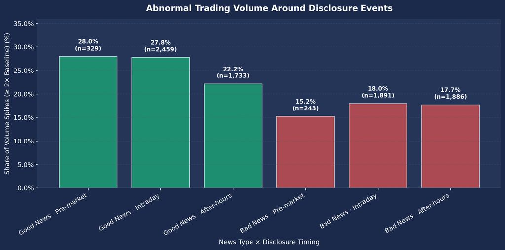

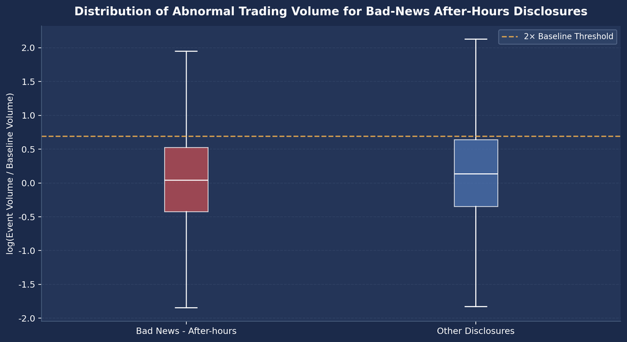

```python
    ax.set_ylim(
        0,
        ymax + 8
    )

    ax.set_xlabel(
        "News Type × Disclosure Timing",
        fontsize=10
    )

    ax.set_ylabel(
        "Share of Volume Spikes "
        "(≥ 2× Baseline) (%)",
        fontsize=10
    )

    ax.set_title(
        "Abnormal Trading Volume "
        "Around Disclosure Events",
        fontsize=13,
        fontweight="bold",
        pad=12
    )

    ax.yaxis.set_major_formatter(
        mtick.PercentFormatter(
            xmax=100
        )
    )

    ax.spines[
        ["top", "right"]
    ].set_visible(False)

    ax.spines[
        ["left", "bottom"]
    ].set_color(
        "#4A6080"
    )

    ax.grid(
        axis="y",
        linestyle="--",
        alpha=0.3,
        color="#4A6080"
    )

    ax.tick_params(
        axis="x",
        colors="white"
    )

    ax.tick_params(
        axis="y",
        colors="white"
    )

    ax.xaxis.label.set_color(
        "white"
    )

    ax.yaxis.label.set_color(
        "white"
    )

    ax.title.set_color(
        "white"
    )

    plt.xticks(
        rotation=30,
        ha="right"
    )

    plt.tight_layout()

    plt.savefig(
        OUTPUT_DIR
        / "09_volume_spike_by_news_timing.png",
        dpi=150,
        bbox_inches="tight",
        facecolor=BG_COLOR
    )

    plt.show()

else:

    print(
        "\nVisualization 1 skipped: "
        "no valid group-level observations."
    )

# ------------------------------------------------------------
# Visualization 2:
# Distribution of abnormal trading volume
# ------------------------------------------------------------

if (
    len(bad_after_vol) > 0
    and len(other_vol) > 0
):

    fig, ax = plt.subplots(
        figsize=(10, 5.5)
    )

    fig.patch.set_facecolor(
        BG_COLOR
    )

    ax.set_facecolor(
        "#243558"
    )

    plot_data = [
        bad_after_vol,
        other_vol
    ]

    # Compatible with both older and newer
    # Matplotlib versions
    try:

        box = ax.boxplot(
            plot_data,
            tick_labels=[
                "Bad News - After-hours",
                "Other Disclosures"
            ],
            patch_artist=True,
            showfliers=False
        )

    except TypeError:

        box = ax.boxplot(
            plot_data,
            labels=[
                "Bad News - After-hours",
                "Other Disclosures"
            ],
            patch_artist=True,
            showfliers=False
        )

    box_colors = [
        "#C44E52",
        "#4C72B0"
    ]

    for patch, color in zip(
        box["boxes"],
        box_colors
    ):

        patch.set_facecolor(
            color
        )

        patch.set_alpha(
            0.75
        )

        patch.set_edgecolor(
            "white"
        )

    for element in [
        "whiskers",
        "caps",
        "medians"
    ]:

        for item in box[element]:

            item.set_color(
                "white"
            )

            item.set_linewidth(
                1.2
            )

    ax.axhline(
        np.log(2),
        color="#FFB74D",
        linestyle="--",
        linewidth=1.5,
        alpha=0.8,
        label="2× Baseline Threshold"
    )

    ax.set_ylabel(
        "log(Event Volume / Baseline Volume)",
        fontsize=10
    )

    ax.set_title(
        "Distribution of Abnormal Trading Volume "
        "for Bad-News After-Hours Disclosures",
        fontsize=13,
        fontweight="bold",
        pad=12
    )

    legend = ax.legend(
        loc="upper right",
        fontsize=9,
        framealpha=0.75
    )

    legend.get_frame().set_facecolor(
        "#32476B"
    )

    legend.get_frame().set_edgecolor(
        "#5D7092"
    )

    for text in legend.get_texts():
        text.set_color(
            "white"
        )

    ax.spines[
        ["top", "right"]
    ].set_visible(False)

    ax.spines[
        ["left", "bottom"]
    ].set_color(
        "#4A6080"
    )

    ax.grid(
        axis="y",
        linestyle="--",
        alpha=0.3,
        color="#4A6080"
    )

    ax.tick_params(
        axis="x",
        colors="white"
    )

    ax.tick_params(
        axis="y",
        colors="white"
    )

    ax.xaxis.label.set_color(
        "white"
    )

    ax.yaxis.label.set_color(
        "white"
    )

    ax.title.set_color(
        "white"
    )

    plt.tight_layout()

    plt.savefig(
        OUTPUT_DIR
        / "09_volume_ratio_boxplot.png",
        dpi=150,
        bbox_inches="tight",
        facecolor=BG_COLOR
    )

    plt.show()

else:

    print(
        "\nVisualization 2 skipped: "
        "one or both comparison groups "
        "have no valid observations."
    )
```

## 15.1 Objective

This section examines changes in trading volume around disclosure events to assess how after-hours disclosures are associated with market attention and trading activity.

In particular, abnormal trading volume around disclosure dates is measured to indirectly evaluate the intensity of investor reactions to disclosed information.

Abnormal trading volume is measured as the ratio of average trading volume during the event window `[-1, +1]` to average trading volume during the baseline period from 60 to 11 trading days before the disclosure. A **volume spike** is defined as an event-period trading volume at least twice the baseline average.

## 15.2 Descriptive Statistics

Across the full sample, approximately **21.9%** of disclosure events experienced a volume spike.

The mean volume ratio was **2.07**, while the median was approximately **1.13**, indicating that the mean was driven upward by a relatively small number of observations with exceptionally large increases in trading volume.

## 15.3 Trading Volume Response by News Type and Disclosure Timing

The results show that good-news disclosures are associated with substantially higher volume-spike rates than bad-news disclosures.

| Disclosure Type | Volume Spike Rate |
| --- | --- |
| Bad News - Pre-market | 15.2% |
| Bad News - Intraday | 18.0% |
| Bad News - After-hours | 17.7% |
| Good News - Pre-market | 28.0% |
| Good News - Intraday | 27.8% |
| Good News - After-hours | 22.2% |

These results indicate that positive information is associated with stronger trading-volume responses than negative information.

After-hours disclosures also generally exhibit lower volume-spike rates than intraday disclosures, although the magnitude of this difference varies by news type.

## 15.4 Trading Volume Effects of Bad-News After-Hours Disclosures

A comparison between bad-news after-hours disclosures and all other disclosures shows that the former are associated with a lower average increase in trading volume.

```
Mean log volume ratio (Bad News - After-hours) = 0.041
Mean log volume ratio (Other Disclosures)      = 0.166
Difference                                     = -0.125
t-stat                                         = -5.538
p-value                                        < 0.001
```

The difference is statistically significant, providing no evidence that bad-news after-hours disclosures are associated with unusually large increases in trading volume relative to other disclosures.

Instead, the results suggest that immediate trading activity surrounding bad-news after-hours disclosures is relatively limited compared with other disclosure events.

## 15.5 Logistic Regression Results

A logistic regression with the occurrence of a volume spike as the dependent variable shows that after-hours disclosure is significantly negatively associated with the probability of a volume spike.

```
after_dummy = -0.297
p < 0.001
```

Bad-news disclosure is also significantly negatively associated with the probability of a volume spike.

```
bad_dummy = -0.578
p < 0.001
```

By contrast, the interaction term between bad news and after-hours disclosure is positive and statistically significant.

```
bad_after = +0.302
p = 0.006
```

This positive interaction indicates that the negative association between after-hours disclosure and volume-spike probability is partially attenuated for bad-news disclosures. In other words, although both bad news and after-hours timing are individually associated with lower volume-spike probabilities, their combined effect is less negative than would be implied by simply adding the two main effects.

Nevertheless, the descriptive results show that the absolute volume-spike rate for bad-news after-hours disclosures remains lower than that observed for good-news disclosures.

## 15.6 Overall Interpretation

Overall, the results indicate that after-hours disclosures are associated with weaker trading-volume responses than disclosures released during regular market hours.

Bad-news after-hours disclosures do not exhibit unusually large volume spikes; instead, their average trading-volume increase is significantly lower than that of other disclosure events. This pattern is consistent with the possibility that releasing information after market hours may reduce immediate market attention and trading activity.

However, the positive interaction between bad news and after-hours disclosure suggests that the reduction in volume-spike probability associated with after-hours timing is partially offset when the disclosed information is negative.

Taken together, these findings suggest that disclosure timing is systematically associated with the intensity of trading activity around corporate announcements. However, the results should be interpreted as evidence of **association rather than causal evidence** that firms deliberately use after-hours disclosure to suppress market attention.

# 16 Opening Price Gap Analysis

```python
import sys
from pathlib import Path
import numpy as np
import pandas as pd
import matplotlib.pyplot as plt
import matplotlib.ticker as mtick
import matplotlib.font_manager as fm
from scipy import stats
from itertools import combinations
import matplotlib
from matplotlib import rcParams

# ── Output directory
OUTPUT_DIR = Path().resolve() / "outputs"
OUTPUT_DIR.mkdir(parents=True, exist_ok=True)

# ── Font settings
matplotlib.rcParams["font.family"] = "DejaVu Sans"
matplotlib.rcParams["axes.unicode_minus"] = False

# ── Global style
rcParams.update({
    "figure.facecolor" : "#1B2A4A",   # Navy background
    "axes.facecolor"   : "#243558",   # Plot area
    "axes.edgecolor"   : "#4A6080",
    "axes.labelcolor"  : "#FFFFFF",   # White
    "axes.titlecolor"  : "#FFFFFF",   # White
    "xtick.color"      : "#FFFFFF",   # White
    "ytick.color"      : "#FFFFFF",   # White
    "text.color"       : "#FFFFFF",   # White
    "grid.color"       : "#4A6080",
    "grid.linestyle"   : "--",
    "grid.alpha"       : 0.5,
    "font.size"        : 10,
    "axes.titlesize"   : 12,
    "axes.titleweight" : "bold",
    "axes.labelsize"   : 10,
    "legend.framealpha": 0.6,
    "legend.edgecolor" : "#4A6080",
    "legend.facecolor" : "#1B2A4A",
})

# ── Colors
C_GOOD, C_BAD = "#1D9E75", "#C44E52"
C_BEFORE, C_DURING, C_AFTER = "#4C72B0", "#888780", "#C44E52"

# Retain Korean category values used in the source data for processing
TIMING_COLORS = {
    "장전": C_BEFORE,
    "장중": C_DURING,
    "장후": C_AFTER
}

# English labels for visualization
TIMING_LABELS = {
    "장전": "Pre-market",
    "장중": "Intraday",
    "장후": "After-hours"
}

NEWS_LABELS = {
    "호재": "Good News",
    "악재": "Bad News"
}
```

```python
DATA_DIR = resolve_data_dir()

raw_fin  = pd.read_csv(DATA_DIR / "dart_earnings_financials_2019_2026.csv", dtype=str)
raw_ctrl = pd.read_csv(DATA_DIR / "dart_financial_controls_2019_2025.csv")
raw_comp = pd.read_csv(DATA_DIR / "company_krx_fdr_controls_2019_2026.csv")
```

```python
# Filtering
remove = raw_fin["report_nm"].str.contains(
    "전망|기재정정|첨부정정|첨부추가|월별|monthly", na=False, regex=True
)
fin = raw_fin[~remove].copy()
fin["year"] = fin["rcept_dt"].str[:4].astype(int)
fin = fin[fin["year"] <= 2025].copy()

# Remove duplicates, prioritizing consolidated disclosures
fin["is_consolidated"] = fin["report_nm"].str.contains("연결", na=False)
fin = fin.sort_values(
    ["stock_code", "rcept_dt", "is_consolidated", "rcept_no"],
    ascending=[True, True, False, True]
)
fin = fin.drop_duplicates(subset=["stock_code", "rcept_dt"], keep="first")

# Classify disclosure timing
t = fin["rcept_time"].str.split(":", expand=True)
fin["_h"] = pd.to_numeric(t[0], errors="coerce")
fin["_m"] = pd.to_numeric(t[1], errors="coerce")
fin["timing"] = "Intraday"
fin.loc[fin["_h"] < 9, "timing"] = "Pre-market"
fin.loc[(fin["_h"] > 15) | ((fin["_h"] == 15) & (fin["_m"] > 30)), "timing"] = "After-hours"
fin.loc[fin["_h"].isna(), "timing"] = None
fin.drop(columns=["_h", "_m"], inplace=True)
fin["rcept_dt_dt"] = pd.to_datetime(fin["rcept_dt"], format="%Y%m%d")
fin["weekday"] = fin["rcept_dt_dt"].dt.dayofweek

# Classify good and bad news
fin["oi_won"] = pd.to_numeric(fin["operating_income_won"], errors="coerce")
fin = fin.sort_values(["stock_code", "rcept_dt_dt"])
fin["prev_oi"] = fin.groupby("stock_code")["oi_won"].shift(1)
fin["oi_chg_pct"] = np.where(
    fin["prev_oi"].notna() & (fin["prev_oi"] != 0),
    (fin["oi_won"] - fin["prev_oi"]) / fin["prev_oi"].abs(),
    np.nan
)
fin["news"] = np.select(
    [fin["oi_chg_pct"] > 0.10, fin["oi_chg_pct"] < -0.10,
     fin["oi_chg_pct"].between(-0.10, 0.10, inclusive="both")],
    ["Good News", "Bad News", "Neutral"], default="Missing"
)

df = fin.copy()
df_hb = df[df["news"].isin(["Good News", "Bad News"]) & df["timing"].notna()].copy()

print(f"Good News: {df['news'].eq('Good News').sum():,}  Bad News: {df['news'].eq('Bad News').sum():,}")
print(f"Timing: {df['timing'].value_counts().to_dict()}")
```

```
Good News: 4,534  Bad News: 4,030
Timing: {'Intraday': 6362, 'After-hours': 5118, 'Pre-market': 811}
```

### 16.0.1 Opening Price Gap Analysis

```python
price_df = pd.read_csv(
    DATA_DIR / "stock_price_2018_2026.csv",
    dtype={"stock_code": str},
    low_memory=False
)

price_df["stock_code"] = price_df["stock_code"].astype(str).str.zfill(6)
price_df["date"] = pd.to_datetime(price_df["date"])

print(price_df.columns.tolist())
print(price_df.shape)
print(price_df.head(3))
```

```
['date', 'open', 'high', 'low', 'close', 'volume', 'change', 'stock_code']
(1657925, 8)
        date   open   high    low  close  volume    change stock_code
0 2018-07-02  62116  63317  61515  61716  103017 -0.004308     285130
1 2018-07-03  61916  62249  60648  61049   72274 -0.010808     285130
2 2018-07-04  60515  62850  60515  61516   75423  0.007650     285130
```

```python
print(price_df.columns.tolist())
```

```
['date', 'open', 'high', 'low', 'close', 'volume', 'change', 'stock_code']
```

```python
# ============================================================
# Opening Price Gap Analysis
# - Analyze opening price gaps following after-hours bad-news disclosures
# - Gap return = (next open - previous close) / previous close
# ============================================================


# ------------------------------------------------------------
# Load stock price data
# ------------------------------------------------------------

price_df = pd.read_csv(
    DATA_DIR / "stock_price_2018_2026.csv",
    dtype={"stock_code": str},
    low_memory=False
)

price_df["stock_code"] = (
    price_df["stock_code"]
    .astype(str)
    .str.zfill(6)
)

price_df["date"] = pd.to_datetime(
    price_df["date"]
)

price_df["open"] = pd.to_numeric(
    price_df["open"],
    errors="coerce"
)

price_df["close"] = pd.to_numeric(
    price_df["close"],
    errors="coerce"
)

price_df = price_df.dropna(
    subset=["stock_code", "date", "open", "close"]
)

price_df = (
    price_df
    .sort_values(["stock_code", "date"])
    .reset_index(drop=True)
)


price_by_stock = {
    code: g.reset_index(drop=True)
    for code, g in price_df.groupby("stock_code")
}


print(f"Stock price data loaded: {price_df.shape}")


# ------------------------------------------------------------
# Prepare event data
# ------------------------------------------------------------

gap_df = df_hb.copy()


# Standardize news labels
news_map = {
    "호재": "Good News",
    "악재": "Bad News",
    "Good News": "Good News",
    "Bad News": "Bad News",
    "good": "Good News",
    "bad": "Bad News"
}

gap_df["news_std"] = (
    gap_df["news"]
    .astype(str)
    .str.strip()
    .replace(news_map)
)


# Standardize disclosure timing labels
timing_map = {
    "장전": "Pre-market",
    "장중": "Intraday",
    "장후": "After-hours",
    "Pre-market": "Pre-market",
    "Pre-Market": "Pre-market",
    "Premarket": "Pre-market",
    "Pre Market": "Pre-market",
    "Intraday": "Intraday",
    "Intra-day": "Intraday",
    "After-hours": "After-hours",
    "After-Hours": "After-hours",
    "After Hours": "After-hours",
    "After Market": "After-hours"
}

gap_df["timing_std"] = (
    gap_df["timing"]
    .astype(str)
    .str.strip()
    .replace(timing_map)
)


# Keep only valid news and timing observations
gap_df = gap_df[
    gap_df["news_std"].isin(
        ["Good News", "Bad News"]
    )
    &
    gap_df["timing_std"].isin(
        ["Pre-market", "Intraday", "After-hours"]
    )
].copy()


print(
    f"Analysis sample size before gap calculation: "
    f"{len(gap_df):,}"
)

if len(gap_df) == 0:
    raise ValueError(
        "No valid observations remain after filtering. "
        "Check the unique values in the 'news' and 'timing' columns."
    )


gap_df["stock_code"] = (
    gap_df["stock_code"]
    .astype(str)
    .str.zfill(6)
)

gap_df["rcept_dt_dt"] = pd.to_datetime(
    gap_df["rcept_dt"].astype(str),
    format="%Y%m%d",
    errors="coerce"
)


gap_df["after_dummy"] = (
    gap_df["timing_std"] == "After-hours"
).astype(int)

gap_df["bad_dummy"] = (
    gap_df["news_std"] == "Bad News"
).astype(int)


# Create Friday dummy
if "weekday" in gap_df.columns:

    weekday_numeric = pd.to_numeric(
        gap_df["weekday"],
        errors="coerce"
    )

    if weekday_numeric.notna().any():

        gap_df["fri_dummy"] = (
            weekday_numeric == 4
        ).astype(int)

    else:

        gap_df["fri_dummy"] = (
            gap_df["weekday"]
            .astype(str)
            .str.strip()
            .str.lower()
            .isin(["friday", "fri", "금요일"])
        ).astype(int)

else:

    gap_df["fri_dummy"] = (
        gap_df["rcept_dt_dt"].dt.weekday == 4
    ).astype(int)


# Market-capitalization tertiles
if "log_marcap" in gap_df.columns:

    gap_df["log_marcap"] = pd.to_numeric(
        gap_df["log_marcap"],
        errors="coerce"
    )

    try:

        gap_df["size_group"] = pd.qcut(
            gap_df["log_marcap"],
            q=3,
            labels=[
                "Small-cap",
                "Mid-cap",
                "Large-cap"
            ]
        )

    except ValueError:

        print(
            "Market-capitalization groups could not be created "
            "because there are insufficient unique values."
        )


# ------------------------------------------------------------
# Define opening price gap calculation
# ------------------------------------------------------------

def calc_gap(stock_code, event_date, after_dummy):

    stock_data = price_by_stock.get(stock_code)

    if (
        stock_data is None
        or len(stock_data) < 2
        or pd.isna(event_date)
    ):
        return np.nan


    dates = stock_data["date"].values


    # After-hours disclosure:
    # the next trading day's opening price represents
    # the first market reaction.
    if after_dummy == 1:

        # Closing price on the disclosure date
        idx = np.searchsorted(
            dates,
            np.datetime64(event_date),
            side="left"
        )

        if idx >= len(stock_data) - 1:
            return np.nan

        close_price = stock_data.loc[
            idx,
            "close"
        ]

        open_price = stock_data.loc[
            idx + 1,
            "open"
        ]


    # Intraday / pre-market disclosure:
    # compare the previous trading day's close
    # with the disclosure day's opening price.
    else:

        idx = np.searchsorted(
            dates,
            np.datetime64(event_date),
            side="left"
        )

        if idx == 0 or idx >= len(stock_data):
            return np.nan

        close_price = stock_data.loc[
            idx - 1,
            "close"
        ]

        open_price = stock_data.loc[
            idx,
            "open"
        ]


    if (
        pd.isna(close_price)
        or pd.isna(open_price)
        or close_price <= 0
    ):
        return np.nan


    return (
        (open_price - close_price)
        / close_price
    )
```

```python
# ------------------------------------------------------------
# Calculate opening price gap returns
# ------------------------------------------------------------

print(
    "\nCalculating opening price gap returns..."
)


gap_df["gap_return"] = gap_df.apply(
    lambda x: calc_gap(
        stock_code=x["stock_code"],
        event_date=x["rcept_dt_dt"],
        after_dummy=x["after_dummy"]
    ),
    axis=1
)


gap_df = gap_df.dropna(
    subset=["gap_return"]
).copy()


if len(gap_df) == 0:
    raise ValueError(
        "No valid opening price gap returns were calculated. "
        "Check stock codes, disclosure dates, and stock price dates."
    )


# Winsorize extreme values at the 1st and 99th percentiles
lower = gap_df["gap_return"].quantile(0.01)
upper = gap_df["gap_return"].quantile(0.99)

gap_df["gap_return"] = (
    gap_df["gap_return"]
    .clip(lower, upper)
)


print(
    f"Gap return calculation completed: "
    f"{len(gap_df):,} observations"
)

print(
    "\n=== Descriptive Statistics: Opening Price Gap Returns ==="
)

print(
    gap_df["gap_return"]
    .describe()
    .round(4)
)


# ------------------------------------------------------------
# Mean opening price gap returns by group
# ------------------------------------------------------------

group_gap = (
    gap_df
    .groupby(
        ["news_std", "timing_std"],
        observed=False
    )["gap_return"]
    .agg(
        ["mean", "median", "count"]
    )
    .reset_index()
)


group_gap.columns = [
    "news",
    "timing",
    "mean_gap",
    "median_gap",
    "n"
]


group_gap["mean_gap_pct"] = (
    group_gap["mean_gap"] * 100
)

group_gap["median_gap_pct"] = (
    group_gap["median_gap"] * 100
)


# Set explicit category order
news_order = [
    "Good News",
    "Bad News"
]

timing_order = [
    "Pre-market",
    "Intraday",
    "After-hours"
]


group_gap["news"] = pd.Categorical(
    group_gap["news"],
    categories=news_order,
    ordered=True
)

group_gap["timing"] = pd.Categorical(
    group_gap["timing"],
    categories=timing_order,
    ordered=True
)

group_gap = (
    group_gap
    .sort_values(
        ["news", "timing"]
    )
    .reset_index(drop=True)
)


print(
    "\n=== Mean Opening Price Gap Returns "
    "by News Type and Disclosure Timing ==="
)

print(
    group_gap
    .round(3)
    .to_string(index=False)
)


# ------------------------------------------------------------
# Key comparison tests
# ------------------------------------------------------------

def ttest_groups(
    df,
    col,
    mask1,
    mask2,
    label1,
    label2
):

    g1 = (
        df.loc[mask1, col]
        .dropna()
    )

    g2 = (
        df.loc[mask2, col]
        .dropna()
    )


    print(
        f"\n[{label1}] vs [{label2}]"
    )


    if len(g1) < 2 or len(g2) < 2:

        print(
            "  Test could not be performed: "
            "insufficient observations."
        )

        return np.nan, np.nan


    t, p = stats.ttest_ind(
        g1,
        g2,
        equal_var=False,
        nan_policy="omit"
    )


    print(
        f"  Mean: "
        f"{g1.mean() * 100:.3f}% "
        f"vs "
        f"{g2.mean() * 100:.3f}%"
    )

    print(
        f"  Difference: "
        f"{(g1.mean() - g2.mean()) * 100:+.3f}%p"
    )

    print(
        f"  t = {t:.3f}, "
        f"p = {p:.4f} "
        f"{'(Significant)' if p < 0.05 else '(Not significant)'}"
    )


    return t, p


print(
    "\n=== Key Comparison Tests ==="
)


# Bad News - After-hours vs Bad News - Intraday
ttest_groups(
    gap_df,
    "gap_return",

    (
        (gap_df["news_std"] == "Bad News")
        &
        (gap_df["timing_std"] == "After-hours")
    ),

    (
        (gap_df["news_std"] == "Bad News")
        &
        (gap_df["timing_std"] == "Intraday")
    ),

    "Bad News - After-hours",
    "Bad News - Intraday"
)


# Bad News - After-hours vs Good News - After-hours
ttest_groups(
    gap_df,
    "gap_return",

    (
        (gap_df["news_std"] == "Bad News")
        &
        (gap_df["timing_std"] == "After-hours")
    ),

    (
        (gap_df["news_std"] == "Good News")
        &
        (gap_df["timing_std"] == "After-hours")
    ),

    "Bad News - After-hours",
    "Good News - After-hours"
)


# Friday Bad News - After-hours
# vs Non-Friday Bad News - After-hours
ttest_groups(
    gap_df,
    "gap_return",

    (
        (gap_df["news_std"] == "Bad News")
        &
        (gap_df["timing_std"] == "After-hours")
        &
        (gap_df["fri_dummy"] == 1)
    ),

    (
        (gap_df["news_std"] == "Bad News")
        &
        (gap_df["timing_std"] == "After-hours")
        &
        (gap_df["fri_dummy"] == 0)
    ),

    "Friday Bad News - After-hours",
    "Non-Friday Bad News - After-hours"
)


# Small-cap Bad News - After-hours
# vs Large-cap Bad News - After-hours
if "size_group" in gap_df.columns:

    ttest_groups(
        gap_df,
        "gap_return",

        (
            (gap_df["news_std"] == "Bad News")
            &
            (gap_df["timing_std"] == "After-hours")
            &
            (gap_df["size_group"] == "Small-cap")
        ),

        (
            (gap_df["news_std"] == "Bad News")
            &
            (gap_df["timing_std"] == "After-hours")
            &
            (gap_df["size_group"] == "Large-cap")
        ),

        "Small-cap Bad News - After-hours",
        "Large-cap Bad News - After-hours"
    )


# ------------------------------------------------------------
# Visualization 1:
# Mean opening price gap returns by group
# ------------------------------------------------------------

BG_COLOR = "#1B2A4A"


fig, ax = plt.subplots(
    figsize=(11, 5.5)
)

fig.patch.set_facecolor(
    BG_COLOR
)

ax.set_facecolor(
    "#243558"
)


group_gap["label"] = (
    group_gap["news"].astype(str)
    + " · "
    + group_gap["timing"].astype(str)
)


colors = [
    "#1D9E75"
    if news == "Good News"
    else "#C44E52"
    for news in group_gap["news"]
]


bars = ax.bar(
    group_gap["label"],
    group_gap["mean_gap_pct"],
    color=colors,
    alpha=0.85,
    edgecolor="white",
    linewidth=0.8
)
```

```
Stock price data loaded: (1657925, 8)
Analysis sample size before gap calculation: 8,551

Calculating opening price gap returns...
Gap return calculation completed: 8,551 observations

=== Descriptive Statistics: Opening Price Gap Returns ===
count    8551.0000
mean        0.0020
std         0.0188
min        -0.0557
25%        -0.0062
50%         0.0000
75%         0.0089
max         0.0770
Name: gap_return, dtype: float64

=== Mean Opening Price Gap Returns by News Type and Disclosure Timing ===
     news      timing  mean_gap  median_gap    n  mean_gap_pct  median_gap_pct
Good News  Pre-market     0.013       0.010  330         1.328           1.024
Good News    Intraday     0.002       0.000 2460         0.153           0.000
Good News After-hours     0.011       0.006 1737         1.094           0.642
 Bad News  Pre-market    -0.001       0.000  243        -0.089           0.000
 Bad News    Intraday     0.001       0.000 1894         0.057           0.000
 Bad News After-hours    -0.006      -0.004 1887        -0.567          -0.364

=== Key Comparison Tests ===

[Bad News - After-hours] vs [Bad News - Intraday]
  Mean: -0.567% vs 0.057%
  Difference: -0.624%p
  t = -11.741, p = 0.0000 (Significant)

[Bad News - After-hours] vs [Good News - After-hours]
  Mean: -0.567% vs 1.094%
  Difference: -1.661%p
  t = -22.221, p = 0.0000 (Significant)

[Friday Bad News - After-hours] vs [Non-Friday Bad News - After-hours]
  Mean: -0.663% vs -0.537%
  Difference: -0.126%p
  t = -1.126, p = 0.2606 (Not significant)
```

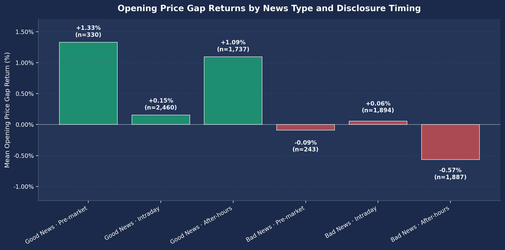

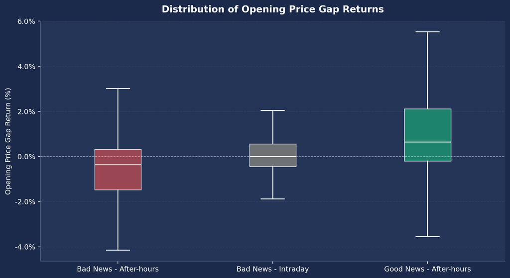

```python
y_min = group_gap["mean_gap_pct"].min()
y_max = group_gap["mean_gap_pct"].max()
y_range = y_max - y_min


ax.set_ylim(
    y_min - max(
        0.25,
        y_range * 0.35
    ),
    y_max + max(
        0.25,
        y_range * 0.20
    )
)


# Adjust label positions to prevent overlap
for i, (bar, val, n) in enumerate(
    zip(
        bars,
        group_gap["mean_gap_pct"],
        group_gap["n"]
    )
):

    x = (
        bar.get_x()
        + bar.get_width() / 2
    )


    if val >= 0:

        y = val + 0.07
        va = "bottom"

    else:

        y = val - 0.13
        va = "top"


    if abs(val) < 0.12:

        if val >= 0:

            y = val + 0.12
            va = "bottom"

        else:

            y = val - 0.16
            va = "top"


    ax.text(
        x,
        y,
        f"{val:+.2f}%\n"
        f"(n={int(n):,})",
        ha="center",
        va=va,
        fontsize=9,
        fontweight="bold",
        color="white",
        clip_on=False
    )


ax.axhline(
    0,
    color="white",
    linewidth=0.8,
    alpha=0.5
)


ax.set_ylabel(
    "Mean Opening Price Gap Return (%)",
    fontsize=10,
    color="white"
)


ax.set_title(
    "Opening Price Gap Returns "
    "by News Type and Disclosure Timing",
    fontsize=13,
    fontweight="bold",
    pad=12,
    color="white"
)


ax.yaxis.set_major_formatter(
    mtick.FormatStrFormatter("%.2f%%")
)


ax.spines[
    ["top", "right"]
].set_visible(False)

ax.spines[
    ["left", "bottom"]
].set_color(
    "#4A6080"
)


ax.tick_params(
    axis="x",
    colors="white",
    labelsize=9
)

ax.tick_params(
    axis="y",
    colors="white",
    labelsize=9
)


ax.grid(
    axis="y",
    linestyle="--",
    alpha=0.3,
    color="#4A6080"
)


plt.xticks(
    rotation=30,
    ha="right"
)

plt.tight_layout()


plt.savefig(
    OUTPUT_DIR /
    "10_gap_by_news_timing.png",
    dpi=150,
    bbox_inches="tight",
    facecolor=BG_COLOR
)


plt.show()


# ------------------------------------------------------------
# Visualization 2:
# Distribution of opening price gap returns
# ------------------------------------------------------------

fig, ax = plt.subplots(
    figsize=(10, 5.5)
)

fig.patch.set_facecolor(
    BG_COLOR
)

ax.set_facecolor(
    "#243558"
)


plot_groups = [

    (
        "Bad News - After-hours",

        (
            (gap_df["news_std"] == "Bad News")
            &
            (gap_df["timing_std"] == "After-hours")
        ),

        "#C44E52"
    ),

    (
        "Bad News - Intraday",

        (
            (gap_df["news_std"] == "Bad News")
            &
            (gap_df["timing_std"] == "Intraday")
        ),

        "#888780"
    ),

    (
        "Good News - After-hours",

        (
            (gap_df["news_std"] == "Good News")
            &
            (gap_df["timing_std"] == "After-hours")
        ),

        "#1D9E75"
    )
]


plot_data = [
    gap_df.loc[
        mask,
        "gap_return"
    ].dropna() * 100

    for _, mask, _ in plot_groups
]


plot_labels = [
    label
    for label, _, _ in plot_groups
]

plot_colors = [
    color
    for _, _, color in plot_groups
]


# Compatible with both newer and older Matplotlib versions
try:

    box = ax.boxplot(
        plot_data,
        tick_labels=plot_labels,
        patch_artist=True,
        showfliers=False
    )

except TypeError:

    box = ax.boxplot(
        plot_data,
        labels=plot_labels,
        patch_artist=True,
        showfliers=False
    )


for patch, color in zip(
    box["boxes"],
    plot_colors
):

    patch.set_facecolor(
        color
    )

    patch.set_alpha(
        0.75
    )

    patch.set_edgecolor(
        "white"
    )


for element in [
    "whiskers",
    "caps",
    "medians"
]:

    for item in box[element]:

        item.set_color(
            "white"
        )

        item.set_linewidth(
            1.2
        )


ax.axhline(
    0,
    color="white",
    linewidth=0.8,
    alpha=0.5,
    linestyle="--"
)


ax.set_ylabel(
    "Opening Price Gap Return (%)",
    fontsize=10
)


ax.set_title(
    "Distribution of Opening Price Gap Returns",
    fontsize=13,
    fontweight="bold",
    pad=12
)


ax.yaxis.set_major_formatter(
    mtick.PercentFormatter()
)


ax.spines[
    ["top", "right"]
].set_visible(False)

ax.spines[
    ["left", "bottom"]
].set_color(
    "#4A6080"
)


ax.grid(
    axis="y",
    linestyle="--",
    alpha=0.3,
    color="#4A6080"
)


plt.tight_layout()


plt.savefig(
    OUTPUT_DIR /
    "10_gap_boxplot.png",
    dpi=150,
    bbox_inches="tight",
    facecolor=BG_COLOR
)


plt.show()
```

```python
# ------------------------------------------------------------
# Merge market capitalization data
# ------------------------------------------------------------

if "log_marcap" not in gap_df.columns:

    raw_comp_gap = raw_comp.copy()

    raw_comp_gap["stock_code"] = (
        raw_comp_gap["stock_code"]
        .astype(str)
        .str.zfill(6)
    )

    gap_df = gap_df.merge(
        raw_comp_gap[
            ["stock_code", "log_marcap"]
        ]
        .drop_duplicates(subset="stock_code"),
        on="stock_code",
        how="left"
    )


gap_df["log_marcap"] = pd.to_numeric(
    gap_df["log_marcap"],
    errors="coerce"
)


print(
    f"Missing rate for log_marcap: "
    f"{gap_df['log_marcap'].isna().mean() * 100:.1f}%"
)


# ------------------------------------------------------------
# Classify firms into market-capitalization tertiles
# ------------------------------------------------------------

gap_df["size_group"] = pd.qcut(
    gap_df["log_marcap"],
    q=3,
    labels=[
        "Small-cap",
        "Mid-cap",
        "Large-cap"
    ]
)


print(
    "\n=== Market Capitalization Groups ==="
)

print(
    gap_df["size_group"]
    .value_counts()
    .sort_index()
)


# ------------------------------------------------------------
# Compare opening price gaps:
# Small-cap vs Large-cap bad-news after-hours disclosures
# ------------------------------------------------------------

ttest_groups(
    gap_df,
    "gap_return",

    (
        (gap_df["news_std"] == "Bad News")
        &
        (gap_df["timing_std"] == "After-hours")
        &
        (gap_df["size_group"] == "Small-cap")
    ),

    (
        (gap_df["news_std"] == "Bad News")
        &
        (gap_df["timing_std"] == "After-hours")
        &
        (gap_df["size_group"] == "Large-cap")
    ),

    "Small-cap Bad News - After-hours",
    "Large-cap Bad News - After-hours"
)
```

```
Missing rate for log_marcap: 0.0%

=== Market Capitalization Groups ===
size_group
Small-cap    2857
Mid-cap      2845
Large-cap    2849
Name: count, dtype: int64

[Small-cap Bad News - After-hours] vs [Large-cap Bad News - After-hours]
  Mean: -0.618% vs -0.496%
  Difference: -0.122%p
  t = -1.050, p = 0.2938 (Not significant)
```

```
(np.float64(-1.0503328473106153), np.float64(0.29378410557032414))
```

## 16.1 Objective

This section examines how disclosure timing and information direction (good news vs. bad news) are associated with opening price gap returns.

In particular, the analysis tests whether after-hours disclosures are associated with stronger opening price reactions, as investors have more time to process and disseminate information before the next trading session.

Accordingly, mean opening price gap returns are compared across news types and disclosure timing categories.

## 16.2 Descriptive Statistics

The results show that after-hours disclosures are associated with substantially larger opening price gap returns in absolute terms than intraday disclosures.

| Disclosure Type | Mean Opening Price Gap Return |
| --- | --- |
| Bad News - Pre-market | -0.089% |
| Bad News - Intraday | +0.057% |
| Bad News - After-hours | -0.567% |
| Good News - Pre-market | +1.328% |
| Good News - Intraday | +0.153% |
| Good News - After-hours | +1.094% |

Bad-news after-hours disclosures exhibit a pronounced negative opening price gap, while good-news after-hours disclosures are associated with a substantial positive gap.

By contrast, intraday disclosures show relatively small opening price gaps for both good and bad news.

This pattern is consistent with the interpretation that information released during trading hours may already be partially incorporated into prices during the same trading session, whereas information released after market close is reflected more directly in the opening price of the next trading session.

## 16.3 Mean Difference Tests

### 16.3.1 (1) Bad News - After-hours vs. Bad News - Intraday

Bad-news after-hours disclosures are associated with significantly lower opening price gap returns than bad-news intraday disclosures.

```
Bad News - After-hours: -0.567%
Bad News - Intraday:    +0.057%
Difference:             -0.624%p

t = -11.741
p < 0.001
```

The difference is statistically significant, indicating that bad news disclosed after market hours is associated with a substantially more negative opening price reaction than bad news disclosed during trading hours.

### 16.3.2 (2) Bad News - After-hours vs. Good News - After-hours

A substantial difference is also observed between bad-news and good-news after-hours disclosures.

```
Bad News - After-hours:  -0.567%
Good News - After-hours: +1.094%
Difference:              -1.661%p

t = -22.221
p < 0.001
```

This result indicates that opening price reactions to after-hours disclosures differ substantially according to the direction of the disclosed information.

In particular, good news released after market hours is associated with a strong positive opening price gap, whereas bad news is associated with a negative opening price gap.

## 16.4 Additional Tests

### 16.4.1 (1) Friday After-hours Bad-News Effect

Friday after-hours bad-news disclosures exhibit a more negative mean opening price gap than non-Friday after-hours bad-news disclosures, but the difference is not statistically significant.

```
Friday Bad News - After-hours:     -0.663%
Non-Friday Bad News - After-hours: -0.537%
Difference:                        -0.126%p

t = -1.126
p = 0.261
```

Thus, the results provide no statistically significant evidence that the additional information-processing time over the weekend produces a larger negative opening price gap.

### 16.4.2 (2) Differences by Market Capitalization

Small-cap firms with bad-news after-hours disclosures exhibit a more negative mean opening price gap than large-cap firms, but the difference is not statistically significant.

```
Small-cap Bad News - After-hours: -0.618%
Large-cap Bad News - After-hours: -0.496%
Difference:                       -0.122%p

t = -1.050
p = 0.294
```

Therefore, the results provide no statistically significant evidence that the opening price gap associated with bad-news after-hours disclosures differs systematically between small- and large-cap firms.

## 16.5 Distributional Characteristics

The boxplot analysis shows that the distribution of opening price gap returns for good-news after-hours disclosures is shifted toward positive values.

By contrast, bad-news after-hours disclosures exhibit a negative median and a relatively extended lower tail.

This pattern suggests that bad-news after-hours disclosures are associated not only with a more negative average opening price reaction but also with the possibility of relatively large negative opening gaps for some firms.

The distributional evidence therefore highlights potential downside risk in addition to differences in mean opening price responses.

## 16.6 Overall Interpretation

Overall, the results indicate a strong association between disclosure timing, information direction, and opening price reactions.

After-hours disclosures exhibit substantially larger opening price gaps in absolute terms than intraday disclosures, with the direction of the reaction differing clearly between good and bad news. Bad news released after market hours is associated with a significant negative opening price gap, whereas good news released after market hours is associated with a substantial positive gap.

The results are consistent with a market-adjustment mechanism in which information released during trading hours can be incorporated into prices before the market closes, while information released after market close is reflected more directly in the opening price of the next trading session.

However, the Friday and market-capitalization subgroup tests do not provide statistically significant evidence of additional heterogeneity within bad-news after-hours disclosures.

Taken together, these findings suggest that after-hours disclosure timing is systematically associated with the concentration of price adjustment at the next market opening. Because the analysis is observational, however, the results should be interpreted as evidence of association rather than as causal evidence that after-hours disclosure itself produces the observed price reactions.

# 17 Additional Intraday Price Declines

```python
# ============================================================
# Cell 1 - Environment Setup
# ============================================================

import sys
from pathlib import Path

import numpy as np
import pandas as pd
import matplotlib.pyplot as plt
import matplotlib.ticker as mtick
import matplotlib
from matplotlib import rcParams
from scipy import stats


# ------------------------------------------------------------
# Output directory
# ------------------------------------------------------------

OUTPUT_DIR = Path().resolve() / "outputs"
OUTPUT_DIR.mkdir(parents=True, exist_ok=True)


# ------------------------------------------------------------
# Matplotlib font settings
# ------------------------------------------------------------

matplotlib.rcParams["font.family"] = "DejaVu Sans"
matplotlib.rcParams["axes.unicode_minus"] = False


# ------------------------------------------------------------
# Global visualization settings
# ------------------------------------------------------------

rcParams.update({
    "figure.facecolor": "#1B2A4A",
    "axes.facecolor": "#243558",
    "axes.edgecolor": "#4A6080",
    "axes.labelcolor": "#FFFFFF",
    "axes.titlecolor": "#FFFFFF",
    "xtick.color": "#FFFFFF",
    "ytick.color": "#FFFFFF",
    "text.color": "#FFFFFF",
    "grid.color": "#4A6080",
    "grid.linestyle": "--",
    "grid.alpha": 0.5,
    "font.size": 10,
    "axes.titlesize": 12,
    "axes.titleweight": "bold",
    "axes.labelsize": 10,
    "legend.framealpha": 0.6,
    "legend.edgecolor": "#4A6080",
    "legend.facecolor": "#1B2A4A",
})


# ------------------------------------------------------------
# Color palette
# ------------------------------------------------------------

BG_COLOR = "#1B2A4A"

C_GOOD = "#1D9E75"
C_BAD = "#C44E52"

C_BEFORE = "#4C72B0"
C_DURING = "#888780"
C_AFTER = "#C44E52"
```

```python
# ============================================================
# Cell 2 - Data Loading
# ============================================================

DATA_DIR = resolve_data_dir()

raw_fin = pd.read_csv(
    DATA_DIR / "dart_earnings_financials_2019_2026.csv",
    dtype=str
)

raw_ctrl = pd.read_csv(
    DATA_DIR / "dart_financial_controls_2019_2025.csv"
)

raw_comp = pd.read_csv(
    DATA_DIR / "company_krx_fdr_controls_2019_2026.csv"
)
```

```python
# ============================================================
# Create df_hb
# ============================================================

# ------------------------------------------------------------
# Filter out non-target reports
# ------------------------------------------------------------

remove = raw_fin["report_nm"].str.contains(
    "전망|기재정정|첨부정정|첨부추가|월별|monthly",
    na=False,
    regex=True
)

fin = raw_fin[~remove].copy()

fin["year"] = fin["rcept_dt"].str[:4].astype(int)
fin = fin[fin["year"] <= 2025].copy()


# ------------------------------------------------------------
# Identify consolidated financial statements
# ------------------------------------------------------------

# "연결" is retained because it is a literal value
# contained in Korean DART report-name strings.
fin["is_consolidated"] = fin["report_nm"].str.contains(
    "연결",
    na=False
)

fin = fin.sort_values(
    ["stock_code", "rcept_dt", "is_consolidated", "rcept_no"],
    ascending=[True, True, False, True]
)

fin = fin.drop_duplicates(
    subset=["stock_code", "rcept_dt"],
    keep="first"
)


# ------------------------------------------------------------
# Classify disclosure timing
# ------------------------------------------------------------

t = fin["rcept_time"].str.split(":", expand=True)

fin["_h"] = pd.to_numeric(t[0], errors="coerce")
fin["_m"] = pd.to_numeric(t[1], errors="coerce")

fin["timing"] = "Intraday"

fin.loc[
    fin["_h"] < 9,
    "timing"
] = "Pre-market"

fin.loc[
    (fin["_h"] > 15)
    | ((fin["_h"] == 15) & (fin["_m"] > 30)),
    "timing"
] = "After-hours"

fin.loc[
    fin["_h"].isna(),
    "timing"
] = None

fin.drop(
    columns=["_h", "_m"],
    inplace=True
)


# ------------------------------------------------------------
# Create date and weekday variables
# ------------------------------------------------------------

fin["rcept_dt_dt"] = pd.to_datetime(
    fin["rcept_dt"],
    format="%Y%m%d"
)

fin["weekday"] = fin["rcept_dt_dt"].dt.dayofweek


# ------------------------------------------------------------
# Calculate changes in operating income
# ------------------------------------------------------------

fin["oi_won"] = pd.to_numeric(
    fin["operating_income_won"],
    errors="coerce"
)

fin = fin.sort_values(
    ["stock_code", "rcept_dt_dt"]
)

fin["prev_oi"] = (
    fin.groupby("stock_code")["oi_won"]
    .shift(1)
)

fin["oi_chg_pct"] = np.where(
    fin["prev_oi"].notna()
    & (fin["prev_oi"] != 0),

    (fin["oi_won"] - fin["prev_oi"])
    / fin["prev_oi"].abs(),

    np.nan
)


# ------------------------------------------------------------
# Classify news direction
# ------------------------------------------------------------

fin["news"] = np.select(
    [
        fin["oi_chg_pct"] > 0.10,
        fin["oi_chg_pct"] < -0.10,
        fin["oi_chg_pct"].between(
            -0.10,
            0.10,
            inclusive="both"
        )
    ],
    [
        "Good News",
        "Bad News",
        "Neutral"
    ],
    default="Missing"
)


# ------------------------------------------------------------
# Construct the final analysis sample
# ------------------------------------------------------------

df = fin.copy()

df_hb = df[
    df["news"].isin(["Good News", "Bad News"])
    & df["timing"].notna()
].copy()


# ------------------------------------------------------------
# Sample summary
# ------------------------------------------------------------


print(
    f"Good News: {df['news'].eq('Good News').sum():,}  "
    f"Bad News: {df['news'].eq('Bad News').sum():,}"
)
```

```
Good News: 4,534  Bad News: 4,030
```

## 17.1 Analysis of Additional Intraday Price Declines

## 17.2 Objective

This section examines whether additional intraday price adjustment occurs after the initial opening price gap following a disclosure.

In particular, the analysis tests whether bad news disclosed after market hours is associated not only with a negative opening price gap but also with additional downward price pressure during the subsequent trading session.

To examine this adjustment process, returns are decomposed into the following components:

- **Gap Return:** Return from the previous trading day’s close to the next trading day’s opening price
- **Intraday Return:** Return from the opening price to the closing price of the same trading day
- **Total Return:** Return from the previous trading day’s close to the closing price of the next trading day

This decomposition allows us to examine whether the price impact of after-hours disclosures is largely incorporated at the market opening or whether additional price adjustment continues during the subsequent trading session.

```python
# ============================================================
# Cell 4 - Load Stock Price Data
# ============================================================

price_df = pd.read_csv(
    DATA_DIR / "stock_price_2018_2026.csv",
    dtype={"stock_code": str},
    low_memory=False
)

price_df["stock_code"] = price_df["stock_code"].astype(str).str.zfill(6)
price_df["date"] = pd.to_datetime(price_df["date"])
price_df["open"] = pd.to_numeric(price_df["open"], errors="coerce")
price_df["close"] = pd.to_numeric(price_df["close"], errors="coerce")

price_df = price_df.dropna(
    subset=["stock_code", "date", "open", "close"]
)

price_df = (
    price_df
    .sort_values(["stock_code", "date"])
    .reset_index(drop=True)
)

price_by_stock = {
    code: g.reset_index(drop=True)
    for code, g in price_df.groupby("stock_code")
}

print(f"Stock price data loaded: {price_df.shape}")
```

```
Stock price data loaded: (1657925, 8)
```

```python
# ============================================================
# Cell 5 - Prepare Event Data
# ============================================================

intra_df = df_hb.copy()

intra_df = intra_df[
    intra_df["news"].isin(["Good News", "Bad News"])
    & intra_df["timing"].isin(["Pre-market", "Intraday", "After-hours"])
].copy()


# ------------------------------------------------------------
# Create event-level variables
# ------------------------------------------------------------

intra_df["stock_code"] = (
    intra_df["stock_code"]
    .astype(str)
    .str.zfill(6)
)

intra_df["rcept_dt_dt"] = pd.to_datetime(
    intra_df["rcept_dt"],
    format="%Y%m%d"
)

intra_df["after_dummy"] = (
    intra_df["timing"] == "After-hours"
).astype(int)

intra_df["bad_dummy"] = (
    intra_df["news"] == "Bad News"
).astype(int)

intra_df["fri_dummy"] = (
    intra_df["weekday"] == 4
).astype(int)


# ------------------------------------------------------------
# Merge market capitalization data
# ------------------------------------------------------------

intra_df = intra_df.merge(
    raw_comp[
        ["stock_code", "log_marcap"]
    ].drop_duplicates(subset="stock_code"),
    on="stock_code",
    how="left"
)


# ------------------------------------------------------------
# Classify firms into market-capitalization tertiles
# ------------------------------------------------------------

intra_df["size_group"] = pd.qcut(
    intra_df["log_marcap"],
    q=3,
    labels=["Small-cap", "Mid-cap", "Large-cap"]
)


# ------------------------------------------------------------
# Sample summary
# ------------------------------------------------------------

print(f"Event sample: {len(intra_df):,} observations")
```

```
Event sample: 8,551 observations
```

```python
# ============================================================
# Cell 6 - Calculate Opening Gap and Intraday Returns
# ============================================================
# Gap Return      = (Next Open - Reference Close) / Reference Close
# Intraday Return = (Next Close - Next Open) / Next Open
# Total Return    = (Next Close - Reference Close) / Reference Close

def calc_returns(stock_code, event_date, after_dummy):
    stock_data = price_by_stock.get(stock_code)

    if stock_data is None or len(stock_data) < 2:
        return pd.Series({
            "gap_return": np.nan,
            "intra_return": np.nan,
            "total_return": np.nan
        })

    dates = stock_data["date"].values

    if after_dummy == 1:
        # After-hours disclosure:
        # Disclosure-day close → Next-day open → Next-day close
        idx = np.searchsorted(
            dates,
            np.datetime64(event_date),
            side="left"
        )

        if idx >= len(stock_data) - 1:
            return pd.Series({
                "gap_return": np.nan,
                "intra_return": np.nan,
                "total_return": np.nan
            })

        ref_close = stock_data.loc[idx, "close"]          # Disclosure-day close
        next_open = stock_data.loc[idx + 1, "open"]      # Next-day open
        next_close = stock_data.loc[idx + 1, "close"]    # Next-day close

    else:
        # Pre-market / Intraday disclosure:
        # Previous-day close → Disclosure-day open → Disclosure-day close
        idx = np.searchsorted(
            dates,
            np.datetime64(event_date),
            side="left"
        )

        if idx == 0 or idx >= len(stock_data):
            return pd.Series({
                "gap_return": np.nan,
                "intra_return": np.nan,
                "total_return": np.nan
            })

        ref_close = stock_data.loc[idx - 1, "close"]     # Previous-day close
        next_open = stock_data.loc[idx, "open"]          # Disclosure-day open
        next_close = stock_data.loc[idx, "close"]        # Disclosure-day close

    if any(
        pd.isna(v) or v <= 0
        for v in [ref_close, next_open, next_close]
    ):
        return pd.Series({
            "gap_return": np.nan,
            "intra_return": np.nan,
            "total_return": np.nan
        })

    gap_return = (
        (next_open - ref_close)
        / ref_close
    )

    intra_return = (
        (next_close - next_open)
        / next_open
    )

    total_return = (
        (next_close - ref_close)
        / ref_close
    )

    return pd.Series({
        "gap_return": gap_return,
        "intra_return": intra_return,
        "total_return": total_return
    })
```

```python
# ============================================================
# Cell 7 - Calculate Returns
# ============================================================

print("Calculating returns...")

returns = intra_df.apply(
    lambda x: calc_returns(
        stock_code=x["stock_code"],
        event_date=x["rcept_dt_dt"],
        after_dummy=x["after_dummy"]
    ),
    axis=1
)

intra_df = pd.concat(
    [
        intra_df.reset_index(drop=True),
        returns.reset_index(drop=True)
    ],
    axis=1
)

# Remove observations with missing return values
intra_df = intra_df.dropna(
    subset=["gap_return", "intra_return", "total_return"]
).copy()


# ------------------------------------------------------------
# Winsorize returns at the 1st and 99th percentiles
# ------------------------------------------------------------

for col in ["gap_return", "intra_return", "total_return"]:
    lo = float(
        intra_df[col].quantile(0.01).iloc[0]
        if hasattr(intra_df[col].quantile(0.01), "iloc")
        else intra_df[col].quantile(0.01)
    )

    hi = float(
        intra_df[col].quantile(0.99).iloc[0]
        if hasattr(intra_df[col].quantile(0.99), "iloc")
        else intra_df[col].quantile(0.99)
    )

    intra_df[col] = intra_df[col].clip(
        lower=lo,
        upper=hi
    )


# ------------------------------------------------------------
# Summary statistics
# ------------------------------------------------------------

print(f"Calculation complete: {len(intra_df):,} observations")

print("\n=== Summary Statistics ===")

print(
    intra_df[
        ["gap_return", "intra_return", "total_return"]
    ]
    .describe()
    .map(lambda x: f"{x * 100:.3f}%")
)
```

```
Calculating returns...
Calculation complete: 8,536 observations

=== Summary Statistics ===
        gap_return intra_return total_return
count  853600.000%  853600.000%  853600.000%
mean        0.216%       0.134%       0.370%
std         1.851%       3.876%       4.419%
min        -5.195%     -10.369%     -11.846%
25%        -0.611%      -1.950%      -1.937%
50%         0.000%       0.000%       0.000%
75%         0.891%       1.902%       2.347%
max         7.707%      13.838%      16.574%
```

## 17.3 Descriptive Statistics

Across the full sample of 8,536 observations, the mean gap return was **+0.216%**, the mean intraday return was **+0.134%**, and the mean total return was **+0.370%**.

The following analysis further examines how these return components vary across news types and disclosure timing categories.

```python
# ============================================================
# Cell 8 - Mean Returns by News Type and Disclosure Timing
# ============================================================

group_ret = (
    intra_df
    .groupby(["news", "timing"])[
        ["gap_return", "intra_return", "total_return"]
    ]
    .mean()
    .reset_index()
)

# Convert returns to percentages
for col in ["gap_return", "intra_return", "total_return"]:
    group_ret[col] = group_ret[col] * 100


print("=== Return Decomposition by News Type and Disclosure Timing (%) ===")
print(
    group_ret
    .round(3)
    .to_string(index=False)
)
```

```
=== Return Decomposition by News Type and Disclosure Timing (%) ===
     news      timing  gap_return  intra_return  total_return
 Bad News After-hours      -0.548        -0.726        -1.268
 Bad News    Intraday       0.064        -0.499        -0.439
 Bad News  Pre-market      -0.062        -0.173        -0.217
Good News After-hours       1.121        -0.101         1.067
Good News    Intraday       0.161         1.450         1.641
Good News  Pre-market       1.332         0.340         1.673
```

### 17.3.1 Return Decomposition by News Type and Disclosure Timing

| Disclosure Type | Gap Return | Intraday Return | Total Return |
| --- | --- | --- | --- |
| Bad News - Pre-market | -0.062% | -0.173% | -0.217% |
| Bad News - Intraday | +0.064% | -0.499% | -0.439% |
| Bad News - After-hours | -0.548% | -0.726% | -1.268% |
| Good News - Pre-market | +1.332% | +0.340% | +1.673% |
| Good News - Intraday | +0.161% | +1.450% | +1.641% |
| Good News - After-hours | +1.121% | -0.101% | +1.067% |

Bad-news after-hours disclosures exhibit a negative opening price gap followed by an additional negative intraday return. The mean gap return is **-0.548%**, while the subsequent intraday return is **-0.726%**, resulting in a total return of **-1.268%**.

By contrast, bad-news intraday disclosures show only a limited opening price reaction (**+0.064%**) but a more pronounced negative return during the trading session (**-0.499%**), suggesting that much of the negative price adjustment occurs intraday.

For good-news disclosures, pre-market and after-hours announcements are associated primarily with positive opening price gaps (**+1.332%** and **+1.121%**, respectively). Good-news intraday disclosures, in contrast, exhibit a relatively small opening gap (**+0.161%**) followed by a substantially larger positive intraday return (**+1.450%**).

Overall, these patterns are consistent with differences in how price adjustment unfolds depending on when information is disclosed. Information released outside trading hours is reflected more strongly in opening prices, whereas information released during trading hours is associated with a greater share of price adjustment occurring within the trading session.

```python
# ============================================================
# Cell 9 - T-Tests
# ============================================================


# ------------------------------------------------------------
# Check for duplicate columns
# ------------------------------------------------------------

print(intra_df.columns.tolist())
print(f"{intra_df.columns.duplicated().sum()} duplicate column(s)")


# ------------------------------------------------------------
# Remove duplicate columns
# ------------------------------------------------------------

intra_df = intra_df.loc[
    :,
    ~intra_df.columns.duplicated()
].copy()


# ------------------------------------------------------------
# Welch's t-test function
# ------------------------------------------------------------

def ttest_groups(df, col, mask1, mask2, label1, label2):

    g1 = df.loc[mask1, col]
    g2 = df.loc[mask2, col]

    t, p = stats.ttest_ind(
        g1.values,
        g2.values,
        equal_var=False,
        nan_policy="omit"
    )

    m1 = float(np.nanmean(g1.values))
    m2 = float(np.nanmean(g2.values))

    print(f"\n[{label1}] vs [{label2}]")

    print(
        f"  Mean: {m1 * 100:.3f}%  vs  "
        f"{m2 * 100:.3f}%"
    )

    print(
        f"  Difference: {(m1 - m2) * 100:+.3f}%p"
    )

    print(
        f"  t={float(t):.3f}, "
        f"p={float(p):.4f}  "
        f"{'★ Significant' if float(p) < 0.05 else 'Not significant'}"
    )


# ------------------------------------------------------------
# Key comparisons: Intraday Return
# ------------------------------------------------------------

print("=== Key Comparisons: Intraday Return ===")


# Bad News - After-hours vs. Bad News - Intraday
ttest_groups(
    intra_df,
    "intra_return",

    (
        (intra_df["news"] == "Bad News")
        & (intra_df["timing"] == "After-hours")
    ),

    (
        (intra_df["news"] == "Bad News")
        & (intra_df["timing"] == "Intraday")
    ),

    "Bad News - After-hours",
    "Bad News - Intraday"
)


# Bad News - After-hours vs. Good News - After-hours
ttest_groups(
    intra_df,
    "intra_return",

    (
        (intra_df["news"] == "Bad News")
        & (intra_df["timing"] == "After-hours")
    ),

    (
        (intra_df["news"] == "Good News")
        & (intra_df["timing"] == "After-hours")
    ),

    "Bad News - After-hours",
    "Good News - After-hours"
)


# ------------------------------------------------------------
# Key comparisons: Total Return
# ------------------------------------------------------------

print("\n=== Key Comparisons: Total Return ===")


# Bad News - After-hours vs. Bad News - Intraday
ttest_groups(
    intra_df,
    "total_return",

    (
        (intra_df["news"] == "Bad News")
        & (intra_df["timing"] == "After-hours")
    ),

    (
        (intra_df["news"] == "Bad News")
        & (intra_df["timing"] == "Intraday")
    ),

    "Bad News - After-hours",
    "Bad News - Intraday"
)
```

```
['corp_code', 'corp_name', 'stock_code', 'corp_cls', 'market', 'report_nm', 'rcept_no', 'flr_nm', 'rcept_dt', 'rm', 'rcept_time', 'sales', 'operating_income', 'net_income', 'amount_unit', 'sales_won', 'operating_income_won', 'net_income_won', 'status', 'reason', 'year', 'is_consolidated', 'timing', …
0 duplicate column(s)
=== Key Comparisons: Intraday Return ===

[Bad News - After-hours] vs [Bad News - Intraday]
  Mean: -0.726%  vs  -0.499%
  Difference: -0.227%p
  t=-2.048, p=0.0407  ★ Significant

[Bad News - After-hours] vs [Good News - After-hours]
  Mean: -0.726%  vs  -0.101%
  Difference: -0.625%p
  t=-5.148, p=0.0000  ★ Significant

=== Key Comparisons: Total Return ===

[Bad News - After-hours] vs [Bad News - Intraday]
  Mean: -1.268%  vs  -0.439%
  Difference: -0.829%p
  t=-6.635, p=0.0000  ★ Significant
```

## 17.4 Tests for Additional Intraday Price Declines

### 17.4.1 (1) Bad News - After-hours vs. Bad News - Intraday

Bad-news after-hours disclosures exhibit a significantly lower intraday return than bad-news intraday disclosures.

```
Bad News - After-hours: -0.726%
Bad News - Intraday:    -0.499%
Difference:             -0.227%p

t = -2.047
p = 0.0407
```

The difference is statistically significant at the 5% level, indicating that bad-news after-hours disclosures are associated with a more negative intraday price adjustment following the market opening.

Combined with the negative opening price gap observed for this group, the result is consistent with additional downward price adjustment continuing during the subsequent trading session rather than being fully incorporated at the market opening.

### 17.4.2 (2) Bad News - After-hours vs. Good News - After-hours

Compared with good-news after-hours disclosures, bad-news after-hours disclosures exhibit a substantially more negative intraday return.

```
Bad News - After-hours:  -0.726%
Good News - After-hours: -0.101%
Difference:              -0.624%p

t = -5.147
p < 0.001
```

This difference is statistically significant, indicating that intraday price movements following after-hours disclosures differ substantially according to the direction of the disclosed information.

Bad-news after-hours disclosures are followed by a negative intraday return even after a negative opening gap. In contrast, good-news after-hours disclosures exhibit a strong positive opening gap but only a small negative intraday return, suggesting that a larger share of the positive price adjustment occurs at the market opening.

## 17.5 Total Return Analysis

Bad-news after-hours disclosures also exhibit a substantially more negative total return than bad-news intraday disclosures.

```
Bad News - After-hours: -1.268%
Bad News - Intraday:    -0.439%
Difference:             -0.829%p

t = -6.634
p < 0.001
```

The difference is statistically significant, showing that bad-news after-hours disclosures are associated not only with a negative opening price gap but also with a substantially more negative price adjustment over the full trading horizon examined.

Taken together with the return decomposition results, the findings indicate that the negative price reaction associated with bad-news after-hours disclosures is not concentrated entirely at the market opening. Instead, the initial negative opening gap is followed by additional negative intraday adjustment, resulting in a larger overall decline.

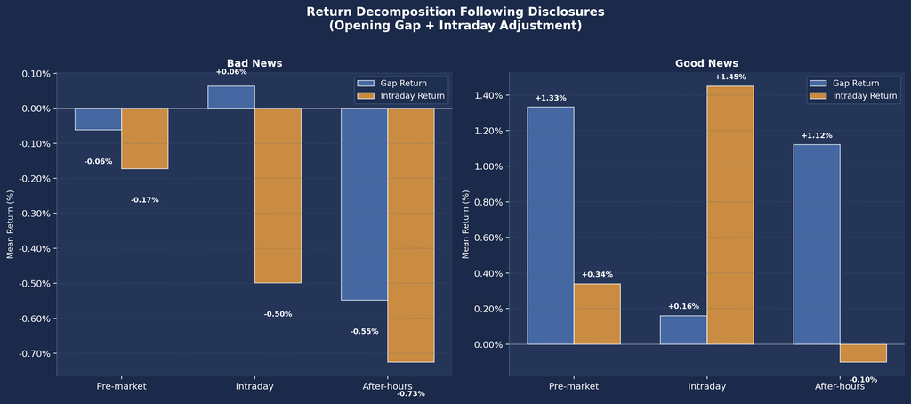

```python
# ============================================================
# Cell 10 - Visualization 1: Return Decomposition Bar Chart
# ============================================================

# Remove duplicate columns if any remain
intra_df = intra_df.loc[:, ~intra_df.columns.duplicated()].copy()


# ------------------------------------------------------------
# Recalculate mean returns by news type and disclosure timing
# ------------------------------------------------------------

group_ret = (
    intra_df
    .groupby(["news", "timing"])[
        ["gap_return", "intra_return", "total_return"]
    ]
    .mean()
    .reset_index()
)

for col in ["gap_return", "intra_return", "total_return"]:
    group_ret[col] = group_ret[col] * 100


# ------------------------------------------------------------
# Create visualization
# ------------------------------------------------------------

fig, axes = plt.subplots(
    1,
    2,
    figsize=(14, 6)
)

fig.patch.set_facecolor(BG_COLOR)

fig.suptitle(
    "Return Decomposition Following Disclosures\n"
    "(Opening Gap + Intraday Adjustment)",
    fontsize=13,
    fontweight="bold",
    color="white",
    y=1.02
)


for ax, news in zip(
    axes,
    ["Bad News", "Good News"]
):

    ax.set_facecolor("#243558")

    sub = (
        group_ret[group_ret["news"] == news]
        .copy()
        .set_index("timing")
        .reindex(
            ["Pre-market", "Intraday", "After-hours"]
        )
    )

    x = np.arange(3)
    w = 0.35

    gap_vals = (
        sub["gap_return"]
        .values
        .astype(float)
    )

    intra_vals = (
        sub["intra_return"]
        .values
        .astype(float)
    )


    # Gap returns
    bars_gap = ax.bar(
        x - w / 2,
        gap_vals,
        w,
        label="Gap Return",
        color="#4C72B0",
        alpha=0.85,
        edgecolor="white",
        linewidth=0.8
    )


    # Intraday returns
    bars_intra = ax.bar(
        x + w / 2,
        intra_vals,
        w,
        label="Intraday Return",
        color="#E89C3F",
        alpha=0.85,
        edgecolor="white",
        linewidth=0.8
    )


    # Value labels
    for bar in list(bars_gap) + list(bars_intra):

        val = bar.get_height()

        if abs(val) > 0.02:

            ax.text(
                bar.get_x() + bar.get_width() / 2,
                val + (
                    0.03
                    if val >= 0
                    else -0.08
                ),
                f"{val:+.2f}%",
                ha="center",
                va=(
                    "bottom"
                    if val >= 0
                    else "top"
                ),
                fontsize=8,
                color="white",
                fontweight="bold"
            )


    # Axis formatting
    ax.axhline(
        0,
        color="white",
        linewidth=0.7,
        alpha=0.5
    )

    ax.set_xticks(x)

    ax.set_xticklabels(
        ["Pre-market", "Intraday", "After-hours"]
    )

    ax.set_title(
        news,
        fontsize=11,
        fontweight="bold"
    )

    ax.set_ylabel(
        "Mean Return (%)",
        fontsize=9
    )

    ax.yaxis.set_major_formatter(
        mtick.FormatStrFormatter("%.2f%%")
    )

    ax.spines[
        ["top", "right"]
    ].set_visible(False)

    ax.spines[
        ["left", "bottom"]
    ].set_color("#4A6080")

    ax.grid(
        axis="y",
        linestyle="--",
        alpha=0.3,
        color="#4A6080"
    )

    ax.legend(
        fontsize=9
    )


# ------------------------------------------------------------
# Save figure
# ------------------------------------------------------------

plt.tight_layout()

plt.savefig(
    OUTPUT_DIR / "11_1_return_decomposition.png",
    dpi=150,
    bbox_inches="tight",
    facecolor=BG_COLOR
)

plt.show()
```

## 17.6 Interpretation of the Return Decomposition

The return decomposition shows distinct patterns in opening price gaps and subsequent intraday returns across disclosure timing categories.

For bad-news disclosures, after-hours announcements exhibit the most negative return pattern.

| Disclosure Type | Gap Return | Intraday Return |
| --- | --- | --- |
| Bad News - Pre-market | -0.06% | -0.17% |
| Bad News - Intraday | +0.06% | -0.50% |
| Bad News - After-hours | -0.55% | -0.73% |

Bad-news after-hours disclosures exhibit a substantial negative opening gap followed by an additional negative intraday return. Despite an initial gap return of **-0.55%**, prices decline by a further **-0.73%** during the subsequent trading session.

This pattern indicates that the negative price adjustment associated with bad-news after-hours disclosures is not concentrated entirely at the market opening. Instead, additional downward adjustment continues during the trading session.

By contrast, bad-news intraday disclosures exhibit almost no opening gap (**+0.06%**) but a considerably more negative intraday return (**-0.50%**). This pattern is consistent with a larger share of the price adjustment occurring during trading hours when the information is disclosed intraday.

Good-news disclosures exhibit a different pattern.

| Disclosure Type | Gap Return | Intraday Return |
| --- | --- | --- |
| Good News - Pre-market | +1.33% | +0.34% |
| Good News - Intraday | +0.16% | +1.45% |
| Good News - After-hours | +1.12% | -0.10% |

For good news released outside trading hours, a larger share of the positive price reaction appears in the opening gap.

Good-news after-hours disclosures, in particular, exhibit a substantial positive opening gap of **+1.12%**, followed by a small negative intraday return of **-0.10%**. This pattern suggests that much of the positive price adjustment associated with these disclosures occurs by the market opening, with little additional upward adjustment during the subsequent trading session.

Good-news intraday disclosures show the opposite pattern: the opening gap is relatively small (**+0.16%**), while the intraday return reaches **+1.45%**. This is consistent with a larger share of the positive price adjustment occurring during the trading session when good news is disclosed intraday.

Overall, the results reveal different patterns in the timing of price adjustment across disclosure categories.

**Bad News - After-hours:**

- Negative opening price gap
- Additional negative intraday return
- Larger negative total return

**Good News - After-hours:**

- Substantial positive opening price gap
- Little additional positive intraday adjustment

These patterns indicate an asymmetry in the post-disclosure return decomposition. Bad-news after-hours disclosures are associated with negative price adjustment both at the market opening and during the subsequent trading session, whereas the positive reaction to good-news after-hours disclosures is concentrated primarily in the opening gap.

Taken together, the findings suggest that the negative price reaction associated with bad-news after-hours disclosures is not fully concentrated at the next market opening. Instead, it is followed by additional negative intraday adjustment, contributing to a larger negative total return over the full trading horizon examined.

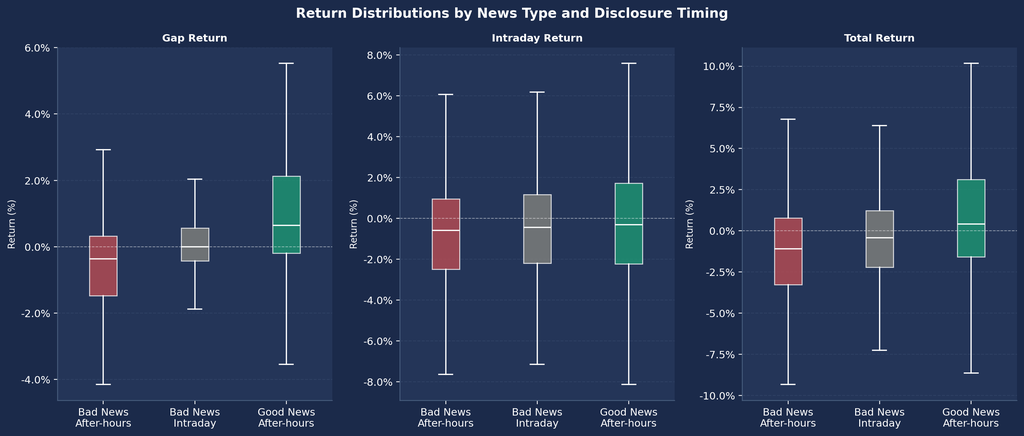

```python
# ============================================================
# Cell 11 - Visualization 2: Return Distribution Boxplots
# ============================================================

fig, axes = plt.subplots(
    1,
    3,
    figsize=(14, 6)
)

fig.patch.set_facecolor(BG_COLOR)

fig.suptitle(
    "Return Distributions by News Type and Disclosure Timing",
    fontsize=13,
    fontweight="bold",
    color="white"
)


# ------------------------------------------------------------
# Return measures
# ------------------------------------------------------------

titles = [
    "Gap Return",
    "Intraday Return",
    "Total Return"
]

cols = [
    "gap_return",
    "intra_return",
    "total_return"
]


# ------------------------------------------------------------
# Define comparison groups
# ------------------------------------------------------------

mask_bad_after = (
    (intra_df["news"] == "Bad News")
    & (intra_df["timing"] == "After-hours")
)

mask_bad_during = (
    (intra_df["news"] == "Bad News")
    & (intra_df["timing"] == "Intraday")
)

mask_good_after = (
    (intra_df["news"] == "Good News")
    & (intra_df["timing"] == "After-hours")
)


# ------------------------------------------------------------
# Create boxplots
# ------------------------------------------------------------

for ax, title, col in zip(axes, titles, cols):

    ax.set_facecolor("#243558")

    plot_data = [
        intra_df.loc[mask_bad_after, col] * 100,
        intra_df.loc[mask_bad_during, col] * 100,
        intra_df.loc[mask_good_after, col] * 100,
    ]

    # Use tick_labels for recent Matplotlib versions
    box = ax.boxplot(
        plot_data,
        tick_labels=[
            "Bad News\nAfter-hours",
            "Bad News\nIntraday",
            "Good News\nAfter-hours"
        ],
        patch_artist=True,
        showfliers=False
    )

    for patch, color in zip(
        box["boxes"],
        ["#C44E52", "#888780", "#1D9E75"]
    ):
        patch.set_facecolor(color)
        patch.set_alpha(0.75)
        patch.set_edgecolor("white")

    for element in ["whiskers", "caps", "medians"]:
        for item in box[element]:
            item.set_color("white")
            item.set_linewidth(1.2)

    ax.axhline(
        0,
        color="white",
        linewidth=0.7,
        alpha=0.5,
        linestyle="--"
    )

    ax.set_title(
        title,
        fontsize=10,
        fontweight="bold"
    )

    ax.set_ylabel(
        "Return (%)",
        fontsize=9
    )

    ax.yaxis.set_major_formatter(
        mtick.PercentFormatter()
    )

    ax.spines[
        ["top", "right"]
    ].set_visible(False)

    ax.spines[
        ["left", "bottom"]
    ].set_color("#4A6080")

    ax.grid(
        axis="y",
        linestyle="--",
        alpha=0.3,
        color="#4A6080"
    )


# ------------------------------------------------------------
# Save figure
# ------------------------------------------------------------

plt.tight_layout()

plt.savefig(
    OUTPUT_DIR / "11_2_return_boxplot.png",
    dpi=150,
    bbox_inches="tight",
    facecolor=BG_COLOR
)

plt.show()
```

## 17.7 Distributional Characteristics

The boxplot analysis reveals distinct distributional patterns for bad-news after-hours disclosures:

- The distribution of gap returns is shifted toward negative values.
- Intraday returns also show additional downward adjustment.
- Total returns exhibit the most negative distribution among the three comparison groups.

In particular, the total return distribution for bad-news after-hours disclosures shows substantial downside dispersion, indicating that some firms experience relatively large negative price movements.

By contrast, good-news after-hours disclosures exhibit a substantial positive opening gap but little additional upward adjustment during the subsequent trading session.

Taken together, these distributional patterns are consistent with an asymmetric price-adjustment process. For good-news after-hours disclosures, a substantial share of the positive reaction is concentrated at the market opening, whereas bad-news after-hours disclosures are associated with negative adjustment both at the opening and during the subsequent trading session.

## 17.8 Overall Interpretation

Overall, bad-news after-hours disclosures are associated not only with a negative opening price gap but also with additional negative price adjustment during the subsequent trading session.

The mean return decomposition shows a **-0.548% opening gap** followed by an additional **-0.726% intraday return**, resulting in a **-1.268% total return**. Moreover, the intraday return following bad-news after-hours disclosures is significantly more negative than that following bad-news intraday disclosures (**-0.726% vs. -0.499%, p = 0.0407**).

These findings indicate that the negative price reaction associated with bad-news after-hours disclosures is not concentrated entirely at the next market opening. Instead, additional downward adjustment continues during the trading session.

By contrast, good-news after-hours disclosures exhibit a substantial positive opening gap (**+1.121%**) followed by a small negative intraday return (**-0.101%**), suggesting that a larger share of the positive price adjustment is concentrated at the market opening.

Overall, the results reveal an asymmetric pattern in the timing of price adjustment following after-hours disclosures. Bad news is associated with negative adjustment both at the opening and during subsequent trading, whereas the positive reaction to good news is concentrated more heavily in the opening gap.

These findings provide evidence that bad-news after-hours disclosures are associated with continued downside price adjustment after the market opens. However, the analysis does not establish whether this pattern is caused by insufficient overnight information processing, differences in investor information access, or other market mechanisms.

# 18 Firms with Repeated After-Hours Disclosures

```python
# ============================================================
# Cell 1 - Environment Setup
# ============================================================

import sys
from pathlib import Path

import numpy as np
import pandas as pd
import matplotlib.pyplot as plt
import matplotlib.ticker as mtick
import matplotlib
from matplotlib import rcParams
from scipy import stats


# ------------------------------------------------------------
# Output directory
# ------------------------------------------------------------

OUTPUT_DIR = Path().resolve() / "outputs"
OUTPUT_DIR.mkdir(parents=True, exist_ok=True)


# ------------------------------------------------------------
# Matplotlib font settings
# ------------------------------------------------------------

matplotlib.rcParams["font.family"] = "DejaVu Sans"
matplotlib.rcParams["axes.unicode_minus"] = False


# ------------------------------------------------------------
# Global visualization settings
# ------------------------------------------------------------

rcParams.update({
    "figure.facecolor": "#1B2A4A",
    "axes.facecolor": "#243558",
    "axes.edgecolor": "#4A6080",
    "axes.labelcolor": "#FFFFFF",
    "axes.titlecolor": "#FFFFFF",
    "xtick.color": "#FFFFFF",
    "ytick.color": "#FFFFFF",
    "text.color": "#FFFFFF",
    "grid.color": "#4A6080",
    "grid.linestyle": "--",
    "grid.alpha": 0.5,
    "font.size": 10,
    "axes.titlesize": 12,
    "axes.titleweight": "bold",
    "axes.labelsize": 10,
    "legend.framealpha": 0.6,
    "legend.edgecolor": "#4A6080",
    "legend.facecolor": "#1B2A4A",
})


# ------------------------------------------------------------
# Color palette
# ------------------------------------------------------------

BG_COLOR = "#1B2A4A"

C_GOOD = "#1D9E75"
C_BAD = "#C44E52"
```

```python
# ============================================================
# Cell 2 - Data Loading
# ============================================================

DATA_DIR = resolve_data_dir()

raw_fin = pd.read_csv(
    DATA_DIR / "dart_earnings_financials_2019_2026.csv",
    dtype=str
)

raw_ctrl = pd.read_csv(
    DATA_DIR / "dart_financial_controls_2019_2025.csv"
)

raw_comp = pd.read_csv(
    DATA_DIR / "company_krx_fdr_controls_2019_2026.csv"
)
```

```python
# ============================================================
# Cell 3 - Create df_hb
# ============================================================

# ------------------------------------------------------------
# Filter out non-target reports
# ------------------------------------------------------------

remove = raw_fin["report_nm"].str.contains(
    "전망|기재정정|첨부정정|첨부추가|월별|monthly",
    na=False,
    regex=True
)

fin = raw_fin[~remove].copy()

fin["year"] = fin["rcept_dt"].str[:4].astype(int)
fin = fin[fin["year"] <= 2025].copy()


# ------------------------------------------------------------
# Identify consolidated financial statements
# ------------------------------------------------------------

# "연결" is retained because it is a literal string
# contained in Korean DART report-name strings.
fin["is_consolidated"] = fin["report_nm"].str.contains(
    "연결",
    na=False
)

fin = fin.sort_values(
    ["stock_code", "rcept_dt", "is_consolidated", "rcept_no"],
    ascending=[True, True, False, True]
)

fin = fin.drop_duplicates(
    subset=["stock_code", "rcept_dt"],
    keep="first"
)


# ------------------------------------------------------------
# Classify disclosure timing
# ------------------------------------------------------------

t = fin["rcept_time"].str.split(":", expand=True)

fin["_h"] = pd.to_numeric(t[0], errors="coerce")
fin["_m"] = pd.to_numeric(t[1], errors="coerce")

fin["timing"] = "Intraday"

fin.loc[
    fin["_h"] < 9,
    "timing"
] = "Pre-market"

fin.loc[
    (fin["_h"] > 15)
    | ((fin["_h"] == 15) & (fin["_m"] > 30)),
    "timing"
] = "After-hours"

fin.loc[
    fin["_h"].isna(),
    "timing"
] = None

fin.drop(
    columns=["_h", "_m"],
    inplace=True
)


# ------------------------------------------------------------
# Create date and weekday variables
# ------------------------------------------------------------

fin["rcept_dt_dt"] = pd.to_datetime(
    fin["rcept_dt"],
    format="%Y%m%d"
)

fin["weekday"] = fin["rcept_dt_dt"].dt.dayofweek


# ------------------------------------------------------------
# Calculate changes in operating income
# ------------------------------------------------------------

fin["oi_won"] = pd.to_numeric(
    fin["operating_income_won"],
    errors="coerce"
)

fin = fin.sort_values(
    ["stock_code", "rcept_dt_dt"]
)

fin["prev_oi"] = (
    fin.groupby("stock_code")["oi_won"]
    .shift(1)
)

fin["oi_chg_pct"] = np.where(
    fin["prev_oi"].notna()
    & (fin["prev_oi"] != 0),
    (fin["oi_won"] - fin["prev_oi"])
    / fin["prev_oi"].abs(),
    np.nan
)


# ------------------------------------------------------------
# Classify news direction
# ------------------------------------------------------------

fin["news"] = np.select(
    [
        fin["oi_chg_pct"] > 0.10,
        fin["oi_chg_pct"] < -0.10,
        fin["oi_chg_pct"].between(
            -0.10,
            0.10,
            inclusive="both"
        )
    ],
    [
        "Good News",
        "Bad News",
        "Neutral"
    ],
    default="Missing"
)


# ------------------------------------------------------------
# Construct the analysis sample
# ------------------------------------------------------------

df = fin.copy()

df_hb = df[
    df["news"].isin(["Good News", "Bad News"])
    & df["timing"].notna()
].copy()


# ------------------------------------------------------------
# Sample summary
# ------------------------------------------------------------


print(
    f"Good News: {df['news'].eq('Good News').sum():,}  "
    f"Bad News: {df['news'].eq('Bad News').sum():,}"
)
```

```
Good News: 4,534  Bad News: 4,030
```

## 18.1 Objective

This section examines whether firms exhibit persistent patterns in their choice of after-hours disclosure timing.

In particular, the analysis investigates whether some firms repeatedly disclose bad news after market hours, thereby assessing whether after-hours disclosure represents a recurring firm-level pattern rather than an isolated timing choice.

To evaluate this pattern, two firm-level measures are calculated:

- **After-Hours Disclosure Ratio (After Ratio):** the proportion of a firm’s total disclosures released after market hours.
- **Bad-News After-Hours Disclosure Ratio (Bad After Ratio):** the proportion of a firm’s bad-news disclosures released after market hours.

These measures are used to identify whether systematic differences in disclosure-timing behavior exist across firms.

```python
# ============================================================
# Cell 4 - Calculate Firm-Level After-Hours Disclosure Ratios
# ============================================================

# ------------------------------------------------------------
# Overall after-hours disclosure ratio by firm
# ------------------------------------------------------------

corp_all = (
    df_hb
    .groupby("stock_code")
    .agg(
        corp_name=("corp_name", "first"),
        total_cnt=("timing", "count"),
        after_cnt=("timing", lambda x: (x == "After-hours").sum()),
    )
    .reset_index()
)

corp_all["after_ratio"] = (
    corp_all["after_cnt"] / corp_all["total_cnt"]
)


# ------------------------------------------------------------
# Bad-news after-hours disclosure ratio by firm
# ------------------------------------------------------------

corp_bad = (
    df_hb[df_hb["news"] == "Bad News"]
    .groupby("stock_code")
    .agg(
        bad_total=("timing", "count"),
        bad_after=("timing", lambda x: (x == "After-hours").sum()),
    )
    .reset_index()
)

corp_bad["bad_after_ratio"] = (
    corp_bad["bad_after"] / corp_bad["bad_total"]
)


# ------------------------------------------------------------
# Merge firm-level measures
# ------------------------------------------------------------

corp_df = corp_all.merge(
    corp_bad,
    on="stock_code",
    how="left"
)

# Retain firms with at least four disclosures
corp_df = corp_df[
    corp_df["total_cnt"] >= 4
].copy()


# ------------------------------------------------------------
# Summary statistics
# ------------------------------------------------------------

print(f"Number of firms analyzed: {len(corp_df):,}")

print("\n=== Summary Statistics for After-Hours Disclosure Ratios ===")

print(
    corp_df[
        ["after_ratio", "bad_after_ratio"]
    ]
    .describe()
    .round(3)
)
```

```
Number of firms analyzed: 530

=== Summary Statistics for After-Hours Disclosure Ratios ===
       after_ratio  bad_after_ratio
count      530.000          527.000
mean         0.418            0.463
std          0.333            0.361
min          0.000            0.000
25%          0.100            0.125
50%          0.380            0.455
75%          0.700            0.800
max          1.000            1.000
```

## 18.2 Descriptive Statistics

A total of **530 firms** were included in the firm-level analysis.

The distribution of firm-level after-hours disclosure ratios is summarized below.

| Statistic | Overall After-Hours Ratio | Bad-News After-Hours Ratio |
| --- | --- | --- |
| Mean | 41.8% | 46.3% |
| Median | 38.0% | 45.5% |
| 25th Percentile | 10.0% | 12.5% |
| 75th Percentile | 70.0% | 80.0% |
| Maximum | 100.0% | 100.0% |

The mean overall after-hours disclosure ratio was **41.8%**, while the corresponding ratio for bad-news disclosures was higher at **46.3%**.

Similarly, the median bad-news after-hours disclosure ratio was **45.5%**, compared with **38.0%** for all disclosures.

These descriptive results indicate that, at the firm level, after-hours disclosure is more prevalent among bad-news disclosures than among disclosures overall. The pattern is consistent with firms exhibiting a greater tendency to release negative information after market hours.

## 18.3 Distributional Characteristics

The firm-level after-hours disclosure ratios exhibit substantial cross-sectional variation.

[output not shown]

[output cut: 79 more lines]

[output not shown]

```
=== Top 20 Firms with Repeated After-Hours Bad-News Disclosures ===
```

| Rank | Stock Code | Bad-News Disclosures | Bad-News After-Hours Disclosures | Bad-News After-Hours Ratio (%) | Total Disclosures | Overall After-Hours Ratio (%) |
| --- | --- | --- | --- | --- | --- | --- |
| 1 | 069080 | 14.0 | 14.0 | 100.0 | 23 | 100.0 |
| 2 | 006220 | 13.0 | 13.0 | 100.0 | 26 | 100.0 |
| 3 | 009240 | 13.0 | 13.0 | 100.0 | 24 | 95.8 |
| 4 | 108670 | 13.0 | 13.0 | 100.0 | 26 | 100.0 |
| 5 | 298050 | 13.0 | 13.0 | 100.0 | 22 | 95.5 |
| 6 | 005430 | 11.0 | 11.0 | 100.0 | 21 | 100.0 |
| 7 | 008770 | 11.0 | 11.0 | 100.0 | 25 | 100.0 |
| 8 | 027410 | 11.0 | 11.0 | 100.0 | 24 | 83.3 |
| 9 | 039130 | 11.0 | 11.0 | 100.0 | 21 | 85.7 |
| 10 | 098460 | 11.0 | 11.0 | 100.0 | 22 | 95.5 |
| 11 | 204320 | 11.0 | 11.0 | 100.0 | 22 | 100.0 |
| 12 | 298020 | 11.0 | 11.0 | 100.0 | 22 | 100.0 |
| 13 | 006650 | 10.0 | 10.0 | 100.0 | 19 | 100.0 |
| 14 | 036030 | 10.0 | 10.0 | 100.0 | 18 | 100.0 |
| 15 | 067830 | 10.0 | 10.0 | 100.0 | 23 | 100.0 |
| 16 | 071840 | 10.0 | 10.0 | 100.0 | 27 | 81.5 |
| 17 | 092730 | 10.0 | 10.0 | 100.0 | 19 | 94.7 |
| 18 | 145720 | 10.0 | 10.0 | 100.0 | 23 | 100.0 |
| 19 | 302440 | 10.0 | 10.0 | 100.0 | 18 | 94.4 |
| 20 | 109080 | 9.0 | 9.0 | 100.0 | 22 | 100.0 |

```
=== Summary of Firms with Repeated After-Hours Disclosures ===
```

|  | Category | Number of Firms |
| --- | --- | --- |
| 0 | Firms with Bad-News After-Hours Ratio > 70% | 163 |
| 1 | Firms with Bad-News After-Hours Ratio > 50% | 225 |
| 2 | Firms with Bad-News After-Hours Ratio = 100% | 79 |

| Rank | Stock Code | Bad-News Disclosures | Bad-News After-Hours Disclosures | Bad-News After-Hours Ratio (%) | Total Disclosures | Overall After-Hours Ratio (%) |
| --- | --- | --- | --- | --- | --- | --- |
| 1 | 069080 | 14.000000 | 14.000000 | 100.0% | 23 | 100.0% |
| 2 | 006220 | 13.000000 | 13.000000 | 100.0% | 26 | 100.0% |
| 3 | 009240 | 13.000000 | 13.000000 | 100.0% | 24 | 95.8% |
| 4 | 108670 | 13.000000 | 13.000000 | 100.0% | 26 | 100.0% |
| 5 | 298050 | 13.000000 | 13.000000 | 100.0% | 22 | 95.5% |
| 6 | 005430 | 11.000000 | 11.000000 | 100.0% | 21 | 100.0% |
| 7 | 008770 | 11.000000 | 11.000000 | 100.0% | 25 | 100.0% |
| 8 | 027410 | 11.000000 | 11.000000 | 100.0% | 24 | 83.3% |
| 9 | 039130 | 11.000000 | 11.000000 | 100.0% | 21 | 85.7% |
| 10 | 098460 | 11.000000 | 11.000000 | 100.0% | 22 | 95.5% |
| 11 | 204320 | 11.000000 | 11.000000 | 100.0% | 22 | 100.0% |
| 12 | 298020 | 11.000000 | 11.000000 | 100.0% | 22 | 100.0% |
| 13 | 006650 | 10.000000 | 10.000000 | 100.0% | 19 | 100.0% |
| 14 | 036030 | 10.000000 | 10.000000 | 100.0% | 18 | 100.0% |
| 15 | 067830 | 10.000000 | 10.000000 | 100.0% | 23 | 100.0% |
| 16 | 071840 | 10.000000 | 10.000000 | 100.0% | 27 | 81.5% |
| 17 | 092730 | 10.000000 | 10.000000 | 100.0% | 19 | 94.7% |
| 18 | 145720 | 10.000000 | 10.000000 | 100.0% | 23 | 100.0% |
| 19 | 302440 | 10.000000 | 10.000000 | 100.0% | 18 | 94.4% |
| 20 | 109080 | 9.000000 | 9.000000 | 100.0% | 22 | 100.0% |

```
Number of firms with at least 5 bad-news disclosures: 388

=== Summary Statistics for the Incremental Gap ===
count    388.000
mean       0.040
std        0.107
min       -0.417
25%       -0.004
50%        0.015
75%        0.093
max        0.467
Name: incremental_gap, dtype: float64

=== Top 20 Firms by Positive Incremental Gap ===
```

| Rank | Firm Name | Stock Code | Overall After-Hours Ratio | Bad-News After-Hours Ratio | Incremental Gap (Bad News - Overall) | Total Disclosures | Bad-News Disclosures |
| --- | --- | --- | --- | --- | --- | --- | --- |
| 1 | 가온그룹 | 078890 | 33.3% | 80.0% | +46.7% | 12 | 5.000000 |
| 2 | 에이치시티 | 072990 | 38.5% | 83.3% | +44.9% | 13 | 6.000000 |
| 3 | 키다리스튜디오 | 020120 | 61.5% | 100.0% | +38.5% | 13 | 5.000000 |
| 4 | 한미반도체 | 042700 | 30.0% | 66.7% | +36.7% | 20 | 9.000000 |
| 5 | 종근당 | 185750 | 35.3% | 71.4% | +36.1% | 17 | 7.000000 |
| 6 | 아바코 | 083930 | 48.0% | 83.3% | +35.3% | 25 | 12.000000 |
| 7 | 코스맥스비티아이 | 044820 | 66.7% | 100.0% | +33.3% | 12 | 5.000000 |
| 8 | 코스맥스 | 192820 | 50.0% | 83.3% | +33.3% | 14 | 6.000000 |
| 9 | 원익QnC | 074600 | 53.3% | 85.7% | +32.4% | 15 | 7.000000 |
| 10 | SG세계물산 | 004060 | 47.6% | 77.8% | +30.2% | 21 | 9.000000 |
| 11 | 종근당바이오 | 063160 | 60.0% | 90.0% | +30.0% | 20 | 10.000000 |
| 12 | 휴비츠 | 065510 | 42.9% | 71.4% | +28.6% | 14 | 7.000000 |
| 13 | 미투온 | 201490 | 54.5% | 81.8% | +27.3% | 22 | 11.000000 |
| 14 | 코나아이 | 052400 | 56.2% | 83.3% | +27.1% | 16 | 6.000000 |
| 15 | 대웅제약 | 069620 | 44.4% | 71.4% | +27.0% | 18 | 7.000000 |
| 16 | JW중외제약 | 001060 | 33.3% | 60.0% | +26.7% | 15 | 5.000000 |
| 17 | 키네마스터 | 139670 | 54.5% | 80.0% | +25.5% | 11 | 5.000000 |
| 18 | 에스제이그룹 | 306040 | 55.6% | 80.0% | +24.4% | 9 | 5.000000 |
| 19 | 셀트리온 | 068270 | 76.2% | 100.0% | +23.8% | 21 | 7.000000 |
| 20 | LG헬로비전 | 037560 | 31.8% | 54.5% | +22.7% | 22 | 11.000000 |

```
=== Number of Firms by Incremental-Gap Threshold ===
```

|  | Category | Number of Firms |
| --- | --- | --- |
| 0 | Gap > 0 | 204 |
| 1 | Gap > 10 percentage points | 86 |
| 2 | Gap > 20 percentage points | 28 |
| 3 | Gap > 30 percentage points | 11 |
| 4 | Gap > 50 percentage points | 0 |
| 5 | Gap = 0 | 86 |
| 6 | Gap < 0 | 98 |

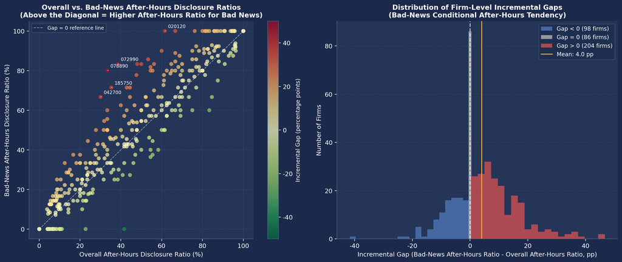

```
=== Summary ===
Total firms analyzed: 388
Gap > 0 (higher after-hours ratio for bad news): 204 firms (52.6%)
Gap = 0 (no difference): 86 firms (22.2%)
Gap < 0 (lower after-hours ratio for bad news): 98 firms (25.3%)
Mean incremental gap: 3.98 pp
Median incremental gap: 1.49 pp
```

```python
# ============================================================
# Cell X - Conditional After-Hours Disclosure Tendency for Bad News
# (Based on bad_after_ratio - after_ratio)
# ============================================================


# ------------------------------------------------------------
# Calculate the incremental gap
# ------------------------------------------------------------

# Retain firms for which both bad_after_ratio
# and after_ratio are available
corp_gap = corp_df.dropna(
    subset=["bad_after_ratio"]
).copy()

corp_gap["incremental_gap"] = (
    corp_gap["bad_after_ratio"]
    - corp_gap["after_ratio"]
)


# ------------------------------------------------------------
# Define the analysis sample
# ------------------------------------------------------------

# Retain firms with at least 5 bad-news disclosures
# to reduce instability from very small firm-level samples
corp_gap_filtered = corp_gap[
    corp_gap["bad_total"] >= 5
].copy()

print(
    f"Number of firms with at least 5 bad-news disclosures: "
    f"{len(corp_gap_filtered):,}"
)

print("\n=== Summary Statistics for the Incremental Gap ===")

print(
    corp_gap_filtered["incremental_gap"]
    .describe()
    .round(3)
)


# ------------------------------------------------------------
# Firms with the largest positive incremental gaps
# ------------------------------------------------------------

# A larger positive incremental gap indicates that a firm's
# after-hours disclosure ratio is higher for bad news
# than for its disclosures overall
top_gap = (
    corp_gap_filtered[
        corp_gap_filtered["incremental_gap"] > 0
    ]
    .sort_values(
        "incremental_gap",
        ascending=False
    )
    .head(20)
    .copy()
)


# ------------------------------------------------------------
# Construct display table
# ------------------------------------------------------------

top_gap_display = top_gap[
    [
        "corp_name",
        "stock_code",
        "after_ratio",
        "bad_after_ratio",
        "incremental_gap",
        "total_cnt",
        "bad_total"
    ]
].copy()

top_gap_display.index = range(
    1,
    len(top_gap_display) + 1
)

top_gap_display.index.name = "Rank"

top_gap_display.columns = [
    "Firm Name",
    "Stock Code",
    "Overall After-Hours Ratio",
    "Bad-News After-Hours Ratio",
    "Incremental Gap (Bad News - Overall)",
    "Total Disclosures",
    "Bad-News Disclosures"
]

print(
    "\n=== Top 20 Firms by Positive Incremental Gap ==="
)

display(
    top_gap_display.style
    .format({
        "Overall After-Hours Ratio": "{:.1%}",
        "Bad-News After-Hours Ratio": "{:.1%}",
        "Incremental Gap (Bad News - Overall)": "{:+.1%}",
    })
    .background_gradient(
        subset=[
            "Incremental Gap (Bad News - Overall)"
        ],
        cmap="Reds"
    )
    .background_gradient(
        subset=[
            "Overall After-Hours Ratio"
        ],
        cmap="Blues"
    )
)


# ------------------------------------------------------------
# Number of firms by incremental-gap threshold
# ------------------------------------------------------------

gap_summary = pd.DataFrame({
    "Category": [
        "Gap > 0",
        "Gap > 10 percentage points",
        "Gap > 20 percentage points",
        "Gap > 30 percentage points",
        "Gap > 50 percentage points",
        "Gap = 0",
        "Gap < 0",
    ],
    "Number of Firms": [
        int(
            (
                corp_gap_filtered["incremental_gap"] > 0
            ).sum()
        ),
        int(
            (
                corp_gap_filtered["incremental_gap"] > 0.10
            ).sum()
        ),
        int(
            (
                corp_gap_filtered["incremental_gap"] > 0.20
            ).sum()
        ),
        int(
            (
                corp_gap_filtered["incremental_gap"] > 0.30
            ).sum()
        ),
        int(
            (
                corp_gap_filtered["incremental_gap"] > 0.50
            ).sum()
        ),
        int(
            (
                corp_gap_filtered["incremental_gap"] == 0
            ).sum()
        ),
        int(
            (
                corp_gap_filtered["incremental_gap"] < 0
            ).sum()
        ),
    ]
})

print(
    "\n=== Number of Firms by Incremental-Gap Threshold ==="
)

display(gap_summary)


# ------------------------------------------------------------
# Visualization
# ------------------------------------------------------------

fig, axes = plt.subplots(
    1,
    2,
    figsize=(14, 6)
)

fig.patch.set_facecolor(BG_COLOR)


# ============================================================
# Scatter Plot:
# Overall vs. Bad-News After-Hours Disclosure Ratios
# ============================================================

ax = axes[0]

ax.set_facecolor("#243558")

sc = ax.scatter(
    corp_gap_filtered["after_ratio"] * 100,
    corp_gap_filtered["bad_after_ratio"] * 100,
    c=corp_gap_filtered["incremental_gap"] * 100,
    cmap="RdYlGn_r",
    alpha=0.7,
    s=40,
    edgecolors="none",
    vmin=-50,
    vmax=50,
)


# Gap = 0 reference line
ax.plot(
    [0, 100],
    [0, 100],
    color="white",
    linestyle="--",
    linewidth=1,
    alpha=0.5,
    label="Gap = 0 reference line"
)


# ------------------------------------------------------------
# Label the five firms with the largest positive gaps
# using stock codes instead of Korean firm names
# ------------------------------------------------------------

for _, row in top_gap.head(5).iterrows():

    stock_label = str(row["stock_code"]).zfill(6)

    ax.annotate(
        stock_label,
        xy=(
            row["after_ratio"] * 100,
            row["bad_after_ratio"] * 100
        ),
        xytext=(5, 5),
        textcoords="offset points",
        fontsize=7.5,
        color="white",
        arrowprops=dict(
            arrowstyle="-",
            color="white",
            lw=0.5
        )
    )


# ------------------------------------------------------------
# Color bar
# ------------------------------------------------------------

cbar = fig.colorbar(
    sc,
    ax=ax
)

cbar.set_label(
    "Incremental Gap (percentage points)",
    color="white",
    fontsize=9
)

cbar.ax.yaxis.set_tick_params(
    color="white"
)

plt.setp(
    cbar.ax.yaxis.get_ticklabels(),
    color="white"
)


# ------------------------------------------------------------
# Axis labels and title
# ------------------------------------------------------------

ax.set_xlabel(
    "Overall After-Hours Disclosure Ratio (%)",
    fontsize=10
)

ax.set_ylabel(
    "Bad-News After-Hours Disclosure Ratio (%)",
    fontsize=10
)

ax.set_title(
    "Overall vs. Bad-News After-Hours Disclosure Ratios\n"
    "(Above the Diagonal = Higher After-Hours Ratio for Bad News)",
    fontsize=11,
    fontweight="bold"
)

ax.legend(
    fontsize=8
)

ax.spines[
    ["top", "right"]
].set_visible(False)

ax.spines[
    ["left", "bottom"]
].set_color("#4A6080")

ax.grid(
    linestyle="--",
    alpha=0.3,
    color="#4A6080"
)


# ============================================================
# Histogram:
# Distribution of Incremental Gaps
# ============================================================

ax2 = axes[1]

ax2.set_facecolor("#243558")

gap_vals = (
    corp_gap_filtered["incremental_gap"] * 100
)

n_pos = int(
    (gap_vals > 0).sum()
)

n_zero = int(
    (gap_vals == 0).sum()
)

n_neg = int(
    (gap_vals < 0).sum()
)


# ------------------------------------------------------------
# Negative incremental gaps
# ------------------------------------------------------------

ax2.hist(
    gap_vals[gap_vals < 0],
    bins=20,
    color="#4C72B0",
    alpha=0.85,
    label=f"Gap < 0 ({n_neg} firms)",
    edgecolor="none"
)


# ------------------------------------------------------------
# Zero incremental gaps
# ------------------------------------------------------------

ax2.hist(
    gap_vals[gap_vals == 0],
    bins=1,
    color="#AAAAAA",
    alpha=0.85,
    label=f"Gap = 0 ({n_zero} firms)",
    edgecolor="none"
)


# ------------------------------------------------------------
# Positive incremental gaps
# ------------------------------------------------------------

ax2.hist(
    gap_vals[gap_vals > 0],
    bins=20,
    color="#C44E52",
    alpha=0.85,
    label=f"Gap > 0 ({n_pos} firms)",
    edgecolor="none"
)


# ------------------------------------------------------------
# Reference lines
# ------------------------------------------------------------

ax2.axvline(
    0,
    color="white",
    linestyle="--",
    linewidth=1.5,
    alpha=0.7
)

ax2.axvline(
    gap_vals.mean(),
    color="#F5A623",
    linestyle="-",
    linewidth=1.5,
    label=f"Mean: {gap_vals.mean():.1f} pp"
)


# ------------------------------------------------------------
# Axis labels and title
# ------------------------------------------------------------

ax2.set_xlabel(
    "Incremental Gap "
    "(Bad-News After-Hours Ratio - Overall After-Hours Ratio, pp)",
    fontsize=10
)

ax2.set_ylabel(
    "Number of Firms",
    fontsize=10
)

ax2.set_title(
    "Distribution of Firm-Level Incremental Gaps\n"
    "(Bad-News Conditional After-Hours Tendency)",
    fontsize=11,
    fontweight="bold"
)

ax2.legend(
    fontsize=9
)

ax2.spines[
    ["top", "right"]
].set_visible(False)

ax2.spines[
    ["left", "bottom"]
].set_color("#4A6080")

ax2.grid(
    axis="y",
    linestyle="--",
    alpha=0.3,
    color="#4A6080"
)


# ------------------------------------------------------------
# Save figure
# ------------------------------------------------------------

plt.tight_layout()

plt.savefig(
    OUTPUT_DIR / "12_X_incremental_gap_analysis.png",
    dpi=150,
    bbox_inches="tight",
    facecolor=BG_COLOR
)

plt.show()


# ------------------------------------------------------------
# Final summary
# ------------------------------------------------------------

n_firms = len(corp_gap_filtered)

print("\n=== Summary ===")

print(
    f"Total firms analyzed: {n_firms:,}"
)

print(
    f"Gap > 0 "
    f"(higher after-hours ratio for bad news): "
    f"{n_pos:,} firms "
    f"({n_pos / n_firms * 100:.1f}%)"
)

print(
    f"Gap = 0 "
    f"(no difference): "
    f"{n_zero:,} firms "
    f"({n_zero / n_firms * 100:.1f}%)"
)

print(
    f"Gap < 0 "
    f"(lower after-hours ratio for bad news): "
    f"{n_neg:,} firms "
    f"({n_neg / n_firms * 100:.1f}%)"
)

print(
    f"Mean incremental gap: "
    f"{gap_vals.mean():.2f} pp"
)

print(
    f"Median incremental gap: "
    f"{gap_vals.median():.2f} pp"
)
```

### 18.3.1 Analysis of Bad-News Conditional After-Hours Disclosure Tendency

The difference between each firm’s overall after-hours disclosure ratio and its bad-news after-hours disclosure ratio reveals that some firms exhibit a stronger tendency to disclose after market hours specifically when releasing bad news.

To quantify this pattern, a firm-level **incremental gap** was calculated as follows:

$$\text{Incremental Gap}
=
\text{Bad-News After-Hours Ratio}
-
\text{Overall After-Hours Ratio}$$

A positive incremental gap indicates that a firm’s after-hours disclosure ratio is higher for bad-news disclosures than for its disclosures overall.

Among the **388 firms** with at least five bad-news disclosures, the mean incremental gap was **4.0 percentage points**, while the median was **1.5 percentage points**.

This suggests that, on average, firms in the sample exhibited a modestly higher propensity to release disclosures after market hours when the information was negative.

The distribution of incremental gaps was as follows:

| Category | Number of Firms |
| --- | --- |
| Gap > 0 | 204 |
| Gap = 0 | 86 |
| Gap < 0 | 98 |

Accordingly, **52.6%** of firms had a higher after-hours disclosure ratio for bad news, **22.2%** showed no difference, and **25.3%** had a lower after-hours disclosure ratio for bad news.

These results indicate substantial cross-firm heterogeneity. The bad-news conditional after-hours pattern is therefore not uniform across firms, but appears to be more pronounced among a subset of firms.

Several firms exhibited particularly large positive incremental gaps. Examples include:

- **Gaon Group:** +46.7 percentage points
- **HCT:** +44.9 percentage points
- **KidariStudio:** +38.5 percentage points
- **Hanmi Semiconductor:** +36.7 percentage points
- **Chong Kun Dang:** +36.1 percentage points

For example, Gaon Group’s overall after-hours disclosure ratio was **33.3%**, whereas its bad-news after-hours disclosure ratio increased to **80.0%**.

Similarly, Hanmi Semiconductor had an overall after-hours disclosure ratio of approximately **30.0%**, compared with **66.7%** for bad-news disclosures.

These cases are consistent with the possibility that some firms do not simply exhibit a generally high preference for after-hours disclosure, but instead show a relatively stronger after-hours tendency specifically when disclosing negative information.

The threshold analysis provides further evidence of heterogeneity:

- **86 firms** had an incremental gap greater than **10 percentage points**
- **28 firms** exceeded **20 percentage points**
- **11 firms** exceeded **30 percentage points**

At the same time, a substantial number of firms exhibited either zero or negative incremental gaps. This indicates that some firms maintained broadly similar disclosure-timing patterns regardless of news direction, while others had a lower after-hours disclosure ratio for bad news.

Taken together, the results suggest that bad-news after-hours disclosure is not a uniform market-wide behavior. Instead, the pattern appears to be concentrated more strongly among certain firms.

This finding is also consistent with the earlier logistic regression results, in which bad-news status and bad-news severity were significantly associated with a higher probability of after-hours disclosure. The incremental-gap analysis therefore provides complementary firm-level evidence that a bad-news conditional after-hours disclosure tendency may exist for a subset of firms.

## 18.4 Analysis of Firms with Repeated After-Hours Disclosures

> **Firm identifiers in the public report.** The source data contain Korean legal company names. To keep rendered result tables readable for an international audience and avoid inconsistent ad-hoc romanization, the code-generated Top-20 table displays six-digit KRX stock codes as the stable firm identifier. Selected examples discussed in the prose use established English company names where available.

The firm-level analysis reveals that some firms exhibit particularly strong patterns of repeated after-hours bad-news disclosure.

Several firms recorded:

```
Bad-News After-Hours Ratio = 100%
```

indicating that all of their bad-news disclosures observed during the analysis period were released after market hours.

Examples include:

- Webzen
- Jeju Bank
- Hanssem
- LX Hausys
- Hotel Shilla
- HL Mando
- Hyosung TNC

These firms each had approximately **9–14 bad-news disclosures**, all of which were released after market hours. Given the number of observations involved, these cases represent notable firm-level patterns of repeated after-hours disclosure rather than isolated individual events.

Some firms also exhibited extremely high after-hours disclosure ratios across their disclosures overall.

| Firm | Overall After-Hours Ratio |
| --- | --- |
| Webzen | 100.0% |
| Jeju Bank | 100.0% |
| Hotel Shilla | 100.0% |
| HL Mando | 100.0% |
| Korea Petrochemical Ind. | 100.0% |

These cases suggest that some firms may have persistent firm-level tendencies toward releasing disclosures after market hours regardless of news direction.

Other firms, however, recorded a 100% bad-news after-hours ratio despite having a comparatively lower overall after-hours disclosure ratio.

| Firm | Overall After-Hours Ratio | Bad-News After-Hours Ratio |
| --- | --- | --- |
| Lotte Hi-Mart | 81.5% | 100.0% |
| HanaTour | 85.7% | 100.0% |
| BGF | 83.3% | 100.0% |

For these firms, the concentration of bad-news disclosures after market hours is greater than their general tendency to disclose after hours.

This distinction is important because a high bad-news after-hours ratio may reflect either a firm’s general preference for after-hours disclosure or an additional tendency associated specifically with negative information. The incremental-gap analysis presented above helps distinguish between these two patterns.

## 18.5 Summary of Repeated After-Hours Disclosure Patterns

The firm-level analysis indicates that a substantial number of firms released a high proportion of their bad-news disclosures after market hours.

| Category | Number of Firms |
| --- | --- |
| Bad-News After-Hours Ratio > 50% | 225 |
| Bad-News After-Hours Ratio > 70% | 163 |
| Bad-News After-Hours Ratio = 100% | 79 |

Among the **530 firms** included in the overall firm-level analysis, **225 firms (approximately 42%)** released more than half of their bad-news disclosures after market hours.

Furthermore, **163 firms** released more than 70% of their bad-news disclosures after hours, while **79 firms** recorded a bad-news after-hours ratio of 100% during the analysis period.

These descriptive findings indicate that repeated after-hours bad-news disclosure is not confined to only a small number of firms. Instead, high after-hours ratios are observed across a substantial subset of the sample.

The presence of firms with consistently high after-hours disclosure ratios also points to substantial persistence in firm-level disclosure-timing behavior. However, a 100% bad-news after-hours ratio alone does not establish that disclosure timing reflects a deliberate strategic policy, as such ratios may also be influenced by firm-specific reporting practices, disclosure schedules, or other unobserved factors.

This result is consistent with the earlier logistic regression analysis, in which:

```
past_after_ratio
```

was a significant predictor of after-hours disclosure.

Taken together, the findings suggest that firms exhibit persistence in their disclosure-timing patterns and that, for some firms, this persistence is particularly pronounced for bad-news disclosures. Combined with the incremental-gap analysis, the results provide evidence of substantial firm-level heterogeneity: some firms exhibit a generally high tendency toward after-hours disclosure, while others show a comparatively stronger after-hours tendency specifically when releasing negative information.

```python
# ============================================================
# Cell 6 - Year-to-Year Persistence Analysis
# ============================================================


# ------------------------------------------------------------
# Create year variable
# ------------------------------------------------------------

df_hb["year"] = df_hb["rcept_dt_dt"].dt.year


# ------------------------------------------------------------
# Calculate annual bad-news after-hours ratio by firm
# ------------------------------------------------------------

corp_year = (
    df_hb[
        df_hb["news"] == "Bad News"
    ]
    .groupby(
        ["stock_code", "corp_name", "year"]
    )
    .agg(
        bad_total=(
            "timing",
            "count"
        ),
        bad_after=(
            "timing",
            lambda x: (x == "After-hours").sum()
        ),
    )
    .reset_index()
)

corp_year["bad_after_ratio"] = (
    corp_year["bad_after"]
    / corp_year["bad_total"]
)

# Retain firm-year observations with at least one bad-news disclosure
corp_year = corp_year[
    corp_year["bad_total"] >= 1
].copy()


# ------------------------------------------------------------
# Annual average bad-news after-hours disclosure ratio
# ------------------------------------------------------------

year_avg = (
    corp_year
    .groupby("year")["bad_after_ratio"]
    .agg([
        "mean",
        "median",
        "count"
    ])
    .reset_index()
)

year_avg.columns = [
    "year",
    "mean_ratio",
    "median_ratio",
    "n_firms"
]


print(
    "=== Annual Bad-News After-Hours Disclosure Ratios ==="
)

print(
    year_avg
    .round(3)
    .to_string(index=False)
)


# ------------------------------------------------------------
# Persistence of high after-hours disclosure ratios
# ------------------------------------------------------------

# Count the number of years in which each firm had
# a bad-news after-hours disclosure ratio above 50%
persistent = (
    corp_year[
        corp_year["bad_after_ratio"] > 0.5
    ]
    .groupby("stock_code")["year"]
    .count()
    .reset_index()
)

persistent.columns = [
    "stock_code",
    "years_above_50pct"
]


# ------------------------------------------------------------
# Add firm names
# ------------------------------------------------------------

persistent = persistent.merge(
    corp_df[
        ["stock_code", "corp_name"]
    ],
    on="stock_code",
    how="left"
)

persistent = persistent.sort_values(
    "years_above_50pct",
    ascending=False
)


# ------------------------------------------------------------
# Display firms with the most persistent patterns
# ------------------------------------------------------------

print(
    "\n=== Firms with the Most Years of "
    "Bad-News After-Hours Ratio > 50% ==="
)

print(
    persistent
    .head(15)
    .to_string(index=False)
)
```

```
=== Annual Bad-News After-Hours Disclosure Ratios ===
 year  mean_ratio  median_ratio  n_firms
 2019       0.492         0.500      267
 2020       0.442         0.222      342
 2021       0.442         0.333      349
 2022       0.457         0.500      388
 2023       0.467         0.500      416
 2024       0.488         0.500      405
 2025       0.478         0.500      415

=== Firms with the Most Years of Bad-News After-Hours Ratio > 50% ===
stock_code  years_above_50pct corp_name
    298000                  7      효성화학
    005430                  7      한국공항
    009240                  7        한샘
    204320                  7      HL만도
    214320                  7       이노션
    145720                  7       덴티움
    008770                  7      호텔신라
    108670                  7    LX하우시스
    006220                  7      제주은행
    071840                  7    롯데하이마트
    027410                  7       BGF
    067830                  7   세이브존I&C
    069080                  7        웹젠
    042000                  7      카페24
    039130                  7      하나투어
```

## 18.6 Year-to-Year Persistence of After-Hours Bad-News Disclosures

The annual analysis indicates that the average firm-level after-hours disclosure ratio for bad news remained relatively stable throughout the sample period.

### 18.6.1 Annual Bad-News After-Hours Disclosure Ratios

| Year | Mean Ratio | Median Ratio | Number of Firms |
| --- | --- | --- | --- |
| 2019 | 49.2% | 50.0% | 267 |
| 2020 | 44.2% | 22.2% | 342 |
| 2021 | 44.2% | 33.3% | 349 |
| 2022 | 45.7% | 50.0% | 388 |
| 2023 | 46.7% | 50.0% | 416 |
| 2024 | 48.8% | 50.0% | 405 |
| 2025 | 47.8% | 50.0% | 415 |

Across the sample period, the mean firm-level bad-news after-hours disclosure ratio remained within a relatively narrow range of approximately:

```
44%–49%
```

From 2022 onward, the median ratio remained at:

```
50%
```

This indicates that the typical firm in these annual samples released approximately half of its bad-news disclosures after market hours.

Despite changes in the number of firms represented each year, the mean ratio did not exhibit a substantial or sustained decline. The descriptive evidence therefore suggests that the prevalence of after-hours bad-news disclosure was relatively persistent over time rather than being concentrated in a single year or short period.

The persistence analysis at the firm level further shows that some firms maintained:

```
Bad-News After-Hours Ratio > 50%
```

in all seven years of the analysis period.

### 18.6.2 Firms with Bad-News After-Hours Ratios Above 50% in All Seven Years

| Firm | Number of Years |
| --- | --- |
| Hyosung Chemical | 7 |
| Korea Airport Service | 7 |
| Hanssem | 7 |
| HL Mando | 7 |
| Innocean | 7 |
| Dentium | 7 |
| Hotel Shilla | 7 |
| LX Hausys | 7 |
| Jeju Bank | 7 |
| Lotte Hi-Mart | 7 |
| BGF | 7 |
| Savezone I&C | 7 |
| Webzen | 7 |
| Cafe24 | 7 |
| HanaTour | 7 |

These firms exhibited a bad-news after-hours disclosure ratio above 50% in every year in which they were included in the annual analysis across the seven-year sample period.

The consistency of this pattern suggests that disclosure timing may exhibit substantial persistence at the firm level. For some firms, a high tendency to release bad news after market hours appears repeatedly across multiple years rather than being confined to isolated disclosure events.

However, the annual firm-level ratios should be interpreted with caution because the calculation includes firm-year observations with at least one bad-news disclosure. A firm with only a small number of bad-news disclosures in a given year can therefore exhibit an extreme annual ratio, such as 0% or 100%, based on very few observations. Accordingly, the results provide descriptive evidence of persistence but do not by themselves establish a stable or deliberate disclosure-timing strategy.

The findings are also consistent with the earlier repeated-disclosure analysis and the logistic regression results. In particular:

```
past_after_ratio
```

was a significant predictor of after-hours disclosure.

Taken together, these results suggest that firms exhibit persistence in their disclosure-timing behavior over time. For a subset of firms, high after-hours disclosure ratios for bad news recur across multiple years, providing additional firm-level evidence that historical disclosure-timing patterns are associated with subsequent timing choices.

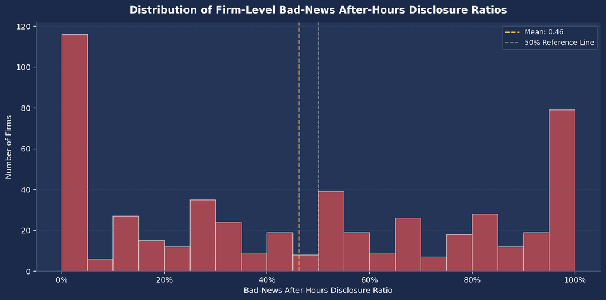

```python
# ============================================================
# Cell 7 - Visualization 1:
# Distribution of Bad-News After-Hours Disclosure Ratios
# ============================================================

fig, ax = plt.subplots(figsize=(11, 5.5))

fig.patch.set_facecolor(BG_COLOR)
ax.set_facecolor("#243558")


# ------------------------------------------------------------
# Prepare plot data
# ------------------------------------------------------------

plot_data = corp_df["bad_after_ratio"].dropna()


# ------------------------------------------------------------
# Histogram
# ------------------------------------------------------------

ax.hist(
    plot_data,
    bins=20,
    color="#C44E52",
    alpha=0.8,
    edgecolor="white",
    linewidth=0.6
)


# ------------------------------------------------------------
# Reference lines
# ------------------------------------------------------------

ax.axvline(
    plot_data.mean(),
    color="#FFB74D",
    linestyle="--",
    linewidth=1.5,
    label=f"Mean: {plot_data.mean():.2f}"
)

ax.axvline(
    0.5,
    color="white",
    linestyle="--",
    linewidth=1.2,
    alpha=0.6,
    label="50% Reference Line"
)


# ------------------------------------------------------------
# Axis labels and title
# ------------------------------------------------------------

ax.set_xlabel(
    "Bad-News After-Hours Disclosure Ratio",
    fontsize=10
)

ax.set_ylabel(
    "Number of Firms",
    fontsize=10
)

ax.set_title(
    "Distribution of Firm-Level Bad-News After-Hours Disclosure Ratios",
    fontsize=13,
    fontweight="bold",
    pad=12
)


# ------------------------------------------------------------
# Formatting
# ------------------------------------------------------------

ax.xaxis.set_major_formatter(
    mtick.PercentFormatter(xmax=1)
)

ax.spines[
    ["top", "right"]
].set_visible(False)

ax.spines[
    ["left", "bottom"]
].set_color("#4A6080")

ax.grid(
    axis="y",
    linestyle="--",
    alpha=0.3,
    color="#4A6080"
)

ax.legend(
    fontsize=9
)


# ------------------------------------------------------------
# Save figure
# ------------------------------------------------------------

plt.tight_layout()

plt.savefig(
    OUTPUT_DIR / "12_1_bad_after_ratio_dist.png",
    dpi=150,
    bbox_inches="tight",
    facecolor=BG_COLOR
)

plt.show()
```

## 18.7 Distribution of Firm-Level Bad-News After-Hours Disclosure Ratios

The distribution of firm-level bad-news after-hours disclosure ratios exhibits substantial dispersion, with relatively large concentrations of firms near both **0% and 100%**.

This pattern indicates considerable heterogeneity in disclosure-timing behavior across firms. While some firms released relatively few of their bad-news disclosures after market hours, others released most or all of their bad-news disclosures after hours.

The mean firm-level bad-news after-hours disclosure ratio was:

```
46.3%
```

while the median was approximately:

```
45%–50%
```

These statistics indicate that after-hours disclosures account for a substantial proportion of bad-news disclosures for the typical firm in the sample.

However, the distribution is widely dispersed rather than tightly concentrated around its mean. In particular, the relatively high frequencies near the boundaries of **0% and 100%** indicate that firm-level disclosure-timing patterns differ substantially across the sample.

This dispersion is also consistent with the standard deviations reported in the preceding descriptive analysis:

```
Standard deviation of overall after-hours ratio: 0.333
Standard deviation of bad-news after-hours ratio: 0.361
```

The larger dispersion of the bad-news after-hours ratio provides further descriptive evidence of substantial cross-firm heterogeneity in disclosure timing.

The concentration of observations near 100% is also consistent with the preceding analysis identifying firms that repeatedly released bad-news disclosures after market hours. However, these extreme ratios should be interpreted cautiously because firm-level ratios can be affected by the number of bad-news disclosures observed for each firm. A 100% ratio alone therefore does not establish a deliberate or persistent disclosure strategy.

Taken together with the repeated-disclosure and year-to-year persistence analyses, the distribution suggests that after-hours disclosure behavior varies substantially across firms. Some firms exhibit consistently high after-hours disclosure ratios, whereas others rarely use after-hours disclosure.

This pattern is also consistent with the earlier logistic regression results, in which:

```
past_after_ratio
```

was a significant predictor of after-hours disclosure.

Overall, the results suggest that historical firm-level disclosure-timing patterns are associated with subsequent timing choices. The distributional evidence therefore complements the regression and persistence analyses by demonstrating substantial heterogeneity in firms’ use of after-hours disclosure, particularly for bad-news announcements.

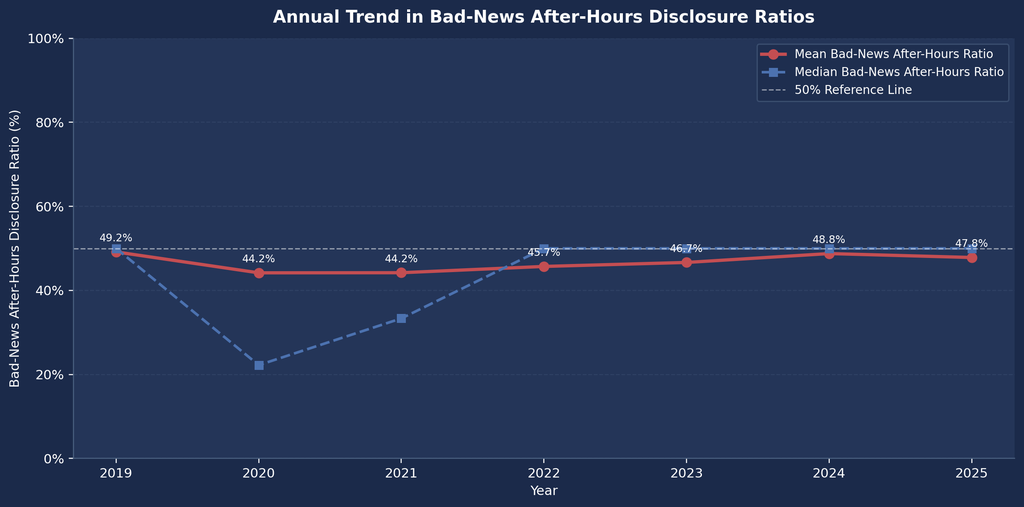

```python
# ============================================================
# Cell 8 - Visualization 2:
# Annual Trend in Bad-News After-Hours Disclosure Ratios
# ============================================================

fig, ax = plt.subplots(figsize=(11, 5.5))

fig.patch.set_facecolor(BG_COLOR)
ax.set_facecolor("#243558")


# ------------------------------------------------------------
# Plot annual mean and median ratios
# ------------------------------------------------------------

ax.plot(
    year_avg["year"],
    year_avg["mean_ratio"] * 100,
    color="#C44E52",
    linewidth=2.5,
    marker="o",
    markersize=7,
    label="Mean Bad-News After-Hours Ratio"
)

ax.plot(
    year_avg["year"],
    year_avg["median_ratio"] * 100,
    color="#4C72B0",
    linewidth=2,
    marker="s",
    markersize=6,
    linestyle="--",
    label="Median Bad-News After-Hours Ratio"
)


# ------------------------------------------------------------
# 50% reference line
# ------------------------------------------------------------

ax.axhline(
    50,
    color="white",
    linestyle="--",
    linewidth=1,
    alpha=0.5,
    label="50% Reference Line"
)


# ------------------------------------------------------------
# Add mean-value labels
# ------------------------------------------------------------

for _, row in year_avg.iterrows():

    ax.text(
        row["year"],
        row["mean_ratio"] * 100 + 2.5,
        f"{row['mean_ratio'] * 100:.1f}%",
        ha="center",
        fontsize=8,
        color="white"
    )


# ------------------------------------------------------------
# Axis labels and title
# ------------------------------------------------------------

ax.set_xlabel(
    "Year",
    fontsize=10
)

ax.set_ylabel(
    "Bad-News After-Hours Disclosure Ratio (%)",
    fontsize=10
)

ax.set_title(
    "Annual Trend in Bad-News After-Hours Disclosure Ratios",
    fontsize=13,
    fontweight="bold",
    pad=12
)


# ------------------------------------------------------------
# Fix the y-axis at 0-100% to avoid visually exaggerating
# relatively small year-to-year differences
# ------------------------------------------------------------

ax.set_ylim(0, 100)

ax.yaxis.set_major_formatter(
    mtick.PercentFormatter(xmax=100)
)

ax.set_xticks(
    year_avg["year"]
)


# ------------------------------------------------------------
# Formatting
# ------------------------------------------------------------

ax.spines[
    ["top", "right"]
].set_visible(False)

ax.spines[
    ["left", "bottom"]
].set_color("#4A6080")

ax.grid(
    axis="y",
    linestyle="--",
    alpha=0.3,
    color="#4A6080"
)

ax.legend(
    fontsize=9
)


# ------------------------------------------------------------
# Save figure
# ------------------------------------------------------------

plt.tight_layout()

plt.savefig(
    OUTPUT_DIR / "12_2_bad_after_ratio_trend.png",
    dpi=150,
    bbox_inches="tight",
    facecolor=BG_COLOR
)

plt.show()
```

## 18.8 Annual Trend in Bad-News After-Hours Disclosure Ratios

The annual analysis shows that the mean firm-level after-hours disclosure ratio for bad news remained relatively stable throughout the sample period.

### 18.8.1 Annual Bad-News After-Hours Disclosure Ratios

| Year | Mean Bad-News After-Hours Ratio | Median Bad-News After-Hours Ratio |
| --- | --- | --- |
| 2019 | 49.2% | 50.0% |
| 2020 | 44.2% | 22.2% |
| 2021 | 44.2% | 33.3% |
| 2022 | 45.7% | 50.0% |
| 2023 | 46.7% | 50.0% |
| 2024 | 48.8% | 50.0% |
| 2025 | 47.8% | 50.0% |

Across the sample period, the mean bad-news after-hours disclosure ratio remained within a relatively narrow range of approximately:

```
44%–49%
```

This indicates that after-hours disclosures consistently accounted for a substantial proportion of firms’ bad-news disclosures throughout the analysis period.

From 2022 onward, the median firm-level ratio remained at:

```
50%
```

indicating that the median firm-year observation had half of its bad-news disclosures released after market hours.

The median ratio was notably lower in **2020 (22.2%)** and **2021 (33.3%)**, while the corresponding mean remained approximately **44%**.

The divergence between the mean and median indicates an asymmetric cross-sectional distribution of firm-level ratios during these years. It is consistent with the presence of firms with relatively high after-hours ratios raising the mean above the median. However, the descriptive statistics alone do not establish which firms or how many firms were responsible for this difference.

The annual mean also shows no clear sustained upward or downward trend over the sample period. For example:

- **2019:** 49.2%
- **2024:** 48.8%
- **2025:** 47.8%

Thus, although year-to-year fluctuations are present, the magnitude of the variation is relatively modest, with the annual mean remaining between approximately 44% and 49%.

The visualization uses a **0%–100% y-axis** so that these year-to-year differences are shown in proportion to the full range of the disclosure ratio rather than visually magnified by a truncated axis.

The persistence of similar annual averages provides descriptive evidence that after-hours bad-news disclosure was not concentrated in only one particular year or short subperiod. However, the annual pattern alone cannot establish that the behavior reflects a structural or deliberate disclosure strategy, since changes in firm composition, disclosure frequency, and other time-varying factors may also affect the annual ratios.

Taken together, the annual results indicate that the prevalence of after-hours bad-news disclosure remained relatively stable over the 2019–2025 period.

This finding is consistent with the preceding firm-level persistence analysis and the earlier logistic regression results, in which:

```
past_after_ratio
```

was a significant predictor of after-hours disclosure.

Overall, the evidence suggests persistence in firms’ disclosure-timing behavior over time. Combined with the firm-level analyses, the annual results provide complementary evidence that historical disclosure-timing patterns are associated with subsequent timing choices, while substantial heterogeneity remains across individual firms.

## 18.9 Overall Interpretation

Taken together, the firm-level analyses reveal substantial heterogeneity in after-hours disclosure behavior across firms.

A considerable number of firms repeatedly released bad-news disclosures after market hours, while some firms exhibited particularly high bad-news after-hours disclosure ratios throughout the analysis period. The year-to-year analysis further indicates that high after-hours disclosure tendencies persisted across multiple years for a subset of firms rather than appearing only in isolated periods.

These findings suggest that disclosure timing is associated with persistent firm-level practices rather than being determined solely by isolated disclosure events or short-term circumstances. However, the descriptive evidence alone cannot establish whether these persistent patterns reflect deliberate strategic behavior, firm-specific reporting routines, or other unobserved factors.

The analysis also provides evidence that persistence is not explained solely by firms’ general tendency to disclose after hours. In the incremental-gap analysis, more than half of the firms with at least five bad-news disclosures exhibited a higher after-hours disclosure ratio for bad news than for their disclosures overall.

For some firms, the difference was particularly pronounced, with bad-news after-hours disclosure ratios exceeding their overall after-hours ratios by approximately **30–45 percentage points**.

This pattern suggests that, for a subset of firms, the concentration of bad-news disclosures after market hours cannot be attributed entirely to a generally high propensity for after-hours disclosure. Instead, these firms exhibit an additional after-hours tendency specifically associated with negative information.

Combined with the earlier logistic regression results, particularly the strong significant association of `past_after_ratio` and the significant association of bad-news status with after-hours disclosure, the firm-level evidence points to two related patterns. Bad-news severity was positive but only marginal in the corrected Stage 1 specification (p = 0.0926) and is therefore not treated as a statistically significant determinant at the 5% level:

1. **Persistent firm-level disclosure-timing behavior:** some firms consistently exhibit relatively high after-hours disclosure tendencies over time.
2. **Bad-news conditional after-hours tendency:** for a subset of firms, the after-hours disclosure ratio is higher for bad news than for their disclosures overall.

Overall, the results provide complementary evidence that after-hours disclosure behavior is heterogeneous and persistent at the firm level, while also suggesting that negative information is associated with an additional tendency toward after-hours disclosure for some firms. These findings are consistent with the possibility of strategic timing behavior, but they should not be interpreted as establishing deliberate strategic intent without additional causal evidence.

# 19 Industry-Level Analysis

```python
import sys
from pathlib import Path
import numpy as np
import pandas as pd
import matplotlib.pyplot as plt
import matplotlib.ticker as mtick
from scipy import stats
from itertools import combinations
import matplotlib
from matplotlib import rcParams

# ── Output directory
OUTPUT_DIR = Path().resolve() / "outputs"
OUTPUT_DIR.mkdir(parents=True, exist_ok=True)

# ── Portable font setting for GitHub/Jupyter environments
matplotlib.rcParams["font.family"] = "DejaVu Sans"
matplotlib.rcParams["axes.unicode_minus"] = False

# ── Global plotting style
rcParams.update({
    "figure.facecolor" : "#1B2A4A",
    "axes.facecolor"   : "#243558",
    "axes.edgecolor"   : "#4A6080",
    "axes.labelcolor"  : "#FFFFFF",
    "axes.titlecolor"  : "#FFFFFF",
    "xtick.color"      : "#FFFFFF",
    "ytick.color"      : "#FFFFFF",
    "text.color"       : "#FFFFFF",
    "grid.color"       : "#4A6080",
    "grid.linestyle"   : "--",
    "grid.alpha"       : 0.5,
    "font.size"        : 10,
    "axes.titlesize"   : 12,
    "axes.titleweight" : "bold",
    "axes.labelsize"   : 10,
    "legend.framealpha": 0.6,
    "legend.edgecolor" : "#4A6080",
    "legend.facecolor" : "#1B2A4A",
})

# ── Common colors
C_GOOD, C_BAD = "#1D9E75", "#C44E52"
C_BEFORE, C_DURING, C_AFTER = "#4C72B0", "#888780", "#C44E52"
BG_COLOR = rcParams["figure.facecolor"]

TIMING_COLORS = {
    "Pre-market": C_BEFORE,
    "Intraday": C_DURING,
    "After-hours": C_AFTER,
}
```

Industries are classified using Korean Standard Industrial Classification (KSIC) codes obtained from the Financial Supervisory Service’s DART Company Overview API.

> **Reproducibility note.** The API-collection cell below is shown for transparency but is not executed automatically during Quarto rendering. This avoids exposing credentials and prevents a public portfolio render from depending on hundreds of live API requests. If `krx_sector_map.csv` is not available, the subsequent analysis uses a fallback classification routine.

```python
# ================================================================
# Industry Classification Using DART Company Overview API
# ================================================================

import os
import time
import requests
import pandas as pd
from pathlib import Path


# ------------------------------------------------------------
# Configuration
# ------------------------------------------------------------

DATA_DIR = resolve_data_dir()

SECTOR_MAP_PATH = DATA_DIR / "krx_sector_map.csv"

# Enter your actual DART API key here for local execution only.
# IMPORTANT: Do NOT upload the API key to a public GitHub repository.
DART_API_KEY = os.getenv("DART_API_KEY")


# ------------------------------------------------------------
# Load company data
# ------------------------------------------------------------

comp = pd.read_csv(
    DATA_DIR / "company_krx_fdr_controls_2019_2026.csv",
    dtype=str
)


# ------------------------------------------------------------
# Standardize identifiers
# ------------------------------------------------------------

comp["stock_code"] = (
    comp["stock_code"]
    .astype(str)
    .str.strip()
    .str.replace(r"\.0$", "", regex=True)
    .str.zfill(6)
)

comp["corp_code"] = (
    comp["corp_code"]
    .astype(str)
    .str.strip()
    .str.replace(r"\.0$", "", regex=True)
    .str.zfill(8)
)


print(
    f"Number of firms loaded: "
    f"{len(comp):,}"
)


# ------------------------------------------------------------
# Map the first two digits of KSIC codes
# into research-specific industry sectors
# ------------------------------------------------------------

INDUTY_MAP = {
    "10": "Consumer",
    "11": "Consumer",
    "12": "Consumer",
    "13": "Chemicals/Materials",
    "14": "Consumer",
    "15": "Consumer",
    "16": "Chemicals/Materials",
    "17": "Chemicals/Materials",
    "18": "Consumer",
    "19": "Energy",

    "20": "Chemicals/Materials",
    "21": "Biotech/Healthcare",
    "22": "Chemicals/Materials",
    "23": "Chemicals/Materials",
    "24": "Chemicals/Materials",
    "25": "Machinery/Transportation",
    "26": "IT/Electronics",
    "27": "IT/Electronics",
    "28": "Machinery/Transportation",
    "29": "Machinery/Transportation",
    "30": "Machinery/Transportation",
    "31": "Machinery/Transportation",
    "32": "IT/Electronics",
    "33": "Machinery/Transportation",

    "35": "Energy",
    "36": "Energy",
    "37": "Energy",
    "38": "Energy",
    "39": "Energy",

    "41": "Construction",
    "42": "Construction",

    "45": "Machinery/Transportation",
    "46": "Consumer",
    "47": "Consumer",

    "49": "Machinery/Transportation",
    "50": "Machinery/Transportation",
    "51": "Machinery/Transportation",
    "52": "Machinery/Transportation",

    "58": "IT/Electronics",
    "59": "Services",
    "60": "Services",
    "61": "IT/Electronics",
    "62": "IT/Electronics",
    "63": "IT/Electronics",

    "64": "Finance",
    "65": "Finance",
    "66": "Finance",

    "68": "Construction",

    "70": "Services",
    "71": "Services",
    "72": "Biotech/Healthcare",
    "73": "Services",
    "74": "Services",

    "86": "Biotech/Healthcare",
    "87": "Biotech/Healthcare",
    "88": "Biotech/Healthcare",

    "90": "Services",
    "91": "Services",
    "92": "Services",
}


# ------------------------------------------------------------
# Retrieve KSIC industry code from DART
# with automatic retry for temporary network errors
# ------------------------------------------------------------

def get_induty(
    corp_code,
    api_key,
    max_retries=5
):
    """
    Retrieve the KSIC industry code from the DART Company Overview API
    and map it to a research-specific industry sector.

    Temporary network errors are retried automatically.
    """

    url = "https://opendart.fss.or.kr/api/company.json"

    for attempt in range(
        1,
        max_retries + 1
    ):

        try:

            response = requests.get(
                url,
                params={
                    "crtfc_key": api_key,
                    "corp_code": corp_code,
                },
                timeout=15,
            )

            response.raise_for_status()

            data = response.json()


            # ------------------------------------------------
            # Successful DART API response
            # ------------------------------------------------

            if data.get("status") == "000":

                code = str(
                    data.get(
                        "induty_code",
                        ""
                    )
                ).strip()

                # API call succeeded but no KSIC code was returned
                if not code:

                    return (
                        "",
                        "Other",
                        "MISSING_INDUTY_CODE"
                    )


                sector = INDUTY_MAP.get(
                    code[:2],
                    "Other"
                )

                return (
                    code,
                    sector,
                    "000"
                )


            # ------------------------------------------------
            # Valid DART response with non-success status
            # ------------------------------------------------

            return (
                "",
                "Other",
                f"DART_STATUS_{data.get('status', 'UNKNOWN')}"
            )


        # ----------------------------------------------------
        # Temporary network errors -> retry
        # ----------------------------------------------------

        except (
            requests.exceptions.ConnectionError,
            requests.exceptions.Timeout,
            requests.exceptions.SSLError,
        ) as exc:

            if attempt < max_retries:

                wait_seconds = (
                    attempt * 2
                )

                print(
                    f"Temporary API error for corp_code "
                    f"{corp_code} "
                    f"({type(exc).__name__}). "
                    f"Retrying in "
                    f"{wait_seconds}s "
                    f"[{attempt}/{max_retries}]..."
                )
```

```python
                time.sleep(
                    wait_seconds
                )

            else:

                return (
                    "",
                    "Other",
                    (
                        "REQUEST_ERROR_AFTER_RETRIES: "
                        f"{type(exc).__name__}"
                    )
                )


        # ----------------------------------------------------
        # Other request-related errors
        # ----------------------------------------------------

        except requests.RequestException as exc:

            return (
                "",
                "Other",
                (
                    "REQUEST_ERROR: "
                    f"{type(exc).__name__}"
                )
            )


        # ----------------------------------------------------
        # Other unexpected errors
        # ----------------------------------------------------

        except Exception as exc:

            return (
                "",
                "Other",
                (
                    "ERROR: "
                    f"{type(exc).__name__}"
                )
            )


# ------------------------------------------------------------
# Retrieve industry classifications for all firms
# ------------------------------------------------------------

records = []

status_counts = {}

total_firms = len(comp)


for i, row in comp.iterrows():

    induty_code, sector, status = get_induty(
        row["corp_code"],
        DART_API_KEY,
        max_retries=5
    )


    records.append({
        "stock_code": row["stock_code"],
        "corp_code": row["corp_code"],
        "corp_name": row["corp_name"],
        "induty_code": induty_code,
        "sector": sector,
    })


    status_counts[status] = (
        status_counts.get(
            status,
            0
        )
        + 1
    )


    if (i + 1) % 50 == 0:

        print(
            f"{i + 1:,}/"
            f"{total_firms:,} "
            f"firms processed..."
        )


    # Small delay between requests
    time.sleep(0.15)


# ------------------------------------------------------------
# Create industry mapping DataFrame
# ------------------------------------------------------------

df_sector = pd.DataFrame(
    records
)


# ------------------------------------------------------------
# Diagnostics
# ------------------------------------------------------------

print(
    "\n=== DART API Status ==="
)


for status, count in sorted(
    status_counts.items(),
    key=lambda x: -x[1]
):

    print(
        f"{status}: "
        f"{count:,}"
    )


# ------------------------------------------------------------
# Check whether KSIC industry codes were retrieved
# ------------------------------------------------------------

valid_industry = (
    df_sector["induty_code"]
    .fillna("")
    .astype(str)
    .str.strip()
    .ne("")
)


retrieved_count = (
    valid_industry.sum()
)

retrieval_rate = (
    valid_industry.mean()
    * 100
)


print(
    f"\nKSIC codes retrieved: "
    f"{retrieved_count:,} / "
    f"{len(df_sector):,}"
)

print(
    f"Retrieval rate: "
    f"{retrieval_rate:.1f}%"
)


# ------------------------------------------------------------
# Display sector distribution
# ------------------------------------------------------------

print(
    "\n=== Number of Firms by Industry Sector ==="
)

print(
    df_sector["sector"]
    .value_counts(
        dropna=False
    )
)


print(
    "\n=== Sample Classification ==="
)

print(
    df_sector[
        [
            "stock_code",
            "corp_name",
            "induty_code",
            "sector",
        ]
    ]
    .head(20)
    .to_string(
        index=False
    )
)


# ------------------------------------------------------------
# Identify remaining failed API requests
# ------------------------------------------------------------

failure_mask = (
    df_sector["induty_code"]
    .fillna("")
    .astype(str)
    .str.strip()
    .eq("")
)


failed_firms = (
    df_sector[
        failure_mask
    ]
    .copy()
)


if len(failed_firms) > 0:

    print(
        "\n=== Firms with Missing KSIC Codes ==="
    )

    print(
        failed_firms[
            [
                "stock_code",
                "corp_code",
                "corp_name",
                "sector",
            ]
        ]
        .to_string(
            index=False
        )
    )


# ------------------------------------------------------------
# Check for request failures
# # MISSING_INDUTY_CODE is treated separately because the API
# request itself succeeded.
# ------------------------------------------------------------

request_failure_count = sum(
    count
    for status, count
    in status_counts.items()
    if (
        status.startswith("REQUEST_ERROR")
        or status.startswith("ERROR:")
    )
)


dart_failure_count = sum(
    count
    for status, count
    in status_counts.items()
    if status.startswith(
        "DART_STATUS_"
    )
)


missing_code_count = (
    status_counts.get(
        "MISSING_INDUTY_CODE",
        0
    )
)


print(
    "\n=== Final Retrieval Diagnostics ==="
)

print(
    f"Successful API responses: "
    f"{status_counts.get('000', 0):,}"
)

print(
    f"Missing KSIC codes in successful responses: "
    f"{missing_code_count:,}"
)

print(
    f"Request failures after retries: "
    f"{request_failure_count:,}"
)

print(
    f"DART non-success responses: "
    f"{dart_failure_count:,}"
)


# ------------------------------------------------------------
# Safety check
# # Do not overwrite the mapping file if temporary API/request
# failures remain after all retries.
# ------------------------------------------------------------

if request_failure_count > 0:

    raise RuntimeError(
        "Some DART API requests still failed after all retries. "
        "The industry mapping file was NOT overwritten. "
        "Re-run this cell when the network connection is stable."
    )


if dart_failure_count > 0:
```

```python
    raise RuntimeError(
        "DART returned one or more non-success API statuses. "
        "The industry mapping file was NOT overwritten. "
        "Review the API status codes before proceeding."
    )


# ------------------------------------------------------------
# Additional coverage check
# ------------------------------------------------------------

if valid_industry.mean() < 0.90:

    raise RuntimeError(
        "Too many KSIC industry codes are missing. "
        "The industry mapping file was NOT overwritten."
    )


# ------------------------------------------------------------
# Save industry classification data
# ------------------------------------------------------------

df_sector.to_csv(
    SECTOR_MAP_PATH,
    index=False,
    encoding="utf-8-sig"
)



print(
    f"Completed: "
    f"{len(df_sector):,} firms"
)
```

```python
# ================================================================
# CELL 1: Imports and Industry Color Palette
# ================================================================

import numpy as np
import pandas as pd
import matplotlib.pyplot as plt
import matplotlib.ticker as mtick
from scipy import stats
from scipy.stats import chi2_contingency
import statsmodels.formula.api as smf
import warnings

warnings.filterwarnings("ignore")

SECTOR_COLORS = {
    "IT/Electronics": "#4C72B0",
    "Biotech/Healthcare": "#1D9E75",
    "Finance": "#8172B3",
    "Chemicals/Materials": "#CCB974",
    "Machinery/Transportation": "#64B5CD",
    "Construction": "#C44E52",
    "Energy": "#937860",
    "Consumer": "#DA8EC0",
    "Services": "#DD8452",
    "Other": "#AAAAAA",
}
```

```python
# ================================================================
# CELL 2: Load Data
# ================================================================

DATA_DIR = resolve_data_dir()

raw_fin = pd.read_csv(
    DATA_DIR / "dart_earnings_financials_2019_2026.csv",
    dtype=str
)
raw_ctrl = pd.read_csv(
    DATA_DIR / "dart_financial_controls_2019_2025.csv"
)
raw_comp = pd.read_csv(
    DATA_DIR / "company_krx_fdr_controls_2019_2026.csv",
    dtype=str
)
raw_time = pd.read_csv(
    DATA_DIR / "dart_earnings_time_2019_2026.csv",
    dtype=str
)
raw_price = pd.read_csv(
    DATA_DIR / "stock_price_2018_2026.csv",
    dtype={"stock_code": str}
)

print(f"Disclosure timing rows: {len(raw_time):,}")
print(
    f"Stock-price rows: {len(raw_price):,} | "
    f"Number of stocks: {raw_price['stock_code'].nunique():,}"
)
```

```
Disclosure timing rows: 16,218
Stock-price rows: 1,657,925 | Number of stocks: 947
```

```python
# ================================================================
# CELL 3: Stock-Price Preprocessing for gap_ret
# ================================================================

price = raw_price.copy()

price["date"] = pd.to_datetime(price["date"])
price["open"] = pd.to_numeric(price["open"], errors="coerce")
price["close"] = pd.to_numeric(price["close"], errors="coerce")

price.loc[price["open"] == 0, "open"] = np.nan
price.loc[price["close"] == 0, "close"] = np.nan

price = price.sort_values(["stock_code", "date"])

price["prev_close"] = (
    price.groupby("stock_code")["close"].shift(1)
)
price["next_open"] = (
    price.groupby("stock_code")["open"].shift(-1)
)
price["intraday_ret"] = (
    price["close"] / price["open"] - 1
)

print("Stock-price preprocessing completed.")
print(
    "Zero opening prices replaced with NaN: "
    f"{(pd.to_numeric(raw_price['open'], errors='coerce') == 0).sum():,}"
)
```

```
Stock-price preprocessing completed.
Zero opening prices replaced with NaN: 17,179
```

```python
# ================================================================
# CELL 4: Classify Disclosure Timing, Merge Prices, and Calculate gap_ret
# ================================================================

time_df = raw_time.copy()

time_df["rcept_dt"] = pd.to_datetime(
    time_df["rcept_dt"],
    format="%Y%m%d"
)

t = time_df["rcept_time"].str.split(":", expand=True)
time_df["_h"] = pd.to_numeric(t[0], errors="coerce")
time_df["_m"] = pd.to_numeric(t[1], errors="coerce")

time_df["timing"] = "Intraday"

time_df.loc[
    time_df["_h"] < 9,
    "timing"
] = "Pre-market"

time_df.loc[
    (time_df["_h"] > 15)
    | (
        (time_df["_h"] == 15)
        & (time_df["_m"] > 30)
    ),
    "timing"
] = "After-hours"

time_df.loc[
    time_df["_h"].isna(),
    "timing"
] = None

time_df.drop(
    columns=["_h", "_m"],
    inplace=True
)

time_df["weekday"] = time_df["rcept_dt"].dt.dayofweek
time_df["year"] = time_df["rcept_dt"].dt.year

merged = time_df.merge(
    price[
        [
            "date",
            "stock_code",
            "open",
            "close",
            "prev_close",
            "next_open",
            "intraday_ret",
        ]
    ],
    left_on=["rcept_dt", "stock_code"],
    right_on=["date", "stock_code"],
    how="left",
)

# Return definition by disclosure timing:
# After-hours: disclosure-day close -> next trading-day open
# Pre-market: previous trading-day close -> disclosure-day open
# Intraday: disclosure-day open -> disclosure-day close
merged["gap_ret"] = np.where(
    merged["timing"] == "After-hours",
    merged["next_open"] / merged["close"] - 1,
    np.where(
        merged["timing"] == "Pre-market",
        merged["open"] / merged["prev_close"] - 1,
        merged["intraday_ret"],
    ),
)

print("Disclosure-timing classification completed.")
print(merged["timing"].value_counts())

print(
    f"\nMissing gap_ret observations: "
    f"{merged['gap_ret'].isna().sum():,}"
)
```

```
Disclosure-timing classification completed.
timing
Intraday       8370
After-hours    6728
Pre-market     1098
Name: count, dtype: int64

Missing gap_ret observations: 97
```

```python
# ================================================================
# CELL 5: Classify Good/Bad News, Filter Disclosures, and Build df_hb
# ================================================================

fin_oi = (
    raw_fin[
        ["rcept_no", "operating_income_won"]
    ]
    .drop_duplicates("rcept_no")
    .copy()
)

fin_oi["oi_won"] = pd.to_numeric(
    fin_oi["operating_income_won"],
    errors="coerce"
)

merged = merged.merge(
    fin_oi[["rcept_no", "oi_won"]],
    on="rcept_no",
    how="left"
)

merged = merged.sort_values(
    ["stock_code", "rcept_dt"]
)

merged["prev_oi"] = (
    merged.groupby("stock_code")["oi_won"].shift(1)
)

merged["oi_chg_pct"] = np.where(
    merged["prev_oi"].notna()
    & (merged["prev_oi"] != 0),
    (
        merged["oi_won"] - merged["prev_oi"]
    )
    / merged["prev_oi"].abs(),
    np.nan,
)

merged["news"] = np.select(
    [
        merged["oi_chg_pct"] > 0.10,
        merged["oi_chg_pct"] < -0.10,
        merged["oi_chg_pct"].between(
            -0.10,
            0.10,
            inclusive="both"
        ),
    ],
    [
        "Good News",
        "Bad News",
        "Neutral",
    ],
    default="Missing",
)

# Korean DART report-name strings below are source-data literals and therefore
# intentionally remain unchanged.
remove = merged["report_nm"].str.contains(
    "전망|기재정정|첨부정정|첨부추가|월별|monthly",
    na=False,
    regex=True,
)

merged = merged[~remove].copy()
merged = merged[merged["year"] <= 2025].copy()

# "연결" is retained because it is a literal value in Korean DART report names.
merged["is_consolidated"] = (
    merged["report_nm"].str.contains(
        "연결",
        na=False
    )
)

merged = merged.sort_values(
    [
        "stock_code",
        "rcept_dt",
        "is_consolidated",
        "rcept_no",
    ],
    ascending=[True, True, False, True],
)

merged = merged.drop_duplicates(
    subset=["stock_code", "rcept_dt"],
    keep="first",
)

df = merged.copy()

df_hb = df[
    df["news"].isin(
        ["Good News", "Bad News"]
    )
    & df["timing"].notna()
].copy()

print(
    f"Good News: {df_hb['news'].eq('Good News').sum():,} | "
    f"Bad News: {df_hb['news'].eq('Bad News').sum():,}"
)
print(
    f"Missing gap_ret observations: "
    f"{df_hb['gap_ret'].isna().sum():,}"
)

print("\nMean gap_ret (%) by news type and timing:")
print(
    (
        df_hb
        .groupby(["news", "timing"])["gap_ret"]
        .mean()
        * 100
    )
    .round(3)
    .unstack()
)
```

```
Good News: 4,517 | Bad News: 4,036
Missing gap_ret observations: 15

Mean gap_ret (%) by news type and timing:
timing     After-hours  Intraday  Pre-market
news
Bad News        -0.524    -0.413       0.078
Good News        1.213     1.463       1.229
```

```python
# ================================================================
# CELL 6: Merge Industry Classification
# ================================================================

SECTOR_MAP_PATH = DATA_DIR / "krx_sector_map.csv"


def load_krx_sector(path, comp_df):
    try:
        krx = pd.read_csv(path, dtype=str)

        krx["stock_code"] = (
            krx["stock_code"]
            .astype(str)
            .str.strip()
            .str.replace(r"\.0$", "", regex=True)
            .str.zfill(6)
        )

        comp_df = comp_df.copy()
        comp_df["stock_code"] = (
            comp_df["stock_code"]
            .astype(str)
            .str.strip()
            .str.replace(r"\.0$", "", regex=True)
            .str.zfill(6)
        )

        out = comp_df.merge(
            krx[
                [
                    "stock_code",
                    "induty_code",
                    "sector",
                ]
            ],
            on="stock_code",
            how="left",
        )

        out["sector"] = (
            out["sector"]
            .fillna("Other")
        )

        coverage = (
            out["sector"]
            .ne("Other")
            .mean()
            * 100
        )

        print(
            f"Industry mapping loaded "
            f"(classification coverage: {coverage:.1f}%)."
        )
        print(out["sector"].value_counts().to_string())

        return out

    except FileNotFoundError:
        print(
            "krx_sector_map.csv was not found. "
            "Running keyword-based fallback classification."
        )
        return _fallback_keyword_sector(comp_df)


def _fallback_keyword_sector(comp_df):
    # Korean keywords are intentionally retained because corp_name values
    # originate from Korean source data.
    RULES = {
        "IT/Electronics": [
            "전자", "반도체", "디스플레이", "통신", "텔레콤",
            "소프트웨어", "IT", "인터넷", "게임", "테크", "디지털",
            "AI", "NAVER", "카카오", "넥슨", "넷마블", "크래프톤",
            "칩스", "실리콘",
        ],
        "Biotech/Healthcare": [
            "바이오", "제약", "의료", "헬스", "약품", "생명",
            "메디", "파마", "치료", "진단", "셀트리온",
            "종근당", "유한", "녹십자",
        ],
        "Finance": [
            "금융", "은행", "증권", "보험", "투자", "캐피탈",
            "저축", "카드", "신탁", "자산운용", "파이낸스",
            "리츠", "다올",
        ],
        "Chemicals/Materials": [
            "화학", "케미칼", "소재", "플라스틱", "고무", "정유",
            "석유", "섬유", "도료", "비료", "LG화학", "SK이노",
            "롯데케미", "한화솔",
        ],
        "Machinery/Transportation": [
            "자동차", "모빌리티", "운송", "물류", "항공", "해운",
            "택배", "기계", "중공업", "조선", "만도", "현대위아",
        ],
        "Construction": [
            "건설", "건축", "토건", "주택", "부동산", "E&C",
            "엔지니어링", "개발", "GS건설", "대우건설", "HDC",
        ],
        "Energy": [
            "에너지", "전력", "가스", "발전", "원자력",
            "신재생", "태양광",
        ],
        "Consumer": [
            "유통", "리테일", "마트", "백화점", "홈쇼핑", "식품",
            "음료", "제과", "유제품", "화장품", "아모레",
            "이니스프리",
        ],
        "Services": [
            "광고", "미디어", "엔터", "방송", "영화", "콘텐츠",
            "여행", "호텔", "레저", "제일기획", "이노션",
        ],
    }

    def classify(name):
        for sector, keywords in RULES.items():
            for keyword in keywords:
                if keyword.lower() in str(name).lower():
                    return sector
        return "Other"

    out = comp_df.copy()
    out["sector"] = out["corp_name"].apply(classify)
    out["krx_sector"] = out["sector"]

    print(out["sector"].value_counts().to_string())

    return out


comp_with_sector = load_krx_sector(
    SECTOR_MAP_PATH,
    raw_comp
)

# Remove a pre-existing sector column, if any, before a fresh merge.
df_hb = df_hb.drop(
    columns=["sector"],
    errors="ignore"
)

df_hb["stock_code"] = (
    df_hb["stock_code"]
    .astype(str)
    .str.strip()
    .str.replace(r"\.0$", "", regex=True)
    .str.zfill(6)
)

df_hb = df_hb.merge(
    comp_with_sector[
        [
            "stock_code",
            "sector",
            "log_marcap",
        ]
    ],
    on="stock_code",
    how="left",
)

df_hb["sector"] = (
    df_hb["sector"]
    .fillna("Other")
)

print("\n=== Industry Classification Check ===")
print(
    f"Classification Coverage: "
    f"{df_hb['sector'].ne('Other').mean() * 100:.1f}%"
)
print()
print(df_hb["sector"].value_counts())
print(
    f"\nNumber of Unique Industries: "
    f"{df_hb['sector'].nunique()}"
)
```

```
Industry mapping loaded (classification coverage: 97.5%).
sector
IT/Electronics              262
Machinery/Transportation    182
Chemicals/Materials         131
Consumer                     91
Finance                      85
Biotech/Healthcare           83
Services                     55
Other                        24
Construction                 24
Energy                       10

=== Industry Classification Check ===
Classification Coverage: 97.4%

sector
IT/Electronics              2206
Chemicals/Materials         1334
Machinery/Transportation    1252
Finance                      998
Consumer                     909
Biotech/Healthcare           834
Services                     444
Construction                 253
Other                        226
Energy                        97
Name: count, dtype: int64

Number of Unique Industries: 10
```

This analysis reclassifies Korean listed firms into research-specific industry sectors using Korean Standard Industrial Classification (KSIC) codes obtained from the DART Company Overview API. It then examines whether after-hours disclosure patterns for negative earnings news differ systematically across industries.

The analysis proceeds in five stages:

1. **Comparison of After-Hours Bad-News Disclosure Rates across Industries** — chi-square tests
2. **Comparison of Market Impact across Industries** — Kruskal–Wallis test
3. **Bad-News Severity × Industry Cross-Analysis** — variation in timing patterns by severity
4. **Concentration of Firms with Repeated After-Hours Disclosures** — firm-level persistence versus broader industry patterns
5. **Downside-Risk Distribution and Integrated Risk Matrix** — combining disclosure frequency, market impact, persistence, and severity associations

Industry-classification coverage is approximately **97.5%**, and the analytical sample contains **8,553 good- and bad-news disclosures**.

```python
# ================================================================
# CELL 7: Industry-Level After-Hours Rates and Chi-Square Tests
# ================================================================

from scipy.stats import chi2_contingency

MIN_BAD = 15

total_bad_after_pct = (
    df_hb[df_hb["news"] == "Bad News"]["timing"]
    .eq("After-hours")
    .mean()
    * 100
)

summary_rows = []

for sector in df_hb["sector"].value_counts().index:
    sub = df_hb[df_hb["sector"] == sector]

    bad = sub[sub["news"] == "Bad News"]
    good = sub[sub["news"] == "Good News"]

    if len(bad) < MIN_BAD:
        continue

    bad_after_pct = (
        bad["timing"]
        .eq("After-hours")
        .mean()
        * 100
    )

    good_after_pct = (
        good["timing"]
        .eq("After-hours")
        .mean()
        * 100
        if len(good) > 0
        else np.nan
    )

    diff = (
        bad_after_pct - good_after_pct
        if len(good) > 0
        else np.nan
    )

    # Within-industry chi-square test:
    # News Type (Good/Bad) × Disclosure Timing (Pre-market/Intraday/After-hours)
    ct = pd.crosstab(
        sub["news"],
        sub["timing"]
    )

    for col in [
        "Pre-market",
        "Intraday",
        "After-hours",
    ]:
        if col not in ct.columns:
            ct[col] = 0

    ct = ct[
        [
            "Pre-market",
            "Intraday",
            "After-hours",
        ]
    ]

    try:
        chi2, p, _, _ = chi2_contingency(ct)
    except Exception:
        chi2, p = np.nan, np.nan

    sig = (
        "***" if p < 0.001
        else "**" if p < 0.01
        else "*" if p < 0.05
        else ""
    )

    summary_rows.append({
        "Sector": sector,
        "Bad-News Disclosures": len(bad),
        "Good-News Disclosures": len(good),
        "Bad-News After-Hours (%)": round(
            bad_after_pct, 1
        ),
        "Good-News After-Hours (%)": round(
            good_after_pct, 1
        ),
        "Difference (pp)": round(diff, 1),
        "Chi-Square": (
            round(chi2, 2)
            if not np.isnan(chi2)
            else np.nan
        ),
        "p-value": (
            round(p, 4)
            if not np.isnan(p)
            else np.nan
        ),
        "Significance": sig,
    })


sector_summary = pd.DataFrame(summary_rows)

from IPython.display import display

display(
    sector_summary.style
    .format({
        "Bad-News After-Hours (%)": "{:.1f}%",
        "Good-News After-Hours (%)": "{:.1f}%",
        "Difference (pp)": "{:+.1f}",
        "Chi-Square": "{:.2f}",
        "p-value": "{:.4f}",
    })
    .background_gradient(
        subset=["Bad-News After-Hours (%)"],
        cmap="Reds"
    )
    .background_gradient(
        subset=["Difference (pp)"],
        cmap="RdBu_r"
    )
    .set_caption(
        "Industry-Level After-Hours Disclosure Rates "
        "and News Type × Disclosure Timing Chi-Square Tests"
    )
)
```

Table 1: Industry-Level After-Hours Disclosure Rates and News Type × Disclosure Timing Chi-Square Tests

|  | Sector | Bad-News Disclosures | Good-News Disclosures | Bad-News After-Hours (%) | Good-News After-Hours (%) | Difference (pp) | Chi-Square | p-value | Significance |
| --- | --- | --- | --- | --- | --- | --- | --- | --- | --- |
| 0 | IT/Electronics | 1039 | 1167 | 44.5% | 35.0% | +9.4 | 20.41 | 0.0000 | *** |
| 1 | Chemicals/Materials | 637 | 697 | 44.0% | 35.7% | +8.2 | 21.79 | 0.0000 | *** |
| 2 | Machinery/Transportation | 593 | 659 | 48.2% | 32.8% | +15.5 | 31.03 | 0.0000 | *** |
| 3 | Finance | 440 | 558 | 54.1% | 46.1% | +8.0 | 7.61 | 0.0223 | * |
| 4 | Consumer | 426 | 483 | 54.9% | 46.6% | +8.3 | 6.31 | 0.0426 | * |
| 5 | Biotech/Healthcare | 396 | 438 | 48.2% | 32.6% | +15.6 | 21.20 | 0.0000 | *** |
| 6 | Services | 195 | 249 | 55.4% | 50.2% | +5.2 | 8.77 | 0.0124 | * |
| 7 | Construction | 152 | 101 | 34.2% | 27.7% | +6.5 | 3.43 | 0.1798 |  |
| 8 | Other | 112 | 114 | 50.9% | 44.7% | +6.2 | nan | nan |  |
| 9 | Energy | 46 | 51 | 17.4% | 15.7% | +1.7 | 0.15 | 0.9263 |  |

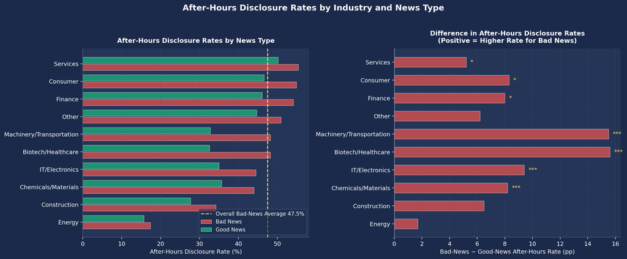

```python
# ================================================================
# CELL 8: Visualize After-Hours Disclosure Rates by Industry
# ================================================================

plot_s = (
    sector_summary
    .dropna(subset=["Difference (pp)"])
    .sort_values(
        "Bad-News After-Hours (%)",
        ascending=True
    )
)

y = np.arange(len(plot_s))

fig, axes = plt.subplots(
    1,
    2,
    figsize=(15, 6)
)

fig.patch.set_facecolor(BG_COLOR)

fig.suptitle(
    "After-Hours Disclosure Rates by Industry and News Type",
    fontsize=14,
    fontweight="bold",
    color="#FFFFFF",
    y=1.02,
)

# Panel 1: Bad-news vs good-news after-hours rates
ax = axes[0]
ax.set_facecolor("#243558")

ax.barh(
    y - 0.2,
    plot_s["Bad-News After-Hours (%)"],
    0.35,
    color="#C44E52",
    alpha=0.9,
    label="Bad News",
    edgecolor="white",
    linewidth=0.4,
)

ax.barh(
    y + 0.2,
    plot_s["Good-News After-Hours (%)"],
    0.35,
    color="#1D9E75",
    alpha=0.9,
    label="Good News",
    edgecolor="white",
    linewidth=0.4,
)

ax.axvline(
    total_bad_after_pct,
    color="#FFDD57",
    lw=1.5,
    ls="--",
    label=(
        f"Overall Bad-News Average "
        f"{total_bad_after_pct:.1f}%"
    ),
)

ax.set_yticks(y)
ax.set_yticklabels(
    plot_s["Sector"],
    fontsize=10
)
ax.set_xlabel(
    "After-Hours Disclosure Rate (%)"
)
ax.set_title(
    "After-Hours Disclosure Rates by News Type",
    fontsize=11,
    fontweight="bold",
    pad=10,
)
ax.legend(fontsize=9)
ax.grid(
    axis="x",
    ls="--",
    alpha=0.3
)
ax.spines[["top", "right"]].set_visible(False)
ax.spines[["left", "bottom"]].set_color("#4A6080")


# Panel 2: Bad-news minus good-news difference
ax = axes[1]
ax.set_facecolor("#243558")

colors = [
    "#C44E52" if d > 0
    else "#4C72B0"
    for d in plot_s["Difference (pp)"]
]

ax.barh(
    y,
    plot_s["Difference (pp)"],
    0.55,
    color=colors,
    alpha=0.9,
    edgecolor="white",
    linewidth=0.4,
)

ax.axvline(
    0,
    color="#FFFFFF",
    lw=1.0
)

ax.set_yticks(y)
ax.set_yticklabels(
    plot_s["Sector"],
    fontsize=10
)

ax.set_xlabel(
    "Bad-News − Good-News After-Hours Rate (pp)"
)

ax.set_title(
    "Difference in After-Hours Disclosure Rates\n"
    "(Positive = Higher Rate for Bad News)",
    fontsize=11,
    fontweight="bold",
    pad=10,
)

for i, (d, sig) in enumerate(
    zip(
        plot_s["Difference (pp)"],
        plot_s["Significance"]
    )
):
    if sig:
        ax.text(
            d + 0.3 if d >= 0 else d - 0.3,
            i,
            sig,
            va="center",
            ha="left" if d >= 0 else "right",
            fontsize=10,
            color="#FFDD57",
        )

ax.grid(
    axis="x",
    ls="--",
    alpha=0.3
)
ax.spines[["top", "right"]].set_visible(False)
ax.spines[["left", "bottom"]].set_color("#4A6080")

plt.tight_layout()

plt.savefig(
    OUTPUT_DIR / "13_1_sector_timing.png",
    dpi=150,
    bbox_inches="tight",
    facecolor=BG_COLOR,
)

plt.show()
```

## 19.1 After-Hours Bad-News Disclosure Rates by Industry

After-hours disclosure rates for bad and good news were compared within each industry. The chi-square tests evaluate the association between **news type and disclosure timing** within each industry.

### 19.1.1 Main Results

The overall after-hours rate for bad-news disclosures was **47.5%**, but substantial cross-industry variation was observed. Services (55.4%), Consumer (54.9%), and Finance (54.1%) recorded rates above the overall average, whereas Construction (34.2%) and Energy (17.4%) were markedly lower.

The News Type × Disclosure Timing association was statistically significant at the 5% level in **seven industries**: IT/Electronics, Chemicals/Materials, Machinery/Transportation, Finance, Consumer, Biotech/Healthcare, and Services. Four of these industries—IT/Electronics, Chemicals/Materials, Machinery/Transportation, and Biotech/Healthcare—were significant at **p < 0.001**.

Descriptively, the largest bad-news minus good-news differences in after-hours rates included Biotech/Healthcare (+15.6 pp), Machinery/Transportation (+15.5 pp), IT/Electronics (+9.4 pp), and Chemicals/Materials (+8.2 pp).

### 19.1.2 Interpretation and Limitation

The results provide evidence that disclosure timing is associated with news type in several industries. However, the chi-square tests do not establish that firms deliberately choose after-hours timing for strategic reasons. The observed differences may also reflect firm-specific reporting practices, operational schedules, or other unobserved factors.

```python
# ================================================================
# CELL 9: Industry-Level Opening Gap Returns and Kruskal-Wallis Test
# ================================================================

bad_after = df_hb[
    (df_hb["news"] == "Bad News")
    & (df_hb["timing"] == "After-hours")
].copy()

bad_after["gap_ret_pct"] = (
    bad_after["gap_ret"] * 100
)

gap_rows = []

for sector in sector_summary["Sector"]:
    sub = (
        bad_after[
            bad_after["sector"] == sector
        ]["gap_ret_pct"]
        .dropna()
    )

    if len(sub) < 5:
        continue

    gap_rows.append({
        "Sector": sector,
        "n": len(sub),
        "Mean (%)": round(
            sub.mean(), 3
        ),
        "Median (%)": round(
            sub.median(), 3
        ),
        "Std. Dev.": round(
            sub.std(), 4
        ),
        "5th Percentile (%)": round(
            sub.quantile(0.05), 3
        ),
    })

gap_summary = (
    pd.DataFrame(gap_rows)
    .sort_values("Mean (%)")
)

print(
    "=== Industry-Level Opening Gap Returns "
    "for After-Hours Bad-News Disclosures ==="
)
print(
    gap_summary.to_string(index=False)
)

groups = [
    bad_after[
        bad_after["sector"] == row["Sector"]
    ]["gap_ret_pct"]
    .dropna()
    .values
    for _, row in gap_summary.iterrows()
    if len(
        bad_after[
            bad_after["sector"] == row["Sector"]
        ]["gap_ret_pct"]
        .dropna()
    ) >= 5
]

if len(groups) >= 2:
    h_stat, p_kw = stats.kruskal(*groups)

    sig_kw = (
        "***" if p_kw < 0.001
        else "**" if p_kw < 0.01
        else "*" if p_kw < 0.05
        else "(Not Significant)"
    )

    print(
        f"\nKruskal-Wallis: "
        f"H={h_stat:.3f}, "
        f"p={p_kw:.4f} "
        f"{sig_kw}"
    )
```

```
=== Industry-Level Opening Gap Returns for After-Hours Bad-News Disclosures ===
                  Sector   n  Mean (%)  Median (%)  Std. Dev.  5th Percentile (%)
     Chemicals/Materials 278    -0.956      -0.484     2.6988              -5.400
                  Energy   8    -0.898      -0.532     1.4828              -3.264
          IT/Electronics 462    -0.743      -0.622     3.0036              -5.127
Machinery/Transportation 286    -0.628      -0.397     2.5745              -4.867
                Consumer 234    -0.502      -0.223     1.8244              -3.161
      Biotech/Healthcare 191    -0.436      -0.337     1.9656              -3.971
            Construction  52    -0.256       0.000     1.3575              -2.521
                   Other  57    -0.240       0.000     2.6859              -3.513
                 Finance 237     0.013       0.000     1.6099              -2.001
                Services 108     0.168      -0.057     3.5140              -3.057

Kruskal-Wallis: H=44.133, p=0.0000 ***
```

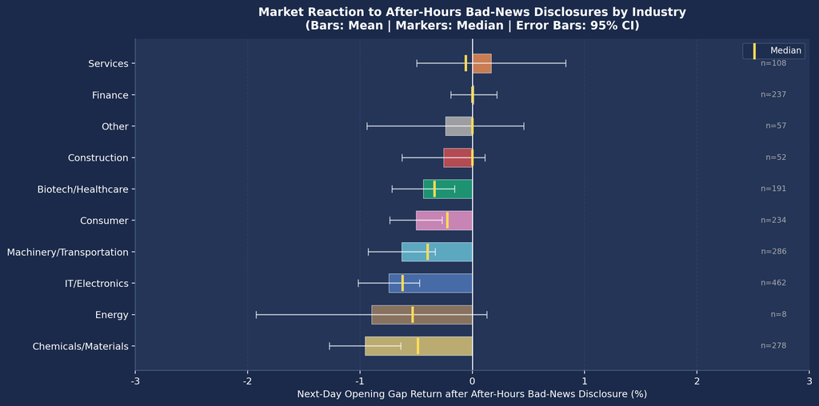

```python
# ================================================================
# CELL 10: Visualize Industry-Level Opening Gap Returns
# ================================================================

y = np.arange(len(gap_summary))

bar_colors = [
    SECTOR_COLORS.get(
        sector,
        "#AAAAAA"
    )
    for sector in gap_summary["Sector"]
]

# Approximate 95% confidence interval for the mean
gap_summary = gap_summary.copy()

gap_summary["SE"] = (
    gap_summary["Std. Dev."]
    / np.sqrt(gap_summary["n"])
)

gap_summary["CI95"] = (
    1.96 * gap_summary["SE"]
)


fig, ax = plt.subplots(
    figsize=(12, 6)
)

fig.patch.set_facecolor(BG_COLOR)
ax.set_facecolor("#243558")

bars = ax.barh(
    y,
    gap_summary["Mean (%)"],
    0.6,
    color=bar_colors,
    alpha=0.9,
    edgecolor="white",
    linewidth=0.4,
)

ax.errorbar(
    gap_summary["Mean (%)"],
    y,
    xerr=gap_summary["CI95"],
    fmt="none",
    color="white",
    capsize=4,
    lw=1.2,
    alpha=0.7,
)

ax.axvline(
    0,
    color="#FFFFFF",
    lw=1.0
)

ax.scatter(
    gap_summary["Median (%)"],
    y,
    marker="|",
    s=300,
    color="#FFDD57",
    zorder=5,
    label="Median",
    linewidths=2.5,
)

ax.set_xlim(-3, 3)

ax.set_yticks(y)
ax.set_yticklabels(
    gap_summary["Sector"],
    fontsize=10
)

ax.set_xlabel(
    "Next-Day Opening Gap Return after "
    "After-Hours Bad-News Disclosure (%)",
    fontsize=10,
)

ax.set_title(
    "Market Reaction to After-Hours Bad-News Disclosures by Industry\n"
    "(Bars: Mean | Markers: Median | Error Bars: 95% CI)",
    fontsize=12,
    fontweight="bold",
    pad=10,
)

ax.legend(fontsize=9)

for bar, n in zip(
    bars,
    gap_summary["n"]
):
    ax.text(
        2.8,
        bar.get_y()
        + bar.get_height() / 2,
        f"n={n}",
        va="center",
        ha="right",
        fontsize=8,
        color="#AAAAAA",
    )

ax.grid(
    axis="x",
    ls="--",
    alpha=0.3
)

ax.spines[["top", "right"]].set_visible(False)
ax.spines[["left", "bottom"]].set_color("#4A6080")

plt.tight_layout()

plt.savefig(
    OUTPUT_DIR / "13_2_sector_gap.png",
    dpi=150,
    bbox_inches="tight",
    facecolor=BG_COLOR,
)

plt.show()
```

## 19.2 Industry-Level Market Impact of After-Hours Bad-News Disclosures

For after-hours bad-news disclosures, the opening gap return measures the price change from the disclosure-day close to the next trading-day open. A Kruskal–Wallis test was used to assess whether the distribution of these opening gap returns differed across industries.

### 19.2.1 Main Results

The Kruskal–Wallis test indicated a statistically significant difference across industries (**H = 44.133, p < 0.001**).

The most negative average opening gap returns were observed in:

- **Chemicals/Materials: −0.956%**
- **IT/Electronics: −0.743%**
- **Machinery/Transportation: −0.628%**

By contrast, Finance (+0.013%) and Services (+0.168%) showed comparatively limited average opening-gap reactions despite relatively high after-hours disclosure rates.

These results show that the **frequency of after-hours bad-news disclosures and the magnitude of the overnight market reaction need not move together**, motivating a two-dimensional comparison of disclosure frequency and market impact.

Across many industries, the mean opening gap return was lower than the median, which is consistent with negative tail observations affecting the average. Mean–median differences alone, however, are not a formal test of distributional skewness.

### 19.2.2 Statistical Limitation

The Kruskal–Wallis test establishes that at least some industry distributions differ in rank. It does not identify which specific pairs of industries differ; pairwise post-hoc tests would be required for that purpose.

```
Chi-Square Tests: Bad-News Severity × Disclosure Timing by Industry
------------------------------------------------------------------------
Consumer                     chi2=12.60 p=0.0134 *
Machinery/Transportation     chi2=25.23 p=0.0000 ***
IT/Electronics               chi2=7.82 p=0.0982 (Not Significant)
Chemicals/Materials          chi2=20.26 p=0.0004 ***
Finance                      chi2=23.28 p=0.0001 ***
Biotech/Healthcare           chi2=10.28 p=0.0360 *
Services                     chi2=1.04 p=0.9033 (Not Significant)
```

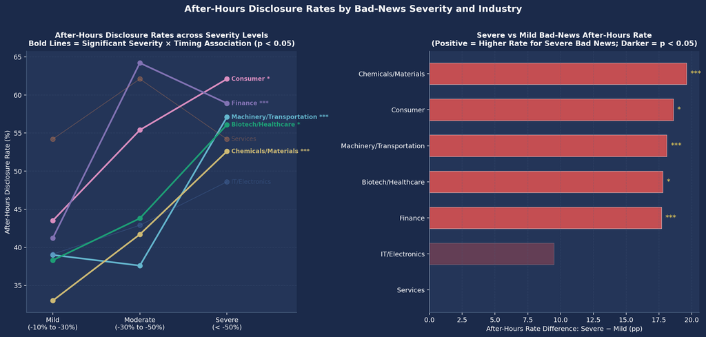

```python
# ================================================================
# CELL 11: Bad-News Severity × Industry Analysis
# ================================================================

from scipy.stats import chi2_contingency

# Define bad-news severity intervals
bins = [
    -np.inf,
    -0.50,
    -0.30,
    -0.10,
]

labels = [
    "Severe (< -50%)",
    "Moderate (-30% to -50%)",
    "Mild (-10% to -30%)",
]

bad_df = df_hb[
    df_hb["news"] == "Bad News"
].copy()

bad_df["severity"] = pd.cut(
    bad_df["oi_chg_pct"],
    bins=bins,
    labels=labels,
)

bad_df = bad_df.dropna(
    subset=["severity"]
)

focus = [
    "Consumer",
    "Machinery/Transportation",
    "IT/Electronics",
    "Chemicals/Materials",
    "Finance",
    "Biotech/Healthcare",
    "Services",
]


sev_rows = []

for sector in focus:
    sub = bad_df[
        bad_df["sector"] == sector
    ]

    if len(sub) < 15:
        continue

    for severity in labels:
        grp = sub[
            sub["severity"] == severity
        ]

        if len(grp) < 5:
            continue

        after_pct = (
            grp["timing"]
            .eq("After-hours")
            .mean()
            * 100
        )

        sev_rows.append({
            "Sector": sector,
            "Severity": severity,
            "n": len(grp),
            "After-Hours (%)": round(
                after_pct, 1
            ),
        })


sev_df = pd.DataFrame(sev_rows)


# ------------------------------------------------------------
# Chi-square tests by industry:
# Bad-News Severity × Disclosure Timing
# ------------------------------------------------------------

print(
    "Chi-Square Tests: "
    "Bad-News Severity × Disclosure Timing by Industry"
)
print("-" * 72)

chi2_pvals = {}

for sector in focus:
    sub = (
        bad_df[
            bad_df["sector"] == sector
        ]
        .dropna(
            subset=["severity"]
        )
    )

    if len(sub) < 15:
        continue

    ct = pd.crosstab(
        sub["severity"],
        sub["timing"]
    )

    for col in [
        "Pre-market",
        "Intraday",
        "After-hours",
    ]:
        if col not in ct.columns:
            ct[col] = 0

    ct = ct[
        [
            "Pre-market",
            "Intraday",
            "After-hours",
        ]
    ]

    try:
        chi2, p, _, _ = chi2_contingency(ct)

        chi2_pvals[sector] = p

        sig = (
            "***" if p < 0.001
            else "**" if p < 0.01
            else "*" if p < 0.05
            else "(Not Significant)"
        )

        print(
            f"{sector:28s} "
            f"chi2={chi2:.2f} "
            f"p={p:.4f} "
            f"{sig}"
        )

    except Exception:
        chi2_pvals[sector] = np.nan


# ------------------------------------------------------------
# Severity profiles
# ------------------------------------------------------------

pivot = sev_df.pivot(
    index="Sector",
    columns="Severity",
    values="After-Hours (%)",
)

pivot = pivot.reindex(
    columns=labels
)

pivot = pivot.reindex(
    [
        sector
        for sector in focus
        if sector in pivot.index
    ]
)


fig, axes = plt.subplots(
    1,
    2,
    figsize=(15, 7)
)

fig.patch.set_facecolor(BG_COLOR)

fig.suptitle(
    "After-Hours Disclosure Rates by Bad-News Severity and Industry",
    fontsize=14,
    fontweight="bold",
    color="#FFFFFF",
    y=1.01,
)


# ------------------------------------------------------------
# Panel 1: Mild -> Moderate -> Severe
# ------------------------------------------------------------

ax = axes[0]
ax.set_facecolor("#243558")

x_pos = [0, 1, 2]

x_labels = [
    "Mild\n(-10% to -30%)",
    "Moderate\n(-30% to -50%)",
    "Severe\n(< -50%)",
]

for sector in pivot.index:
    row = pivot.loc[sector]

    vals = [
        row.get(
            "Mild (-10% to -30%)",
            np.nan
        ),
        row.get(
            "Moderate (-30% to -50%)",
            np.nan
        ),
        row.get(
            "Severe (< -50%)",
            np.nan
        ),
    ]

    color = SECTOR_COLORS.get(
        sector,
        "#AAAAAA"
    )

    p = chi2_pvals.get(
        sector,
        1.0
    )

    # Emphasize industries with a significant
    # Severity × Timing association.
    lw = 2.5 if p < 0.05 else 1.0
    alpha = 1.0 if p < 0.05 else 0.35

    ax.plot(
        x_pos,
        vals,
        marker="o",
        lw=lw,
        alpha=alpha,
        color=color,
        markersize=7,
    )

    sig = (
        "***" if p < 0.001
        else "**" if p < 0.01
        else "*" if p < 0.05
        else ""
    )

    label = (
        f"{sector} {sig}"
        if sig
        else sector
    )

    ax.text(
        2.05,
        vals[2],
        label,
        va="center",
        fontsize=9,
        color=color,
        alpha=alpha,
        fontweight=(
            "bold"
            if sig
            else "normal"
        ),
    )

ax.set_xticks(x_pos)
ax.set_xticklabels(
    x_labels,
    fontsize=10
)

ax.set_xlim(-0.3, 2.8)
ax.set_ylabel(
    "After-Hours Disclosure Rate (%)"
)

ax.set_title(
    "After-Hours Disclosure Rates across Severity Levels\n"
    "Bold Lines = Significant Severity × Timing Association (p < 0.05)",
    fontsize=11,
    fontweight="bold",
    pad=8,
)

ax.grid(
    axis="y",
    ls="--",
    alpha=0.3
)

ax.spines[["top", "right"]].set_visible(False)
ax.spines[["left", "bottom"]].set_color("#4A6080")


# ------------------------------------------------------------
# Panel 2: Severe minus Mild difference
# ------------------------------------------------------------

ax = axes[1]
ax.set_facecolor("#243558")

diff_col = (
    pivot["Severe (< -50%)"]
    - pivot["Mild (-10% to -30%)"]
)

diff_df2 = diff_col.reset_index()
diff_df2.columns = [
    "Sector",
    "Difference (pp)",
]

diff_df2["p-value"] = (
    diff_df2["Sector"]
    .map(chi2_pvals)
)

diff_df2["Significance"] = (
    diff_df2["p-value"]
    .apply(
        lambda p:
        "***" if p < 0.001
        else "**" if p < 0.01
        else "*" if p < 0.05
        else ""
    )
)

diff_df2 = diff_df2.sort_values(
    "Difference (pp)",
    ascending=True
)

colors_d = [
    "#C44E52" if value > 0
    else "#4C72B0"
    for value in diff_df2["Difference (pp)"]
]

alphas_d = [
    1.0 if p < 0.05
    else 0.4
    for p in diff_df2["p-value"]
]

y_d = np.arange(
    len(diff_df2)
)

bars = ax.barh(
    y_d,
    diff_df2["Difference (pp)"],
    0.6,
    color=colors_d,
    alpha=0.9,
    edgecolor="white",
    linewidth=0.4,
)

for bar, alpha in zip(
    bars,
    alphas_d
):
    bar.set_alpha(alpha)

ax.axvline(
    0,
    color="#FFFFFF",
    lw=1.0
)

ax.set_yticks(y_d)
ax.set_yticklabels(
    diff_df2["Sector"],
    fontsize=10
)

ax.set_xlabel(
    "After-Hours Rate Difference: Severe − Mild (pp)"
)

ax.set_title(
    "Severe vs Mild Bad-News After-Hours Rate\n"
    "(Positive = Higher Rate for Severe Bad News; "
    "Darker = p < 0.05)",
    fontsize=11,
    fontweight="bold",
    pad=8,
)

for i, (difference, sig) in enumerate(
    zip(
        diff_df2["Difference (pp)"],
        diff_df2["Significance"]
    )
):
    if sig:
        ax.text(
            difference + 0.3
            if difference > 0
            else difference - 0.3,
            i,
            sig,
            va="center",
            ha=(
                "left"
                if difference > 0
                else "right"
            ),
            fontsize=11,
            color="#FFDD57",
        )

ax.grid(
    axis="x",
    ls="--",
    alpha=0.3
)

ax.spines[["top", "right"]].set_visible(False)
ax.spines[["left", "bottom"]].set_color("#4A6080")

plt.tight_layout()

plt.savefig(
    OUTPUT_DIR / "13_3_severity_sector.png",
    dpi=150,
    bbox_inches="tight",
    facecolor=BG_COLOR,
)

plt.show()
```

## 19.3 After-Hours Disclosure Rates by Bad-News Severity and Industry

Bad-news observations were divided into three operating-income decline categories: Mild (−10% to −30%), Moderate (−30% to −50%), and Severe (below −50%). Within each industry, the chi-square test evaluates the association between **bad-news severity and disclosure timing**.

### 19.3.1 Main Results

Statistically significant Severity × Timing associations were observed in five industries:

- Consumer: **p = 0.013**
- Machinery/Transportation: **p < 0.001**
- Chemicals/Materials: **p < 0.001**
- Finance: **p < 0.001**
- Biotech/Healthcare: **p = 0.036**

Descriptively, the Severe-minus-Mild difference in after-hours rates was approximately **+18.6 pp for Consumer**, **+18.1 pp for Machinery/Transportation**, and **+19.6 pp for Chemicals/Materials**.

IT/Electronics (p = 0.098) and Services (p = 0.903) did not show statistically significant Severity × Timing associations.

### 19.3.2 Interpretation

The significant results are consistent with the possibility that disclosure timing varies with the magnitude of negative earnings information in some industries. However, the chi-square tests do not establish deliberate timing behavior or causal intent. The endpoint difference between Severe and Mild groups is also descriptive and should not be interpreted as proof of a monotonic response across all severity levels.

Table 2: Industry-Level Concentration of Firms with Repeated After-Hours Bad-News Disclosures (≥ 3 Bad-News Disclosures and ≥ 70% After-Hours Ratio)

| Sector | Number of Firms | Repeated After-Hours Firms | Repeated-Firm Share (%) | Mean Bad-News After-Hours Ratio (%) |
| --- | --- | --- | --- | --- |
| Services | 23 | 10 | 43.5% | 55.0% |
| Consumer | 45 | 19 | 42.2% | 56.3% |
| Finance | 49 | 18 | 36.7% | 52.3% |
| Biotech/Healthcare | 46 | 15 | 32.6% | 50.8% |
| IT/Electronics | 118 | 38 | 32.2% | 44.8% |
| Machinery/Transportation | 74 | 20 | 27.0% | 46.0% |
| Chemicals/Materials | 73 | 19 | 26.0% | 42.5% |

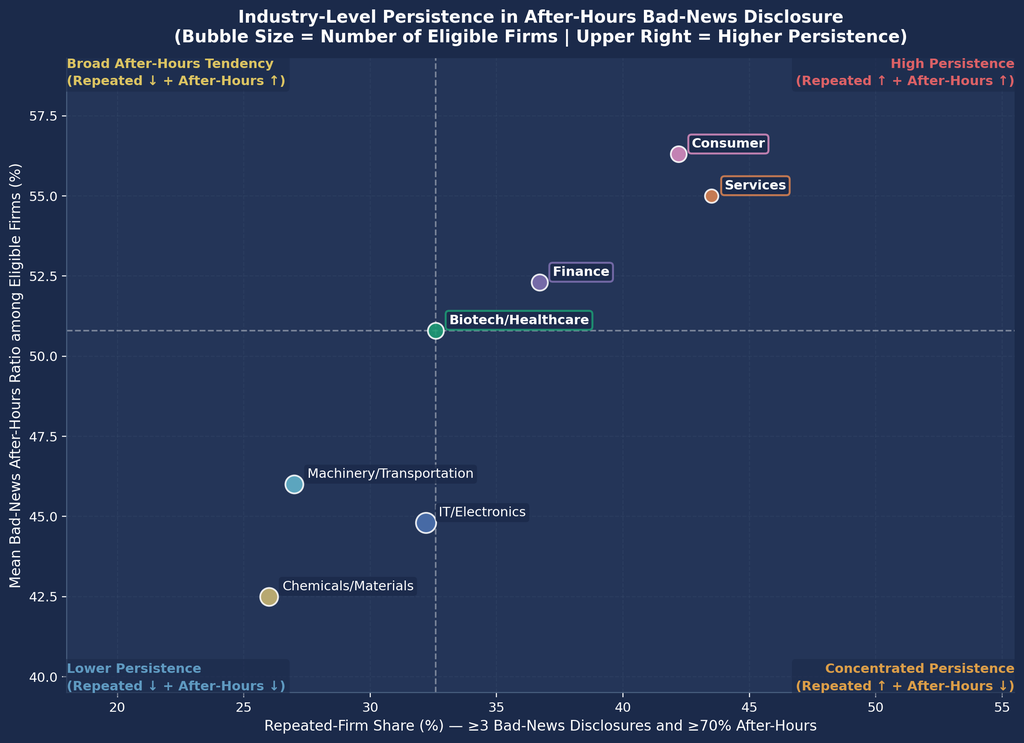

```python
# ================================================================
# CELL 12: Industry-Level Concentration of Repeated After-Hours Firms
# ================================================================

# Repeated-firm criterion:
# at least three bad-news disclosures and
# at least 70% of those disclosures released after hours.
MIN_DISCLOSURES = 3
REPEAT_THRESHOLD = 0.70

bad_df2 = df_hb[
    df_hb["news"] == "Bad News"
].copy()

repeat_rows = []

for sector in focus:
    sub = bad_df2[
        bad_df2["sector"] == sector
    ]

    corp_stats = (
        sub
        .groupby("stock_code")["timing"]
        .agg(
            total="count",
            n_after=lambda x: (
                x == "After-hours"
            ).sum(),
        )
        .reset_index()
    )

    corp_stats["after_ratio"] = (
        corp_stats["n_after"]
        / corp_stats["total"]
    )

    eligible = corp_stats[
        corp_stats["total"]
        >= MIN_DISCLOSURES
    ]

    if len(eligible) == 0:
        continue

    repeat_pct = (
        eligible["after_ratio"]
        .ge(REPEAT_THRESHOLD)
        .mean()
        * 100
    )

    repeat_rows.append({
        "Sector": sector,
        "Number of Firms": len(eligible),
        "Repeated After-Hours Firms": int(
            eligible["after_ratio"]
            .ge(REPEAT_THRESHOLD)
            .sum()
        ),
        "Repeated-Firm Share (%)": round(
            repeat_pct,
            1
        ),
        "Mean Bad-News After-Hours Ratio (%)": round(
            eligible["after_ratio"]
            .mean()
            * 100,
            1
        ),
    })


repeat_df = (
    pd.DataFrame(repeat_rows)
    .sort_values(
        "Repeated-Firm Share (%)",
        ascending=False
    )
)


from IPython.display import display

display(
    repeat_df.style
    .format({
        "Repeated-Firm Share (%)": "{:.1f}%",
        "Mean Bad-News After-Hours Ratio (%)": "{:.1f}%",
    })
    .background_gradient(
        subset=["Repeated-Firm Share (%)"],
        cmap="Reds"
    )
    .set_caption(
        "Industry-Level Concentration of Firms with Repeated "
        "After-Hours Bad-News Disclosures "
        f"(≥ {MIN_DISCLOSURES} Bad-News Disclosures and "
        f"≥ {int(REPEAT_THRESHOLD * 100)}% After-Hours Ratio)"
    )
    .hide(axis="index")
)


# ------------------------------------------------------------
# Scatter plot:
# Repeated-firm share vs mean bad-news after-hours ratio
# ------------------------------------------------------------

fig, ax = plt.subplots(
    figsize=(11, 8)
)

fig.patch.set_facecolor(BG_COLOR)
ax.set_facecolor("#243558")

x_vals = repeat_df[
    "Repeated-Firm Share (%)"
]

y_vals = repeat_df[
    "Mean Bad-News After-Hours Ratio (%)"
]

x_mid = x_vals.median()
y_mid = y_vals.median()

ax.axvline(
    x_mid,
    color="#FFFFFF",
    lw=1.2,
    ls="--",
    alpha=0.4,
)

ax.axhline(
    y_mid,
    color="#FFFFFF",
    lw=1.2,
    ls="--",
    alpha=0.4,
)

xlim = (
    x_vals.min() - 8,
    x_vals.max() + 12
)

ylim = (
    y_vals.min() - 3,
    y_vals.max() + 3
)

ax.set_xlim(xlim)
ax.set_ylim(ylim)


# Neutral quadrant labels:
# both axes describe disclosure persistence, not causal risk.
quad_cfg = [
    (
        xlim[1],
        ylim[1],
        "High Persistence\n(Repeated ↑ + After-Hours ↑)",
        "#FF6B6B",
        "right",
        "top",
    ),
    (
        xlim[0],
        ylim[1],
        "Broad After-Hours Tendency\n(Repeated ↓ + After-Hours ↑)",
        "#FFE066",
        "left",
        "top",
    ),
    (
        xlim[1],
        ylim[0],
        "Concentrated Persistence\n(Repeated ↑ + After-Hours ↓)",
        "#FFB347",
        "right",
        "bottom",
    ),
    (
        xlim[0],
        ylim[0],
        "Lower Persistence\n(Repeated ↓ + After-Hours ↓)",
        "#6BAED6",
        "left",
        "bottom",
    ),
]

for (
    qx,
    qy,
    ql,
    qc,
    ha,
    va
) in quad_cfg:
    ax.text(
        qx,
        qy,
        ql,
        color=qc,
        fontsize=10,
        fontweight="bold",
        ha=ha,
        va=va,
        alpha=0.85,
        linespacing=1.5,
        bbox=dict(
            boxstyle="round,pad=0.3",
            fc="#1B2A4A",
            ec="none",
            alpha=0.6,
        ),
    )


# Bubble size = number of eligible firms
for _, row in repeat_df.iterrows():
    sector = row["Sector"]

    x = row[
        "Repeated-Firm Share (%)"
    ]
    y = row[
        "Mean Bad-News After-Hours Ratio (%)"
    ]

    size = (
        np.sqrt(
            row["Number of Firms"]
        )
        * 22
    )

    color = SECTOR_COLORS.get(
        sector,
        "#AAAAAA"
    )

    ax.scatter(
        x,
        y,
        s=size,
        color=color,
        alpha=0.88,
        edgecolors="white",
        linewidths=1.3,
        zorder=3,
    )

    is_high = (
        (x >= x_mid)
        and (y >= y_mid)
    )

    font_weight = (
        "bold"
        if is_high
        else "normal"
    )

    outline = dict(
        boxstyle="round,pad=0.25",
        fc="#1B2A4A",
        ec=(
            color
            if is_high
            else "none"
        ),
        alpha=0.85,
        lw=(
            1.5
            if is_high
            else 0
        ),
    )

    ax.annotate(
        sector,
        (x, y),
        textcoords="offset points",
        xytext=(10, 5),
        fontsize=10,
        color="#FFFFFF",
        fontweight=font_weight,
        zorder=4,
        bbox=outline,
    )


ax.set_xlabel(
    "Repeated-Firm Share (%) — "
    "≥3 Bad-News Disclosures and ≥70% After-Hours",
    fontsize=11,
)

ax.set_ylabel(
    "Mean Bad-News After-Hours Ratio among Eligible Firms (%)",
    fontsize=11,
)

ax.set_title(
    "Industry-Level Persistence in After-Hours Bad-News Disclosure\n"
    "(Bubble Size = Number of Eligible Firms | "
    "Upper Right = Higher Persistence)",
    fontsize=13,
    fontweight="bold",
    pad=12,
)

ax.grid(
    ls="--",
    alpha=0.2
)

ax.spines[["top", "right"]].set_visible(False)
ax.spines[["left", "bottom"]].set_color("#4A6080")

plt.tight_layout()

plt.savefig(
    OUTPUT_DIR / "13_4_repeat_sector.png",
    dpi=150,
    bbox_inches="tight",
    facecolor=BG_COLOR,
)

plt.show()
```

## 19.4 Industry-Level Concentration of Firms with Repeated After-Hours Disclosures

For each industry, firms were classified as exhibiting a repeated after-hours bad-news pattern if they had at least three bad-news disclosures and released at least 70% of them after hours. This analysis evaluates whether elevated industry-level after-hours rates are concentrated among firms that repeatedly meet this threshold.

### 19.4.1 Main Results

The highest repeated-firm shares were observed in **Services (43.5%)**, **Consumer (42.2%)**, and **Finance (36.7%)**. Consumer and Services were positioned above the cross-industry medians on both the repeated-firm share and mean bad-news after-hours ratio dimensions.

By contrast, **Machinery/Transportation (27.0%)** and **Chemicals/Materials (26.0%)** had lower repeated-firm concentrations despite statistically significant Severity × Timing associations in the preceding analysis.

### 19.4.2 Interpretation

A high repeated-firm share indicates that an industry’s aggregate after-hours pattern is relatively concentrated among firms that repeatedly satisfy the specified threshold. A lower share does **not** prove that the pattern is structurally distributed across the entire industry; it only indicates that the industry result is less dominated by firms meeting this particular repeated-disclosure criterion.

The 70% threshold and minimum-disclosure requirement are researcher-defined and should therefore be treated as descriptive screening rules rather than causal evidence of strategic behavior.

Table 3: Industry-Level Downside-Risk Distribution Following After-Hours Bad-News Disclosures

| Sector | n | Mean (%) | Median (%) | 10th Percentile (%) | 5th Percentile (%) | Below -3% (%) | Below -5% (%) |
| --- | --- | --- | --- | --- | --- | --- | --- |
| Chemicals/Materials | 278 | -0.956% | -0.484% | -3.567% | -5.400% | 15.1% | 5.8% |
| IT/Electronics | 462 | -0.743% | -0.622% | -3.564% | -5.127% | 14.3% | 5.6% |
| Machinery/Transportation | 286 | -0.628% | -0.397% | -3.805% | -4.867% | 12.9% | 4.5% |
| Consumer | 234 | -0.502% | -0.223% | -2.494% | -3.161% | 5.6% | 2.1% |
| Biotech/Healthcare | 191 | -0.436% | -0.337% | -2.479% | -3.971% | 8.9% | 1.6% |
| Finance | 237 | 0.013% | 0.000% | -1.460% | -2.001% | 2.1% | 1.3% |
| Services | 108 | 0.168% | -0.057% | -2.402% | -3.057% | 5.6% | 0.9% |

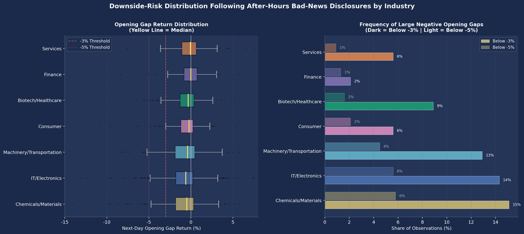

```python
# ================================================================
# CELL 13: Downside-Risk Distribution after After-Hours Bad News
# ================================================================

focus_all = [
    "Consumer",
    "Machinery/Transportation",
    "IT/Electronics",
    "Chemicals/Materials",
    "Finance",
    "Biotech/Healthcare",
    "Services",
]

bad_after = df_hb[
    (df_hb["news"] == "Bad News")
    & (df_hb["timing"] == "After-hours")
].copy()

bad_after["gap_pct"] = (
    bad_after["gap_ret"] * 100
)


# ------------------------------------------------------------
# Calculate industry-level downside-risk metrics
# ------------------------------------------------------------

risk_rows = []

for sector in focus_all:
    sub = (
        bad_after[
            bad_after["sector"] == sector
        ]["gap_pct"]
        .dropna()
    )

    if len(sub) < 10:
        continue

    risk_rows.append({
        "Sector": sector,
        "n": len(sub),
        "Mean (%)": round(
            sub.mean(),
            3
        ),
        "Median (%)": round(
            sub.median(),
            3
        ),
        "10th Percentile (%)": round(
            sub.quantile(0.10),
            3
        ),
        "5th Percentile (%)": round(
            sub.quantile(0.05),
            3
        ),
        "Below -3% (%)": round(
            (sub < -3).mean() * 100,
            1
        ),
        "Below -5% (%)": round(
            (sub < -5).mean() * 100,
            1
        ),
    })


risk_df = (
    pd.DataFrame(risk_rows)
    .sort_values("Mean (%)")
)


from IPython.display import display

display(
    risk_df.style
    .format({
        "Mean (%)": "{:.3f}%",
        "Median (%)": "{:.3f}%",
        "10th Percentile (%)": "{:.3f}%",
        "5th Percentile (%)": "{:.3f}%",
        "Below -3% (%)": "{:.1f}%",
        "Below -5% (%)": "{:.1f}%",
    })
    .background_gradient(
        subset=["Below -3% (%)"],
        cmap="Reds"
    )
    .background_gradient(
        subset=["5th Percentile (%)"],
        cmap="Blues_r"
    )
    .set_caption(
        "Industry-Level Downside-Risk Distribution "
        "Following After-Hours Bad-News Disclosures"
    )
    .hide(axis="index")
)


# ------------------------------------------------------------
# Visualization: boxplots and threshold frequencies
# ------------------------------------------------------------

fig, axes = plt.subplots(
    1,
    2,
    figsize=(16, 7)
)

fig.patch.set_facecolor(BG_COLOR)

fig.suptitle(
    "Downside-Risk Distribution Following "
    "After-Hours Bad-News Disclosures by Industry",
    fontsize=14,
    fontweight="bold",
    color="#FFFFFF",
    y=1.01,
)


# Panel 1: Opening-gap return distributions
ax = axes[0]
ax.set_facecolor("#243558")

plot_data = []
plot_labels = []
plot_colors = []

for _, row in risk_df.iterrows():
    sector = row["Sector"]

    sub = (
        bad_after[
            bad_after["sector"] == sector
        ]["gap_pct"]
        .dropna()
    )

    plot_data.append(
        sub.values
    )
    plot_labels.append(
        sector
    )
    plot_colors.append(
        SECTOR_COLORS.get(
            sector,
            "#AAAAAA"
        )
    )

bp = ax.boxplot(
    plot_data,
    vert=False,
    patch_artist=True,
    widths=0.5,
    showfliers=True,
    flierprops=dict(
        marker=".",
        markersize=3,
        alpha=0.3,
    ),
    medianprops=dict(
        color="#FFDD57",
        lw=2
    ),
    whiskerprops=dict(
        color="#AAAAAA",
        lw=1
    ),
    capprops=dict(
        color="#AAAAAA",
        lw=1.5
    ),
)

for patch, color in zip(
    bp["boxes"],
    plot_colors
):
    patch.set_facecolor(color)
    patch.set_alpha(0.7)

ax.set_yticklabels(
    plot_labels,
    fontsize=10
)

ax.axvline(
    0,
    color="#FFFFFF",
    lw=1.0,
    alpha=0.6,
)

ax.axvline(
    -3,
    color="#FF6B6B",
    lw=1.2,
    ls="--",
    alpha=0.7,
    label="-3% Threshold",
)

ax.axvline(
    -5,
    color="#C44E52",
    lw=1.2,
    ls=":",
    alpha=0.7,
    label="-5% Threshold",
)

ax.set_xlabel(
    "Next-Day Opening Gap Return (%)"
)

ax.set_title(
    "Opening Gap Return Distribution\n"
    "(Yellow Line = Median)",
    fontsize=11,
    fontweight="bold",
    pad=8,
)

ax.legend(fontsize=9)

ax.set_xlim(-15, 8)

ax.grid(
    axis="x",
    ls="--",
    alpha=0.3
)

ax.spines[["top", "right"]].set_visible(False)
ax.spines[["left", "bottom"]].set_color("#4A6080")


# Panel 2: Frequency below researcher-defined thresholds
ax = axes[1]
ax.set_facecolor("#243558")

y_r = np.arange(
    len(risk_df)
)

colors_r = [
    SECTOR_COLORS.get(
        sector,
        "#AAAAAA"
    )
    for sector in risk_df["Sector"]
]

ax.barh(
    y_r - 0.18,
    risk_df["Below -3% (%)"],
    0.32,
    color=colors_r,
    alpha=0.9,
    edgecolor="white",
    lw=0.4,
    label="Below -3%",
)

ax.barh(
    y_r + 0.18,
    risk_df["Below -5% (%)"],
    0.32,
    color=colors_r,
    alpha=0.45,
    edgecolor="white",
    lw=0.4,
    label="Below -5%",
)

ax.set_yticks(y_r)

ax.set_yticklabels(
    risk_df["Sector"],
    fontsize=10
)

ax.set_xlabel(
    "Share of Observations (%)"
)

ax.set_title(
    "Frequency of Large Negative Opening Gaps\n"
    "(Dark = Below -3% | Light = Below -5%)",
    fontsize=11,
    fontweight="bold",
    pad=8,
)

ax.legend(fontsize=9)

ax.grid(
    axis="x",
    ls="--",
    alpha=0.3
)

ax.spines[["top", "right"]].set_visible(False)
ax.spines[["left", "bottom"]].set_color("#4A6080")


for i, (v3, v5) in enumerate(
    zip(
        risk_df["Below -3% (%)"],
        risk_df["Below -5% (%)"]
    )
):
    ax.text(
        v3 + 0.3,
        i - 0.18,
        f"{v3:.0f}%",
        va="center",
        fontsize=8,
        color="#FFFFFF",
    )

    ax.text(
        v5 + 0.3,
        i + 0.18,
        f"{v5:.0f}%",
        va="center",
        fontsize=8,
        color="#AAAAAA",
    )


plt.tight_layout()

plt.savefig(
    OUTPUT_DIR / "13_5_downside_risk.png",
    dpi=150,
    bbox_inches="tight",
    facecolor=BG_COLOR,
)

plt.show()
```

## 19.5 Industry-Level Downside-Risk Distribution Following After-Hours Bad-News Disclosures

This section measures the frequency of large negative next-day opening gaps after after-hours bad-news disclosures. The −3% and −5% cutoffs are researcher-defined analytical thresholds rather than estimated regulatory or economic breakpoints.

### 19.5.1 Main Results

The highest frequencies of opening gaps below −3% were observed in:

- **Chemicals/Materials: 15.1%** below −3%; **5.8%** below −5%
- **IT/Electronics: 14.3%** below −3%; **5.6%** below −5%
- **Machinery/Transportation: 12.9%** below −3%; **4.5%** below −5%

Thus, in these industries, approximately one in every seven to eight after-hours bad-news disclosures was followed by an opening gap decline exceeding 3%.

Finance (2.1% below −3%) and Services (5.6% below −3%) showed much lower frequencies of large negative overnight moves despite relatively high after-hours disclosure rates.

### 19.5.2 Interpretation

The findings reinforce the distinction between **how often bad news is released after hours** and **how strongly prices move by the next opening**. Chemicals/Materials, IT/Electronics, and Machinery/Transportation combine relatively negative average opening gaps with comparatively frequent large negative overnight moves.

The analysis does not observe when investors acquired information, whether they had an opportunity to trade, or whether losses were actually realized. Accordingly, the results should be interpreted as market-reaction measures rather than direct evidence of investor harm.

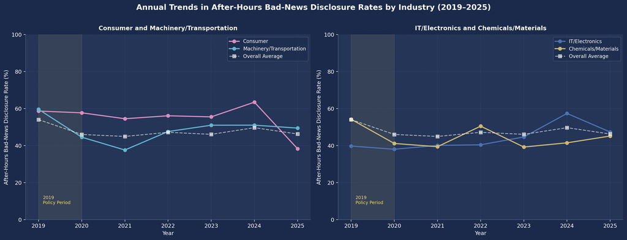

```
Annual After-Hours Bad-News Disclosure Rates (%)
Consumer                    : {2019: 58.7, 2020: 57.7, 2021: 54.5, 2022: 56.1, 2023: 55.6, 2024: 63.5, 2025: 38.3}
Machinery/Transportation    : {2019: 59.6, 2020: 44.6, 2021: 37.6, 2022: 47.6, 2023: 51.0, 2024: 51.1, 2025: 49.5}
IT/Electronics              : {2019: 39.8, 2020: 38.1, 2021: 40.1, 2022: 40.5, 2023: 44.7, 2024: 57.4, 2025: 47.4}
Chemicals/Materials         : {2019: 54.2, 2020: 41.2, 2021: 39.4, 2022: 50.5, 2023: 39.3, 2024: 41.5, 2025: 45.2}
Overall Average             : {2019: 54.1, 2020: 46.1, 2021: 45.0, 2022: 47.2, 2023: 46.1, 2024: 49.7, 2025: 46.3}
```

```python
# ================================================================
# CELL 14: Annual Trends in After-Hours Bad-News Disclosure Rates
# ================================================================

focus_sectors = [
    "Consumer",
    "Machinery/Transportation",
    "IT/Electronics",
    "Chemicals/Materials",
]

bad_yr = df_hb[
    (df_hb["news"] == "Bad News")
    & df_hb["year"].between(
        2019,
        2025
    )
].copy()


total_trend = (
    bad_yr
    .groupby("year")["timing"]
    .apply(
        lambda x:
        (x == "After-hours").mean() * 100
    )
    .reset_index(
        name="After-Hours Rate (%)"
    )
)


sector_trend = {}

for sector in focus_sectors:
    sub = bad_yr[
        bad_yr["sector"] == sector
    ]

    trend = (
        sub
        .groupby("year")["timing"]
        .apply(
            lambda x:
            (x == "After-hours").mean() * 100
        )
        .reset_index(
            name="After-Hours Rate (%)"
        )
    )

    sector_trend[sector] = trend


# ------------------------------------------------------------
# Visualization
# ------------------------------------------------------------

fig, axes = plt.subplots(
    1,
    2,
    figsize=(16, 6)
)

fig.patch.set_facecolor(BG_COLOR)

fig.suptitle(
    "Annual Trends in After-Hours Bad-News Disclosure Rates "
    "by Industry (2019–2025)",
    fontsize=14,
    fontweight="bold",
    color="#FFFFFF",
    y=1.01,
)


for ax_idx, (
    sectors,
    title
) in enumerate([
    (
        [
            "Consumer",
            "Machinery/Transportation",
        ],
        "Consumer and Machinery/Transportation",
    ),
    (
        [
            "IT/Electronics",
            "Chemicals/Materials",
        ],
        "IT/Electronics and Chemicals/Materials",
    ),
]):
    ax = axes[ax_idx]
    ax.set_facecolor("#243558")

    for sector in sectors:
        trend = sector_trend[sector]

        ax.plot(
            trend["year"],
            trend["After-Hours Rate (%)"],
            marker="o",
            lw=2,
            label=sector,
            color=SECTOR_COLORS.get(
                sector,
                "#AAAAAA"
            ),
        )

    ax.plot(
        total_trend["year"],
        total_trend["After-Hours Rate (%)"],
        marker="s",
        lw=1.5,
        ls="--",
        color="#FFFFFF",
        alpha=0.6,
        label="Overall Average",
    )

    # Contextual marker only. This chart does not estimate a causal
    # effect of any policy introduced around 2019.
    ax.axvspan(
        2019,
        2020,
        alpha=0.08,
        color="#FFDD57",
    )

    ax.text(
        2019.1,
        8,
        "2019\nPolicy Period",
        color="#FFDD57",
        fontsize=8,
        va="bottom",
    )

    ax.set_title(
        title,
        fontsize=11,
        fontweight="bold",
        pad=8,
    )

    ax.set_ylabel(
        "After-Hours Bad-News Disclosure Rate (%)"
    )

    ax.set_xlabel("Year")

    # Full percentage scale for comparability
    ax.set_ylim(0, 100)

    ax.set_xticks(
        range(2019, 2026)
    )

    ax.legend(fontsize=9)

    ax.grid(
        ls="--",
        alpha=0.3
    )

    ax.spines[["top", "right"]].set_visible(False)
    ax.spines[["left", "bottom"]].set_color("#4A6080")


plt.tight_layout()

plt.savefig(
    OUTPUT_DIR / "13_6_sector_trend.png",
    dpi=150,
    bbox_inches="tight",
    facecolor=BG_COLOR,
)

plt.show()


# ------------------------------------------------------------
# Print annual values
# ------------------------------------------------------------

print(
    "\nAnnual After-Hours Bad-News Disclosure Rates (%)"
)

for sector in focus_sectors:
    trend = (
        sector_trend[sector]
        .set_index("year")[
            "After-Hours Rate (%)"
        ]
        .round(1)
    )

    print(
        f"{sector:28s}: "
        f"{trend.to_dict()}"
    )

overall_trend = (
    total_trend
    .set_index("year")[
        "After-Hours Rate (%)"
    ]
    .round(1)
)

print(
    f"{'Overall Average':28s}: "
    f"{overall_trend.to_dict()}"
)
```

## 19.6 Annual Trends in After-Hours Bad-News Disclosure Rates (2019–2025)

Annual after-hours bad-news disclosure rates were compared for Consumer, Machinery/Transportation, IT/Electronics, and Chemicals/Materials, together with the overall sample average.

### 19.6.1 Main Results

The overall rate was **54.1% in 2019** and subsequently remained broadly around the **45%–50% range**. Consumer reached **63.5% in 2024**, while the other focus industries displayed year-to-year fluctuations without a common monotonic trend.

The time series therefore provides descriptive evidence that industry-level differences persisted throughout the 2019–2025 sample period.

### 19.6.2 Interpretation and Limitation

The shaded 2019–2020 period is included only as contextual information. Because the sample begins in 2019 and does not provide a substantial pre-policy comparison period, the analysis cannot identify the causal effect or effectiveness of any regulatory intervention introduced around that time.

Annual sample sizes also differ across industries, so individual-year estimates may be volatile. The figure should be interpreted primarily as a descriptive view of post-2019 temporal patterns rather than as a policy-effect evaluation.

```python
# ================================================================
# CELL 15: Prepare Variables for the Integrated Industry Matrix
# ================================================================

matrix = (
    sector_summary[
        [
            "Sector",
            "Bad-News Disclosures",
            "Bad-News After-Hours (%)",
        ]
    ]
    .merge(
        gap_summary[
            [
                "Sector",
                "Mean (%)",
            ]
        ]
        .rename(
            columns={
                "Mean (%)":
                "Mean Opening Gap Return (%)"
            }
        ),
        on="Sector",
        how="inner",
    )
)

x_mid = (
    matrix[
        "Bad-News After-Hours (%)"
    ]
    .median()
)

y_mid = (
    matrix[
        "Mean Opening Gap Return (%)"
    ]
    .median()
)

print(
    "Cross-Industry Median Reference Values — "
    f"After-Hours Rate: {x_mid:.1f}% | "
    f"Mean Opening Gap Return: {y_mid:.3f}%"
)

print()

print(
    matrix[
        [
            "Sector",
            "Bad-News After-Hours (%)",
            "Mean Opening Gap Return (%)",
            "Bad-News Disclosures",
        ]
    ]
    .sort_values(
        "Bad-News After-Hours (%)",
        ascending=False
    )
    .to_string(index=False)
)
```

```
Cross-Industry Median Reference Values — After-Hours Rate: 48.2% | Mean Opening Gap Return: -0.469%

                  Sector  Bad-News After-Hours (%)  Mean Opening Gap Return (%)  Bad-News Disclosures
                Services                      55.4                        0.168                   195
                Consumer                      54.9                       -0.502                   426
                 Finance                      54.1                        0.013                   440
                   Other                      50.9                       -0.240                   112
      Biotech/Healthcare                      48.2                       -0.436                   396
Machinery/Transportation                      48.2                       -0.628                   593
          IT/Electronics                      44.5                       -0.743                  1039
     Chemicals/Materials                      44.0                       -0.956                   637
            Construction                      34.2                       -0.256                   152
                  Energy                      17.4                       -0.898                    46
```

```python
# ================================================================
# CELL 16: Integrated Industry Matrix Classification
# ================================================================

grade_rows = []

for _, row in (
    matrix
    .sort_values(
        "Bad-News After-Hours (%)",
        ascending=False
    )
    .iterrows()
):
    x = row[
        "Bad-News After-Hours (%)"
    ]

    y = row[
        "Mean Opening Gap Return (%)"
    ]

    # "High impact" means a more negative mean opening gap return
    # relative to the cross-industry median.
    if (
        x >= x_mid
        and y <= y_mid
    ):
        grade = (
            "Q1  High Frequency / High Impact"
        )

    elif (
        x < x_mid
        and y <= y_mid
    ):
        grade = (
            "Q2  Lower Frequency / High Impact"
        )

    elif (
        x >= x_mid
        and y > y_mid
    ):
        grade = (
            "Q3  High Frequency / Lower Impact"
        )

    else:
        grade = (
            "Q4  Lower Frequency / Lower Impact"
        )

    grade_rows.append({
        "Sector": row["Sector"],
        "Bad-News After-Hours (%)": round(
            x,
            1
        ),
        "Mean Opening Gap Return (%)": round(
            y,
            3
        ),
        "Bad-News Disclosures": int(
            row["Bad-News Disclosures"]
        ),
        "Matrix Group": grade,
    })


grade_df = pd.DataFrame(
    grade_rows
)


def color_grade(value):
    if "Q1" in str(value):
        return (
            "background-color: #FDECEA; "
            "color: #C0392B; "
            "font-weight: bold"
        )

    if "Q2" in str(value):
        return (
            "background-color: #FEF3E2; "
            "color: #D35400; "
            "font-weight: bold"
        )

    if "Q3" in str(value):
        return (
            "background-color: #FEF9E7; "
            "color: #B7950B; "
            "font-weight: bold"
        )

    if "Q4" in str(value):
        return (
            "background-color: #EAF4FB; "
            "color: #1A5276; "
            "font-weight: bold"
        )

    return ""


from IPython.display import display

display(
    grade_df.style
    .format({
        "Bad-News After-Hours (%)": "{:.1f}%",
        "Mean Opening Gap Return (%)": "{:.3f}%",
        "Bad-News Disclosures": "{:,}",
    })
    .map(
        color_grade,
        subset=["Matrix Group"]
    )
    .background_gradient(
        subset=["Bad-News After-Hours (%)"],
        cmap="Reds"
    )
    .background_gradient(
        subset=["Mean Opening Gap Return (%)"],
        cmap="Blues_r"
    )
    .set_caption(
        "Integrated Industry Risk Matrix Classification"
    )
    .hide(axis="index")
)
```

Table 4: Integrated Industry Risk Matrix Classification

| Sector | Bad-News After-Hours (%) | Mean Opening Gap Return (%) | Bad-News Disclosures | Matrix Group |
| --- | --- | --- | --- | --- |
| Services | 55.4% | 0.168% | 195 | Q3 High Frequency / Lower Impact |
| Consumer | 54.9% | -0.502% | 426 | Q1 High Frequency / High Impact |
| Finance | 54.1% | 0.013% | 440 | Q3 High Frequency / Lower Impact |
| Other | 50.9% | -0.240% | 112 | Q3 High Frequency / Lower Impact |
| Biotech/Healthcare | 48.2% | -0.436% | 396 | Q3 High Frequency / Lower Impact |
| Machinery/Transportation | 48.2% | -0.628% | 593 | Q1 High Frequency / High Impact |
| IT/Electronics | 44.5% | -0.743% | 1,039 | Q2 Lower Frequency / High Impact |
| Chemicals/Materials | 44.0% | -0.956% | 637 | Q2 Lower Frequency / High Impact |
| Construction | 34.2% | -0.256% | 152 | Q4 Lower Frequency / Lower Impact |
| Energy | 17.4% | -0.898% | 46 | Q2 Lower Frequency / High Impact |

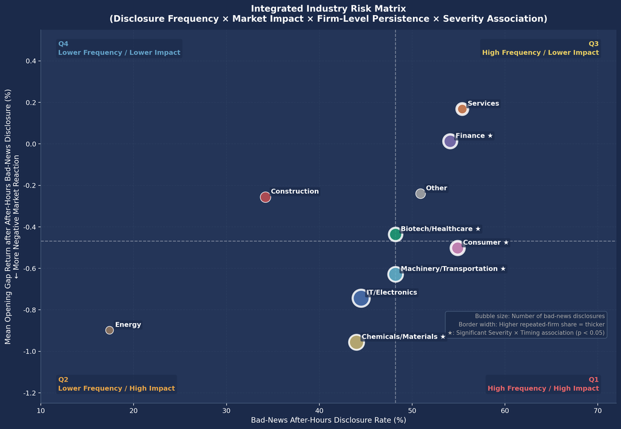

```python
# ================================================================
# CELL 17: Integrated Industry Risk Matrix
# # X-axis: after-hours bad-news disclosure rate
# Y-axis: mean opening gap return
# Bubble size: number of bad-news disclosures
# Border width: repeated-firm share
# Star: significant Severity × Timing association
# ================================================================

repeat_map = (
    repeat_df
    .set_index("Sector")[
        "Repeated-Firm Share (%)"
    ]
    .to_dict()
)

sig_severity = {
    sector
    for sector in chi2_pvals
    if chi2_pvals[sector] < 0.05
}


fig, ax = plt.subplots(
    figsize=(13, 9)
)

fig.patch.set_facecolor(BG_COLOR)
ax.set_facecolor("#243558")

x_mid = (
    matrix[
        "Bad-News After-Hours (%)"
    ]
    .median()
)

y_mid = (
    matrix[
        "Mean Opening Gap Return (%)"
    ]
    .median()
)


ax.axvline(
    x_mid,
    color="#FFFFFF",
    lw=1.2,
    ls="--",
    alpha=0.4,
)

ax.axhline(
    y_mid,
    color="#FFFFFF",
    lw=1.2,
    ls="--",
    alpha=0.4,
)

ax.set_xlim(10, 72)
ax.set_ylim(-1.25, 0.55)


# Neutral quadrant labels
for (
    qx,
    qy,
    label,
    color,
    ha,
    va,
) in [
    (
        0.97,
        0.03,
        "Q1\nHigh Frequency / High Impact",
        "#FF6B6B",
        "right",
        "bottom",
    ),
    (
        0.03,
        0.03,
        "Q2\nLower Frequency / High Impact",
        "#FFB347",
        "left",
        "bottom",
    ),
    (
        0.97,
        0.97,
        "Q3\nHigh Frequency / Lower Impact",
        "#FFE066",
        "right",
        "top",
    ),
    (
        0.03,
        0.97,
        "Q4\nLower Frequency / Lower Impact",
        "#6BAED6",
        "left",
        "top",
    ),
]:
    ax.text(
        qx,
        qy,
        label,
        color=color,
        fontsize=10,
        fontweight="bold",
        ha=ha,
        va=va,
        alpha=0.9,
        linespacing=1.5,
        transform=ax.transAxes,
        bbox=dict(
            boxstyle="round,pad=0.3",
            fc="#1B2A4A",
            ec="none",
            alpha=0.6,
        ),
    )


# ------------------------------------------------------------
# Plot industry bubbles
# ------------------------------------------------------------

for _, row in matrix.iterrows():
    sector = row["Sector"]

    x = row[
        "Bad-News After-Hours (%)"
    ]

    y = row[
        "Mean Opening Gap Return (%)"
    ]

    size = (
        np.sqrt(
            row["Bad-News Disclosures"]
        )
        * 20
    )

    color = SECTOR_COLORS.get(
        sector,
        "#AAAAAA"
    )

    repeat_value = repeat_map.get(
        sector,
        0
    )

    line_width = (
        1
        + repeat_value / 15
    )

    ax.scatter(
        x,
        y,
        s=size,
        color=color,
        alpha=0.85,
        edgecolors="white",
        linewidths=line_width,
        zorder=3,
    )

    star = (
        " ★"
        if sector in sig_severity
        else ""
    )

    ax.annotate(
        f"{sector}{star}",
        (x, y),
        textcoords="offset points",
        xytext=(8, 5),
        fontsize=10,
        color="#FFFFFF",
        fontweight="bold",
        zorder=4,
        bbox=dict(
            boxstyle="round,pad=0.2",
            fc="#1B2A4A",
            ec="none",
            alpha=0.7,
        ),
    )


legend_text = (
    "Bubble size: Number of bad-news disclosures\n"
    "Border width: Higher repeated-firm share = thicker\n"
    "★: Significant Severity × Timing association (p < 0.05)"
)

ax.text(
    0.98,
    0.18,
    legend_text,
    transform=ax.transAxes,
    fontsize=8.5,
    color="#AAAAAA",
    va="bottom",
    ha="right",
    linespacing=1.6,
    bbox=dict(
        boxstyle="round,pad=0.4",
        fc="#1B2A4A",
        ec="#4A6080",
        alpha=0.8,
    ),
)

ax.set_xlabel(
    "Bad-News After-Hours Disclosure Rate (%)",
    fontsize=11,
)

ax.set_ylabel(
    "Mean Opening Gap Return after "
    "After-Hours Bad-News Disclosure (%)\n"
    "← More Negative Market Reaction",
    fontsize=11,
)

ax.set_title(
    "Integrated Industry Risk Matrix\n"
    "(Disclosure Frequency × Market Impact × "
    "Firm-Level Persistence × Severity Association)",
    fontsize=13,
    fontweight="bold",
    pad=12,
)

ax.grid(
    ls="--",
    alpha=0.2
)

ax.spines[["top", "right"]].set_visible(False)
ax.spines[["left", "bottom"]].set_color("#4A6080")

plt.tight_layout()

plt.savefig(
    OUTPUT_DIR / "13_7_integrated_risk_matrix.png",
    dpi=150,
    bbox_inches="tight",
    facecolor=BG_COLOR,
)

plt.show()
```

## 19.7 Integrated Industry Risk Matrix

The preceding analyses are combined into an exploratory two-dimensional industry matrix. The x-axis represents the after-hours bad-news disclosure rate, while the y-axis represents the mean next-day opening gap return following after-hours bad-news disclosure. Bubble size indicates the number of bad-news disclosures, border width reflects the repeated-firm share, and ★ marks industries with a statistically significant Severity × Timing association.

### 19.7.1 Matrix Classification

**Q1 — High Frequency / High Impact: Consumer★, Machinery/Transportation★**

These industries are above the cross-industry median in after-hours bad-news disclosure frequency and have more negative average opening-gap returns than the median reference. Consumer also has a relatively high repeated-firm concentration. Machinery/Transportation has a lower repeated-firm share, indicating that its classification is less concentrated among firms meeting the repeated-disclosure threshold; this does not by itself establish an industry-wide structural mechanism.

**Q2 — Lower Frequency / High Impact: IT/Electronics, Chemicals/Materials★, Energy**

These industries are characterized primarily by relatively negative opening-gap reactions rather than unusually high after-hours bad-news disclosure frequency. Chemicals/Materials also exhibits a statistically significant Severity × Timing association. Energy should be interpreted cautiously because its bad-news sample is relatively small.

**Q3 — High Frequency / Lower Impact: Services, Finance★, Biotech/Healthcare★**

These industries have comparatively high after-hours bad-news disclosure rates but less negative average opening-gap reactions. Biotech/Healthcare is relatively close to the matrix boundary and therefore should not be treated as qualitatively distinct from neighboring groups.

**Q4 — Lower Frequency / Lower Impact: Construction**

Construction is below the cross-industry median on both dimensions. This is a relative classification and should not be interpreted as evidence that the industry is free of disclosure-related risk.

### 19.7.2 Interpretation

The matrix is designed to distinguish **disclosure frequency** from **market-reaction magnitude**. These dimensions need not move together and therefore provide complementary information for exploratory industry screening.

The **Other** category represents firms whose KSIC divisions were not included in the nine predefined research sectors. It is therefore treated as a residual classification rather than as a substantive industry sector and is not included in the substantive quadrant interpretation above.

The classification is median-based and descriptive. It does not establish strategic intent, causal mechanisms, or the effectiveness of any particular regulatory intervention. Results are also sensitive to the cross-industry median reference points and to the limited sample sizes of some industries.

## 19.8 Industry-Level Analysis: Summary of Results

## 19.9 Analysis Overview

This analysis examines **8,553 earnings disclosures from Korean listed firms between 2019 and 2025** to evaluate whether after-hours bad-news disclosure patterns differ across industries. Firms are classified using KSIC codes obtained from the DART Company Overview API. **KSIC codes were successfully retrieved for all firms, and 97.5% were mapped to one of the nine predefined research sectors; the remaining firms were retained in a residual “Other” category.**

The analysis combines five components: industry-level disclosure-timing comparisons, opening-gap market reactions, severity-based timing patterns, concentration of repeated after-hours firms, and downside-risk distributions integrated into a two-dimensional industry matrix.

## 19.10 Key Findings

### 19.10.1 After-Hours Bad-News Disclosure Rates

The overall after-hours rate for bad-news disclosures was **47.5%**. Services (55.4%), Consumer (54.9%), and Finance (54.1%) recorded relatively high rates, whereas Construction (34.2%) and Energy (17.4%) were substantially lower.

Within-industry News Type × Disclosure Timing chi-square tests were significant at **p < 0.05 in seven industries**: IT/Electronics, Chemicals/Materials, Machinery/Transportation, Finance, Consumer, Biotech/Healthcare, and Services. Four of these—IT/Electronics, Chemicals/Materials, Machinery/Transportation, and Biotech/Healthcare—were significant at **p < 0.001**.

### 19.10.2 Industry-Level Opening-Gap Market Reaction

The distribution of opening gap returns following after-hours bad-news disclosures differed significantly across industries (**Kruskal–Wallis H = 44.133, p < 0.001**).

### 19.10.3 Bad-News Severity and Disclosure Timing

Significant Severity × Timing associations were found in Consumer, Machinery/Transportation, Chemicals/Materials, Finance, and Biotech/Healthcare. Descriptively, severe bad-news observations had after-hours rates roughly 18–20 percentage points higher than mild bad-news observations in Consumer, Machinery/Transportation, and Chemicals/Materials.

These associations are consistent with selective variation in disclosure timing by news magnitude, but they do not establish intentional strategic timing.

### 19.10.4 Concentration of Repeated After-Hours Firms

Services (43.5%) and Consumer (42.2%) had the highest shares of firms meeting the repeated after-hours criterion. Machinery/Transportation (27.0%) and Chemicals/Materials (26.0%) had lower repeated-firm concentrations despite significant severity associations.

A lower repeated-firm share should not be interpreted as proof of an industry-wide structural pattern; it only indicates that the aggregate result is less concentrated among firms satisfying the chosen threshold.

### 19.10.5 Downside-Risk Distribution

Chemicals/Materials (15.1%), IT/Electronics (14.3%), and Machinery/Transportation (12.9%) recorded the highest frequencies of opening gap returns below −3% following after-hours bad-news disclosures. The corresponding below −5% frequencies were 5.8%, 5.6%, and 4.5%, respectively.

These results quantify large negative overnight market reactions but do not directly measure realized investor losses or investors’ ability to respond.

### 19.10.6 Integrated Industry Matrix

| Matrix Group | Industries | Relative Characteristics |
| --- | --- | --- |
| Q1: High Frequency / High Impact | Consumer★, Machinery/Transportation★ | Higher after-hours frequency + more negative opening-gap reaction |
| Q2: Lower Frequency / High Impact | IT/Electronics, Chemicals/Materials★, Energy | Lower relative frequency + more negative opening-gap reaction |
| Q3: High Frequency / Lower Impact | Services, Finance★, Biotech/Healthcare★ | Higher relative frequency + less negative opening-gap reaction |
| Q4: Lower Frequency / Lower Impact | Construction | Lower relative frequency + less negative opening-gap reaction |

★ Significant Bad-News Severity × Disclosure Timing association at p < 0.05.

The **Other** category is a residual classification containing firms whose KSIC divisions were not included in the nine predefined research sectors. It is therefore not interpreted as a substantive industry sector in the matrix classification above.

## 19.11 Limitations

First, the matrix uses cross-industry medians and researcher-defined thresholds, so the resulting groups are exploratory rather than absolute risk categories.

Second, the Energy sector contains only 46 bad-news observations, limiting the stability and generalizability of its estimates.

Third, the opening-gap measure captures short-horizon market reaction and does not represent longer-term price adjustment.

Fourth, industry-specific chi-square tests are reported using **unadjusted p-values**. Because multiple hypothesis tests were conducted across industries, marginally significant results should be interpreted cautiously in light of potential multiple-testing effects.

Fifth, the analysis does not control for all potentially relevant firm-level factors, including earnings surprises relative to market expectations, corporate governance characteristics, or institutional ownership. Future work could incorporate these variables in a multivariate industry-level framework.

Finally, the analysis is observational. Statistical associations in disclosure timing should not be interpreted as proof of strategic intent or as causal evidence about regulatory effectiveness.

# 20 Industry-Level Synthesis

The industry analysis shows that disclosure behavior and market impact are not the same risk dimension. Some industries exhibit relatively high after-hours bad-news disclosure rates but only modest next-day price impact, while others exhibit lower after-hours frequencies but much larger negative opening gaps when bad news is released after hours.

The difference between bad-news and good-news after-hours disclosure shares is especially pronounced in **Biotechnology/Healthcare**, **Machinery/Transportation**, **IT/Electronics**, and **Chemicals/Materials**, while Construction and Energy do not show the same degree of statistically significant separation. Industry-level opening-gap distributions also differ significantly, with particularly negative average gaps in Chemicals/Materials, IT/Electronics, and Machinery/Transportation.

The severity-by-industry analysis further suggests that in several sectors the after-hours share rises as bad news becomes more severe. The firm-level concentration analysis shows a different dimension: Service and Consumer sectors contain relatively high proportions of firms with repeated after-hours bad-news patterns. These findings motivate treating **frequency**, **market impact**, **severity sensitivity**, and **firm-level persistence** as separate but complementary indicators.

The integrated industry matrix is therefore best interpreted as an **exploratory screening framework**, not as evidence that a particular industry or firm intentionally concealed information.

# 21 Exploratory Industry-Differentiated Policy Framework

The empirical industry matrix is organized into a four-quadrant policy framework. Because the analysis is observational and some industry subsamples are limited, these proposals should be interpreted as exploratory policy options rather than definitive regulatory prescriptions.

## 21.1 Policy-design principle

A uniform restriction on all after-hours disclosures may be difficult to justify because the regression analysis does not identify a statistically significant additional market penalty from the after-hours indicator itself once other factors are controlled for. At the same time, repeated timing patterns and substantial industry heterogeneity suggest that **transparency, monitoring, and risk-based supervision** may be more proportionate than a blanket prohibition.

The proposed framework distinguishes four broad cases:

| Quadrant | General characteristic | Illustrative policy emphasis |
| --- | --- | --- |
| Q1 | High after-hours bad-news frequency + high market impact | Stronger monitoring and targeted intervention |
| Q2 | Lower frequency + high market impact | Disclosure quality and post-event impact monitoring |
| Q3 | High frequency + lower market impact | Transparency and repeated-pattern monitoring |
| Q4 | Lower frequency + lower market impact | Maintain current framework with periodic review |

## 21.2 Q1: Higher-priority monitoring

For industries that combine frequent after-hours bad-news disclosures with relatively large market reactions, the project considers stronger supervisory tools. Possible measures include tighter review of repeated after-hours patterns, targeted guidance on disclosure timing, advance-warning mechanisms for large earnings deteriorations, and automated monitoring of firms that repeatedly place unfavorable disclosures after market close.

An AI-based anomaly-detection system could be used as a **screening tool** within DART supervision, flagging repeated patterns for human review rather than treating algorithmic flags as evidence of wrongdoing.

## 21.3 Q2: Market-impact monitoring and disclosure quality

Where after-hours bad-news frequency is not especially high but market impact is large, the policy focus shifts toward the quality and completeness of disclosure. The project proposes more detailed explanations of earnings deterioration, future outlook, and management response; periodic disclosure-quality monitoring; and post-disclosure tracking of unusually large price reactions.

## 21.4 Q3: Transparency and repeated-pattern management

For industries with high after-hours frequency but relatively smaller market impact, the project emphasizes transparency. Possible measures include publishing firm- and industry-level disclosure-timing indicators, providing sector-specific guidance to investor-relations staff, and offering incentives for firms that maintain high disclosure-quality standards.

## 21.5 Q4: Maintain and monitor

Industries with both lower after-hours frequency and smaller market impact would remain under the existing framework, with periodic monitoring and the possibility of reclassification if their risk profile changes materially.

## 21.6 Illustrative policy roadmap

| Stage | Horizon | Illustrative action |
| --- | --- | --- |
| 1 | Short term | Publish timing indicators and begin targeted monitoring for higher-risk groups |
| 2 | 1–2 years | Develop disclosure-quality and transparency indicators |
| 3 | 2–3 years | Evaluate advance-warning and sector-specific supervisory measures |
| 4 | Longer term | Reclassify industry risk groups and evaluate policy effectiveness |

# 22 Additional Policy Recommendations

The empirical results suggest that after-hours bad-news disclosure can be a repeated firm-level practice and that its implications differ substantially across industries. However, the results do **not** establish that all after-hours disclosure is strategically harmful or that blanket restrictions are optimal. The project therefore prioritizes transparency and differentiated oversight.

## 22.1 Publish firm- and industry-level disclosure-timing patterns

Regulators or the exchange could periodically publish summary indicators such as annual after-hours bad-news shares, repeated after-hours disclosure counts, industry averages, and related market-impact statistics. This approach can improve market transparency without immediately imposing a broad timing restriction.

## 22.2 Improve real-time disclosure alerts

Because investors cannot trade immediately on after-hours information, the accessibility of real-time filing alerts could be improved through broader mobile notifications and clearer investor-facing disclosure summaries. High-risk disclosures identified by objective criteria could receive enhanced alerts, subject to regulatory design and testing.

## 22.3 Consider call-auction mechanisms for selected high-impact events

A further policy option is to evaluate whether a call-auction mechanism at the next market open could reduce abrupt price dislocation after exceptionally severe after-hours disclosures. Any such measure would require careful exchange-level evaluation, narrow eligibility criteria, and empirical testing because the current study does not directly estimate the causal effect of a call auction.

# 23 Policy Priority

An illustrative priority order from the project is:

| Priority | Measure | Main scope | Intended effect |
| --- | --- | --- | --- |
| 1 | Publish firm- and industry-level timing indicators | All industries | Reduce information asymmetry |
| 2 | Improve real-time filing alerts | All industries | Increase investors’ response capacity |
| 3 | Apply differentiated industry monitoring | Higher-risk quadrants | Improve disclosure practices |
| 4 | Develop anomaly-detection monitoring | Initially higher-risk industries | Identify repeated patterns for review |
| 5 | Evaluate call-auction application | Selected high-impact events | Potentially reduce opening-price dislocation |

# 24 Conclusion

## 24.1 Summary of findings

This project analyzes corporate disclosure-timing patterns among Korean listed firms using DART earnings disclosures, minute-level filing times, stock prices, trading volume, market indices, and firm-level characteristics.

First, unfavorable disclosures are more frequently released after market close than favorable disclosures. In the core cross-tabulation, the after-hours share is approximately **46.9% for Bad News and 38.4% for Good News**, and the association between news type and disclosure timing is statistically significant. The broader timing analyses also identify concentration around after-market periods and a notable Friday after-hours subgroup.

Second, the event study shows that **Bad News – After-hours** observations have the most negative average CAR among the four principal good/bad-news × intraday/after-hours groups. This establishes an association between after-hours bad-news events and more negative market reactions, although it does not by itself prove that the timing choice causes the return difference.

Third, the timing-choice analysis evaluates bad-news status, operating-income severity, firm characteristics, and a strictly lagged historical after-hours ratio as predictors of after-hours filing. The rendered Stage 1 table reports standardized odds ratios and robust inference for these predictors. Separately, the severity analysis shows that the after-hours share rises across the Mild, Moderate, and Severe categories. At the same time, the second-stage return regression does not support a simple interpretation that after-hours timing itself imposes an additional independent market penalty once observable controls are included.

Fourth, the return-decomposition analyses show that the market response to after-hours bad news is not confined to the next-day opening gap. Negative intraday continuation is also observed, indicating that price adjustment can continue after the market opens.

Fifth, the firm-level analysis identifies substantial heterogeneity and persistence in after-hours disclosure behavior. Historical timing behavior is therefore an important explanatory variable, consistent with the possibility that disclosure timing reflects firm-specific routines or practices rather than only isolated event-level choices.

Sixth, the industry analysis reveals meaningful heterogeneity. Industries with high after-hours bad-news frequency are not necessarily the same industries with the largest negative next-day price impact. An industry risk framework should therefore consider multiple dimensions rather than rely on a single aggregate after-hours rate.

## 24.2 Contributions

The project contributes by: (1) constructing minute-level disclosure timestamps; (2) combining timing-pattern analysis with a Market Model event study; (3) modeling determinants of after-hours disclosure choice; (4) decomposing next-day price adjustment into opening-gap and intraday components; (5) testing persistence at the firm level; and (6) combining disclosure frequency and market impact in an industry-level exploratory framework.

## 24.3 Policy implications

After-hours filing is permitted within the existing disclosure system, and the present analysis does not establish that every after-hours filing is problematic. The evidence instead supports stronger transparency around repeated timing patterns, improved investor access to disclosures, and risk-based monitoring that accounts for industry heterogeneity and event severity.

## 24.4 Limitations and future research

This study has several limitations.

1. The good-news/bad-news measure is based on operating-income changes and may not fully capture earnings surprises relative to analyst or market expectations.
2. DART registration time is not necessarily identical to the time at which information was internally produced or the firm’s decision to release it was made.
3. Filing time is measured at the minute level, but most market-reaction analyses use daily price data; very short-run intraday information incorporation is therefore not observed directly.
4. Investor-type transaction data are unavailable, so heterogeneous reactions by retail, institutional, and foreign investors cannot be directly identified.
5. The analysis is observational and does not fully identify a causal effect of timing choice on market outcomes.
6. The industry risk matrix is exploratory, and generalization should be cautious where industry-level sample sizes are limited.
7. The project conducts multiple subgroup and hypothesis tests across weekdays, markets, years, severity groups, and industries. Most reported p-values are unadjusted unless explicitly stated otherwise, so isolated results near conventional significance thresholds should be interpreted cautiously. Future confirmatory work should pre-specify primary hypotheses and apply an appropriate family-wise error or false-discovery-rate procedure where multiple comparisons are central to inference.

Future research could use high-frequency transaction data, investor-type trading records, analyst-consensus surprises, or natural-experiment designs. The framework could also be extended beyond earnings disclosures to capital increases, embezzlement/breach-of-trust announcements, supply contracts, M&A, and other material events.

# 25 AI-Assisted Workflow and Validation

Claude (Anthropic) was used during project development as an assistant for selected tasks, including drafting portions of Python code, suggesting analysis structure, and refining the wording of hypotheses and explanatory text. The researcher determined the final research questions, data definitions, model specifications, execution workflow, interpretation, and final reporting.

Validation included checking drafted preprocessing code against the actual dataset schema, rerunning statistical analyses, comparing chart labels with underlying cross-tabulations, reviewing coefficient signs and p-values against executed model output, and correcting AI-generated text when it contained stale values or overly strong interpretations. The final report therefore relies on executed analytical output rather than generative-AI text as the source of empirical claims.

The project therefore treats generative-AI output as a drafting and coding aid rather than as an authoritative source of empirical results.

# 26 References

- Financial Supervisory Service. (2024). *DART Electronic Disclosure System User Guide*.
- Korea Exchange. (2024). *KOSPI and KOSDAQ Disclosure Regulations*.
- Ball, R., & Brown, P. (1968). An empirical evaluation of accounting income numbers. *Journal of Accounting Research, 6*(2), 159–178.
- Bagnoli, M., Clement, M. B., Watts, S. G., & Watts, R. L. (2006). Around-the-clock media coverage and the timing of earnings announcements. Working Paper.
- Beaver, W. H. (1968). The information content of annual earnings announcements. *Journal of Accounting Research, 6*, 67–92.
- Brav, A., & Heaton, J. B. (2002). Competing theories of financial anomalies. *Review of Financial Studies, 15*(2), 575–606.
- Damodaran, A. (1989). The weekend effect in information releases: A study of earnings and dividend announcements. *Review of Financial Studies, 2*(4), 607–623.
- DeHaan, E., Shevlin, T., & Thornock, J. (2015). Market (in)attention and the strategic scheduling and timing of earnings announcements. *Journal of Accounting and Economics, 60*(1), 36–55.
- Doyle, J. T., & Magilke, M. J. (2009). The timing of earnings announcements: An examination of the strategic disclosure hypothesis. *The Accounting Review, 84*(1), 157–182.
- Fama, E. F. (1970). Efficient capital markets: A review of theory and empirical work. *Journal of Finance, 25*(2), 383–417.
- MacKinlay, A. C. (1997). Event studies in economics and finance. *Journal of Economic Literature, 35*(1), 13–39.
- Patell, J. M., & Wolfson, M. A. (1982). Good news, bad news, and the intraday timing of corporate disclosures. *The Accounting Review, 57*(3), 509–527.
- Yoon, P., Choi, S., & Lim, B. (2017). *Is it advantageous for managers to disclose bad news after market close?* Korean Journal of Financial Management, 34(3), 33–59. https://doi.org/10.22510/kjofm.2017.34.3.002
- Lee, E. (2007). *Strategic choice of disclosure timing and market reaction*. Korean Academic Society of Business Administration conference proceedings, 2007(8), 107–130.
- Lee, I., & Yoo, S. (2021). *An exploratory study on firms’ strategic selection of electronic disclosure timing: Have “owl disclosures” disappeared?* National Policy Research, 35(3), 177–207.
- Jung, T., & Kang, T. (2010). *The timing of corporate disclosure and stock-market reaction*. International Economic Journal, 16(1), 135–159. https://doi.org/10.17298/kky.2010.16.1.006